# Supporting Information 4

Daniel Y.M. Nakamura, Ward C. Wheeler, Taran Grant

2026-06-15

To test the assumption that morphological partitions would be swamped by genomic partitions, we compiled a diverse array of 63 published datasets and evaluated the impact of morphological evidence in both maximum likelihood (ML) and maximum parsimony (MP) analyses. Specifically, we addressed the following questions: (1) Do MOL and TE topologies differ? (2) Are distances between MOL and TE topologies related to the proportion of morphological characters? (3) Do the effects of morphological evidence on topology and optimality scores differ between maximum likelihood (ML) and maximum parsimony (MP) analyses? (4) Does morphological evidence affect the support values of clades shared by MOL and TE trees? (5) Do support values of MOL clades predict the occurrence of those clades in TE trees?

# Exploratory analyses

## Distributions of characters (Figure S1)

```r
# Load data
df <- read.csv("Dataset_R_q123_07-26.csv")

# Panel A
p1 <- ggplot(df, aes(x = nMolCharacters)) +
  geom_histogram(binwidth = 100, color = "black", fill = "steelblue") +
  labs(
    x = "Number of molecular characters",
    y = "Count"
  ) +
  theme_classic(base_size = 14)

# Panel B
p2 <- ggplot(df, aes(x = nMorphCharacters)) +
  geom_histogram(binwidth = 100, color = "black", fill = "steelblue") +
  labs(
    x = "Number of morphological characters",
    y = "Count"
  ) +
  theme_classic(base_size = 14)

# Panel C
p3 <- ggplot(df, aes(x = X.Morph.Total)) +
  geom_histogram(
    bins = 30,
    color = "black",
    fill = "steelblue"
  ) +
  scale_x_continuous(labels = label_scientific()) +
  labs(
    x = "Proportion of morphological characters",
    y = "Count"
  ) +
  theme_classic(base_size = 14)

# Panel D
p4 <- ggplot(df, aes(x = nTEterminals)) +
  geom_histogram(binwidth = 30, color = "black", fill = "steelblue") +
  labs(
    x = "Number of terminals",
    y = "Count"
  ) +
  theme_classic(base_size = 14)

# Combine panels
fig <- (p1 | p2) /
       (p3 | p4) +
  plot_annotation(tag_levels = "a") &
  theme(
    plot.tag = element_text(size = 16, face = "bold"),
    plot.tag.position = c(0.02, 0.98)
  )

# Save as JPEG (300 dpi)
ggsave(
  "Figures/S1_histograms.jpg",
  fig,
  width = 8,
  height = 8,
  units = "in",
  dpi = 300
)
```

## Year x Size (Figure 10)

```r
# Load data
df <- read.csv("Dataset_R_q123_07-26.csv")

# Panel A
# Fit model
lm_exp <- lm(log(nMolCharacters) ~ Year, data = df)
# Prediction grid
newdat <- data.frame(
  Year = seq(min(df$Year), max(df$Year), length.out = 200)
)
# Predictions with 95% confidence intervals
pred <- predict(lm_exp, newdata = newdat, interval = "confidence")
newdat$fit <- exp(pred[, "fit"])
newdat$lwr <- exp(pred[, "lwr"])
newdat$upr <- exp(pred[, "upr"])
# Plot
p1 <- ggplot() +
  geom_point(
    data = df,
    aes(Year, nMolCharacters),
    size = 2.5,
    alpha = 0.8,
    color = "steelblue"
  ) +
  geom_ribbon(
    data = newdat,
    aes(x = Year, ymin = lwr, ymax = upr),
    fill = "grey70",
    alpha = 0.4
  ) +
  geom_line(
    data = newdat,
    aes(x = Year, y = fit),
    color = "black",
    linewidth = 0.8
  ) +
  labs(
    x = "Year",
    y = "No. molecular characters"
  ) +
  theme_classic(base_size = 14)

# Panel B
p2 <- ggplot(df, aes(x = Year, y = nMorphCharacters)) +
  geom_point(size = 2.5, alpha = 0.8, color = "steelblue") +
  geom_smooth(method = "lm", se = TRUE, color = "black", linewidth = 0.8) +
  labs(
    x = "Year",
    y = "No. morphological characters"
  ) +
  theme_classic(base_size = 14)

# Panel C
p3 <- ggplot(df, aes(x = Year, y = X.Morph.Total)) +
  geom_point(size = 2.5, alpha = 0.8, color = "steelblue") +
  geom_smooth(method = "lm", se = TRUE, color = "black", linewidth = 0.8) +
  scale_y_continuous(labels = label_scientific()) +
  labs(
    x = "Year",
    y = "% Morphological characters"
  ) +
  theme_classic(base_size = 14)

# Panel D
p4 <- ggplot(df, aes(x = Year, y = nTEterminals)) +
  geom_point(size = 2.5, alpha = 0.8, color = "steelblue") +
  geom_smooth(method = "lm", se = TRUE, color = "black", linewidth = 0.8) +
  labs(
    x = "Year",
    y = "No. terminals"
  ) +
  theme_classic(base_size = 14)

# Combine panels
fig <- (p1 | p2) /
       (p3 | p4) +
  plot_annotation(tag_levels = "a") &
  theme(
    plot.tag = element_text(size = 16, face = "plain"),
    plot.tag.position = c(0.02, 0.98)
  )

# Save figure
ggsave(
  "Figures/Fig10_yearXsize.jpg",
  fig,
  width = 8,
  height = 8,
  units = "in",
  dpi = 300
)
```

# Q1. Are topologies impacted by the addition of morphological evidence?

Dataset with MOL-TE topological distances were calculated in script 1.

```r
# Load data
df <- read.csv("Dataset_R_q123_07-26.csv")
extinct_datasets <- unique(df$Dataset[df$Type == "Extinct"])
# Append the extant datasets that do not appear among extinct
df_extinct <- df[df$Type == "Extinct" |
                  (df$Type == "Extant" & !(df$Dataset %in% extinct_datasets)), ]

print("EXTANT: Number of datasets (extant) impacted by the addition of morphological evidence")
```

```
## [1] "EXTANT: Number of datasets (extant) impacted by the addition of morphological evidence"
```

```r
df_extant <- df %>% filter(grepl("Extant", Type)) # keep only extant datasets
print("MP MOL vs MP TE (number min)")
```

```
## [1] "MP MOL vs MP TE (number min)"
```

```r
sum(df_extant$MP_MOLvsTE_NormalizedMinRF > 0)
```

```
## [1] 42
```

```r
print("MP MOL vs MP TE (proportion min)")
```

```
## [1] "MP MOL vs MP TE (proportion min)"
```

```r
sum(df_extant$MP_MOLvsTE_NormalizedMinRF > 0) / nrow(df_extant)
```

```
## [1] 0.6666667
```

```r
print("MP MOL vs MP TE (number strict)")
```

```
## [1] "MP MOL vs MP TE (number strict)"
```

```r
sum(df_extant$MP_MOLvsTE_NormalizedRF_strictConsensus > 0)
```

```
## [1] 50
```

```r
print("MP MOL vs MP TE (proportion strict)")
```

```
## [1] "MP MOL vs MP TE (proportion strict)"
```

```r
sum(df_extant$MP_MOLvsTE_NormalizedRF_strictConsensus > 0) / nrow(df_extant)
```

```
## [1] 0.7936508
```

```r
print("ML MOL vs ML TE ASC (number)")
```

```
## [1] "ML MOL vs ML TE ASC (number)"
```

```r
sum(df_extant$ML_MOLvsTEASC_NormalizedRF > 0)
```

```
## [1] 52
```

```r
print("ML MOL vs ML TE ASC (proportion)")
```

```
## [1] "ML MOL vs ML TE ASC (proportion)"
```

```r
sum(df_extant$ML_MOLvsTEASC_NormalizedRF > 0) / nrow(df_extant)
```

```
## [1] 0.8253968
```

```r
print("ML MOL vs ML TE noASC")
```

```
## [1] "ML MOL vs ML TE noASC"
```

```r
sum(df_extant$ML_MOLvsTEnoASC_NormalizedRF > 0)
```

```
## [1] 51
```

```r
print("ML MOL vs ML TE noASC (proportion)")
```

```
## [1] "ML MOL vs ML TE noASC (proportion)"
```

```r
sum(df_extant$ML_MOLvsTEnoASC_NormalizedRF > 0) / nrow(df_extant)
```

```
## [1] 0.8095238
```

```r
print("EXTINCT: Number of datasets (extinct) impacted by the addition of morphological evidence")
```

```
## [1] "EXTINCT: Number of datasets (extinct) impacted by the addition of morphological evidence"
```

```r
print("MP MOL vs MP TE (number min)")
```

```
## [1] "MP MOL vs MP TE (number min)"
```

```r
sum(df_extinct$MP_MOLvsTE_NormalizedMinRF > 0)
```

```
## [1] 41
```

```r
print("MP MOL vs MP TE (proportion min)")
```

```
## [1] "MP MOL vs MP TE (proportion min)"
```

```r
sum(df_extinct$MP_MOLvsTE_NormalizedMinRF > 0) / nrow(df_extinct)
```

```
## [1] 0.6507937
```

```r
print("MP MOL vs MP TE (number strict)")
```

```
## [1] "MP MOL vs MP TE (number strict)"
```

```r
sum(df_extinct$MP_MOLvsTE_NormalizedRF_strictConsensus > 0)
```

```
## [1] 51
```

```r
print("MP MOL vs MP TE (proportion strict)")
```

```
## [1] "MP MOL vs MP TE (proportion strict)"
```

```r
sum(df_extinct$MP_MOLvsTE_NormalizedRF_strictConsensus > 0) / nrow(df_extinct)
```

```
## [1] 0.8095238
```

```r
print("ML MOL vs ML TE ASC (number)")
```

```
## [1] "ML MOL vs ML TE ASC (number)"
```

```r
sum(df_extinct$ML_MOLvsTEASC_NormalizedRF > 0)
```

```
## [1] 50
```

```r
print("ML MOL vs ML TE ASC (proportion)")
```

```
## [1] "ML MOL vs ML TE ASC (proportion)"
```

```r
sum(df_extinct$ML_MOLvsTEASC_NormalizedRF > 0) / nrow(df_extinct)
```

```
## [1] 0.7936508
```

```r
print("ML MOL vs ML TE noASC")
```

```
## [1] "ML MOL vs ML TE noASC"
```

```r
sum(df_extinct$ML_MOLvsTEnoASC_NormalizedRF > 0)
```

```
## [1] 49
```

```r
print("ML MOL vs ML TE noASC (proportion)")
```

```
## [1] "ML MOL vs ML TE noASC (proportion)"
```

```r
sum(df_extinct$ML_MOLvsTEnoASC_NormalizedRF > 0) / nrow(df_extinct)
```

```
## [1] 0.7777778
```

## Q1.1 Data exploration

### Q1.1.1 Extant (Table 2)

Considering extant taxa (n = 63; see Table 2):

```r
print("1.a MP MOL vs MP TE")
```

```
## [1] "1.a MP MOL vs MP TE"
```

```r
print("No. shared clades")
```

```
## [1] "No. shared clades"
```

```r
mean(df_extant$MP_MOLvsTE_nSharedClades)
```

```
## [1] 45.36508
```

```r
sd(df_extant$MP_MOLvsTE_nSharedClades)
```

```
## [1] 52.27017
```

```r
range(df_extant$MP_MOLvsTE_nSharedClades)
```

```
## [1]   6 254
```

```r
print("No. unique MOL clades")
```

```
## [1] "No. unique MOL clades"
```

```r
mean(df_extant$MP_nUniqueCladesMOL)
```

```
## [1] 5.126984
```

```r
sd(df_extant$MP_nUniqueCladesMOL)
```

```
## [1] 6.32326
```

```r
range(df_extant$MP_nUniqueCladesMOL)
```

```
## [1]  0 24
```

```r
print("No. unique TE clades")
```

```
## [1] "No. unique TE clades"
```

```r
mean(df_extant$MP_nUniqueCladesTE)
```

```
## [1] 6.444444
```

```r
sd(df_extant$MP_nUniqueCladesTE)
```

```
## [1] 8.530359
```

```r
range(df_extant$MP_nUniqueCladesTE)
```

```
## [1]  0 37
```

```r
print("Strict RF")
```

```
## [1] "Strict RF"
```

```r
mean(df_extant$MP_MOLvsTE_NormalizedRF_strictConsensus)
```

```
## [1] 0.1479428
```

```r
sd(df_extant$MP_MOLvsTE_NormalizedRF_strictConsensus)
```

```
## [1] 0.1504875
```

```r
range(df_extant$MP_MOLvsTE_NormalizedRF_strictConsensus)
```

```
## [1] 0.0000000 0.6666667
```

```r
print("Min RF")
```

```
## [1] "Min RF"
```

```r
mean(df_extant$MP_MOLvsTE_NormalizedMinRF)
```

```
## [1] 0.1065427
```

```r
sd(df_extant$MP_MOLvsTE_NormalizedMinRF)
```

```
## [1] 0.1329712
```

```r
range(df_extant$MP_MOLvsTE_NormalizedMinRF)
```

```
## [1] 0.0000000 0.6666667
```

```r
print("Strict CID")
```

```
## [1] "Strict CID"
```

```r
mean(df_extant$MP_MOLvsTE_NormalizedCID_strictConsensus)
```

```
## [1] 0.1325392
```

```r
sd(df_extant$MP_MOLvsTE_NormalizedCID_strictConsensus)
```

```
## [1] 0.1355263
```

```r
range(df_extant$MP_MOLvsTE_NormalizedCID_strictConsensus)
```

```
## [1] 0.0000000 0.7269341
```

```r
print("Min CID")
```

```
## [1] "Min CID"
```

```r
mean(df_extant$MP_MOLvsTE_NormalizedMinCID)
```

```
## [1] 0.07696128
```

```r
sd(df_extant$MP_MOLvsTE_NormalizedMinCID)
```

```
## [1] 0.08904973
```

```r
range(df_extant$MP_MOLvsTE_NormalizedMinCID)
```

```
## [1] 0.0000000 0.4560104
```

```r
print("Min SPR")
```

```
## [1] "Min SPR"
```

```r
mean(as.numeric(df_extant$MP_MOLvsTE_NormalizedMinSPR))
```

```
## [1] 0.06973826
```

```r
sd(as.numeric(df_extant$MP_MOLvsTE_NormalizedMinSPR))
```

```
## [1] 0.07759918
```

```r
range(as.numeric(df_extant$MP_MOLvsTE_NormalizedMinSPR))
```

```
## [1] 0.0000000 0.3739288
```

```r
print("Resolution MOL")
```

```
## [1] "Resolution MOL"
```

```r
mean(as.numeric(df_extant$MP_nPolytomiesMOL))
```

```
## [1] 2.730159
```

```r
sd(as.numeric(df_extant$MP_nPolytomiesMOL))
```

```
## [1] 5.168785
```

```r
range(as.numeric(df_extant$MP_nPolytomiesMOL))
```

```
## [1]  0 31
```

```r
print("Resolution TE")
```

```
## [1] "Resolution TE"
```

```r
mean(as.numeric(df_extant$MP_nPolytomiesTE))
```

```
## [1] 2.380952
```

```r
sd(as.numeric(df_extant$MP_nPolytomiesTE))
```

```
## [1] 4.400984
```

```r
range(as.numeric(df_extant$MP_nPolytomiesTE))
```

```
## [1]  0 30
```

```r
cat("\n1.b ML MOL vs ML TE MKv")
```

```
##
## 1.b ML MOL vs ML TE MKv
```

```r
print("No. shared clades")
```

```
## [1] "No. shared clades"
```

```r
mean(df_extant$ML_MOLvsTEASC_nSharedClades)
```

```
## [1] 48.65079
```

```r
sd(df_extant$ML_MOLvsTEASC_nSharedClades)
```

```
## [1] 56.19183
```

```r
range(df_extant$ML_MOLvsTEASC_nSharedClades)
```

```
## [1]   3 296
```

```r
print("No. unique MOL clades")
```

```
## [1] "No. unique MOL clades"
```

```r
mean(df_extant$ML_MOLvsTEASC_nUniqueCladesMOL)
```

```
## [1] 7.539683
```

```r
sd(df_extant$ML_MOLvsTEASC_nUniqueCladesMOL)
```

```
## [1] 9.85512
```

```r
range(df_extant$ML_MOLvsTEASC_nUniqueCladesMOL)
```

```
## [1]  0 48
```

```r
print("No. unique TE clades")
```

```
## [1] "No. unique TE clades"
```

```r
mean(df_extant$ML_MOLvsTEASC_nUniqueCladesTEASC)
```

```
## [1] 7.539683
```

```r
sd(df_extant$ML_MOLvsTEASC_nUniqueCladesTEASC)
```

```
## [1] 9.85512
```

```r
range(df_extant$ML_MOLvsTEASC_nUniqueCladesTEASC)
```

```
## [1]  0 48
```

```r
print("RF")
```

```
## [1] "RF"
```

```r
mean(df_extant$ML_MOLvsTEASC_NormalizedRF)
```

```
## [1] 0.1431026
```

```r
sd(df_extant$ML_MOLvsTEASC_NormalizedRF)
```

```
## [1] 0.1517584
```

```r
range(df_extant$ML_MOLvsTEASC_NormalizedRF)
```

```
## [1] 0.0000000 0.8333333
```

```r
print("CID")
```

```
## [1] "CID"
```

```r
mean(df_extant$ML_MOLvsTEASC_NormalizedCID)
```

```
## [1] 0.09860151
```

```r
sd(df_extant$ML_MOLvsTEASC_NormalizedCID)
```

```
## [1] 0.1028364
```

```r
range(df_extant$ML_MOLvsTEASC_NormalizedCID)
```

```
## [1] 0.0000000 0.6194234
```

```r
print("SPR")
```

```
## [1] "SPR"
```

```r
mean(as.numeric(df_extant$ML_MOLvsTEASC_NormalizedSPR))
```

```
## [1] 0.09816348
```

```r
sd(as.numeric(df_extant$ML_MOLvsTEASC_NormalizedSPR))
```

```
## [1] 0.08402636
```

```r
range(as.numeric(df_extant$ML_MOLvsTEASC_NormalizedSPR))
```

```
## [1] 0.0000000 0.3739288
```

```r
cat("\n1.c MLmol_MLteNoAsc")
```

```
##
## 1.c MLmol_MLteNoAsc
```

```r
print("No. shared clades")
```

```
## [1] "No. shared clades"
```

```r
mean(df_extant$ML_MOLvsTEnoASC_nSharedClades)
```

```
## [1] 48.46032
```

```r
sd(df_extant$ML_MOLvsTEnoASC_nSharedClades)
```

```
## [1] 55.78092
```

```r
range(df_extant$ML_MOLvsTEnoASC_nSharedClades)
```

```
## [1]   3 296
```

```r
print("No. unique MOL clades")
```

```
## [1] "No. unique MOL clades"
```

```r
mean(df_extant$ML_MOLvsTEnoASC_nUniqueCladesMOL)
```

```
## [1] 7.650794
```

```r
sd(df_extant$ML_MOLvsTEnoASC_nUniqueCladesMOL)
```

```
## [1] 10.76757
```

```r
range(df_extant$ML_MOLvsTEnoASC_nUniqueCladesMOL)
```

```
## [1]  0 54
```

```r
print("No. unique TE clades")
```

```
## [1] "No. unique TE clades"
```

```r
mean(df_extant$ML_MOLvsTEnoASC_nUniqueCladesTEnoASC)
```

```
## [1] 7.650794
```

```r
sd(df_extant$ML_MOLvsTEnoASC_nUniqueCladesTEnoASC)
```

```
## [1] 10.76757
```

```r
range(df_extant$ML_MOLvsTEnoASC_nUniqueCladesTEnoASC)
```

```
## [1]  0 54
```

```r
print("RF")
```

```
## [1] "RF"
```

```r
mean(df_extant$ML_MOLvsTEnoASC_NormalizedRF)
```

```
## [1] 0.1392911
```

```r
sd(df_extant$ML_MOLvsTEnoASC_NormalizedRF)
```

```
## [1] 0.1542053
```

```r
range(df_extant$ML_MOLvsTEnoASC_NormalizedRF)
```

```
## [1] 0.0000000 0.8333333
```

```r
print("CID")
```

```
## [1] "CID"
```

```r
mean(df_extant$ML_MOLvsTEnoASC_NormalizedCID)
```

```
## [1] 0.09634161
```

```r
sd(df_extant$ML_MOLvsTEnoASC_NormalizedCID)
```

```
## [1] 0.1057829
```

```r
range(df_extant$ML_MOLvsTEnoASC_NormalizedCID)
```

```
## [1] 0.0000000 0.6504732
```

```r
print("SPR")
```

```
## [1] "SPR"
```

```r
mean(as.numeric(df_extant$ML_MOLvsTEnoASC_NormalizedSPR))
```

```
## [1] 0.09583143
```

```r
sd(as.numeric(df_extant$ML_MOLvsTEnoASC_NormalizedSPR))
```

```
## [1] 0.09045195
```

```r
range(as.numeric(df_extant$ML_MOLvsTEnoASC_NormalizedSPR))
```

```
## [1] 0.000000 0.467411
```

### Q1.1.2 Extant + Extinct (Table 2)

Considering both extant and extinct taxa (n = 63):

```r
df <- read.csv("Dataset_R_q123_07-26.csv")
#df_extinct <- df %>% filter(grepl("Extinct", Type)) # keep only extinct datasets
# Keep only extinct
extinct_datasets <- unique(df$Dataset[df$Type == "Extinct"])
# Append the extant datasets that do not appear among extinct
df_extinct <- df[df$Type == "Extinct" |
                  (df$Type == "Extant" & !(df$Dataset %in% extinct_datasets)), ]

print("1.a MP MOL vs MP TE")
```

```
## [1] "1.a MP MOL vs MP TE"
```

```r
print("No. shared clades")
```

```
## [1] "No. shared clades"
```

```r
mean(df_extinct$MP_MOLvsTE_nSharedClades)
```

```
## [1] 42.63492
```

```r
sd(df_extinct$MP_MOLvsTE_nSharedClades)
```

```
## [1] 50.72135
```

```r
range(df_extinct$MP_MOLvsTE_nSharedClades)
```

```
## [1]   2 254
```

```r
print("No. unique MOL clades")
```

```
## [1] "No. unique MOL clades"
```

```r
mean(df_extinct$MP_nUniqueCladesMOL)
```

```
## [1] 7.857143
```

```r
sd(df_extinct$MP_nUniqueCladesMOL)
```

```
## [1] 11.38315
```

```r
range(df_extinct$MP_nUniqueCladesMOL)
```

```
## [1]  0 56
```

```r
print("No. unique TE clades")
```

```
## [1] "No. unique TE clades"
```

```r
mean(df_extinct$MP_nUniqueCladesTE)
```

```
## [1] 5.444444
```

```r
sd(df_extinct$MP_nUniqueCladesTE)
```

```
## [1] 8.218346
```

```r
range(df_extinct$MP_nUniqueCladesTE)
```

```
## [1]  0 37
```

```r
print("Strict RF")
```

```
## [1] "Strict RF"
```

```r
mean(df_extinct$MP_MOLvsTE_NormalizedRF_strictConsensus)
```

```
## [1] 0.1948327
```

```r
sd(df_extinct$MP_MOLvsTE_NormalizedRF_strictConsensus)
```

```
## [1] 0.2225292
```

```r
range(df_extinct$MP_MOLvsTE_NormalizedRF_strictConsensus)
```

```
## [1] 0 1
```

```r
print("Min RF")
```

```
## [1] "Min RF"
```

```r
mean(df_extinct$MP_MOLvsTE_NormalizedMinRF)
```

```
## [1] 0.1013009
```

```r
sd(df_extinct$MP_MOLvsTE_NormalizedMinRF)
```

```
## [1] 0.1315708
```

```r
range(df_extinct$MP_MOLvsTE_NormalizedMinRF)
```

```
## [1] 0.0000000 0.6666667
```

```r
print("Strict CID")
```

```
## [1] "Strict CID"
```

```r
mean(df_extinct$MP_MOLvsTE_NormalizedCID_strictConsensus)
```

```
## [1] 0.1906824
```

```r
sd(df_extinct$MP_MOLvsTE_NormalizedCID_strictConsensus)
```

```
## [1] 0.2229515
```

```r
range(df_extinct$MP_MOLvsTE_NormalizedCID_strictConsensus)
```

```
## [1] 0 1
```

```r
print("Min CID")
```

```
## [1] "Min CID"
```

```r
mean(df_extinct$MP_MOLvsTE_NormalizedMinCID)
```

```
## [1] 0.07441032
```

```r
sd(df_extinct$MP_MOLvsTE_NormalizedMinCID)
```

```
## [1] 0.08984373
```

```r
range(df_extinct$MP_MOLvsTE_NormalizedMinCID)
```

```
## [1] 0.0000000 0.4560104
```

```r
print("Min SPR")
```

```
## [1] "Min SPR"
```

```r
mean(as.numeric(df_extinct$MP_MOLvsTE_NormalizedMinSPR))
```

```
## [1] 0.06576335
```

```r
sd(as.numeric(df_extinct$MP_MOLvsTE_NormalizedMinSPR))
```

```
## [1] 0.07615274
```

```r
range(as.numeric(df_extinct$MP_MOLvsTE_NormalizedMinSPR))
```

```
## [1] 0.0000000 0.3739288
```

```r
print("Resolution MOL")
```

```
## [1] "Resolution MOL"
```

```r
mean(as.numeric(df_extinct$MP_nPolytomiesMOL))
```

```
## [1] 2.730159
```

```r
sd(as.numeric(df_extinct$MP_nPolytomiesMOL))
```

```
## [1] 5.168785
```

```r
range(as.numeric(df_extinct$MP_nPolytomiesMOL))
```

```
## [1]  0 31
```

```r
print("Resolution TE")
```

```
## [1] "Resolution TE"
```

```r
mean(as.numeric(df_extinct$MP_nPolytomiesTE))
```

```
## [1] 3.063492
```

```r
sd(as.numeric(df_extinct$MP_nPolytomiesTE))
```

```
## [1] 4.568027
```

```r
range(as.numeric(df_extinct$MP_nPolytomiesTE))
```

```
## [1]  0 30
```

```r
cat("\n1.b ML MOL vs ML TE MKv")
```

```
##
## 1.b ML MOL vs ML TE MKv
```

```r
print("No. shared clades")
```

```
## [1] "No. shared clades"
```

```r
mean(df_extinct$ML_MOLvsTEASC_nSharedClades)
```

```
## [1] 48.50794
```

```r
sd(df_extinct$ML_MOLvsTEASC_nSharedClades)
```

```
## [1] 56.33193
```

```r
range(df_extinct$ML_MOLvsTEASC_nSharedClades)
```

```
## [1]   3 296
```

```r
print("No. unique MOL clades")
```

```
## [1] "No. unique MOL clades"
```

```r
mean(df_extinct$ML_MOLvsTEASC_nUniqueCladesMOL)
```

```
## [1] 7.68254
```

```r
sd(df_extinct$ML_MOLvsTEASC_nUniqueCladesMOL)
```

```
## [1] 9.998105
```

```r
range(df_extinct$ML_MOLvsTEASC_nUniqueCladesMOL)
```

```
## [1]  0 48
```

```r
print("No. unique TE clades")
```

```
## [1] "No. unique TE clades"
```

```r
mean(df_extinct$ML_MOLvsTEASC_nUniqueCladesTEASC)
```

```
## [1] 7.793651
```

```r
sd(df_extinct$ML_MOLvsTEASC_nUniqueCladesTEASC)
```

```
## [1] 10.05334
```

```r
range(df_extinct$ML_MOLvsTEASC_nUniqueCladesTEASC)
```

```
## [1]  0 48
```

```r
print("RF")
```

```
## [1] "RF"
```

```r
mean(df_extinct$ML_MOLvsTEASC_NormalizedRF)
```

```
## [1] 0.1445093
```

```r
sd(df_extinct$ML_MOLvsTEASC_NormalizedRF)
```

```
## [1] 0.1592056
```

```r
range(df_extinct$ML_MOLvsTEASC_NormalizedRF)
```

```
## [1] 0.0000000 0.8333333
```

```r
print("CID")
```

```
## [1] "CID"
```

```r
mean(df_extinct$ML_MOLvsTEASC_NormalizedCID)
```

```
## [1] 0.09920583
```

```r
sd(df_extinct$ML_MOLvsTEASC_NormalizedCID)
```

```
## [1] 0.1064541
```

```r
range(df_extinct$ML_MOLvsTEASC_NormalizedCID)
```

```
## [1] 0.0000000 0.6194234
```

```r
print("SPR")
```

```
## [1] "SPR"
```

```r
mean(as.numeric(df_extinct$ML_MOLvsTEASC_NormalizedSPR))
```

```
## [1] 0.0967244
```

```r
sd(as.numeric(df_extinct$ML_MOLvsTEASC_NormalizedSPR))
```

```
## [1] 0.08601193
```

```r
range(as.numeric(df_extinct$ML_MOLvsTEASC_NormalizedSPR))
```

```
## [1] 0.0000000 0.3739288
```

```r
cat("\n1.c MLmol_MLteNoAsc")
```

```
##
## 1.c MLmol_MLteNoAsc
```

```r
print("No. shared clades")
```

```
## [1] "No. shared clades"
```

```r
mean(df_extinct$ML_MOLvsTEnoASC_nSharedClades)
```

```
## [1] 48.39683
```

```r
sd(df_extinct$ML_MOLvsTEnoASC_nSharedClades)
```

```
## [1] 55.99123
```

```r
range(df_extinct$ML_MOLvsTEnoASC_nSharedClades)
```

```
## [1]   3 296
```

```r
print("No. unique MOL clades")
```

```
## [1] "No. unique MOL clades"
```

```r
mean(df_extinct$ML_MOLvsTEnoASC_nUniqueCladesMOL)
```

```
## [1] 7.714286
```

```r
sd(df_extinct$ML_MOLvsTEnoASC_nUniqueCladesMOL)
```

```
## [1] 10.77995
```

```r
range(df_extinct$ML_MOLvsTEnoASC_nUniqueCladesMOL)
```

```
## [1]  0 54
```

```r
print("No. unique TE clades")
```

```
## [1] "No. unique TE clades"
```

```r
mean(df_extinct$ML_MOLvsTEnoASC_nUniqueCladesTEnoASC)
```

```
## [1] 7.809524
```

```r
sd(df_extinct$ML_MOLvsTEnoASC_nUniqueCladesTEnoASC)
```

```
## [1] 10.81644
```

```r
range(df_extinct$ML_MOLvsTEnoASC_nUniqueCladesTEnoASC)
```

```
## [1]  0 54
```

```r
print("RF")
```

```
## [1] "RF"
```

```r
mean(df_extinct$ML_MOLvsTEnoASC_NormalizedRF)
```

```
## [1] 0.1399133
```

```r
sd(df_extinct$ML_MOLvsTEnoASC_NormalizedRF)
```

```
## [1] 0.1588415
```

```r
range(df_extinct$ML_MOLvsTEnoASC_NormalizedRF)
```

```
## [1] 0.0000000 0.8333333
```

```r
print("CID")
```

```
## [1] "CID"
```

```r
mean(df_extinct$ML_MOLvsTEnoASC_NormalizedCID)
```

```
## [1] 0.09642917
```

```r
sd(df_extinct$ML_MOLvsTEnoASC_NormalizedCID)
```

```
## [1] 0.1086447
```

```r
range(df_extinct$ML_MOLvsTEnoASC_NormalizedCID)
```

```
## [1] 0.0000000 0.6504732
```

```r
print("SPR")
```

```
## [1] "SPR"
```

```r
mean(as.numeric(df_extinct$ML_MOLvsTEnoASC_NormalizedSPR))
```

```
## [1] 0.09462238
```

```r
sd(as.numeric(df_extinct$ML_MOLvsTEnoASC_NormalizedSPR))
```

```
## [1] 0.09282835
```

```r
range(as.numeric(df_extinct$ML_MOLvsTEnoASC_NormalizedSPR))
```

```
## [1] 0.000000 0.467411
```

## Q1.2 Statistical tests

### Q1.2.1 Extant (Table S3)

To test if MOL-TE incongruences are significantly different from zero, we can check if the distribution of observed values are significantly different from zero.

For each comparison and for each topological distance metric, we tested for normality. Because data are not normal according to Shapiro-Wilk tests (P < 0.05 in all cases), we tested if the median of each topological distance metric is different from zero using a non-parametric Wilcoxon Signed-Ranked test. First, the V statistic is computed by summing the signed ranks of the differences between the observed values and the hypothesized value (i.e. zero). The ranks are assigned based on the absolute values of the differences, and the sign is determined by whether the original value is positive or negative. Second, given that the distribution of V values is normally distributed for a large sample size due to the Central Limit Theorem, P-values can be calculated by finding the area under the normal curve corresponding to the calculated Z-score.

Using minimum values of topological distances:

```r
print("1a. MPmol vs MPte")
```

```
## [1] "1a. MPmol vs MPte"
```

```r
print("Minimum RF")
```

```
## [1] "Minimum RF"
```

```r
shapiro.test(as.numeric(df_extant$MP_MOLvsTE_NormalizedMinRF)) # non-parametric, p < 0.05
```

```
##
##  Shapiro-Wilk normality test
##
## data:  as.numeric(df_extant$MP_MOLvsTE_NormalizedMinRF)
## W = 0.76491, p-value = 1.124e-08
```

```r
q1a_rf <- wilcox.test(as.numeric(df_extant$MP_MOLvsTE_NormalizedMinRF), mu = 0, exact=F, conf.int=T)
q1a_rf
```

```
##
##  Wilcoxon signed rank test with continuity correction
##
## data:  as.numeric(df_extant$MP_MOLvsTE_NormalizedMinRF)
## V = 903, p-value = 1.707e-08
## alternative hypothesis: true location is not equal to 0
## 95 percent confidence interval:
##  0.1048664 0.1749966
## sample estimates:
## (pseudo)median
##      0.1325424
```

```r
print("Minimum CID")
```

```
## [1] "Minimum CID"
```

```r
shapiro.test(as.numeric(df_extant$MP_MOLvsTE_NormalizedMinCID))  # non-parametric, p < 0.05
```

```
##
##  Shapiro-Wilk normality test
##
## data:  as.numeric(df_extant$MP_MOLvsTE_NormalizedMinCID)
## W = 0.81143, p-value = 1.567e-07
```

```r
q1a_cid <- wilcox.test(as.numeric(df_extant$MP_MOLvsTE_NormalizedMinCID), mu = 0, exact=F, conf.int=T)
q1a_cid
```

```
##
##  Wilcoxon signed rank test with continuity correction
##
## data:  as.numeric(df_extant$MP_MOLvsTE_NormalizedMinCID)
## V = 903, p-value = 1.709e-08
## alternative hypothesis: true location is not equal to 0
## 95 percent confidence interval:
##  0.08097777 0.12838207
## sample estimates:
## (pseudo)median
##      0.1010484
```

```r
print("Minimum SPR")
```

```
## [1] "Minimum SPR"
```

```r
shapiro.test(as.numeric(df_extant$MP_MOLvsTE_NormalizedMinSPR)) # non-parametric, p < 0.05
```

```
##
##  Shapiro-Wilk normality test
##
## data:  as.numeric(df_extant$MP_MOLvsTE_NormalizedMinSPR)
## W = 0.82558, p-value = 3.776e-07
```

```r
q1a_spr <- wilcox.test(as.numeric(df_extant$MP_MOLvsTE_NormalizedMinSPR), mu = 0, exact=F, conf.int=T)
q1a_spr
```

```
##
##  Wilcoxon signed rank test with continuity correction
##
## data:  as.numeric(df_extant$MP_MOLvsTE_NormalizedMinSPR)
## V = 903, p-value = 1.708e-08
## alternative hypothesis: true location is not equal to 0
## 95 percent confidence interval:
##  0.07820193 0.11539341
## sample estimates:
## (pseudo)median
##     0.09520722
```

```r
print("Strict RF")
```

```
## [1] "Strict RF"
```

```r
shapiro.test(as.numeric(df_extant$MP_MOLvsTE_NormalizedRF_strictConsensus)) # non-parametric, p < 0.05
```

```
##
##  Shapiro-Wilk normality test
##
## data:  as.numeric(df_extant$MP_MOLvsTE_NormalizedRF_strictConsensus)
## W = 0.83868, p-value = 8.861e-07
```

```r
q1a_rf <- wilcox.test(as.numeric(df_extant$MP_MOLvsTE_NormalizedRF_strictConsensus), mu = 0, exact=F, conf.int=T)
q1a_rf
```

```
##
##  Wilcoxon signed rank test with continuity correction
##
## data:  as.numeric(df_extant$MP_MOLvsTE_NormalizedRF_strictConsensus)
## V = 1275, p-value = 7.787e-10
## alternative hypothesis: true location is not equal to 0
## 95 percent confidence interval:
##  0.1320493 0.1993178
## sample estimates:
## (pseudo)median
##      0.1640653
```

```r
print("Strict CID")
```

```
## [1] "Strict CID"
```

```r
shapiro.test(as.numeric(df_extant$MP_MOLvsTE_NormalizedCID_strictConsensus))  # non-parametric, p < 0.05
```

```
##
##  Shapiro-Wilk normality test
##
## data:  as.numeric(df_extant$MP_MOLvsTE_NormalizedCID_strictConsensus)
## W = 0.82129, p-value = 2.88e-07
```

```r
q1a_cid <- wilcox.test(as.numeric(df_extant$MP_MOLvsTE_NormalizedCID_strictConsensus), mu = 0, exact=F, conf.int=T)
q1a_cid
```

```
##
##  Wilcoxon signed rank test with continuity correction
##
## data:  as.numeric(df_extant$MP_MOLvsTE_NormalizedCID_strictConsensus)
## V = 1275, p-value = 7.79e-10
## alternative hypothesis: true location is not equal to 0
## 95 percent confidence interval:
##  0.1162186 0.1763662
## sample estimates:
## (pseudo)median
##      0.1404831
```

```r
print("1b. MLmol vs MLteAsc")
```

```
## [1] "1b. MLmol vs MLteAsc"
```

```r
print("RF")
```

```
## [1] "RF"
```

```r
shapiro.test(as.numeric(df_extant$ML_MOLvsTEASC_NormalizedRF)) # non-parametric, p < 0.05
```

```
##
##  Shapiro-Wilk normality test
##
## data:  as.numeric(df_extant$ML_MOLvsTEASC_NormalizedRF)
## W = 0.8033, p-value = 9.627e-08
```

```r
q1b_rf <- wilcox.test(as.numeric(df_extant$ML_MOLvsTEASC_NormalizedRF), mu = 0, exact=F, conf.int=T)
q1b_rf
```

```
##
##  Wilcoxon signed rank test with continuity correction
##
## data:  as.numeric(df_extant$ML_MOLvsTEASC_NormalizedRF)
## V = 1378, p-value = 3.605e-10
## alternative hypothesis: true location is not equal to 0
## 95 percent confidence interval:
##  0.1197606 0.1815585
## sample estimates:
## (pseudo)median
##      0.1469114
```

```r
print("CID")
```

```
## [1] "CID"
```

```r
shapiro.test(as.numeric(df_extant$ML_MOLvsTEASC_NormalizedCID)) # non-parametric, p < 0.05
```

```
##
##  Shapiro-Wilk normality test
##
## data:  as.numeric(df_extant$ML_MOLvsTEASC_NormalizedCID)
## W = 0.80003, p-value = 7.939e-08
```

```r
q1b_cid <- wilcox.test(as.numeric(df_extant$ML_MOLvsTEASC_NormalizedCID), mu = 0, exact=F, conf.int=T)
q1b_cid
```

```
##
##  Wilcoxon signed rank test with continuity correction
##
## data:  as.numeric(df_extant$ML_MOLvsTEASC_NormalizedCID)
## V = 1378, p-value = 3.608e-10
## alternative hypothesis: true location is not equal to 0
## 95 percent confidence interval:
##  0.08612135 0.13068721
## sample estimates:
## (pseudo)median
##      0.1064987
```

```r
print("SPR")
```

```
## [1] "SPR"
```

```r
shapiro.test(as.numeric(df_extant$ML_MOLvsTEASC_NormalizedSPR)) # non-parametric, p < 0.05
```

```
##
##  Shapiro-Wilk normality test
##
## data:  as.numeric(df_extant$ML_MOLvsTEASC_NormalizedSPR)
## W = 0.91553, p-value = 0.0003632
```

```r
q1b_spr <- wilcox.test(as.numeric(df_extant$ML_MOLvsTEASC_NormalizedSPR), mu = 0, exact=F, conf.int=T)
q1b_spr
```

```
##
##  Wilcoxon signed rank test with continuity correction
##
## data:  as.numeric(df_extant$ML_MOLvsTEASC_NormalizedSPR)
## V = 1378, p-value = 3.606e-10
## alternative hypothesis: true location is not equal to 0
## 95 percent confidence interval:
##  0.09280009 0.13280822
## sample estimates:
## (pseudo)median
##      0.1123858
```

```r
print("1c. MLmol vs MLteNoAsc")
```

```
## [1] "1c. MLmol vs MLteNoAsc"
```

```r
print("RF")
```

```
## [1] "RF"
```

```r
shapiro.test(as.numeric(df_extant$ML_MOLvsTEnoASC_NormalizedRF)) # non-parametric, p < 0.05
```

```
##
##  Shapiro-Wilk normality test
##
## data:  as.numeric(df_extant$ML_MOLvsTEnoASC_NormalizedRF)
## W = 0.79452, p-value = 5.763e-08
```

```r
q1c_rf <- wilcox.test(as.numeric(df_extant$ML_MOLvsTEnoASC_NormalizedRF), mu = 0, exact=F, conf.int=T)
q1c_rf
```

```
##
##  Wilcoxon signed rank test with continuity correction
##
## data:  as.numeric(df_extant$ML_MOLvsTEnoASC_NormalizedRF)
## V = 1326, p-value = 5.299e-10
## alternative hypothesis: true location is not equal to 0
## 95 percent confidence interval:
##  0.1155936 0.1825685
## sample estimates:
## (pseudo)median
##        0.14275
```

```r
print("CID")
```

```
## [1] "CID"
```

```r
shapiro.test(as.numeric(df_extant$ML_MOLvsTEnoASC_NormalizedCID)) # non-parametric, p < 0.05
```

```
##
##  Shapiro-Wilk normality test
##
## data:  as.numeric(df_extant$ML_MOLvsTEnoASC_NormalizedCID)
## W = 0.77522, p-value = 1.955e-08
```

```r
q1c_cid <- wilcox.test(as.numeric(df_extant$ML_MOLvsTEnoASC_NormalizedCID), mu = 0, exact=F, conf.int=T)
q1c_cid
```

```
##
##  Wilcoxon signed rank test with continuity correction
##
## data:  as.numeric(df_extant$ML_MOLvsTEnoASC_NormalizedCID)
## V = 1326, p-value = 5.301e-10
## alternative hypothesis: true location is not equal to 0
## 95 percent confidence interval:
##  0.08399465 0.12970411
## sample estimates:
## (pseudo)median
##      0.1046513
```

```r
print("SPR")
```

```
## [1] "SPR"
```

```r
shapiro.test(as.numeric(df_extant$ML_MOLvsTEnoASC_NormalizedSPR)) # non-parametric, p < 0.05
```

```
##
##  Shapiro-Wilk normality test
##
## data:  as.numeric(df_extant$ML_MOLvsTEnoASC_NormalizedSPR)
## W = 0.87357, p-value = 1.064e-05
```

```r
q1c_spr <- wilcox.test(as.numeric(df_extant$ML_MOLvsTEnoASC_NormalizedSPR), mu = 0, exact=F, conf.int=T)
q1c_spr
```

```
##
##  Wilcoxon signed rank test with continuity correction
##
## data:  as.numeric(df_extant$ML_MOLvsTEnoASC_NormalizedSPR)
## V = 1326, p-value = 5.3e-10
## alternative hypothesis: true location is not equal to 0
## 95 percent confidence interval:
##  0.08879912 0.13157807
## sample estimates:
## (pseudo)median
##       0.108314
```

In all cases, the median of normalized RF, CID, and SPR values in MP and ML are significantly different from zero. Thus, MOL-TE incongruences different from zero indicate that the morphological evidence tends to impact topologies in empirical studies.

### Q1.2.2 Extant + extinct (Table S4)

Now, let’s test the same for the data sets including fossils.

```r
df <- read.csv("Dataset_R_q123_07-26.csv")
#df_extinct <- df %>% filter(grepl("Extinct", Type)) # keep only extinct datasets
# Keep only extinct
extinct_datasets <- unique(df$Dataset[df$Type == "Extinct"])
# Append the extant datasets that do not appear among extinct
df_extinct <- df[df$Type == "Extinct" |
                  (df$Type == "Extant" & !(df$Dataset %in% extinct_datasets)), ]

print("1a. MPmol vs MPte")
```

```
## [1] "1a. MPmol vs MPte"
```

```r
print("Minimum RF")
```

```
## [1] "Minimum RF"
```

```r
shapiro.test(as.numeric(df_extinct$MP_MOLvsTE_NormalizedMinRF)) # non-parametric, p < 0.05
```

```
##
##  Shapiro-Wilk normality test
##
## data:  as.numeric(df_extinct$MP_MOLvsTE_NormalizedMinRF)
## W = 0.74594, p-value = 4.217e-09
```

```r
q1a_rf <- wilcox.test(as.numeric(df_extinct$MP_MOLvsTE_NormalizedMinRF), mu = 0, exact=F, conf.int=T)
q1a_rf
```

```
##
##  Wilcoxon signed rank test with continuity correction
##
## data:  as.numeric(df_extinct$MP_MOLvsTE_NormalizedMinRF)
## V = 861, p-value = 2.515e-08
## alternative hypothesis: true location is not equal to 0
## 95 percent confidence interval:
##  0.09936417 0.16809164
## sample estimates:
## (pseudo)median
##      0.1288186
```

```r
print("Minimum CID")
```

```
## [1] "Minimum CID"
```

```r
shapiro.test(as.numeric(df_extinct$MP_MOLvsTE_NormalizedMinCID))  # non-parametric, p < 0.05
```

```
##
##  Shapiro-Wilk normality test
##
## data:  as.numeric(df_extinct$MP_MOLvsTE_NormalizedMinCID)
## W = 0.79357, p-value = 5.457e-08
```

```r
q1a_cid <- wilcox.test(as.numeric(df_extinct$MP_MOLvsTE_NormalizedMinCID), mu = 0, exact=F, conf.int=T)
q1a_cid
```

```
##
##  Wilcoxon signed rank test with continuity correction
##
## data:  as.numeric(df_extinct$MP_MOLvsTE_NormalizedMinCID)
## V = 861, p-value = 2.517e-08
## alternative hypothesis: true location is not equal to 0
## 95 percent confidence interval:
##  0.07909319 0.12671192
## sample estimates:
## (pseudo)median
##     0.09820747
```

```r
print("Minimum SPR")
```

```
## [1] "Minimum SPR"
```

```r
shapiro.test(as.numeric(df_extinct$MP_MOLvsTE_NormalizedMinSPR)) # non-parametric, p < 0.05
```

```
##
##  Shapiro-Wilk normality test
##
## data:  as.numeric(df_extinct$MP_MOLvsTE_NormalizedMinSPR)
## W = 0.80529, p-value = 1.083e-07
```

```r
q1a_spr <- wilcox.test(as.numeric(df_extinct$MP_MOLvsTE_NormalizedMinSPR), mu = 0, exact=F, conf.int=T)
q1a_spr
```

```
##
##  Wilcoxon signed rank test with continuity correction
##
## data:  as.numeric(df_extinct$MP_MOLvsTE_NormalizedMinSPR)
## V = 861, p-value = 2.516e-08
## alternative hypothesis: true location is not equal to 0
## 95 percent confidence interval:
##  0.0742275 0.1102189
## sample estimates:
## (pseudo)median
##     0.09250155
```

```r
print("Strict RF")
```

```
## [1] "Strict RF"
```

```r
shapiro.test(as.numeric(df_extinct$MP_MOLvsTE_NormalizedRF_strictConsensus)) # non-parametric, p < 0.05
```

```
##
##  Shapiro-Wilk normality test
##
## data:  as.numeric(df_extinct$MP_MOLvsTE_NormalizedRF_strictConsensus)
## W = 0.76858, p-value = 1.366e-08
```

```r
q1a_rf <- wilcox.test(as.numeric(df_extinct$MP_MOLvsTE_NormalizedRF_strictConsensus), mu = 0, exact=F, conf.int=T)
q1a_rf
```

```
##
##  Wilcoxon signed rank test with continuity correction
##
## data:  as.numeric(df_extinct$MP_MOLvsTE_NormalizedRF_strictConsensus)
## V = 1326, p-value = 5.296e-10
## alternative hypothesis: true location is not equal to 0
## 95 percent confidence interval:
##  0.1501993 0.2437159
## sample estimates:
## (pseudo)median
##      0.1895304
```

```r
print("Strict CID")
```

```
## [1] "Strict CID"
```

```r
shapiro.test(as.numeric(df_extinct$MP_MOLvsTE_NormalizedCID_strictConsensus))  # non-parametric, p < 0.05
```

```
##
##  Shapiro-Wilk normality test
##
## data:  as.numeric(df_extinct$MP_MOLvsTE_NormalizedCID_strictConsensus)
## W = 0.75767, p-value = 7.685e-09
```

```r
q1a_cid <- wilcox.test(as.numeric(df_extinct$MP_MOLvsTE_NormalizedCID_strictConsensus), mu = 0, exact=F, conf.int=T)
q1a_cid
```

```
##
##  Wilcoxon signed rank test with continuity correction
##
## data:  as.numeric(df_extinct$MP_MOLvsTE_NormalizedCID_strictConsensus)
## V = 1326, p-value = 5.3e-10
## alternative hypothesis: true location is not equal to 0
## 95 percent confidence interval:
##  0.1384076 0.2492434
## sample estimates:
## (pseudo)median
##      0.1823657
```

```r
print("1b. MLmol vs MLteAsc")
```

```
## [1] "1b. MLmol vs MLteAsc"
```

```r
print("RF")
```

```
## [1] "RF"
```

```r
shapiro.test(as.numeric(df_extinct$ML_MOLvsTEASC_NormalizedRF)) # non-parametric, p < 0.05
```

```
##
##  Shapiro-Wilk normality test
##
## data:  as.numeric(df_extinct$ML_MOLvsTEASC_NormalizedRF)
## W = 0.80584, p-value = 1.119e-07
```

```r
q1b_rf <- wilcox.test(as.numeric(df_extinct$ML_MOLvsTEASC_NormalizedRF), mu = 0, exact=F, conf.int=T)
q1b_rf
```

```
##
##  Wilcoxon signed rank test with continuity correction
##
## data:  as.numeric(df_extinct$ML_MOLvsTEASC_NormalizedRF)
## V = 1275, p-value = 7.782e-10
## alternative hypothesis: true location is not equal to 0
## 95 percent confidence interval:
##  0.1258685 0.1965756
## sample estimates:
## (pseudo)median
##      0.1567762
```

```r
print("CID")
```

```
## [1] "CID"
```

```r
shapiro.test(as.numeric(df_extinct$ML_MOLvsTEASC_NormalizedCID)) # non-parametric, p < 0.05
```

```
##
##  Shapiro-Wilk normality test
##
## data:  as.numeric(df_extinct$ML_MOLvsTEASC_NormalizedCID)
## W = 0.80663, p-value = 1.174e-07
```

```r
q1b_cid <- wilcox.test(as.numeric(df_extinct$ML_MOLvsTEASC_NormalizedCID), mu = 0, exact=F, conf.int=T)
q1b_cid
```

```
##
##  Wilcoxon signed rank test with continuity correction
##
## data:  as.numeric(df_extinct$ML_MOLvsTEASC_NormalizedCID)
## V = 1275, p-value = 7.79e-10
## alternative hypothesis: true location is not equal to 0
## 95 percent confidence interval:
##  0.08902118 0.13817680
## sample estimates:
## (pseudo)median
##      0.1119666
```

```r
print("SPR")
```

```
## [1] "SPR"
```

```r
shapiro.test(as.numeric(df_extinct$ML_MOLvsTEASC_NormalizedSPR)) # parametric, p > 0.05
```

```
##
##  Shapiro-Wilk normality test
##
## data:  as.numeric(df_extinct$ML_MOLvsTEASC_NormalizedSPR)
## W = 0.91489, p-value = 0.0003425
```

```r
q1b_spr <- t.test(as.numeric(df_extinct$ML_MOLvsTEASC_NormalizedSPR), mu = 0)
q1b_spr
```

```
##
##  One Sample t-test
##
## data:  as.numeric(df_extinct$ML_MOLvsTEASC_NormalizedSPR)
## t = 8.9258, df = 62, p-value = 9.963e-13
## alternative hypothesis: true mean is not equal to 0
## 95 percent confidence interval:
##  0.07506257 0.11838622
## sample estimates:
## mean of x
## 0.0967244
```

```r
print("1c. MLmol vs MLteNoAsc")
```

```
## [1] "1c. MLmol vs MLteNoAsc"
```

```r
print("RF")
```

```
## [1] "RF"
```

```r
shapiro.test(as.numeric(df_extinct$ML_MOLvsTEnoASC_NormalizedRF)) # non-parametric, p < 0.05
```

```
##
##  Shapiro-Wilk normality test
##
## data:  as.numeric(df_extinct$ML_MOLvsTEnoASC_NormalizedRF)
## W = 0.79753, p-value = 6.86e-08
```

```r
q1c_rf <- wilcox.test(as.numeric(df_extinct$ML_MOLvsTEnoASC_NormalizedRF), mu = 0, exact=F, conf.int=T)
q1c_rf
```

```
##
##  Wilcoxon signed rank test with continuity correction
##
## data:  as.numeric(df_extinct$ML_MOLvsTEnoASC_NormalizedRF)
## V = 1225, p-value = 1.144e-09
## alternative hypothesis: true location is not equal to 0
## 95 percent confidence interval:
##  0.122181 0.193396
## sample estimates:
## (pseudo)median
##      0.1509778
```

```r
print("CID")
```

```
## [1] "CID"
```

```r
shapiro.test(as.numeric(df_extinct$ML_MOLvsTEnoASC_NormalizedCID)) # non-parametric, p < 0.05
```

```
##
##  Shapiro-Wilk normality test
##
## data:  as.numeric(df_extinct$ML_MOLvsTEnoASC_NormalizedCID)
## W = 0.78124, p-value = 2.721e-08
```

```r
q1c_cid <- wilcox.test(as.numeric(df_extinct$ML_MOLvsTEnoASC_NormalizedCID), mu = 0, exact=F, conf.int=T)
q1c_cid
```

```
##
##  Wilcoxon signed rank test with continuity correction
##
## data:  as.numeric(df_extinct$ML_MOLvsTEnoASC_NormalizedCID)
## V = 1225, p-value = 1.145e-09
## alternative hypothesis: true location is not equal to 0
## 95 percent confidence interval:
##  0.08701155 0.13636419
## sample estimates:
## (pseudo)median
##      0.1085473
```

```r
print("SPR")
```

```
## [1] "SPR"
```

```r
shapiro.test(as.numeric(df_extinct$ML_MOLvsTEnoASC_NormalizedSPR)) # non-parametric, p < 0.05
```

```
##
##  Shapiro-Wilk normality test
##
## data:  as.numeric(df_extinct$ML_MOLvsTEnoASC_NormalizedSPR)
## W = 0.87259, p-value = 9.872e-06
```

```r
q1c_spr <- t.test(as.numeric(df_extinct$ML_MOLvsTEnoASC_NormalizedSPR), mu = 0)
q1c_spr
```

```
##
##  One Sample t-test
##
## data:  as.numeric(df_extinct$ML_MOLvsTEnoASC_NormalizedSPR)
## t = 8.0907, df = 62, p-value = 2.755e-11
## alternative hypothesis: true mean is not equal to 0
## 95 percent confidence interval:
##  0.07124386 0.11800089
## sample estimates:
##  mean of x
## 0.09462238
```

## Q1.3 Figures

### Q1.3.1 Extant (Figure S3)

```r
# Load data
df <- read.csv("Dataset_R_q123_07-26.csv")
df_extant <- df %>% filter(grepl("Extant", Type)) # keep only extant datasets

# Create a dataframe
df_rf <- data.frame(
  value = c(df_extant$MP_MOLvsTE_NormalizedMinRF,
            df_extant$MP_MOLvsTE_NormalizedRF_strictConsensus,
            df_extant$ML_MOLvsTEASC_NormalizedRF,
            df_extant$ML_MOLvsTEnoASC_NormalizedRF),

  comparison = base::rep(
    c("MPmol_MPte_min","MPmol_MPte_strict","MLmol_MLteAsc","MLmol_MLteNoAsc"),
    each = nrow(df_extant)
  )
)
df_cid <- data.frame(
  value = c(df_extant$MP_MOLvsTE_NormalizedMinCID,
            df_extant$MP_MOLvsTE_NormalizedCID_strictConsensus,
            df_extant$ML_MOLvsTEASC_NormalizedCID,
            df_extant$ML_MOLvsTEnoASC_NormalizedCID),

  comparison = base::rep(
    c("MPmol_MPte_min","MPmol_MPte_strict","MLmol_MLteAsc","MLmol_MLteNoAsc"),
    each = nrow(df_extant)
  )
)
df_spr <- data.frame(
  value = c(df_extant$MP_MOLvsTE_NormalizedMinSPR,
            df_extant$ML_MOLvsTEASC_NormalizedSPR,
            df_extant$ML_MOLvsTEnoASC_NormalizedSPR),

  comparison = base::rep(
    c("MPmol_MPte_min","MLmol_MLteAsc","MLmol_MLteNoAsc"),
    each = nrow(df_extant)
  )
)
custom_palette <- c("MPmol_MPte_min" = "#339999",
                    "MPmol_MPte_strict" = "#335100",
                    "MLmol_MLteAsc" = "#6f77b4",
                    "MLmol_MLteNoAsc" = "#cccccc")
custom_labels <- c(
  "MPmol_MPte_min" = "MP-MOL vs MP-TE (min)",
  "MPmol_MPte_strict" = "MP-MOL vs MP-TE (strict consensus)",
  "MLmol_MLteAsc" = "ML-MOL vs ML-TE (MKv)",
  "MLmol_MLteNoAsc" = "ML-MOL vs ML-TE (MK)"
)
s1_rf = ggplot(df_rf, aes(x=value, y=comparison, fill=comparison))+
  geom_density_ridges() +
  scale_x_continuous(limits = c(0, 1)) +  # Set lower limit to 0, prevents extrapolation below 0
  theme_ridges()+
  labs(x="Normalized RF", y=NULL,tag="A")+
  scale_fill_manual(values = custom_palette, labels = custom_labels)+
  geom_vline(xintercept = 0, color = "black", linetype = "dashed", linewidth = 1, alpha=.5) +
  theme(
    axis.text.y = element_blank(),  # Remove y-axis values
    legend.position = "none",     # Move the legend below the plot
    legend.direction = "horizontal", # Display legend items horizontally (side by side)
    legend.box = "horizontal",      # Make sure the legend is laid out horizontally
    legend.title = element_blank(),  # Optional: Remove legend title
    legend.text = element_text(size = 6),  # Reduce the size of legend text
    legend.key.size = unit(0.5, "cm"),    # Reduce the size of legend keys
    axis.title.x = element_text(hjust = 0.5)  # Center the x-axis title
  )
s1_cid = ggplot(df_cid, aes(x=value, y=comparison, fill=comparison))+
  geom_density_ridges() +
  scale_x_continuous(limits = c(0, 1)) +  # Set lower limit to 0, prevents extrapolation below 0
  theme_ridges()+
  labs(x="Normalized CID", y=NULL,tag="B")+
  scale_fill_manual(values = custom_palette, labels = custom_labels)+
  geom_vline(xintercept = 0, color = "black", linetype = "dashed", size = 1, alpha=.5) +
  theme(
    axis.text.y = element_blank(),  # Remove y-axis values
    legend.position = "none",     # Move the legend below the plot
    legend.direction = "horizontal", # Display legend items horizontally (side by side)
    legend.box = "horizontal",      # Make sure the legend is laid out horizontally
    legend.title = element_blank(),  # Optional: Remove legend title
    legend.text = element_text(size = 6),  # Reduce the size of legend text
    legend.key.size = unit(0.5, "cm"),    # Reduce the size of legend keys
    axis.title.x = element_text(hjust = 0.5)  # Center the x-axis title
  )
s1_spr = ggplot(df_spr, aes(x=value, y=comparison, fill=comparison))+
  geom_density_ridges() +
  scale_x_continuous(limits = c(0, 1)) +  # Set lower limit to 0, prevents extrapolation below 0
  theme_ridges()+
  labs(x="Normalized SPR", y=NULL,tag="C")+
  scale_fill_manual(values = custom_palette, labels = custom_labels)+
  geom_vline(xintercept = 0, color = "black", linetype = "dashed", size = 1, alpha=.5) +
  theme(
    axis.text.y = element_blank(),  # Remove y-axis values
    legend.position = "none",     # Move the legend below the plot
    legend.direction = "horizontal", # Display legend items horizontally (side by side)
    legend.box = "horizontal",      # Make sure the legend is laid out horizontally
    legend.title = element_blank(),  # Optional: Remove legend title
    legend.text = element_text(size = 6),  # Reduce the size of legend text
    legend.key.size = unit(0.5, "cm"),    # Reduce the size of legend keys
    axis.title.x = element_text(hjust = 0.5)  # Center the x-axis title
  )
# Extract the legend as a separate ggplot object
legend_df <- data.frame(
  comparison = factor(
    c("MPmol_MPte_min","MPmol_MPte_strict","MLmol_MLteAsc","MLmol_MLteNoAsc"),
    levels = c("MPmol_MPte_min","MPmol_MPte_strict","MLmol_MLteAsc","MLmol_MLteNoAsc")
  ),
  value = 1
)

legend <- ggplot(legend_df, aes(x = comparison, y = value, color = comparison)) +
  geom_point() +
  scale_color_manual(values = custom_palette, labels = custom_labels) +
  theme_minimal() +
  theme(
    legend.position = "bottom",
    legend.title = element_blank(),
    panel.grid = element_blank(),
    panel.background = element_blank(),
    axis.title = element_blank(),
    axis.text = element_blank(),
    axis.ticks = element_blank(),
    legend.box.margin = margin(t = 15, b = 15)
  ) +
  guides(color = guide_legend(nrow = 2, byrow = TRUE,
                              override.aes = list(size = 2, alpha = .7)))

legend_grob <- cowplot::get_legend(legend)

tiff("Figures/figS3_density.tiff", width = 6, height = 10, units = "in", res = 300)
grid.arrange(arrangeGrob(s1_rf + theme(plot.margin = margin(.01,1,1,.01)),
                         s1_cid + theme(plot.margin = margin(.01,1,1,.01)),
                         s1_spr + theme(plot.margin = margin(.01,1,1,.01)),
                         nrow=3, ncol=1),
             legend_grob,
             nrow=2,
             heights= c(20,1))
dev.off()
```

### Q1.3.2 Extant + Extinct (Figure S4)

```r
# Load data
df <- read.csv("Dataset_R_q123_07-26.csv")
#df_extinct <- df %>% filter(grepl("Extinct", Type)) # keep only extinct datasets
# Keep only extinct
extinct_datasets <- unique(df$Dataset[df$Type == "Extinct"])
# Append the extant datasets that do not appear among extinct
df_extinct <- df[df$Type == "Extinct" |
                  (df$Type == "Extant" & !(df$Dataset %in% extinct_datasets)), ]

# Create a dataframe
df_rf <- data.frame(
  value = c(df_extinct$MP_MOLvsTE_NormalizedMinRF,
            df_extinct$MP_MOLvsTE_NormalizedRF_strictConsensus,
            df_extinct$ML_MOLvsTEASC_NormalizedRF,
            df_extinct$ML_MOLvsTEnoASC_NormalizedRF),

  comparison = base::rep(
    c("MPmol_MPte_min","MPmol_MPte_strict","MLmol_MLteAsc","MLmol_MLteNoAsc"),
    each = nrow(df_extinct)
  )
)
df_cid <- data.frame(
  value = c(df_extinct$MP_MOLvsTE_NormalizedMinCID,
            df_extinct$MP_MOLvsTE_NormalizedCID_strictConsensus,
            df_extinct$ML_MOLvsTEASC_NormalizedCID,
            df_extinct$ML_MOLvsTEnoASC_NormalizedCID),

  comparison = base::rep(
    c("MPmol_MPte_min","MPmol_MPte_strict","MLmol_MLteAsc","MLmol_MLteNoAsc"),
    each = nrow(df_extinct)
  )
)
df_spr <- data.frame(
  value = c(df_extinct$MP_MOLvsTE_NormalizedMinSPR,
            df_extinct$ML_MOLvsTEASC_NormalizedSPR,
            df_extinct$ML_MOLvsTEnoASC_NormalizedSPR),

  comparison = base::rep(
    c("MPmol_MPte_min","MLmol_MLteAsc","MLmol_MLteNoAsc"),
    each = nrow(df_extinct)
  )
)
custom_palette <- c("MPmol_MPte_min" = "#339999",
                    "MPmol_MPte_strict" = "#335100",
                    "MLmol_MLteAsc" = "#6f77b4",
                    "MLmol_MLteNoAsc" = "#cccccc")
custom_labels <- c(
  "MPmol_MPte_min" = "MP-MOL vs MP-TE (min)",
  "MPmol_MPte_strict" = "MP-MOL vs MP-TE (strict consensus)",
  "MLmol_MLteAsc" = "ML-MOL vs ML-TE (MKv)",
  "MLmol_MLteNoAsc" = "ML-MOL vs ML-TE (MK)"
)
s1_rf = ggplot(df_rf, aes(x=value, y=comparison, fill=comparison))+
  geom_density_ridges() +
  scale_x_continuous(limits = c(0, 1)) +  # Set lower limit to 0, prevents extrapolation below 0
  theme_ridges()+
  labs(x="Normalized RF", y=NULL,tag="A")+
  scale_fill_manual(values = custom_palette, labels = custom_labels)+
  geom_vline(xintercept = 0, color = "black", linetype = "dashed", linewidth = 1, alpha=.5) +
  theme(
    axis.text.y = element_blank(),  # Remove y-axis values
    legend.position = "none",     # Move the legend below the plot
    legend.direction = "horizontal", # Display legend items horizontally (side by side)
    legend.box = "horizontal",      # Make sure the legend is laid out horizontally
    legend.title = element_blank(),  # Optional: Remove legend title
    legend.text = element_text(size = 6),  # Reduce the size of legend text
    legend.key.size = unit(0.5, "cm"),    # Reduce the size of legend keys
    axis.title.x = element_text(hjust = 0.5)  # Center the x-axis title
  )
s1_cid = ggplot(df_cid, aes(x=value, y=comparison, fill=comparison))+
  geom_density_ridges() +
  scale_x_continuous(limits = c(0, 1)) +  # Set lower limit to 0, prevents extrapolation below 0
  theme_ridges()+
  labs(x="Normalized CID", y=NULL,tag="B")+
  scale_fill_manual(values = custom_palette, labels = custom_labels)+
  geom_vline(xintercept = 0, color = "black", linetype = "dashed", size = 1, alpha=.5) +
  theme(
    axis.text.y = element_blank(),  # Remove y-axis values
    legend.position = "none",     # Move the legend below the plot
    legend.direction = "horizontal", # Display legend items horizontally (side by side)
    legend.box = "horizontal",      # Make sure the legend is laid out horizontally
    legend.title = element_blank(),  # Optional: Remove legend title
    legend.text = element_text(size = 6),  # Reduce the size of legend text
    legend.key.size = unit(0.5, "cm"),    # Reduce the size of legend keys
    axis.title.x = element_text(hjust = 0.5)  # Center the x-axis title
  )
s1_spr = ggplot(df_spr, aes(x=value, y=comparison, fill=comparison))+
  geom_density_ridges() +
  scale_x_continuous(limits = c(0, 1)) +  # Set lower limit to 0, prevents extrapolation below 0
  theme_ridges()+
  labs(x="Normalized SPR", y=NULL,tag="C")+
  scale_fill_manual(values = custom_palette, labels = custom_labels)+
  geom_vline(xintercept = 0, color = "black", linetype = "dashed", size = 1, alpha=.5) +
  theme(
    axis.text.y = element_blank(),  # Remove y-axis values
    legend.position = "none",     # Move the legend below the plot
    legend.direction = "horizontal", # Display legend items horizontally (side by side)
    legend.box = "horizontal",      # Make sure the legend is laid out horizontally
    legend.title = element_blank(),  # Optional: Remove legend title
    legend.text = element_text(size = 6),  # Reduce the size of legend text
    legend.key.size = unit(0.5, "cm"),    # Reduce the size of legend keys
    axis.title.x = element_text(hjust = 0.5)  # Center the x-axis title
  )
# Extract the legend as a separate ggplot object
legend_df <- data.frame(
  comparison = factor(
    c("MPmol_MPte_min","MPmol_MPte_strict","MLmol_MLteAsc","MLmol_MLteNoAsc"),
    levels = c("MPmol_MPte_min","MPmol_MPte_strict","MLmol_MLteAsc","MLmol_MLteNoAsc")
  ),
  value = 1
)

legend <- ggplot(legend_df, aes(x = comparison, y = value, color = comparison)) +
  geom_point() +
  scale_color_manual(values = custom_palette, labels = custom_labels) +
  theme_minimal() +
  theme(
    legend.position = "bottom",
    legend.title = element_blank(),
    panel.grid = element_blank(),
    panel.background = element_blank(),
    axis.title = element_blank(),
    axis.text = element_blank(),
    axis.ticks = element_blank(),
    legend.box.margin = margin(t = 15, b = 15)
  ) +
  guides(color = guide_legend(nrow = 2, byrow = TRUE,
                              override.aes = list(size = 2, alpha = .7)))

legend_grob <- cowplot::get_legend(legend)

tiff("Figures/figS4_density.tiff", width = 6, height = 10, units = "in", res = 300)
grid.arrange(arrangeGrob(s1_rf + theme(plot.margin = margin(.01,1,1,.01)),
                         s1_cid + theme(plot.margin = margin(.01,1,1,.01)),
                         s1_spr + theme(plot.margin = margin(.01,1,1,.01)),
                         nrow=3, ncol=1),
             legend_grob,
             nrow=2,
             heights= c(20,1))
dev.off()
```

### Q1.3.3 Proportion of affected clades (Figure S5)

```r
# Load data
df <- read.csv("Dataset_R_q123_07-26.csv")
df_extant <- df %>% filter(grepl("Extant", Type)) # keep only extant datasets
#df_extinct <- df %>% filter(grepl("Extinct", Type)) # keep only extinct datasets
# Keep only extinct
extinct_datasets <- unique(df$Dataset[df$Type == "Extinct"])
# Append the extant datasets that do not appear among extinct
df_extinct <- df[df$Type == "Extinct" |
                  (df$Type == "Extant" & !(df$Dataset %in% extinct_datasets)), ]

# Format data
df_plot <- tibble(
  Method = c(
    rep("MP", 2 * nrow(df_extant)),
    rep("ML (Mk)", 2 * nrow(df_extant)),
    rep("ML (MkV)", 2 * nrow(df_extant))
  ),
  Dataset = c(
    rep(c("MOL", "TE"), each = nrow(df_extant)),
    rep(c("MOL", "TE"), each = nrow(df_extant)),
    rep(c("MOL", "TE"), each = nrow(df_extant))
  ),
  Proportion = c(
    df_extant$MP_nUniqueCladesMOL / df_extant$MP_MOL_nClades,
    df_extant$MP_nUniqueCladesTE / df_extant$MP_TE_nClades,

    df_extant$ML_MOLvsTEnoASC_nUniqueCladesMOL /
      df_extant$ML_MOL_nClades,
    df_extant$ML_MOLvsTEnoASC_nUniqueCladesTEnoASC /
      df_extant$ML_TE_noASC_nClades,

    df_extant$ML_MOLvsTEASC_nUniqueCladesMOL /
      df_extant$ML_MOL_nClades,
    df_extant$ML_MOLvsTEASC_nUniqueCladesTEASC /
      df_extant$ML_TE_ASC_nClades
  )
) |>
  filter(!is.na(Proportion))


# MP
df_extant$MP_nUniqueCladesMOL / df_extant$MP_MOL_nClades
```

```
##  [1] 0.39583333 0.22222222 0.12500000 0.22580645 0.21621622 0.23437500
##  [7] 0.01265823 0.00000000 0.23809524 0.13333333 0.10476190 0.00000000
## [13] 0.41666667 0.15555556 0.22222222 0.00000000 0.25862069 0.09090909
## [19] 0.03846154 0.09090909 0.00000000 0.12500000 0.00000000 0.23529412
## [25] 0.12000000 0.57142857 0.00000000 0.08000000 0.34285714 0.17333333
## [31] 0.05882353 0.12765957 0.00000000 0.20000000 0.10000000 0.09090909
## [37] 0.00000000 0.31147541 0.57142857 0.00000000 0.09302326 0.13333333
## [43] 0.21538462 0.04166667 0.05833333 0.06593407 0.00000000 0.00000000
## [49] 0.00000000 0.02681992 0.00000000 0.20779221 0.18181818 0.21052632
## [55] 0.00000000 0.00000000 0.00000000 0.09302326 0.00000000 0.00000000
## [61] 0.00000000 0.00000000 0.00000000
```

```r
df_extant$MP_nUniqueCladesTE / df_extant$MP_TE_nClades
```

```
##  [1] 0.08333333 0.00000000 0.12500000 0.09677419 0.02702703 0.14062500
##  [7] 0.06329114 0.00000000 0.09523810 0.06666667 0.07843137 0.00000000
## [13] 0.02777778 0.13333333 0.05555556 2.75000000 0.25862069 0.09090909
## [19] 0.03846154 0.06818182 0.09375000 0.00000000 0.77419355 0.14705882
## [25] 0.24000000 0.57142857 0.88888889 0.08000000 0.57142857 0.20000000
## [31] 0.11764706 0.29787234 0.12500000 0.20000000 0.10000000 0.09090909
## [37] 0.00000000 0.29508197 0.52380952 0.00000000 0.18604651 0.10000000
## [43] 0.38461538 0.20833333 0.08333333 0.06593407 0.11475410 0.02222222
## [49] 0.06060606 0.02307692 0.00000000 0.27380952 0.25517241 0.11764706
## [55] 0.00000000 0.00000000 0.00000000 0.09302326 0.00000000 0.00000000
## [61] 0.00000000 0.00000000 0.00000000
```

```r
# ML MK
df_extant$ML_MOLvsTEnoASC_nUniqueCladesMOL / df_extant$ML_MOL_nClades
```

```
##  [1] 0.239436620 0.000000000 0.142857143 0.062500000 0.210526316 0.106666667
##  [7] 0.049056604 0.115384615 0.233333333 0.083333333 0.085714286 0.125000000
## [13] 0.028571429 0.227272727 0.000000000 0.478260870 0.228070175 0.100000000
## [19] 0.039215686 0.093023256 0.057142857 0.214285714 0.157894737 0.162162162
## [25] 0.037037037 0.769230769 0.125000000 0.125000000 0.214285714 0.108433735
## [31] 0.108108108 0.185185185 0.000000000 0.219512195 0.111111111 0.090909091
## [37] 0.000000000 0.350000000 0.536585366 0.000000000 0.175438596 0.151515152
## [43] 0.436363636 0.102564103 0.150793651 0.033333333 0.147058824 0.019607843
## [49] 0.000000000 0.069182390 0.020746888 0.391304348 0.350649351 0.055555556
## [55] 0.135416667 0.000000000 0.000000000 0.000000000 0.000000000 0.006711409
## [61] 0.000000000 0.014705882 0.000000000
```

```r
df_extant$ML_MOLvsTEnoASC_nUniqueCladesTEnoASC / df_extant$ML_TE_noASC_nClades
```

```
##  [1] 0.239436620 0.000000000 0.142857143 0.062500000 0.210526316 0.106666667
##  [7] 0.049056604 0.115384615 0.233333333 0.083333333 0.085714286 0.125000000
## [13] 0.028571429 0.227272727 0.000000000 0.478260870 0.228070175 0.100000000
## [19] 0.039215686 0.093023256 0.057142857 0.214285714 0.157894737 0.162162162
## [25] 0.037037037 0.769230769 0.125000000 0.125000000 0.214285714 0.108433735
## [31] 0.108108108 0.185185185 0.000000000 0.219512195 0.111111111 0.090909091
## [37] 0.000000000 0.350000000 0.536585366 0.000000000 0.175438596 0.151515152
## [43] 0.436363636 0.102564103 0.150793651 0.033333333 0.147058824 0.019607843
## [49] 0.000000000 0.069182390 0.020746888 0.391304348 0.350649351 0.055555556
## [55] 0.135416667 0.000000000 0.000000000 0.000000000 0.000000000 0.006711409
## [61] 0.000000000 0.014705882 0.000000000
```

```r
# ML MKv
df_extant$ML_MOLvsTEASC_nUniqueCladesMOL / df_extant$ML_MOL_nClades
```

```
##  [1] 0.239436620 0.000000000 0.142857143 0.062500000 0.210526316 0.106666667
##  [7] 0.041509434 0.115384615 0.233333333 0.083333333 0.123809524 0.125000000
## [13] 0.028571429 0.227272727 0.000000000 0.478260870 0.228070175 0.100000000
## [19] 0.039215686 0.093023256 0.057142857 0.214285714 0.157894737 0.162162162
## [25] 0.037037037 0.769230769 0.125000000 0.125000000 0.214285714 0.108433735
## [31] 0.108108108 0.185185185 0.250000000 0.170731707 0.111111111 0.090909091
## [37] 0.000000000 0.350000000 0.536585366 0.000000000 0.175438596 0.151515152
## [43] 0.436363636 0.102564103 0.158730159 0.077777778 0.147058824 0.019607843
## [49] 0.000000000 0.069182390 0.008298755 0.380434783 0.253246753 0.055555556
## [55] 0.177083333 0.000000000 0.000000000 0.000000000 0.000000000 0.006711409
## [61] 0.000000000 0.029411765 0.000000000
```

```r
df_extant$ML_MOLvsTEASC_nUniqueCladesTEASC / df_extant$ML_TE_ASC_nClades
```

```
##  [1] 0.239436620 0.000000000 0.142857143 0.062500000 0.210526316 0.106666667
##  [7] 0.041509434 0.115384615 0.233333333 0.083333333 0.123809524 0.125000000
## [13] 0.028571429 0.227272727 0.000000000 0.478260870 0.228070175 0.100000000
## [19] 0.039215686 0.093023256 0.057142857 0.214285714 0.157894737 0.162162162
## [25] 0.037037037 0.769230769 0.125000000 0.125000000 0.214285714 0.108433735
## [31] 0.108108108 0.185185185 0.250000000 0.170731707 0.111111111 0.090909091
## [37] 0.000000000 0.350000000 0.536585366 0.000000000 0.175438596 0.151515152
## [43] 0.436363636 0.102564103 0.158730159 0.077777778 0.147058824 0.019607843
## [49] 0.000000000 0.069182390 0.008298755 0.380434783 0.253246753 0.055555556
## [55] 0.177083333 0.000000000 0.000000000 0.000000000 0.000000000 0.006711409
## [61] 0.000000000 0.029411765 0.000000000
```

```r
# Wilcoxon
pvals <- df_plot %>%
  group_by(Method, Dataset) %>%
  summarise(
    p = wilcox.test(Proportion, mu = 0)$p.value,
    .groups = "drop"
  ) %>%
  mutate(
    label = paste0("P = ", format.pval(p, digits = 3, eps = 1e-16))
  )
# Figure S5
fig <- ggplot(df_plot, aes(x = Proportion)) +
  geom_density(
    fill = "steelblue",
    color = "black",
    alpha = 0.5,
    linewidth = 1
  ) +
  facet_grid(Dataset ~ Method) +
  geom_text(
    data = pvals,
    aes(
      x = Inf,
      y = Inf,
      label = label
    ),
    inherit.aes = FALSE,
    hjust = 1.05,
    vjust = 1.5,
    size = 4
  ) +
  coord_cartesian(xlim = c(0, 1)) +
  scale_x_continuous(breaks = seq(0, 1, by = 0.2)) +
  labs(
    x = "Proportion of unique clades",
    y = "Density"
  ) +
  theme_classic(base_size = 14) +
  theme(
    strip.background = element_blank(),
    strip.text = element_text(face = "plain")
  )

ggsave(
  filename = "Figures/FigS5_uniqueClades_density.jpg",
  plot = fig,
  width = 8,
  height = 6,
  units = "in",
  dpi = 300
)
```

# Q2.Are MOL-TE incongruences associated with the proportion of morphological characters?

## Q2.1 Spearman correlations

To test if the proportion of morphological characters is associated with the topological metrics of MOL-TE incongruences, we used a non-parametric Spearman’s Rank Correlation test. The rho values measure the association between two variables based on their rank orders: a rho of +1 indicates a perfect monotonic increasing relationship; a rho of -1 indicates a perfect monotonic decreasing relationship; a rho of zero indicates a no monotonic relationship.

### Q2.1.1 Extant (Table 3)

```r
# Load data
df <- read.csv("Dataset_R_q123_07-26.csv")
df_extant <- df %>% filter(grepl("Extant", Type)) # keep only extant datasets

print("Minimum RF: MP MOL vs MP TE")
```

```
## [1] "Minimum RF: MP MOL vs MP TE"
```

```r
cor.test(df_extant$X.Morph.Total, df_extant$MP_MOLvsTE_NormalizedMinRF, method = "spearman")
```

```
##
##  Spearman's rank correlation rho
##
## data:  df_extant$X.Morph.Total and df_extant$MP_MOLvsTE_NormalizedMinRF
## S = 19301, p-value = 5.766e-06
## alternative hypothesis: true rho is not equal to 0
## sample estimates:
##       rho
## 0.5367465
```

```r
plot_mp_rf_min = ggplot(df_extant, aes(x = X.Morph.Total, y = MP_MOLvsTE_NormalizedMinRF)) +
  geom_point() +  # scatter plot
  geom_smooth(method = "lm", formula = y ~ x, color = "#339999", se = T) +  # regression line (lm) for the trend
  stat_cor(method = "spearman", label.x = 0.075, label.y = 0.6) +  # add Spearman correlation value
  theme_minimal()+
  labs(y = NULL, x = NULL)

print("Strict RF: MP MOL vs MP TE")
```

```
## [1] "Strict RF: MP MOL vs MP TE"
```

```r
cor.test(df_extant$X.Morph.Total, df_extant$MP_MOLvsTE_NormalizedRF_strictConsensus, method = "spearman")
```

```
##
##  Spearman's rank correlation rho
##
## data:  df_extant$X.Morph.Total and df_extant$MP_MOLvsTE_NormalizedRF_strictConsensus
## S = 15624, p-value = 4.372e-08
## alternative hypothesis: true rho is not equal to 0
## sample estimates:
##      rho
## 0.624991
```

```r
plot_mp_rf_strict = ggplot(df_extant, aes(x = X.Morph.Total, y = MP_MOLvsTE_NormalizedRF_strictConsensus)) +
  geom_point() +  # scatter plot
  geom_smooth(method = "lm", formula = y ~ x, color = "#335100", se = T) +  # regression line (lm) for the trend
  stat_cor(method = "spearman", label.x = 0.075, label.y = 0.6) +  # add Spearman correlation value
  theme_minimal()+
  labs(y = NULL, x = NULL)

print("Minimum CID: MP MOL vs MP TE")
```

```
## [1] "Minimum CID: MP MOL vs MP TE"
```

```r
cor.test(df_extant$X.Morph.Total, df_extant$MP_MOLvsTE_NormalizedMinCID, method = "spearman")
```

```
##
##  Spearman's rank correlation rho
##
## data:  df_extant$X.Morph.Total and df_extant$MP_MOLvsTE_NormalizedMinCID
## S = 18785, p-value = 3.158e-06
## alternative hypothesis: true rho is not equal to 0
## sample estimates:
##       rho
## 0.5491265
```

```r
plot_mp_cid_min = ggplot(df_extant, aes(x = X.Morph.Total, y = MP_MOLvsTE_NormalizedMinCID)) +
  geom_point() +  # scatter plot
  geom_smooth(method = "lm", formula = y ~ x, color = "#339999", se = T) +  # regression line (lm) for the trend
  stat_cor(method = "spearman", label.x = 0.075, label.y = 0.375) +  # add Spearman correlation value
  theme_minimal()+
  labs(y = NULL, x = NULL)

print("Strict CID: MP MOL vs MP TE")
```

```
## [1] "Strict CID: MP MOL vs MP TE"
```

```r
cor.test(df_extant$X.Morph.Total, df_extant$MP_MOLvsTE_NormalizedCID_strictConsensus, method = "spearman")
```

```
##
##  Spearman's rank correlation rho
##
## data:  df_extant$X.Morph.Total and df_extant$MP_MOLvsTE_NormalizedCID_strictConsensus
## S = 14248, p-value = 4.623e-09
## alternative hypothesis: true rho is not equal to 0
## sample estimates:
##       rho
## 0.6580267
```

```r
plot_mp_cid_strict = ggplot(df_extant, aes(x = X.Morph.Total, y = MP_MOLvsTE_NormalizedCID_strictConsensus)) +
  geom_point() +  # scatter plot
  geom_smooth(method = "lm", formula = y ~ x, color = "#335100", se = T) +  # regression line (lm) for the trend
  stat_cor(method = "spearman", label.x = 0.075, label.y = 0.6) +  # add Spearman correlation value
  theme_minimal()+
  labs(y = NULL, x = NULL)

print("Minimum SPR: MP MOL vs MP TE")
```

```
## [1] "Minimum SPR: MP MOL vs MP TE"
```

```r
cor.test(df_extant$X.Morph.Total, df_extant$MP_MOLvsTE_NormalizedMinSPR, method = "spearman")
```

```
##
##  Spearman's rank correlation rho
##
## data:  df_extant$X.Morph.Total and df_extant$MP_MOLvsTE_NormalizedMinSPR
## S = 18456, p-value = 2.124e-06
## alternative hypothesis: true rho is not equal to 0
## sample estimates:
##       rho
## 0.5570158
```

```r
plot_mp_spr_min = ggplot(df_extant, aes(x = X.Morph.Total, y = MP_MOLvsTE_NormalizedMinSPR)) +
  geom_point() +  # scatter plot
  geom_smooth(method = "lm", formula = y ~ x, color = "#339999", se = T) +  # regression line (lm) for the trend
  stat_cor(method = "spearman", label.x = 0.075, label.y = 0.33) +  # add Spearman correlation value
  theme_minimal()+
  labs(y = NULL, x = "\n% Morphological characters")
```

```r
print("RF: ML MOL vs ML TE (ASC)")
```

```
## [1] "RF: ML MOL vs ML TE (ASC)"
```

```r
cor.test(df_extant$X.Morph.Total, df_extant$ML_MOLvsTEASC_NormalizedRF, method = "spearman")
```

```
##
##  Spearman's rank correlation rho
##
## data:  df_extant$X.Morph.Total and df_extant$ML_MOLvsTEASC_NormalizedRF
## S = 20505, p-value = 2.151e-05
## alternative hypothesis: true rho is not equal to 0
## sample estimates:
##       rho
## 0.5078474
```

```r
plot_mlasc_rf = ggplot(df_extant, aes(x = X.Morph.Total, y = ML_MOLvsTEASC_NormalizedRF)) +
  geom_point() +  # scatter plot
  geom_smooth(method = "lm", formula = y ~ x, color = "#6f77b4", se = T) +  # regression line (lm) for the trend
  stat_cor(method = "spearman", label.x = 0.075, label.y = 0.73) +  # add Spearman correlation value
  theme_minimal()+
  labs(x = NULL, y = "Normalized RF\n") # Remove x and y axis titles

print("CID: ML MOL vs ML TE (ASC)")
```

```
## [1] "CID: ML MOL vs ML TE (ASC)"
```

```r
cor.test(df_extant$X.Morph.Total, df_extant$ML_MOLvsTEASC_NormalizedCID, method = "spearman")
```

```
##
##  Spearman's rank correlation rho
##
## data:  df_extant$X.Morph.Total and df_extant$ML_MOLvsTEASC_NormalizedCID
## S = 19285, p-value = 5.661e-06
## alternative hypothesis: true rho is not equal to 0
## sample estimates:
##       rho
## 0.5371343
```

```r
plot_mlasc_cid = ggplot(df_extant, aes(x = X.Morph.Total, y = ML_MOLvsTEASC_NormalizedCID)) +
  geom_point() +  # scatter plot
  geom_smooth(method = "lm", formula = y ~ x, color = "#6f77b4", se = T) +  # regression line (lm) for the trend
  stat_cor(method = "spearman", label.x = 0.075, label.y = 0.515) +  # add Spearman correlation value
  theme_minimal()+
  labs(x = NULL, y = "Normalized CID\n")  # Remove x and y axis titles

print("SPR: ML MOL vs ML TE (ASC)")
```

```
## [1] "SPR: ML MOL vs ML TE (ASC)"
```

```r
cor.test(df_extant$X.Morph.Total, df_extant$ML_MOLvsTEASC_NormalizedSPR, method = "spearman")
```

```
##
##  Spearman's rank correlation rho
##
## data:  df_extant$X.Morph.Total and df_extant$ML_MOLvsTEASC_NormalizedSPR
## S = 18822, p-value = 3.299e-06
## alternative hypothesis: true rho is not equal to 0
## sample estimates:
##       rho
## 0.5482416
```

```r
plot_mlasc_spr = ggplot(df_extant, aes(x = X.Morph.Total, y = ML_MOLvsTEASC_NormalizedSPR)) +
  geom_point() +  # scatter plot
  geom_smooth(method = "lm", formula = y ~ x, color = "#6f77b4", se = T) +  # regression line (lm) for the trend
  stat_cor(method = "spearman", label.x = 0.075, label.y = 0.334) +  # add Spearman correlation value
  theme_minimal()+
  labs(y = "Normalized SPR\n", x = "\n% Morphological characters")
```

```r
print("RF: ML MOL vs ML TE (noASC)")
```

```
## [1] "RF: ML MOL vs ML TE (noASC)"
```

```r
cor.test(df_extant$X.Morph.Total, df_extant$ML_MOLvsTEnoASC_NormalizedRF, method = "spearman")
```

```
##
##  Spearman's rank correlation rho
##
## data:  df_extant$X.Morph.Total and df_extant$ML_MOLvsTEnoASC_NormalizedRF
## S = 21145, p-value = 4.131e-05
## alternative hypothesis: true rho is not equal to 0
## sample estimates:
##       rho
## 0.4924885
```

```r
plot_mlno_rf = ggplot(df_extant, aes(x = X.Morph.Total, y = ML_MOLvsTEnoASC_NormalizedRF)) +
  geom_point() +  # scatter plot
  geom_smooth(method = "lm", formula = y ~ x, color = "#cccccc", se = T) +  # regression line (lm) for the trend
  stat_cor(method = "spearman", label.x = 0.075, label.y = 0.73) +  # add Spearman correlation value
  theme_minimal()+
  labs(x = NULL, y = NULL)  # Remove x and y axis titles

print("CID: ML MOL vs ML TE (noASC)")
```

```
## [1] "CID: ML MOL vs ML TE (noASC)"
```

```r
cor.test(df_extant$X.Morph.Total, df_extant$ML_MOLvsTEnoASC_NormalizedCID, method = "spearman")
```

```
##
##  Spearman's rank correlation rho
##
## data:  df_extant$X.Morph.Total and df_extant$ML_MOLvsTEnoASC_NormalizedCID
## S = 21071, p-value = 3.838e-05
## alternative hypothesis: true rho is not equal to 0
## sample estimates:
##       rho
## 0.4942589
```

```r
plot_mlno_cid = ggplot(df_extant, aes(x = X.Morph.Total, y = ML_MOLvsTEnoASC_NormalizedCID)) +
  geom_point() +  # scatter plot
  geom_smooth(method = "lm", formula = y ~ x, color = "#cccccc", se = T) +  # regression line (lm) for the trend
  stat_cor(method = "spearman", label.x = 0.075, label.y = 0.525) +  # add Spearman correlation value
  theme_minimal()+
  labs(x = NULL, y = NULL)  # Remove x and y axis titles

print("SPR: ML MOL vs ML TE (noASC)")
```

```
## [1] "SPR: ML MOL vs ML TE (noASC)"
```

```r
cor.test(df_extant$X.Morph.Total, df_extant$ML_MOLvsTEnoASC_NormalizedSPR, method = "spearman")
```

```
##
##  Spearman's rank correlation rho
##
## data:  df_extant$X.Morph.Total and df_extant$ML_MOLvsTEnoASC_NormalizedSPR
## S = 19525, p-value = 7.432e-06
## alternative hypothesis: true rho is not equal to 0
## sample estimates:
##       rho
## 0.5313792
```

```r
plot_mlno_spr = ggplot(df_extant, aes(x = X.Morph.Total, y = ML_MOLvsTEnoASC_NormalizedSPR)) +
  geom_point() +  # scatter plot
  geom_smooth(method = "lm", formula = y ~ x, color = "#cccccc", se = T) +  # regression line (lm) for the trend
  stat_cor(method = "spearman", label.x = 0.075, label.y = 0.42) +  # add Spearman correlation value
  theme_minimal()+
  labs(y = NULL, x = "\n% Morphological characters")
```

### Q2.1.2 Extant + extinct (Table 3)

To test if the proportion of morphological characters is associated with the topological metrics of MOL-TE incongruences, we used a non-parametric Spearman’s Rank Correlation test. The rho values measure the association between two variables based on their rank orders: a rho of +1 indicates a perfect monotonic increasing relationship; a rho of -1 indicates a perfect monotonic decreasing relationship; a rho of zero indicates a no monotonic relationship.

```r
# Load data
df <- read.csv("Dataset_R_q123_07-26.csv")
#df_extinct <- df %>% filter(grepl("Extinct", Type)) # keep only extinct datasets
# Keep only extinct
extinct_datasets <- unique(df$Dataset[df$Type == "Extinct"])
# Append the extant datasets that do not appear among extinct
df_extinct <- df[df$Type == "Extinct" |
                  (df$Type == "Extant" & !(df$Dataset %in% extinct_datasets)), ]

print("Minimum RF: MP MOL vs MP TE")
```

```
## [1] "Minimum RF: MP MOL vs MP TE"
```

```r
cor.test(df_extinct$X.Morph.Total, df_extinct$MP_MOLvsTE_NormalizedMinRF, method = "spearman")
```

```
##
##  Spearman's rank correlation rho
##
## data:  df_extinct$X.Morph.Total and df_extinct$MP_MOLvsTE_NormalizedMinRF
## S = 21133, p-value = 4.084e-05
## alternative hypothesis: true rho is not equal to 0
## sample estimates:
##       rho
## 0.4927656
```

```r
plot_mp_rf_min_fossil = ggplot(df_extinct, aes(x = X.Morph.Total, y = MP_MOLvsTE_NormalizedMinRF)) +
  geom_point() +  # scatter plot
  geom_smooth(method = "lm", formula = y ~ x, color = "#339999", se = T) +  # regression line (lm) for the trend
  stat_cor(method = "spearman", label.x = 0.075, label.y = 0.6) +  # add Spearman correlation value
  theme_minimal()+
  labs(y = "Normalized RF\n", x = NULL)

print("Strict RF: MP MOL vs MP TE")
```

```
## [1] "Strict RF: MP MOL vs MP TE"
```

```r
cor.test(df_extinct$X.Morph.Total, df_extinct$MP_MOLvsTE_NormalizedRF_strictConsensus, method = "spearman")
```

```
##
##  Spearman's rank correlation rho
##
## data:  df_extinct$X.Morph.Total and df_extinct$MP_MOLvsTE_NormalizedRF_strictConsensus
## S = 16435, p-value = 1.458e-07
## alternative hypothesis: true rho is not equal to 0
## sample estimates:
##       rho
## 0.6055337
```

```r
plot_mp_rf_strict_fossil = ggplot(df_extinct, aes(x = X.Morph.Total, y = MP_MOLvsTE_NormalizedRF_strictConsensus)) +
  geom_point() +  # scatter plot
  geom_smooth(method = "lm", formula = y ~ x, color = "#335100", se = T) +  # regression line (lm) for the trend
  stat_cor(method = "spearman", label.x = 0.075, label.y = 0.88) +  # add Spearman correlation value
  theme_minimal()+
  labs(y = "Normalized RF\n", x = NULL)

print("Minimum CID: MP MOL vs MP TE")
```

```
## [1] "Minimum CID: MP MOL vs MP TE"
```

```r
cor.test(df_extinct$X.Morph.Total, df_extinct$MP_MOLvsTE_NormalizedMinCID, method = "spearman")
```

```
##
##  Spearman's rank correlation rho
##
## data:  df_extinct$X.Morph.Total and df_extinct$MP_MOLvsTE_NormalizedMinCID
## S = 20662, p-value = 2.531e-05
## alternative hypothesis: true rho is not equal to 0
## sample estimates:
##       rho
## 0.5040854
```

```r
plot_mp_cid_min_fossil = ggplot(df_extinct, aes(x = X.Morph.Total, y = MP_MOLvsTE_NormalizedMinCID)) +
  geom_point() +  # scatter plot
  geom_smooth(method = "lm", formula = y ~ x, color = "#339999", se = T) +  # regression line (lm) for the trend
   stat_cor(method = "spearman", label.x = 0.075, label.y = 0.4) +  # add Spearman correlation value
  theme_minimal()+
  labs(y = "Normalized CID\n", x = NULL)

print("Strict CID: MP MOL vs MP TE")
```

```
## [1] "Strict CID: MP MOL vs MP TE"
```

```r
cor.test(df_extinct$X.Morph.Total, df_extinct$MP_MOLvsTE_NormalizedCID_strictConsensus, method = "spearman")
```

```
##
##  Spearman's rank correlation rho
##
## data:  df_extinct$X.Morph.Total and df_extinct$MP_MOLvsTE_NormalizedCID_strictConsensus
## S = 15388, p-value = 3.03e-08
## alternative hypothesis: true rho is not equal to 0
## sample estimates:
##       rho
## 0.6306561
```

```r
plot_mp_cid_strict_fossil = ggplot(df_extinct, aes(x = X.Morph.Total, y = MP_MOLvsTE_NormalizedCID_strictConsensus)) +
  geom_point() +  # scatter plot
  geom_smooth(method = "lm", formula = y ~ x, color = "#335100", se = T) +  # regression line (lm) for the trend
  stat_cor(method = "spearman", label.x = 0.075, label.y = 0.88) +  # add Spearman correlation value
  theme_minimal()+
  labs(y = "Normalized CID\n", x = NULL)

print("Minimum SPR: MP MOL vs MP TE")
```

```
## [1] "Minimum SPR: MP MOL vs MP TE"
```

```r
cor.test(df_extinct$X.Morph.Total, df_extinct$MP_MOLvsTE_NormalizedMinSPR, method = "spearman")
```

```
##
##  Spearman's rank correlation rho
##
## data:  df_extinct$X.Morph.Total and df_extinct$MP_MOLvsTE_NormalizedMinSPR
## S = 20659, p-value = 2.525e-05
## alternative hypothesis: true rho is not equal to 0
## sample estimates:
##       rho
## 0.5041408
```

```r
plot_mp_spr_min_fossil = ggplot(df_extinct, aes(x = X.Morph.Total, y = MP_MOLvsTE_NormalizedMinSPR)) +
  geom_point() +  # scatter plot
  geom_smooth(method = "lm", formula = y ~ x, color = "#339999", se = T) +  # regression line (lm) for the trend
  stat_cor(method = "spearman", label.x = 0.075, label.y = 0.35) +  # add Spearman correlation value
  theme_minimal()+
  labs(y = "Normalized SPR\n", x = NULL)
```

```r
print("RF: ML MOL vs ML TE (ASC)")
```

```
## [1] "RF: ML MOL vs ML TE (ASC)"
```

```r
cor.test(df_extinct$X.Morph.Total, df_extinct$ML_MOLvsTEASC_NormalizedRF, method = "spearman")
```

```
##
##  Spearman's rank correlation rho
##
## data:  df_extinct$X.Morph.Total and df_extinct$ML_MOLvsTEASC_NormalizedRF
## S = 19949, p-value = 1.188e-05
## alternative hypothesis: true rho is not equal to 0
## sample estimates:
##       rho
## 0.5212024
```

```r
plot_mlasc_rf_fossil = ggplot(df_extinct, aes(x = X.Morph.Total, y = ML_MOLvsTEASC_NormalizedRF)) +
  geom_point() +  # scatter plot
  geom_smooth(method = "lm", formula = y ~ x, color = "#6f77b4", se = T) +  # regression line (lm) for the trend
  stat_cor(method = "spearman", label.x = 0.075, label.y = 0.73) +  # add Spearman correlation value
  theme_minimal()+
  labs(x = NULL, y = "Normalized RF\n") # Remove x and y axis titles

print("CID: ML MOL vs ML TE (ASC)")
```

```
## [1] "CID: ML MOL vs ML TE (ASC)"
```

```r
cor.test(df_extinct$X.Morph.Total, df_extinct$ML_MOLvsTEASC_NormalizedCID, method = "spearman")
```

```
##
##  Spearman's rank correlation rho
##
## data:  df_extinct$X.Morph.Total and df_extinct$ML_MOLvsTEASC_NormalizedCID
## S = 18239, p-value = 1.626e-06
## alternative hypothesis: true rho is not equal to 0
## sample estimates:
##       rho
## 0.5622252
```

```r
plot_mlasc_cid_fossil = ggplot(df_extinct, aes(x = X.Morph.Total, y = ML_MOLvsTEASC_NormalizedCID)) +
  geom_point() +  # scatter plot
  geom_smooth(method = "lm", formula = y ~ x, color = "#6f77b4", se = T) +  # regression line (lm) for the trend
  stat_cor(method = "spearman", label.x = 0.075, label.y = 0.515) +  # add Spearman correlation value
  theme_minimal()+
  labs(x = NULL, y = "Normalized CID\n")  # Remove x and y axis titles

print("SPR: ML MOL vs ML TE (ASC)")
```

```
## [1] "SPR: ML MOL vs ML TE (ASC)"
```

```r
cor.test(df_extinct$X.Morph.Total, df_extinct$ML_MOLvsTEASC_NormalizedSPR, method = "spearman")
```

```
##
##  Spearman's rank correlation rho
##
## data:  df_extinct$X.Morph.Total and df_extinct$ML_MOLvsTEASC_NormalizedSPR
## S = 17637, p-value = 7.548e-07
## alternative hypothesis: true rho is not equal to 0
## sample estimates:
##       rho
## 0.5766964
```

```r
plot_mlasc_spr_fossil = ggplot(df_extinct, aes(x = X.Morph.Total, y = ML_MOLvsTEASC_NormalizedSPR)) +
  geom_point() +  # scatter plot
  geom_smooth(method = "lm", formula = y ~ x, color = "#6f77b4", se = T) +  # regression line (lm) for the trend
  stat_cor(method = "spearman", label.x = 0.075, label.y = 0.334) +  # add Spearman correlation value
  theme_minimal()+
  labs(x = NULL, y = "Normalized SPR\n")
```

```r
print("RF: ML MOL vs ML TE (noASC)")
```

```
## [1] "RF: ML MOL vs ML TE (noASC)"
```

```r
cor.test(df_extinct$X.Morph.Total, df_extinct$ML_MOLvsTEnoASC_NormalizedRF, method = "spearman")
```

```
##
##  Spearman's rank correlation rho
##
## data:  df_extinct$X.Morph.Total and df_extinct$ML_MOLvsTEnoASC_NormalizedRF
## S = 21267, p-value = 4.663e-05
## alternative hypothesis: true rho is not equal to 0
## sample estimates:
##       rho
## 0.4895572
```

```r
plot_mlno_rf_fossil = ggplot(df_extinct, aes(x = X.Morph.Total, y = ML_MOLvsTEnoASC_NormalizedRF)) +
  geom_point() +  # scatter plot
  geom_smooth(method = "lm", formula = y ~ x, color = "#cccccc", se = T) +  # regression line (lm) for the trend
  stat_cor(method = "spearman", label.x = 0.075, label.y = 0.73) +  # add Spearman correlation value
  theme_minimal()+
  labs(x = "\n% Morphological characters", y = "Normalized RF\n")  # Remove x and y axis titles

print("CID: ML MOL vs ML TE (noASC)")
```

```
## [1] "CID: ML MOL vs ML TE (noASC)"
```

```r
cor.test(df_extinct$X.Morph.Total, df_extinct$ML_MOLvsTEnoASC_NormalizedCID, method = "spearman")
```

```
##
##  Spearman's rank correlation rho
##
## data:  df_extinct$X.Morph.Total and df_extinct$ML_MOLvsTEnoASC_NormalizedCID
## S = 20159, p-value = 1.492e-05
## alternative hypothesis: true rho is not equal to 0
## sample estimates:
##       rho
## 0.5161469
```

```r
plot_mlno_cid_fossil = ggplot(df_extinct, aes(x = X.Morph.Total, y = ML_MOLvsTEnoASC_NormalizedCID)) +
  geom_point() +  # scatter plot
  geom_smooth(method = "lm", formula = y ~ x, color = "#cccccc", se = T) +  # regression line (lm) for the trend
  stat_cor(method = "spearman", label.x = 0.075, label.y = 0.525) +  # add Spearman correlation value
  theme_minimal()+
  labs(x = "\n% Morphological characters", y = "Normalized CID\n")  # Remove x and y axis titles

print("SPR: ML MOL vs ML TE (noASC)")
```

```
## [1] "SPR: ML MOL vs ML TE (noASC)"
```

```r
cor.test(df_extinct$X.Morph.Total, df_extinct$ML_MOLvsTEnoASC_NormalizedSPR, method = "spearman")
```

```
##
##  Spearman's rank correlation rho
##
## data:  df_extinct$X.Morph.Total and df_extinct$ML_MOLvsTEnoASC_NormalizedSPR
## S = 19140, p-value = 4.793e-06
## alternative hypothesis: true rho is not equal to 0
## sample estimates:
##       rho
## 0.5406009
```

```r
plot_mlno_spr_fossil = ggplot(df_extinct, aes(x = X.Morph.Total, y = ML_MOLvsTEnoASC_NormalizedSPR)) +
  geom_point() +  # scatter plot
  geom_smooth(method = "lm", formula = y ~ x, color = "#cccccc", se = T) +  # regression line (lm) for the trend
  stat_cor(method = "spearman", label.x = 0.075, label.y = 0.42) +  # add Spearman correlation value
  theme_minimal()+
  labs(x = "\n% Morphological characters", y = "Normalized SPR\n")
```

## Q2.2 Figures

### Q2.2.1 Extant (Figure 3)

```r
# Grid 3x3
library(grid)
library(gridExtra)

panel_grid <- arrangeGrob(
  plot_mlasc_rf,
  plot_mlno_rf,
  plot_mp_rf_min,
  plot_mp_rf_strict,

  plot_mlasc_cid,
  plot_mlno_cid,
  plot_mp_cid_min,
  plot_mp_cid_strict,

  plot_mlasc_spr,
  plot_mlno_spr,
  plot_mp_spr_min,
  legend_grob,

  nrow = 3, ncol = 4
)

tiff("Figures/fig3_proportion.tiff", width = 16, height = 10, units = "in", res = 300)

grid.arrange(
  arrangeGrob(
    panel_grid,
    padding = unit(c(0.8,0.2,0.2,1.5), "cm")  # top right bottom left
  ),
  nrow = 2,
  heights = c(20,1)
)

dev.off()
```

### Q2.2.2 Extant + extinct (Figure S6)

```r
custom_palette <- c("MPmol_MPte_min" = "#339999",
                    "MPmol_MPte_strict" = "#335100",
                    "MLmol_MLteAsc" = "#6f77b4",
                    "MLmol_MLteNoAsc" = "#cccccc")
custom_labels <- c(
  "MPmol_MPte_min" = "MP-MOL vs MP-TE (min)",
  "MPmol_MPte_strict" = "MP-MOL vs MP-TE (strict consensus)",
  "MLmol_MLteAsc" = "ML-MOL vs ML-TE (MKv)",
  "MLmol_MLteNoAsc" = "ML-MOL vs ML-TE (MK)"
)
# Extract the legend as a separate ggplot object
legend_df <- data.frame(
  comparison = factor(
    c("MPmol_MPte_min","MPmol_MPte_strict","MLmol_MLteAsc","MLmol_MLteNoAsc"),
    levels = c("MPmol_MPte_min","MPmol_MPte_strict","MLmol_MLteAsc","MLmol_MLteNoAsc")
  ),
  value = 1
)

legend <- ggplot(legend_df, aes(x = comparison, y = value, color = comparison)) +
  geom_point() +
  scale_color_manual(values = custom_palette, labels = custom_labels) +
  theme_minimal() +
  theme(
    legend.position = "bottom",
    legend.title = element_blank(),
    legend.text = element_text(size = 12),   # increase label size
    panel.grid = element_blank(),
    panel.background = element_blank(),
    axis.title = element_blank(),
    axis.text = element_blank(),
    axis.ticks = element_blank(),
    legend.box.margin = margin(t = 15, b = 15)
  ) +
  guides(color = guide_legend(nrow = 4, byrow = TRUE,
                              override.aes = list(size = 3, alpha = .7)))

legend_grob <- cowplot::get_legend(legend)

# Grid 3x3
panel_grid <- arrangeGrob(
  plot_mlasc_rf_fossil,
  plot_mlno_rf_fossil,
  plot_mp_rf_min_fossil,
  plot_mp_rf_strict_fossil,

  plot_mlasc_cid_fossil,
  plot_mlno_cid_fossil,
  plot_mp_cid_min_fossil,
  plot_mp_cid_strict_fossil,

  plot_mlasc_spr_fossil,
  plot_mlno_spr_fossil,
  plot_mp_spr_min_fossil,
  legend_grob,

  nrow = 3, ncol = 4
)

# Write
tiff("Figures/figS6_proportion_fossils.tiff", width = 16, height = 10, units = "in", res = 300)
grid.arrange(
  arrangeGrob(
    panel_grid,
    padding = unit(c(0.8,0.2,0.2,1.5), "cm")  # top right bottom left
  ),
  nrow = 2,
  heights = c(20,1)
)
dev.off()
```

### Q2.2.3 %Morphology-only taxa vs RF/CID/SPR (Figure S7)

```r
# Proportion of fossils vs RF/CID/SPR distances

library(dplyr)
library(tidyr)
library(ggplot2)
library(patchwork)
library(ggpubr)

# 1. Map your custom palette to the Method strings used in the dataframe
custom_palette <- c(
  "ML Mkv"    = "#6f77b4", # MLmol_MLteAsc
  "ML Mk"     = "#cccccc", # MLmol_MLteNoAsc
  "MP (min)"  = "#339999", # MPmol_MPte_min
  "MP strict" = "#335100"  # MPmol_MPte_strict
)

# Proportion of fossils vs RF/CID/SPR distances

# Load data
df <- read.csv("Dataset_R_q123_07-26.csv")
df_extinct <- df %>% filter(grepl("Extinct", Type)) # keep only extant datasets

# Create new column
df_extinct$percentageFossils <- df_extinct$nUniqueMorphTerminals / df_extinct$nTEterminals

# Convert to long format
df_long <- bind_rows(

  # RF
  tibble(percentageFossils = df_extinct$percentageFossils, Distance = df_extinct$MP_MOLvsTE_NormalizedMinRF, Method = "MP (min)", Metric = "RF"),
  tibble(percentageFossils = df_extinct$percentageFossils, Distance = df_extinct$MP_MOLvsTE_NormalizedRF_strictConsensus, Method = "MP strict", Metric = "RF"),
  tibble(percentageFossils = df_extinct$percentageFossils, Distance = df_extinct$ML_MOLvsTEnoASC_NormalizedRF, Method = "ML Mk", Metric = "RF"),
  tibble(percentageFossils = df_extinct$percentageFossils, Distance = df_extinct$ML_MOLvsTEASC_NormalizedRF, Method = "ML Mkv", Metric = "RF"),

  # CID
  tibble(percentageFossils = df_extinct$percentageFossils, Distance = df_extinct$MP_MOLvsTE_NormalizedMinCID, Method = "MP (min)", Metric = "CID"),
  tibble(percentageFossils = df_extinct$percentageFossils, Distance = df_extinct$MP_MOLvsTE_NormalizedCID_strictConsensus, Method = "MP strict", Metric = "CID"),
  tibble(percentageFossils = df_extinct$percentageFossils, Distance = df_extinct$ML_MOLvsTEnoASC_NormalizedCID, Method = "ML Mk", Metric = "CID"),
  tibble(percentageFossils = df_extinct$percentageFossils, Distance = df_extinct$ML_MOLvsTEASC_NormalizedCID, Method = "ML Mkv", Metric = "CID"),

  # SPR
  tibble(percentageFossils = df_extinct$percentageFossils, Distance = df_extinct$MP_MOLvsTE_NormalizedMinSPR, Method = "MP (min)", Metric = "SPR"),
  tibble(percentageFossils = df_extinct$percentageFossils, Distance = df_extinct$ML_MOLvsTEnoASC_NormalizedSPR, Method = "ML Mk", Metric = "SPR"),
  tibble(percentageFossils = df_extinct$percentageFossils, Distance = df_extinct$ML_MOLvsTEASC_NormalizedSPR, Method = "ML Mkv", Metric = "SPR")

) %>%
  drop_na(Distance, percentageFossils)

# Updated make_panel function
make_panel <- function(metric, method, ylim=NULL,
                       show_x=FALSE, show_y=FALSE, show_title=FALSE){

  d <- filter(df_long, Metric==metric, Method==method)

  p <- ggplot(d, aes(x = percentageFossils, y = Distance)) +
    geom_point(color = custom_palette[[method]], size=2, alpha=0.7) +
    geom_smooth(method="lm", se=TRUE, color="black") +
    # Move P-value and R2 to the upper right corner (hjust=1 prevents clipping)
    stat_cor(method="spearman", label.x.npc = 0.95, label.y.npc = 0.98, hjust = 1, size = 3) +
    coord_cartesian(xlim=c(0,1), ylim=ylim) +
    labs(
      x = if(show_x) "% Morphology-only terminals" else NULL,
      y = if(show_y) paste("Normalized", metric) else NULL
    ) +
    theme_bw(base_size=12) +
    ggtitle(if(show_title) method else NULL) +
    theme(
      plot.title = element_text(hjust=.5, size=12, face="bold"),
      axis.title.x = if(show_x) element_text(size=12) else element_blank(),
      axis.title.y = if(show_y) element_text(size=12) else element_blank()
    )

  if(!show_x) p <- p + theme(axis.text.x = element_blank(), axis.ticks.x = element_blank())
  if(!show_y) p <- p + theme(axis.text.y = element_blank(), axis.ticks.y = element_blank())

  p
}

###########################################################
# Blank panel (MP strict × SPR)
###########################################################

# Empty subset panel for the missing SPR data, keeps X-axis aligned on bottom row
blank_panel <- make_panel("SPR", "MP strict", ylim=c(0,1),
                          show_x=TRUE, show_y=FALSE, show_title=FALSE) +
               theme(panel.border = element_rect(fill=NA, color="grey50"))


###########################################################
# Row 1 : RF (Columns: ML Mkv, ML Mk, MP (min), MP strict)
###########################################################

p11 <- make_panel("RF", "ML Mkv",
                  ylim=range(filter(df_long, Metric=="RF", Method=="ML Mkv")$Distance, na.rm=TRUE),
                  show_y=TRUE, show_title=TRUE)

p12 <- make_panel("RF", "ML Mk",
                  ylim=range(filter(df_long, Metric=="RF", Method=="ML Mk")$Distance, na.rm=TRUE),
                  show_title=TRUE)

p13 <- make_panel("RF", "MP (min)",
                  ylim=range(filter(df_long, Metric=="RF", Method=="MP (min)")$Distance, na.rm=TRUE),
                  show_title=TRUE)

p14 <- make_panel("RF", "MP strict",
                  ylim=range(filter(df_long, Metric=="RF", Method=="MP strict")$Distance, na.rm=TRUE),
                  show_title=TRUE)


###########################################################
# Row 2 : CID (Columns: ML Mkv, ML Mk, MP (min), MP strict)
###########################################################

p21 <- make_panel("CID", "ML Mkv",    ylim=c(0,0.30), show_y=TRUE)
p22 <- make_panel("CID", "ML Mk",     ylim=c(0,0.30))
p23 <- make_panel("CID", "MP (min)",  ylim=c(0,0.35))
p24 <- make_panel("CID", "MP strict", ylim=c(0,1.05))


###########################################################
# Row 3 : SPR (Columns: ML Mkv, ML Mk, MP (min), MP strict)
###########################################################

p31 <- make_panel("SPR", "ML Mkv",   ylim=c(0,0.30), show_x=TRUE, show_y=TRUE)
p32 <- make_panel("SPR", "ML Mk",    ylim=c(0,0.35), show_x=TRUE)
p33 <- make_panel("SPR", "MP (min)", ylim=c(0,0.35), show_x=TRUE)
p34 <- blank_panel # Blank panel placed in Col 4 for MP strict


###########################################################
# Assemble
###########################################################

fig_fossils_top <-
  (p11 | p12 | p13 | p14) /
  (p21 | p22 | p23 | p24) /
  (p31 | p32 | p33 | p34) +
  plot_annotation(
    title="",
    theme=theme(plot.title=element_text(hjust=.5))
  )

ggsave(
  filename = "Figures/FigS7_Fossils_vs_Distance.jpg",
  plot = fig_fossils_top,
  width = 12,
  height = 9,
  units = "in",
  dpi = 300
)
```

# Q3. Is the addition of morphological evidence equally impactful on ML and MP topologies?

## Q3.1 MOL-TE incongruences ~ Optimality criteria

To test whether the MOL-TE incongruences are different between ML and MP, we first need to change the structure of the dataframe.

### Q3.1.1 Extant (Table 4)

```r
# Load data
df <- read.csv("Dataset_R_q123_07-26.csv")
df_extant <- df %>% filter(grepl("Extant", Type)) # keep only extant datasets

# Create an empty data frame for RF
q3_rf <- data.frame(value = numeric(0), source = character(0))
# Combine the vectors of RF into the data frame
q3_rf <- rbind(q3_rf, data.frame(value = df_extant$MP_MOLvsTE_NormalizedMinRF, source = base::rep("MP_MOLvsTE_min", length(df_extant$MP_MOLvsTE_NormalizedMinRF))))
q3_rf <- rbind(q3_rf, data.frame(value = df_extant$MP_MOLvsTE_NormalizedMeanRF, source = base::rep("MP_MOLvsTE_strict", length(df_extant$MP_MOLvsTE_NormalizedRF_strictConsensus))))
q3_rf <- rbind(q3_rf, data.frame(value = df_extant$ML_MOLvsTEASC_NormalizedRF, source = base::rep("ML_MOLvsTEASC", length(df_extant$ML_MOLvsTEASC_NormalizedRF))))
q3_rf <- rbind(q3_rf, data.frame(value = df_extant$ML_MOLvsTEnoASC_NormalizedRF, source = base::rep("ML_MOLvsTEnoASC", length(df_extant$ML_MOLvsTEnoASC_NormalizedRF))))
# Summary of medians
q3_rf %>%
  group_by(source) %>%
  summarise(
    median_value = median(value, na.rm = TRUE),
    sd_value = sd(value, na.rm = TRUE),
    min_value = min(value, na.rm=T),
    max_value = max(value, na.rm=T),
    n = n())
```

```
## # A tibble: 4 × 6
##   source            median_value sd_value min_value max_value     n
##   <chr>                    <dbl>    <dbl>     <dbl>     <dbl> <int>
## 1 ML_MOLvsTEASC           0.111     0.152         0     0.833    63
## 2 ML_MOLvsTEnoASC         0.110     0.154         0     0.833    63
## 3 MP_MOLvsTE_min          0.0714    0.133         0     0.667    63
## 4 MP_MOLvsTE_strict       0.125     0.140         0     0.667    63
```

```r
# Create an empty data frame for CID
q3_cid <- data.frame(value = numeric(0), source = character(0))
# Combine the vectors of CID into the data frame
q3_cid <- rbind(q3_cid, data.frame(value = df_extant$MP_MOLvsTE_NormalizedMinCID, source = base::rep("MP_MOLvsTE_min", length(df_extant$MP_MOLvsTE_NormalizedMinCID))))
q3_cid <- rbind(q3_cid, data.frame(value = df_extant$MP_MOLvsTE_NormalizedMeanCID, source = base::rep("MP_MOLvsTE_strict", length(df_extant$MP_MOLvsTE_NormalizedCID_strictConsensus))))
q3_cid <- rbind(q3_cid, data.frame(value = df_extant$ML_MOLvsTEASC_NormalizedCID, source = base::rep("ML_MOLvsTEASC", length(df_extant$ML_MOLvsTEASC_NormalizedCID))))
q3_cid <- rbind(q3_cid, data.frame(value = df_extant$ML_MOLvsTEnoASC_NormalizedCID, source = base::rep("ML_MOLvsTEnoASC", length(df_extant$ML_MOLvsTEnoASC_NormalizedCID))))
# Summary of medians
q3_cid %>%
  group_by(source) %>%
  summarise(
    median_value = median(value, na.rm = TRUE),
    sd_value = sd(value, na.rm = TRUE),
    min_value = min(value, na.rm=T),
    max_value = max(value, na.rm=T),
    n = n())
```

```
## # A tibble: 4 × 6
##   source            median_value sd_value min_value max_value     n
##   <chr>                    <dbl>    <dbl>     <dbl>     <dbl> <int>
## 1 ML_MOLvsTEASC           0.0859   0.103          0     0.619    63
## 2 ML_MOLvsTEnoASC         0.0845   0.106          0     0.650    63
## 3 MP_MOLvsTE_min          0.0665   0.0890         0     0.456    63
## 4 MP_MOLvsTE_strict       0.0881   0.0909         0     0.456    63
```

```r
# Create an empty data frame for SPR
q3_spr <- data.frame(value = numeric(0), source = character(0))
# Combine the vectors of CID into the data frame
q3_spr <- rbind(q3_spr, data.frame(value = df_extant$MP_MOLvsTE_NormalizedMinSPR, source = base::rep("MP_MOLvsTE_min", length(df_extant$MP_MOLvsTE_NormalizedMinSPR))))
q3_spr <- rbind(q3_spr, data.frame(value = df_extant$ML_MOLvsTEASC_NormalizedSPR, source = base::rep("ML_MOLvsTEASC", length(df_extant$ML_MOLvsTEASC_NormalizedSPR))))
q3_spr <- rbind(q3_spr, data.frame(value = df_extant$ML_MOLvsTEnoASC_NormalizedSPR, source = base::rep("ML_MOLvsTEnoASC", length(df_extant$ML_MOLvsTEnoASC_NormalizedSPR))))
# Summary of medians
q3_spr %>%
  group_by(source) %>%
  summarise(
    median_value = median(value, na.rm = TRUE),
    sd_value = sd(value, na.rm = TRUE),
    min_value = min(value, na.rm=T),
    max_value = max(value, na.rm=T),
    n = n())
```

```
## # A tibble: 3 × 6
##   source          median_value sd_value min_value max_value     n
##   <chr>                  <dbl>    <dbl>     <dbl>     <dbl> <int>
## 1 ML_MOLvsTEASC         0.0947   0.0840         0     0.374    63
## 2 ML_MOLvsTEnoASC       0.0860   0.0905         0     0.467    63
## 3 MP_MOLvsTE_min        0.0486   0.0776         0     0.374    63
```

Then, we statistically test whether MOL-TE incongruences (operationally measured as normalized RF, CID, and SPR) differ between (1) MP MOL vs TE, (2) ML MOL vs TE MKv (with bias correction), and (3) ML MOL vs TE MK (no bias correction). Because data are not normally distributed (Shapiro-Wilk tests: P < 0.05) and more than one category is present in the predictor variable, we performed the following tests:

- The Kruskal-Wallis test is a nonparametric test used to compare the medians (or ranks) between >2 groups. As assumptions, this test does not require normality and observations must be independent. First, data is ranked (from the lowest to the highest value) and the mean rank computed. Next, we compute the statistic H (differences between group mean ranks and the overall mean rank, scaled by sample size). Finally, p-values can be estimated by comparing the statistic H and chi-squared distribution (if H is large, the p-value will be small).
- The Friedman test is a nonparametric test used to compare ordinal or continuous values that are paired between >2 groups. As assumptions, this test does not require normality and observations can be dependent (paired). First, ranks are assigned to the pairwise structure across groups. Next, the average rank within group is computed. The Friedman statistic measures how far group rank sums deviate from the expected value in the null model. Finally, p-values are computed by comparing the Friedman statistic and chi-squared distribution.
- The Wilcoxon signed-rank test is a nonparametric test used to compare the ordinal or continuous values between 2 groups (e.g. as posthoc analysis of Friedman tests). As assumptions, this test does not require normality and observations can be dependent. First, all values are ranked. The number of times that a value from one group precedes a value from the other is computed, generating the U statistic (the number of pairwise wins of one group over the other). Next, U is standardized to a normal distribution to obtain the p-value.

```r
print("RF")
```

```
## [1] "RF"
```

```r
shapiro.test(q3_rf$value) # p < 0.05, non-parametric
```

```
##
##  Shapiro-Wilk normality test
##
## data:  q3_rf$value
## W = 0.81278, p-value < 2.2e-16
```

```r
print("Kruskal-Wallis: non-parametric test for multiple groups (non-paired values)")
```

```
## [1] "Kruskal-Wallis: non-parametric test for multiple groups (non-paired values)"
```

```r
kruskal.test(q3_rf$value ~ q3_rf$source)
```

```
##
##  Kruskal-Wallis rank sum test
##
## data:  q3_rf$value by q3_rf$source
## Kruskal-Wallis chi-squared = 6.4431, df = 3, p-value = 0.09193
```

```r
print("Friedman: non-parametric test for paired values and multiple groups")
```

```
## [1] "Friedman: non-parametric test for paired values and multiple groups"
```

```r
q3_rf_fri = data.frame(df_extant$MP_MOLvsTE_NormalizedMinRF, df_extant$MP_MOLvsTE_NormalizedRF_strictConsensus, df_extant$ML_MOLvsTEASC_NormalizedRF, df_extant$ML_MOLvsTEnoASC_NormalizedRF)
friedman.test(as.matrix(q3_rf_fri))
```

```
##
##  Friedman rank sum test
##
## data:  as.matrix(q3_rf_fri)
## Friedman chi-squared = 18.719, df = 3, p-value = 0.0003126
```

```r
print("Wilcoxon: pairwise comparisons for paired values")
```

```
## [1] "Wilcoxon: pairwise comparisons for paired values"
```

```r
pairwise.wilcox.test(x=unlist(q3_rf_fri),
                     g=factor(base::rep(names(q3_rf_fri), each = nrow(q3_rf_fri))),
                     paired=TRUE,
                     p.adjust.method="bonferroni")
```

```
##
##  Pairwise comparisons using Wilcoxon signed rank test with continuity correction
##
## data:  unlist(q3_rf_fri) and factor(base::rep(names(q3_rf_fri), each = nrow(q3_rf_fri)))
##
##                                                   df_extant.ML_MOLvsTEASC_NormalizedRF
## df_extant.ML_MOLvsTEnoASC_NormalizedRF            1.000
## df_extant.MP_MOLvsTE_NormalizedMinRF              0.010
## df_extant.MP_MOLvsTE_NormalizedRF_strictConsensus 1.000
##                                                   df_extant.ML_MOLvsTEnoASC_NormalizedRF
## df_extant.ML_MOLvsTEnoASC_NormalizedRF            -
## df_extant.MP_MOLvsTE_NormalizedMinRF              0.018
## df_extant.MP_MOLvsTE_NormalizedRF_strictConsensus 1.000
##                                                   df_extant.MP_MOLvsTE_NormalizedMinRF
## df_extant.ML_MOLvsTEnoASC_NormalizedRF            -
## df_extant.MP_MOLvsTE_NormalizedMinRF              -
## df_extant.MP_MOLvsTE_NormalizedRF_strictConsensus 3.7e-05
##
## P value adjustment method: bonferroni
```

```r
print("CID")
```

```
## [1] "CID"
```

```r
shapiro.test(q3_cid$value) # p < 0.05, non-parametric
```

```
##
##  Shapiro-Wilk normality test
##
## data:  q3_cid$value
## W = 0.81996, p-value < 2.2e-16
```

```r
print("Kruskal-Wallis: non-parametric test for multiple groups")
```

```
## [1] "Kruskal-Wallis: non-parametric test for multiple groups"
```

```r
kruskal.test(q3_cid$value ~ q3_cid$source)
```

```
##
##  Kruskal-Wallis rank sum test
##
## data:  q3_cid$value by q3_cid$source
## Kruskal-Wallis chi-squared = 5.4113, df = 3, p-value = 0.144
```

```r
print("Friedman: non-parametric test for paired values and multiple groups")
```

```
## [1] "Friedman: non-parametric test for paired values and multiple groups"
```

```r
q3_cid_fri = data.frame(df_extant$MP_MOLvsTE_NormalizedMinCID, df_extant$MP_MOLvsTE_NormalizedCID_strictConsensus, df_extant$ML_MOLvsTEASC_NormalizedCID, df_extant$ML_MOLvsTEnoASC_NormalizedCID)
friedman.test(as.matrix(q3_cid_fri))
```

```
##
##  Friedman rank sum test
##
## data:  as.matrix(q3_cid_fri)
## Friedman chi-squared = 20.477, df = 3, p-value = 0.0001352
```

```r
print("Wilcoxon: pairwise comparisons for paired values")
```

```
## [1] "Wilcoxon: pairwise comparisons for paired values"
```

```r
pairwise.wilcox.test(x=unlist(q3_cid_fri),
                     g=factor(base::rep(names(q3_cid_fri), each = nrow(q3_cid_fri))),
                     paired=TRUE,
                     p.adjust.method="bonferroni")
```

```
##
##  Pairwise comparisons using Wilcoxon signed rank test with continuity correction
##
## data:  unlist(q3_cid_fri) and factor(base::rep(names(q3_cid_fri), each = nrow(q3_cid_fri)))
##
##                                                    df_extant.ML_MOLvsTEASC_NormalizedCID
## df_extant.ML_MOLvsTEnoASC_NormalizedCID            1.000
## df_extant.MP_MOLvsTE_NormalizedCID_strictConsensus 0.107
## df_extant.MP_MOLvsTE_NormalizedMinCID              0.205
##                                                    df_extant.ML_MOLvsTEnoASC_NormalizedCID
## df_extant.ML_MOLvsTEnoASC_NormalizedCID            -
## df_extant.MP_MOLvsTE_NormalizedCID_strictConsensus 0.076
## df_extant.MP_MOLvsTE_NormalizedMinCID              0.245
##                                                    df_extant.MP_MOLvsTE_NormalizedCID_strictConsensus
## df_extant.ML_MOLvsTEnoASC_NormalizedCID            -
## df_extant.MP_MOLvsTE_NormalizedCID_strictConsensus -
## df_extant.MP_MOLvsTE_NormalizedMinCID              2.5e-07
##
## P value adjustment method: bonferroni
```

```r
print("SPR")
```

```
## [1] "SPR"
```

```r
shapiro.test(q3_spr$value) # p < 0.05, non-parametric
```

```
##
##  Shapiro-Wilk normality test
##
## data:  q3_spr$value
## W = 0.87561, p-value = 2.223e-11
```

```r
print("Kruskal-Wallis: non-parametric test for multiple groups")
```

```
## [1] "Kruskal-Wallis: non-parametric test for multiple groups"
```

```r
kruskal.test(q3_spr$value ~ q3_spr$source)
```

```
##
##  Kruskal-Wallis rank sum test
##
## data:  q3_spr$value by q3_spr$source
## Kruskal-Wallis chi-squared = 5.8585, df = 2, p-value = 0.05344
```

```r
print("Friedman: non-parametric test for paired values and multiple groups")
```

```
## [1] "Friedman: non-parametric test for paired values and multiple groups"
```

```r
q3_spr_fri = data.frame(df_extant$MP_MOLvsTE_NormalizedMinSPR, df_extant$ML_MOLvsTEASC_NormalizedSPR, df_extant$ML_MOLvsTEnoASC_NormalizedSPR)
friedman.test(as.matrix(q3_spr_fri))
```

```
##
##  Friedman rank sum test
##
## data:  as.matrix(q3_spr_fri)
## Friedman chi-squared = 18.617, df = 2, p-value = 9.063e-05
```

```r
print("Wilcoxon: pairwise comparisons for paired values")
```

```
## [1] "Wilcoxon: pairwise comparisons for paired values"
```

```r
pairwise.wilcox.test(x=unlist(q3_spr_fri),
                     g=factor(base::rep(names(q3_spr_fri), each = nrow(q3_spr_fri))),
                     paired=TRUE,
                     p.adjust.method="bonferroni")
```

```
##
##  Pairwise comparisons using Wilcoxon signed rank test with continuity correction
##
## data:  unlist(q3_spr_fri) and factor(base::rep(names(q3_spr_fri), each = nrow(q3_spr_fri)))
##
##                                         df_extant.ML_MOLvsTEASC_NormalizedSPR
## df_extant.ML_MOLvsTEnoASC_NormalizedSPR 1.0000
## df_extant.MP_MOLvsTE_NormalizedMinSPR   0.0013
##                                         df_extant.ML_MOLvsTEnoASC_NormalizedSPR
## df_extant.ML_MOLvsTEnoASC_NormalizedSPR -
## df_extant.MP_MOLvsTE_NormalizedMinSPR   0.0028
##
## P value adjustment method: bonferroni
```

### Q3.1.2 Extant + extinct (Table 4)

```r
# Load data
df <- read.csv("Dataset_R_q123_07-26.csv")
#df_extinct <- df %>% filter(grepl("Extinct", Type)) # keep only extinct datasets
# Keep only extinct
extinct_datasets <- unique(df$Dataset[df$Type == "Extinct"])
# Append the extant datasets that do not appear among extinct
df_extinct <- df[df$Type == "Extinct" |
                  (df$Type == "Extant" & !(df$Dataset %in% extinct_datasets)), ]

# Create an empty data frame for RF
q3_rf_extinct <- data.frame(value = numeric(0), source = character(0))
# Combine the vectors of RF into the data frame
q3_rf_extinct <- rbind(q3_rf_extinct, data.frame(value = df_extinct$MP_MOLvsTE_NormalizedMinRF, source = base::rep("MP_MOLvsTE_min", length(df_extinct$MP_MOLvsTE_NormalizedMinRF))))
q3_rf_extinct <- rbind(q3_rf_extinct, data.frame(value = df_extinct$MP_MOLvsTE_NormalizedCID_strictConsensus, source = base::rep("MP_MOLvsTE_strict", length(df_extinct$MP_MOLvsTE_NormalizedMeanRF))))
q3_rf_extinct <- rbind(q3_rf_extinct, data.frame(value = df_extinct$ML_MOLvsTEASC_NormalizedRF, source = base::rep("ML_MOLvsTEASC", length(df_extinct$ML_MOLvsTEASC_NormalizedRF))))
q3_rf_extinct <- rbind(q3_rf_extinct, data.frame(value = df_extinct$ML_MOLvsTEnoASC_NormalizedRF, source = base::rep("ML_MOLvsTEnoASC", length(df_extinct$ML_MOLvsTEnoASC_NormalizedRF))))
# Summary of medians
q3_rf_extinct %>%
  group_by(source) %>%
  summarise(
    median_value = median(value, na.rm = TRUE),
    sd_value = sd(value, na.rm = TRUE),
    min_value = min(value, na.rm=T),
    max_value = max(value, na.rm=T),
    n = n())
```

```
## # A tibble: 4 × 6
##   source            median_value sd_value min_value max_value     n
##   <chr>                    <dbl>    <dbl>     <dbl>     <dbl> <int>
## 1 ML_MOLvsTEASC           0.110     0.159         0     0.833    63
## 2 ML_MOLvsTEnoASC         0.108     0.159         0     0.833    63
## 3 MP_MOLvsTE_min          0.0694    0.132         0     0.667    63
## 4 MP_MOLvsTE_strict       0.124     0.223         0     1        63
```

```r
# Create an empty data frame for CID
q3_cid_extinct <- data.frame(value = numeric(0), source = character(0))
# Combine the vectors of CID into the data frame
q3_cid_extinct <- rbind(q3_cid_extinct, data.frame(value = df_extinct$MP_MOLvsTE_NormalizedMinCID, source = base::rep("MP_MOLvsTE_min", length(df_extinct$MP_MOLvsTE_NormalizedMinCID))))
q3_cid_extinct <- rbind(q3_cid_extinct, data.frame(value = df_extinct$MP_MOLvsTE_NormalizedCID_strictConsensus, source = base::rep("MP_MOLvsTE_strict", length(df_extinct$MP_MOLvsTE_NormalizedMeanCID))))
q3_cid_extinct <- rbind(q3_cid_extinct, data.frame(value = df_extinct$ML_MOLvsTEASC_NormalizedCID, source = base::rep("ML_MOLvsTEASC", length(df_extinct$ML_MOLvsTEASC_NormalizedCID))))
q3_cid_extinct <- rbind(q3_cid_extinct, data.frame(value = df_extinct$ML_MOLvsTEnoASC_NormalizedCID, source = base::rep("ML_MOLvsTEnoASC", length(df_extinct$ML_MOLvsTEnoASC_NormalizedCID))))
# Summary of medians
q3_cid_extinct %>%
  group_by(source) %>%
  summarise(
    median_value = median(value, na.rm = TRUE),
    sd_value = sd(value, na.rm = TRUE),
    min_value = min(value, na.rm=T),
    max_value = max(value, na.rm=T),
    n = n())
```

```
## # A tibble: 4 × 6
##   source            median_value sd_value min_value max_value     n
##   <chr>                    <dbl>    <dbl>     <dbl>     <dbl> <int>
## 1 ML_MOLvsTEASC           0.0845   0.106          0     0.619    63
## 2 ML_MOLvsTEnoASC         0.0702   0.109          0     0.650    63
## 3 MP_MOLvsTE_min          0.0616   0.0898         0     0.456    63
## 4 MP_MOLvsTE_strict       0.124    0.223          0     1        63
```

```r
# Create an empty data frame for SPR
q3_spr_extinct <- data.frame(value = numeric(0), source = character(0))
# Combine the vectors of CID into the data frame
q3_spr_extinct <- rbind(q3_spr_extinct, data.frame(value = df_extinct$MP_MOLvsTE_NormalizedMinSPR, source = base::rep("MP_MOLvsTE_min", length(df_extinct$MP_MOLvsTE_NormalizedMinSPR))))
q3_spr_extinct <- rbind(q3_spr_extinct, data.frame(value = df_extinct$ML_MOLvsTEASC_NormalizedSPR, source = base::rep("ML_MOLvsTEASC", length(df_extinct$ML_MOLvsTEASC_NormalizedSPR))))
q3_spr_extinct <- rbind(q3_spr_extinct, data.frame(value = df_extinct$ML_MOLvsTEnoASC_NormalizedSPR, source = base::rep("ML_MOLvsTEnoASC", length(df_extinct$ML_MOLvsTEnoASC_NormalizedSPR))))
# Summary of medians
q3_spr_extinct %>%
  group_by(source) %>%
  summarise(
    median_value = median(value, na.rm = TRUE),
    sd_value = sd(value, na.rm = TRUE),
    min_value = min(value, na.rm=T),
    max_value = max(value, na.rm=T),
    n = n())
```

```
## # A tibble: 3 × 6
##   source          median_value sd_value min_value max_value     n
##   <chr>                  <dbl>    <dbl>     <dbl>     <dbl> <int>
## 1 ML_MOLvsTEASC         0.0883   0.0860         0     0.374    63
## 2 ML_MOLvsTEnoASC       0.0855   0.0928         0     0.467    63
## 3 MP_MOLvsTE_min        0.0472   0.0762         0     0.374    63
```

```r
print("RF")
```

```
## [1] "RF"
```

```r
shapiro.test(q3_rf_extinct$value) # p < 0.05, non-parametric
```

```
##
##  Shapiro-Wilk normality test
##
## data:  q3_rf_extinct$value
## W = 0.76021, p-value < 2.2e-16
```

```r
print("Kruskal-Wallis: non-parametric test for multiple groups (non-paired values)")
```

```
## [1] "Kruskal-Wallis: non-parametric test for multiple groups (non-paired values)"
```

```r
kruskal.test(q3_rf_extinct$value ~ q3_rf_extinct$source)
```

```
##
##  Kruskal-Wallis rank sum test
##
## data:  q3_rf_extinct$value by q3_rf_extinct$source
## Kruskal-Wallis chi-squared = 8.4038, df = 3, p-value = 0.03836
```

```r
print("Friedman: non-parametric test for paired values and multiple groups")
```

```
## [1] "Friedman: non-parametric test for paired values and multiple groups"
```

```r
q3_rf_fri = data.frame(df_extinct$MP_MOLvsTE_NormalizedMinRF,df_extinct$MP_MOLvsTE_NormalizedRF_strictConsensus, df_extinct$ML_MOLvsTEASC_NormalizedRF, df_extinct$ML_MOLvsTEnoASC_NormalizedRF)
friedman.test(as.matrix(q3_rf_fri))
```

```
##
##  Friedman rank sum test
##
## data:  as.matrix(q3_rf_fri)
## Friedman chi-squared = 30.185, df = 3, p-value = 1.262e-06
```

```r
print("Wilcoxon: pairwise comparisons for paired values")
```

```
## [1] "Wilcoxon: pairwise comparisons for paired values"
```

```r
pairwise.wilcox.test(x=unlist(q3_rf_fri),
                     g=factor(base::rep(names(q3_rf_fri), each = nrow(q3_rf_fri))),
                     paired=TRUE,
                     p.adjust.method="bonferroni")
```

```
##
##  Pairwise comparisons using Wilcoxon signed rank test with continuity correction
##
## data:  unlist(q3_rf_fri) and factor(base::rep(names(q3_rf_fri), each = nrow(q3_rf_fri)))
##
##                                                    df_extinct.ML_MOLvsTEASC_NormalizedRF
## df_extinct.ML_MOLvsTEnoASC_NormalizedRF            1.0000
## df_extinct.MP_MOLvsTE_NormalizedMinRF              0.0027
## df_extinct.MP_MOLvsTE_NormalizedRF_strictConsensus 0.5845
##                                                    df_extinct.ML_MOLvsTEnoASC_NormalizedRF
## df_extinct.ML_MOLvsTEnoASC_NormalizedRF            -
## df_extinct.MP_MOLvsTE_NormalizedMinRF              0.0052
## df_extinct.MP_MOLvsTE_NormalizedRF_strictConsensus 0.3666
##                                                    df_extinct.MP_MOLvsTE_NormalizedMinRF
## df_extinct.ML_MOLvsTEnoASC_NormalizedRF            -
## df_extinct.MP_MOLvsTE_NormalizedMinRF              -
## df_extinct.MP_MOLvsTE_NormalizedRF_strictConsensus 2.3e-07
##
## P value adjustment method: bonferroni
```

```r
print("CID")
```

```
## [1] "CID"
```

```r
shapiro.test(q3_cid_extinct$value) # p < 0.05, non-parametric
```

```
##
##  Shapiro-Wilk normality test
##
## data:  q3_cid_extinct$value
## W = 0.70508, p-value < 2.2e-16
```

```r
print("Kruskal-Wallis: non-parametric test for multiple groups")
```

```
## [1] "Kruskal-Wallis: non-parametric test for multiple groups"
```

```r
kruskal.test(q3_cid_extinct$value ~ q3_cid_extinct$source)
```

```
##
##  Kruskal-Wallis rank sum test
##
## data:  q3_cid_extinct$value by q3_cid_extinct$source
## Kruskal-Wallis chi-squared = 15.542, df = 3, p-value = 0.001407
```

```r
print("Friedman: non-parametric test for paired values and multiple groups")
```

```
## [1] "Friedman: non-parametric test for paired values and multiple groups"
```

```r
q3_cid_fri = data.frame(df_extinct$MP_MOLvsTE_NormalizedMinCID, df_extinct$MP_MOLvsTE_NormalizedCID_strictConsensus, df_extinct$ML_MOLvsTEASC_NormalizedCID, df_extinct$ML_MOLvsTEnoASC_NormalizedCID)
friedman.test(as.matrix(q3_cid_fri))
```

```
##
##  Friedman rank sum test
##
## data:  as.matrix(q3_cid_fri)
## Friedman chi-squared = 33.48, df = 3, p-value = 2.551e-07
```

```r
print("Wilcoxon: pairwise comparisons for paired values")
```

```
## [1] "Wilcoxon: pairwise comparisons for paired values"
```

```r
q3_cid_fri = data.frame(df_extinct$MP_MOLvsTE_NormalizedMinCID, df_extinct$MP_MOLvsTE_NormalizedCID_strictConsensus, df_extinct$ML_MOLvsTEASC_NormalizedCID, df_extinct$ML_MOLvsTEnoASC_NormalizedCID)
pairwise.wilcox.test(x=unlist(q3_cid_fri),
                     g=factor(base::rep(names(q3_cid_fri), each = nrow(q3_cid_fri))),
                     paired=TRUE,
                     p.adjust.method="bonferroni")
```

```
##
##  Pairwise comparisons using Wilcoxon signed rank test with continuity correction
##
## data:  unlist(q3_cid_fri) and factor(base::rep(names(q3_cid_fri), each = nrow(q3_cid_fri)))
##
##                                                     df_extinct.ML_MOLvsTEASC_NormalizedCID
## df_extinct.ML_MOLvsTEnoASC_NormalizedCID            1.0000
## df_extinct.MP_MOLvsTE_NormalizedCID_strictConsensus 0.0034
## df_extinct.MP_MOLvsTE_NormalizedMinCID              0.0649
##                                                     df_extinct.ML_MOLvsTEnoASC_NormalizedCID
## df_extinct.ML_MOLvsTEnoASC_NormalizedCID            -
## df_extinct.MP_MOLvsTE_NormalizedCID_strictConsensus 0.0022
## df_extinct.MP_MOLvsTE_NormalizedMinCID              0.1086
##                                                     df_extinct.MP_MOLvsTE_NormalizedCID_strictConsensus
## df_extinct.ML_MOLvsTEnoASC_NormalizedCID            -
## df_extinct.MP_MOLvsTE_NormalizedCID_strictConsensus -
## df_extinct.MP_MOLvsTE_NormalizedMinCID              5.1e-09
##
## P value adjustment method: bonferroni
```

```r
print("SPR")
```

```
## [1] "SPR"
```

```r
shapiro.test(q3_spr_extinct$value) # p < 0.05, non-parametric
```

```
##
##  Shapiro-Wilk normality test
##
## data:  q3_spr_extinct$value
## W = 0.87013, p-value = 1.137e-11
```

```r
print("Kruskal-Wallis: non-parametric test for multiple groups")
```

```
## [1] "Kruskal-Wallis: non-parametric test for multiple groups"
```

```r
kruskal.test(q3_spr_extinct$value ~ q3_spr_extinct$source)
```

```
##
##  Kruskal-Wallis rank sum test
##
## data:  q3_spr_extinct$value by q3_spr_extinct$source
## Kruskal-Wallis chi-squared = 6.2667, df = 2, p-value = 0.04357
```

```r
print("Friedman: non-parametric test for paired values and multiple groups")
```

```
## [1] "Friedman: non-parametric test for paired values and multiple groups"
```

```r
q3_spr_fri = data.frame(df_extinct$MP_MOLvsTE_NormalizedMinSPR,  df_extinct$ML_MOLvsTEASC_NormalizedSPR, df_extinct$ML_MOLvsTEnoASC_NormalizedSPR)
friedman.test(as.matrix(q3_spr_fri))
```

```
##
##  Friedman rank sum test
##
## data:  as.matrix(q3_spr_fri)
## Friedman chi-squared = 15.512, df = 2, p-value = 0.0004282
```

```r
print("Wilcoxon: pairwise comparisons for paired values")
```

```
## [1] "Wilcoxon: pairwise comparisons for paired values"
```

```r
pairwise.wilcox.test(x=unlist(q3_spr_fri),
                     g=factor(base::rep(names(q3_spr_fri), each = nrow(q3_spr_fri))),
                     paired=TRUE,
                     p.adjust.method="bonferroni")
```

```
##
##  Pairwise comparisons using Wilcoxon signed rank test with continuity correction
##
## data:  unlist(q3_spr_fri) and factor(base::rep(names(q3_spr_fri), each = nrow(q3_spr_fri)))
##
##                                          df_extinct.ML_MOLvsTEASC_NormalizedSPR
## df_extinct.ML_MOLvsTEnoASC_NormalizedSPR 1.0000
## df_extinct.MP_MOLvsTE_NormalizedMinSPR   0.0020
##                                          df_extinct.ML_MOLvsTEnoASC_NormalizedSPR
## df_extinct.ML_MOLvsTEnoASC_NormalizedSPR -
## df_extinct.MP_MOLvsTE_NormalizedMinSPR   0.0034
##
## P value adjustment method: bonferroni
```

### Q3.1.3 Plot (Figure 4)

#### Q3.1.3.1 With strict consensus and minimum topological distances

```r
# Set order of comparisons
q3_rf$source <- factor(q3_rf$source, levels = c("MP_MOLvsTE_min", "MP_MOLvsTE_strict", "ML_MOLvsTEASC", "ML_MOLvsTEnoASC"))
q3_cid$source <- factor(q3_cid$source, levels = c("MP_MOLvsTE_min", "MP_MOLvsTE_strict", "ML_MOLvsTEASC", "ML_MOLvsTEnoASC"))
q3_spr$source <- factor(q3_spr$source, levels = c("MP_MOLvsTE_min", "ML_MOLvsTEASC", "ML_MOLvsTEnoASC"))

# Set colors
custom_palette <- c("MP_MOLvsTE_min" = "#339999", "MP_MOLvsTE_strict"="#335100", "ML_MOLvsTEASC" = "#6f77b4", "ML_MOLvsTEnoASC" = "#cccccc")
# Create custom legend labels
custom_labels <- c(
  "MP_MOLvsTE_min" = "MP-MOL vs MP-TE (min)",
  "MP_MOLvsTE_strict" = "MP-MOL vs MP-TE (mean)",
  "ML_MOLvsTEASC" = "ML-MOL vs ML-TE MKv",
  "ML_MOLvsTEnoASC" = "ML-MOL vs ML-TE MK"
)

# Boxplot Normalized RF
plot_q3_rf = ggplot(q3_rf, aes(x = source, y = value)) +
  geom_boxplot(outlier.shape = NA) +  # Create boxplot without default outliers
  geom_jitter(aes(color = source), alpha = .4, width = 0.2) +  # Add transparent dots
  labs(x = "", y = "Normalized RF\n", tag="A") +
  theme_minimal() +
  theme(axis.title.x = element_blank(),axis.text.x = element_blank(), axis.ticks.x = element_blank(), legend.position = "none") +  # Hide legend if not needed
  scale_color_manual(values = custom_palette, labels = custom_labels)
# Boxplot CID
plot_q3_cid = ggplot(q3_cid, aes(x = source, y = value)) +
  geom_boxplot(outlier.shape = NA) +  # Create boxplot without default outliers
  geom_jitter(aes(color = source), alpha = .4, width = 0.2) +  # Add transparent dots
  labs(x = "", y = "\nNormalized CID\n", tag="B") +
  theme_minimal() +
  theme(axis.title.x = element_blank(),axis.text.x = element_blank(),axis.ticks.x = element_blank(),legend.position = "none") +  # Hide legend if not needed
  scale_color_manual(values = custom_palette, labels = custom_labels)
# Boxplot SPR
plot_q3_spr = ggplot(q3_spr, aes(x = source, y = value)) +
  geom_boxplot(outlier.shape = NA) +  # Create boxplot without default outliers
  geom_jitter(aes(color = source), alpha = .4, width = 0.2) +  # Add transparent dots
  labs(x = "", y = "\nNormalized SPR\n", tag="C") +
  theme_minimal() +
  theme(axis.title.x = element_blank(),axis.text.x = element_blank(),legend.position = "none", axis.ticks.x = element_blank(),legend.title = element_blank())+
#theme(axis.text.x = element_blank(),legend.position = "none") +  # Hide legend if not needed
  scale_color_manual(values = custom_palette, labels = custom_labels)
```

```r
q3_rf_extinct$source <- factor(q3_rf_extinct$source, levels = c("MP_MOLvsTE_min", "MP_MOLvsTE_strict", "ML_MOLvsTEASC", "ML_MOLvsTEnoASC"))
q3_cid_extinct$source <- factor(q3_cid_extinct$source, levels = c("MP_MOLvsTE_min", "MP_MOLvsTE_strict", "ML_MOLvsTEASC", "ML_MOLvsTEnoASC"))
q3_spr_extinct$source <- factor(q3_spr_extinct$source, levels = c("MP_MOLvsTE_min", "ML_MOLvsTEASC", "ML_MOLvsTEnoASC"))

# Boxplot Normalized RF
plot_q3_rf_extinct = ggplot(q3_rf_extinct, aes(x = source, y = value)) +
  geom_boxplot(outlier.shape = NA) +  # Create boxplot without default outliers
  geom_jitter(aes(color = source), alpha = .4, width = 0.2) +  # Add transparent dots
  labs(x = "", y = "", tag="D") +
  theme_minimal() +
  theme(axis.title.x = element_blank(),axis.text.x = element_blank(), axis.ticks.x = element_blank(),legend.position = "none") +  # Hide legend if not needed
  scale_color_manual(values = custom_palette, labels = custom_labels)
# Boxplot CID
plot_q3_cid_extinct = ggplot(q3_cid_extinct, aes(x = source, y = value)) +
  geom_boxplot(outlier.shape = NA) +  # Create boxplot without default outliers
  geom_jitter(aes(color = source), alpha = .4, width = 0.2) +  # Add transparent dots
  labs(x = "", y = "", tag="E") +
  theme_minimal() +
  theme(axis.title.x = element_blank(),axis.text.x = element_blank(),axis.ticks.x = element_blank(),legend.position = "none") +  # Hide legend if not needed
  scale_color_manual(values = custom_palette, labels = custom_labels)
# Boxplot SPR
plot_q3_spr_extinct = ggplot(q3_spr_extinct, aes(x = source, y = value)) +
  geom_boxplot(outlier.shape = NA) +  # Create boxplot without default outliers
  geom_jitter(aes(color = source), alpha = .4, width = 0.2) +  # Add transparent dots
  labs(x = "", y = "", tag="F") +
  theme_minimal() +
  theme(axis.title.x = element_blank(),axis.text.x = element_blank(),legend.position = "none", axis.ticks.x = element_blank(),legend.title = element_blank())+
#theme(axis.text.x = element_blank(),legend.position = "none") +  # Hide legend if not needed
  scale_color_manual(values = custom_palette, labels = custom_labels)
```

```r
# Plot 3x1
tiff("Figures/fig4_boxplots.tiff", width = 7, height = 9, units = "in", res = 300)
grid.arrange(plot_q3_rf + theme(plot.margin = margin(.01,1,1,.01)),
             plot_q3_rf_extinct + theme(plot.margin = margin(.01,1,1,.01)),
             plot_q3_cid + theme(plot.margin = margin(.001,1,1,.01)),
             plot_q3_cid_extinct + theme(plot.margin = margin(.001,1,1,.01)),
             plot_q3_spr + theme(plot.margin = margin(.001,1,1,.01)),
             plot_q3_spr_extinct + theme(plot.margin = margin(.001,1,1,.01)),
             nrow=3, ncol=2)
dev.off()
```

#### Q3.1.3.2 Only minimum topological distances

```r
# Remove rows with mean distances in MP
q3_rf <- q3_rf[q3_rf$source != "MP_MOLvsTE_mean", ]
q3_cid <- q3_cid[q3_cid$source != "MP_MOLvsTE_mean", ]
q3_spr <- q3_spr[q3_spr$source != "MP_MOLvsTE_mean", ]

# Set order of comparisons
q3_rf$source <- factor(q3_rf$source, levels = c("MP_MOLvsTE_min", "ML_MOLvsTEASC", "ML_MOLvsTEnoASC"))
q3_cid$source <- factor(q3_cid$source, levels = c("MP_MOLvsTE_min", "ML_MOLvsTEASC", "ML_MOLvsTEnoASC"))
q3_spr$source <- factor(q3_spr$source, levels = c("MP_MOLvsTE_min", "ML_MOLvsTEASC", "ML_MOLvsTEnoASC"))

# Set colors
custom_palette <- c("MP_MOLvsTE_min" = "#339999", "ML_MOLvsTEASC" = "#6f77b4", "ML_MOLvsTEnoASC" = "#cccccc")
# Create custom legend labels
custom_labels <- c(
  "MP_MOLvsTE_min" = "MP-MOL vs MP-TE",
  "ML_MOLvsTEASC" = "ML-MOL vs ML-TE MKv",
  "ML_MOLvsTEnoASC" = "ML-MOL vs ML-TE MK"
)

# Boxplot Normalized RF
plot_q3_rf = ggplot(q3_rf, aes(x = source, y = value)) +
  geom_boxplot(outlier.shape = NA) +  # Create boxplot without default outliers
  geom_jitter(aes(color = source), alpha = .4, width = 0.2) +  # Add transparent dots
  labs(x = "", y = "Normalized RF\n", tag="A") +
  theme_minimal() +
  theme(axis.title.x = element_blank(),axis.text.x = element_blank(), axis.ticks.x = element_blank(), legend.position = "none") +  # Hide legend if not needed
  scale_color_manual(values = custom_palette, labels = custom_labels)
# Boxplot CID
plot_q3_cid = ggplot(q3_cid, aes(x = source, y = value)) +
  geom_boxplot(outlier.shape = NA) +  # Create boxplot without default outliers
  geom_jitter(aes(color = source), alpha = .4, width = 0.2) +  # Add transparent dots
  labs(x = "", y = "\nNormalized CID\n", tag="B") +
  theme_minimal() +
  theme(axis.title.x = element_blank(),axis.text.x = element_blank(),axis.ticks.x = element_blank(),legend.position = "none") +  # Hide legend if not needed
  scale_color_manual(values = custom_palette, labels = custom_labels)
# Boxplot SPR
plot_q3_spr = ggplot(q3_spr, aes(x = source, y = value)) +
  geom_boxplot(outlier.shape = NA) +  # Create boxplot without default outliers
  geom_jitter(aes(color = source), alpha = .4, width = 0.2) +  # Add transparent dots
  labs(x = "", y = "\nNormalized SPR\n", tag="C") +
  theme_minimal() +
  theme(axis.title.x = element_blank(),axis.text.x = element_blank(),legend.position = "none", axis.ticks.x = element_blank(),legend.title = element_blank())+
#theme(axis.text.x = element_blank(),legend.position = "none") +  # Hide legend if not needed
  scale_color_manual(values = custom_palette, labels = custom_labels)
```

```r
# Remove rows with mean distances in MP
q3_rf_extinct <- q3_rf_extinct[q3_rf_extinct$source != "MP_MOLvsTE_mean", ]
q3_cid_extinct <- q3_cid_extinct[q3_cid_extinct$source != "MP_MOLvsTE_mean", ]
q3_spr_extinct <- q3_spr_extinct[q3_spr_extinct$source != "MP_MOLvsTE_mean", ]

q3_rf_extinct$source <- factor(q3_rf_extinct$source, levels = c("MP_MOLvsTE_min", "ML_MOLvsTEASC", "ML_MOLvsTEnoASC"))
q3_cid_extinct$source <- factor(q3_cid_extinct$source, levels = c("MP_MOLvsTE_min", "ML_MOLvsTEASC", "ML_MOLvsTEnoASC"))
q3_spr_extinct$source <- factor(q3_spr_extinct$source, levels = c("MP_MOLvsTE_min", "ML_MOLvsTEASC", "ML_MOLvsTEnoASC"))

# Boxplot Normalized RF
plot_q3_rf_extinct = ggplot(q3_rf_extinct, aes(x = source, y = value)) +
  geom_boxplot(outlier.shape = NA) +  # Create boxplot without default outliers
  geom_jitter(aes(color = source), alpha = .4, width = 0.2) +  # Add transparent dots
  labs(x = "", y = "", tag="D") +
  theme_minimal() +
  theme(axis.title.x = element_blank(),axis.text.x = element_blank(), axis.ticks.x = element_blank(),legend.position = "none") +  # Hide legend if not needed
  scale_color_manual(values = custom_palette, labels = custom_labels)
# Boxplot CID
plot_q3_cid_extinct = ggplot(q3_cid_extinct, aes(x = source, y = value)) +
  geom_boxplot(outlier.shape = NA) +  # Create boxplot without default outliers
  geom_jitter(aes(color = source), alpha = .4, width = 0.2) +  # Add transparent dots
  labs(x = "", y = "", tag="E") +
  theme_minimal() +
  theme(axis.title.x = element_blank(),axis.text.x = element_blank(),axis.ticks.x = element_blank(),legend.position = "none") +  # Hide legend if not needed
  scale_color_manual(values = custom_palette, labels = custom_labels)
# Boxplot SPR
plot_q3_spr_extinct = ggplot(q3_spr_extinct, aes(x = source, y = value)) +
  geom_boxplot(outlier.shape = NA) +  # Create boxplot without default outliers
  geom_jitter(aes(color = source), alpha = .4, width = 0.2) +  # Add transparent dots
  labs(x = "", y = "", tag="F") +
  theme_minimal() +
  theme(axis.title.x = element_blank(),axis.text.x = element_blank(),legend.position = "none", axis.ticks.x = element_blank(),legend.title = element_blank())+
#theme(axis.text.x = element_blank(),legend.position = "none") +  # Hide legend if not needed
  scale_color_manual(values = custom_palette, labels = custom_labels)
```

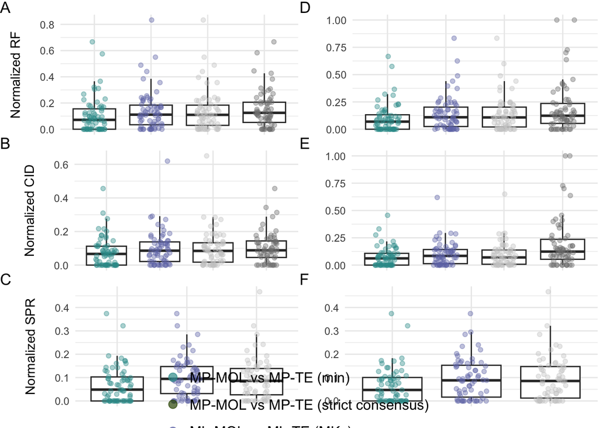

```r
# Plot 3x1
#tiff("Figures/fig4_boxplots_onlyMin.tiff", width = 8.5, height = 9, units = "in", res = 300)
grid.arrange(arrangeGrob(plot_q3_rf + theme(plot.margin = margin(.01,1,1,.01)),
                         plot_q3_rf_extinct + theme(plot.margin = margin(.01,1,1,.01)),
                         plot_q3_cid + theme(plot.margin = margin(.01,1,1,.01)),
                         plot_q3_cid_extinct + theme(plot.margin = margin(.01,1,1,.01)),
                         plot_q3_spr + theme(plot.margin = margin(.01,1,1,.01)),
                         plot_q3_spr_extinct + theme(plot.margin = margin(.01,1,1,.01)),
                        nrow=3, ncol=2),
             legend_grob,
             nrow=2,
             heights= c(20,1))
```

```r
#dev.off()
```

### Q3.1.4 Strict consensus

In this approach, SPR distances are not calculated due to the polytomies.

```r
# Load data
df <- read.csv("Dataset_R_q123_07-26.csv")
df_extant <- df %>% filter(grepl("Extant", Type)) # keep only extant datasets

# Create an empty data frame for RF
q3_rf <- data.frame(value = numeric(0), source = character(0))
# Combine the vectors of RF into the data frame
q3_rf <- rbind(q3_rf, data.frame(value = df_extant$MP_MOLvsTE_NormalizedMinRF, source = base::rep("MP_MOLvsTE_min", length(df_extant$MP_MOLvsTE_NormalizedMinRF))))
q3_rf <- rbind(q3_rf, data.frame(value = df_extant$MP_MOLvsTE_NormalizedRF_strictConsensus, source = base::rep("MP_MOLvsTE_strict", length(df_extant$MP_MOLvsTE_NormalizedRF_strictConsensus))))
q3_rf <- rbind(q3_rf, data.frame(value = df_extant$ML_MOLvsTEASC_NormalizedRF, source = base::rep("ML_MOLvsTEASC", length(df_extant$ML_MOLvsTEASC_NormalizedRF))))
q3_rf <- rbind(q3_rf, data.frame(value = df_extant$ML_MOLvsTEnoASC_NormalizedRF, source = base::rep("ML_MOLvsTEnoASC", length(df_extant$ML_MOLvsTEnoASC_NormalizedRF))))
# Summary of medians
q3_rf %>%
  group_by(source) %>%
  summarise(
    median_value = median(value, na.rm = TRUE),
    sd_value = sd(value, na.rm = TRUE),
    min_value = min(value, na.rm=T),
    max_value = max(value, na.rm=T),
    n = n())
```

```
## # A tibble: 4 × 6
##   source            median_value sd_value min_value max_value     n
##   <chr>                    <dbl>    <dbl>     <dbl>     <dbl> <int>
## 1 ML_MOLvsTEASC           0.111     0.152         0     0.833    63
## 2 ML_MOLvsTEnoASC         0.110     0.154         0     0.833    63
## 3 MP_MOLvsTE_min          0.0714    0.133         0     0.667    63
## 4 MP_MOLvsTE_strict       0.12      0.150         0     0.667    63
```

```r
# Create an empty data frame for CID
q3_cid <- data.frame(value = numeric(0), source = character(0))
# Combine the vectors of CID into the data frame
q3_cid <- rbind(q3_cid, data.frame(value = df_extant$MP_MOLvsTE_NormalizedMinCID, source = base::rep("MP_MOLvsTE_min", length(df_extant$MP_MOLvsTE_NormalizedMinCID))))
q3_cid <- rbind(q3_cid, data.frame(value = df_extant$MP_MOLvsTE_NormalizedCID_strictConsensus, source = base::rep("MP_MOLvsTE_strict", length(df_extant$MP_MOLvsTE_NormalizedCID_strictConsensus))))
q3_cid <- rbind(q3_cid, data.frame(value = df_extant$ML_MOLvsTEASC_NormalizedCID, source = base::rep("ML_MOLvsTEASC", length(df_extant$ML_MOLvsTEASC_NormalizedCID))))
q3_cid <- rbind(q3_cid, data.frame(value = df_extant$ML_MOLvsTEnoASC_NormalizedCID, source = base::rep("ML_MOLvsTEnoASC", length(df_extant$ML_MOLvsTEnoASC_NormalizedCID))))
# Summary of medians
q3_cid %>%
  group_by(source) %>%
  summarise(
    median_value = median(value, na.rm = TRUE),
    sd_value = sd(value, na.rm = TRUE),
    min_value = min(value, na.rm=T),
    max_value = max(value, na.rm=T),
    n = n())
```

```
## # A tibble: 4 × 6
##   source            median_value sd_value min_value max_value     n
##   <chr>                    <dbl>    <dbl>     <dbl>     <dbl> <int>
## 1 ML_MOLvsTEASC           0.0859   0.103          0     0.619    63
## 2 ML_MOLvsTEnoASC         0.0845   0.106          0     0.650    63
## 3 MP_MOLvsTE_min          0.0665   0.0890         0     0.456    63
## 4 MP_MOLvsTE_strict       0.110    0.136          0     0.727    63
```

```r
# Create an empty data frame for CID
q3_spr <- data.frame(value = numeric(0), source = character(0))
# Combine the vectors of CID into the data frame
q3_spr <- rbind(q3_spr, data.frame(value = df_extant$MP_MOLvsTE_NormalizedMinCID, source = base::rep("MP_MOLvsTE_min", length(df_extant$MP_MOLvsTE_NormalizedMinCID))))
q3_spr <- rbind(q3_spr, data.frame(value = df_extant$MP_MOLvsTE_NormalizedCID_strictConsensus, source = base::rep("MP_MOLvsTE_strict", length(df_extant$MP_MOLvsTE_NormalizedCID_strictConsensus))))
q3_spr <- rbind(q3_spr, data.frame(value = df_extant$ML_MOLvsTEASC_NormalizedCID, source = base::rep("ML_MOLvsTEASC", length(df_extant$ML_MOLvsTEASC_NormalizedCID))))
q3_spr <- rbind(q3_spr, data.frame(value = df_extant$ML_MOLvsTEnoASC_NormalizedCID, source = base::rep("ML_MOLvsTEnoASC", length(df_extant$ML_MOLvsTEnoASC_NormalizedCID))))
# Summary of medians
q3_spr %>%
  group_by(source) %>%
  summarise(
    median_value = median(value, na.rm = TRUE),
    sd_value = sd(value, na.rm = TRUE),
    min_value = min(value, na.rm=T),
    max_value = max(value, na.rm=T),
    n = n())
```

```
## # A tibble: 4 × 6
##   source            median_value sd_value min_value max_value     n
##   <chr>                    <dbl>    <dbl>     <dbl>     <dbl> <int>
## 1 ML_MOLvsTEASC           0.0859   0.103          0     0.619    63
## 2 ML_MOLvsTEnoASC         0.0845   0.106          0     0.650    63
## 3 MP_MOLvsTE_min          0.0665   0.0890         0     0.456    63
## 4 MP_MOLvsTE_strict       0.110    0.136          0     0.727    63
```

```r
print("RF")
```

```
## [1] "RF"
```

```r
shapiro.test(q3_rf$value) # p < 0.05, non-parametric
```

```
##
##  Shapiro-Wilk normality test
##
## data:  q3_rf$value
## W = 0.80534, p-value < 2.2e-16
```

```r
print("Kruskal-Wallis: non-parametric test for multiple groups (non-paired values)")
```

```
## [1] "Kruskal-Wallis: non-parametric test for multiple groups (non-paired values)"
```

```r
kruskal.test(q3_rf$value ~ q3_rf$source)
```

```
##
##  Kruskal-Wallis rank sum test
##
## data:  q3_rf$value by q3_rf$source
## Kruskal-Wallis chi-squared = 5.1073, df = 3, p-value = 0.1641
```

```r
print("Friedman: non-parametric test for paired values and multiple groups")
```

```
## [1] "Friedman: non-parametric test for paired values and multiple groups"
```

```r
q3_rf_fri = data.frame(df_extant$MP_MOLvsTE_NormalizedMinRF, df_extant$MP_MOLvsTE_NormalizedRF_strictConsensus, df_extant$ML_MOLvsTEASC_NormalizedRF, df_extant$ML_MOLvsTEnoASC_NormalizedRF)
friedman.test(as.matrix(q3_rf_fri))
```

```
##
##  Friedman rank sum test
##
## data:  as.matrix(q3_rf_fri)
## Friedman chi-squared = 18.719, df = 3, p-value = 0.0003126
```

```r
print("Wilcoxon: pairwise comparisons for paired values")
```

```
## [1] "Wilcoxon: pairwise comparisons for paired values"
```

```r
pairwise.wilcox.test(x=unlist(q3_rf_fri),
                     g=factor(base::rep(names(q3_rf_fri), each = nrow(q3_rf_fri))),
                     paired=TRUE,
                     p.adjust.method="bonferroni")
```

```
##
##  Pairwise comparisons using Wilcoxon signed rank test with continuity correction
##
## data:  unlist(q3_rf_fri) and factor(base::rep(names(q3_rf_fri), each = nrow(q3_rf_fri)))
##
##                                                   df_extant.ML_MOLvsTEASC_NormalizedRF
## df_extant.ML_MOLvsTEnoASC_NormalizedRF            1.000
## df_extant.MP_MOLvsTE_NormalizedMinRF              0.010
## df_extant.MP_MOLvsTE_NormalizedRF_strictConsensus 1.000
##                                                   df_extant.ML_MOLvsTEnoASC_NormalizedRF
## df_extant.ML_MOLvsTEnoASC_NormalizedRF            -
## df_extant.MP_MOLvsTE_NormalizedMinRF              0.018
## df_extant.MP_MOLvsTE_NormalizedRF_strictConsensus 1.000
##                                                   df_extant.MP_MOLvsTE_NormalizedMinRF
## df_extant.ML_MOLvsTEnoASC_NormalizedRF            -
## df_extant.MP_MOLvsTE_NormalizedMinRF              -
## df_extant.MP_MOLvsTE_NormalizedRF_strictConsensus 3.7e-05
##
## P value adjustment method: bonferroni
```

```r
print("CID")
```

```
## [1] "CID"
```

```r
shapiro.test(q3_cid$value) # p < 0.05, non-parametric
```

```
##
##  Shapiro-Wilk normality test
##
## data:  q3_cid$value
## W = 0.79581, p-value < 2.2e-16
```

```r
print("Kruskal-Wallis: non-parametric test for multiple groups")
```

```
## [1] "Kruskal-Wallis: non-parametric test for multiple groups"
```

```r
kruskal.test(q3_cid$value ~ q3_cid$source)
```

```
##
##  Kruskal-Wallis rank sum test
##
## data:  q3_cid$value by q3_cid$source
## Kruskal-Wallis chi-squared = 7.8517, df = 3, p-value = 0.04918
```

```r
print("Friedman: non-parametric test for paired values and multiple groups")
```

```
## [1] "Friedman: non-parametric test for paired values and multiple groups"
```

```r
q3_cid_fri = data.frame(df_extant$MP_MOLvsTE_NormalizedMinCID,  df_extant$MP_MOLvsTE_NormalizedCID_strictConsensus, df_extant$ML_MOLvsTEASC_NormalizedCID, df_extant$ML_MOLvsTEnoASC_NormalizedCID)
friedman.test(as.matrix(q3_cid_fri))
```

```
##
##  Friedman rank sum test
##
## data:  as.matrix(q3_cid_fri)
## Friedman chi-squared = 20.477, df = 3, p-value = 0.0001352
```

```r
print("Wilcoxon: pairwise comparisons for paired values")
```

```
## [1] "Wilcoxon: pairwise comparisons for paired values"
```

```r
pairwise.wilcox.test(x=unlist(q3_cid_fri),
                     g=factor(base::rep(names(q3_cid_fri), each = nrow(q3_cid_fri))),
                     paired=TRUE,
                     p.adjust.method="bonferroni")
```

```
##
##  Pairwise comparisons using Wilcoxon signed rank test with continuity correction
##
## data:  unlist(q3_cid_fri) and factor(base::rep(names(q3_cid_fri), each = nrow(q3_cid_fri)))
##
##                                                    df_extant.ML_MOLvsTEASC_NormalizedCID
## df_extant.ML_MOLvsTEnoASC_NormalizedCID            1.000
## df_extant.MP_MOLvsTE_NormalizedCID_strictConsensus 0.107
## df_extant.MP_MOLvsTE_NormalizedMinCID              0.205
##                                                    df_extant.ML_MOLvsTEnoASC_NormalizedCID
## df_extant.ML_MOLvsTEnoASC_NormalizedCID            -
## df_extant.MP_MOLvsTE_NormalizedCID_strictConsensus 0.076
## df_extant.MP_MOLvsTE_NormalizedMinCID              0.245
##                                                    df_extant.MP_MOLvsTE_NormalizedCID_strictConsensus
## df_extant.ML_MOLvsTEnoASC_NormalizedCID            -
## df_extant.MP_MOLvsTE_NormalizedCID_strictConsensus -
## df_extant.MP_MOLvsTE_NormalizedMinCID              2.5e-07
##
## P value adjustment method: bonferroni
```

```r
print("SPR")
```

```
## [1] "SPR"
```

```r
shapiro.test(q3_spr$value) # p < 0.05, non-parametric
```

```
##
##  Shapiro-Wilk normality test
##
## data:  q3_spr$value
## W = 0.79581, p-value < 2.2e-16
```

```r
print("Kruskal-Wallis: non-parametric test for multiple groups")
```

```
## [1] "Kruskal-Wallis: non-parametric test for multiple groups"
```

```r
kruskal.test(q3_spr$value ~ q3_spr$source)
```

```
##
##  Kruskal-Wallis rank sum test
##
## data:  q3_spr$value by q3_spr$source
## Kruskal-Wallis chi-squared = 7.8517, df = 3, p-value = 0.04918
```

```r
print("Friedman: non-parametric test for paired values and multiple groups")
```

```
## [1] "Friedman: non-parametric test for paired values and multiple groups"
```

```r
q3_spr_fri = data.frame(df_extant$MP_MOLvsTE_NormalizedMinCID,  df_extant$MP_MOLvsTE_NormalizedCID_strictConsensus, df_extant$ML_MOLvsTEASC_NormalizedCID, df_extant$ML_MOLvsTEnoASC_NormalizedCID)
friedman.test(as.matrix(q3_spr_fri))
```

```
##
##  Friedman rank sum test
##
## data:  as.matrix(q3_spr_fri)
## Friedman chi-squared = 20.477, df = 3, p-value = 0.0001352
```

```r
print("Wilcoxon: pairwise comparisons for paired values")
```

```
## [1] "Wilcoxon: pairwise comparisons for paired values"
```

```r
pairwise.wilcox.test(x=unlist(q3_cid_fri),
                     g=factor(base::rep(names(q3_cid_fri), each = nrow(q3_cid_fri))),
                     paired=TRUE,
                     p.adjust.method="bonferroni")
```

```
##
##  Pairwise comparisons using Wilcoxon signed rank test with continuity correction
##
## data:  unlist(q3_cid_fri) and factor(base::rep(names(q3_cid_fri), each = nrow(q3_cid_fri)))
##
##                                                    df_extant.ML_MOLvsTEASC_NormalizedCID
## df_extant.ML_MOLvsTEnoASC_NormalizedCID            1.000
## df_extant.MP_MOLvsTE_NormalizedCID_strictConsensus 0.107
## df_extant.MP_MOLvsTE_NormalizedMinCID              0.205
##                                                    df_extant.ML_MOLvsTEnoASC_NormalizedCID
## df_extant.ML_MOLvsTEnoASC_NormalizedCID            -
## df_extant.MP_MOLvsTE_NormalizedCID_strictConsensus 0.076
## df_extant.MP_MOLvsTE_NormalizedMinCID              0.245
##                                                    df_extant.MP_MOLvsTE_NormalizedCID_strictConsensus
## df_extant.ML_MOLvsTEnoASC_NormalizedCID            -
## df_extant.MP_MOLvsTE_NormalizedCID_strictConsensus -
## df_extant.MP_MOLvsTE_NormalizedMinCID              2.5e-07
##
## P value adjustment method: bonferroni
```

Now we will prepare the data including both datasets with and without morphology-only terminals.

```r
# Load data
df <- read.csv("Dataset_R_q123_07-26.csv")
#df_extinct <- df %>% filter(grepl("Extinct", Type)) # keep only extinct datasets
# Keep only extinct
extinct_datasets <- unique(df$Dataset[df$Type == "Extinct"])
# Append the extant datasets that do not appear among extinct
df_extinct <- df[df$Type == "Extinct" |
                  (df$Type == "Extant" & !(df$Dataset %in% extinct_datasets)), ]

# Create an empty data frame for RF
q3_rf_extinct <- data.frame(value = numeric(0), source = character(0))
# Combine the vectors of RF into the data frame
q3_rf_extinct <- rbind(q3_rf_extinct, data.frame(value = df_extinct$MP_MOLvsTE_NormalizedMinRF, source = base::rep("MP_MOLvsTE_min", length(df_extinct$MP_MOLvsTE_NormalizedMinRF))))
q3_rf_extinct <- rbind(q3_rf_extinct, data.frame(value = df_extinct$MP_MOLvsTE_NormalizedRF_strictConsensus, source = base::rep("MP_MOLvsTE_strict", length(df_extinct$MP_MOLvsTE_NormalizedRF_strictConsensus))))
q3_rf_extinct <- rbind(q3_rf_extinct, data.frame(value = df_extinct$ML_MOLvsTEASC_NormalizedRF, source = base::rep("ML_MOLvsTEASC", length(df_extinct$ML_MOLvsTEASC_NormalizedRF))))
q3_rf_extinct <- rbind(q3_rf_extinct, data.frame(value = df_extinct$ML_MOLvsTEnoASC_NormalizedRF, source = base::rep("ML_MOLvsTEnoASC", length(df_extinct$ML_MOLvsTEnoASC_NormalizedRF))))
# Summary of medians
q3_rf_extinct %>%
  group_by(source) %>%
  summarise(
    median_value = median(value, na.rm = TRUE),
    sd_value = sd(value, na.rm = TRUE),
    min_value = min(value, na.rm=T),
    max_value = max(value, na.rm=T),
    n = n())
```

```
## # A tibble: 4 × 6
##   source            median_value sd_value min_value max_value     n
##   <chr>                    <dbl>    <dbl>     <dbl>     <dbl> <int>
## 1 ML_MOLvsTEASC           0.110     0.159         0     0.833    63
## 2 ML_MOLvsTEnoASC         0.108     0.159         0     0.833    63
## 3 MP_MOLvsTE_min          0.0694    0.132         0     0.667    63
## 4 MP_MOLvsTE_strict       0.140     0.223         0     1        63
```

```r
# Create an empty data frame for CID
q3_cid_extinct <- data.frame(value = numeric(0), source = character(0))
# Combine the vectors of CID into the data frame
q3_cid_extinct <- rbind(q3_cid_extinct, data.frame(value = df_extinct$MP_MOLvsTE_NormalizedMinCID, source = base::rep("MP_MOLvsTE_min", length(df_extinct$MP_MOLvsTE_NormalizedMinCID))))
q3_cid_extinct <- rbind(q3_cid_extinct, data.frame(value = df_extinct$MP_MOLvsTE_NormalizedCID_strictConsensus, source = base::rep("MP_MOLvsTE_strict", length(df_extinct$MP_MOLvsTE_NormalizedCID_strictConsensus))))
q3_cid_extinct <- rbind(q3_cid_extinct, data.frame(value = df_extinct$ML_MOLvsTEASC_NormalizedCID, source = base::rep("ML_MOLvsTEASC", length(df_extinct$ML_MOLvsTEASC_NormalizedCID))))
q3_cid_extinct <- rbind(q3_cid_extinct, data.frame(value = df_extinct$ML_MOLvsTEnoASC_NormalizedCID, source = base::rep("ML_MOLvsTEnoASC", length(df_extinct$ML_MOLvsTEnoASC_NormalizedCID))))
# Summary of medians
q3_cid_extinct %>%
  group_by(source) %>%
  summarise(
    median_value = median(value, na.rm = TRUE),
    sd_value = sd(value, na.rm = TRUE),
    min_value = min(value, na.rm=T),
    max_value = max(value, na.rm=T),
    n = n())
```

```
## # A tibble: 4 × 6
##   source            median_value sd_value min_value max_value     n
##   <chr>                    <dbl>    <dbl>     <dbl>     <dbl> <int>
## 1 ML_MOLvsTEASC           0.0845   0.106          0     0.619    63
## 2 ML_MOLvsTEnoASC         0.0702   0.109          0     0.650    63
## 3 MP_MOLvsTE_min          0.0616   0.0898         0     0.456    63
## 4 MP_MOLvsTE_strict       0.124    0.223          0     1        63
```

```r
# Create an empty data frame for SPR
q3_spr_extinct <- data.frame(value = numeric(0), source = character(0))
# Combine the vectors of CID into the data frame
q3_spr_extinct <- rbind(q3_spr_extinct, data.frame(value = df_extinct$MP_MOLvsTE_NormalizedMinCID, source = base::rep("MP_MOLvsTE_min", length(df_extinct$MP_MOLvsTE_NormalizedMinCID))))
q3_spr_extinct <- rbind(q3_spr_extinct, data.frame(value = df_extinct$MP_MOLvsTE_NormalizedCID_strictConsensus, source = base::rep("MP_MOLvsTE_strict", length(df_extinct$MP_MOLvsTE_NormalizedCID_strictConsensus))))
q3_spr_extinct <- rbind(q3_spr_extinct, data.frame(value = df_extinct$ML_MOLvsTEASC_NormalizedCID, source = base::rep("ML_MOLvsTEASC", length(df_extinct$ML_MOLvsTEASC_NormalizedCID))))
q3_spr_extinct <- rbind(q3_spr_extinct, data.frame(value = df_extinct$ML_MOLvsTEnoASC_NormalizedCID, source = base::rep("ML_MOLvsTEnoASC", length(df_extinct$ML_MOLvsTEnoASC_NormalizedCID))))
# Summary of medians
q3_cid_extinct %>%
  group_by(source) %>%
  summarise(
    median_value = median(value, na.rm = TRUE),
    sd_value = sd(value, na.rm = TRUE),
    min_value = min(value, na.rm=T),
    max_value = max(value, na.rm=T),
    n = n())
```

```
## # A tibble: 4 × 6
##   source            median_value sd_value min_value max_value     n
##   <chr>                    <dbl>    <dbl>     <dbl>     <dbl> <int>
## 1 ML_MOLvsTEASC           0.0845   0.106          0     0.619    63
## 2 ML_MOLvsTEnoASC         0.0702   0.109          0     0.650    63
## 3 MP_MOLvsTE_min          0.0616   0.0898         0     0.456    63
## 4 MP_MOLvsTE_strict       0.124    0.223          0     1        63
```

```r
print("RF")
```

```
## [1] "RF"
```

```r
shapiro.test(q3_rf_extinct$value) # p < 0.05, non-parametric
```

```
##
##  Shapiro-Wilk normality test
##
## data:  q3_rf_extinct$value
## W = 0.76353, p-value < 2.2e-16
```

```r
print("Kruskal-Wallis: non-parametric test for multiple groups (non-paired values)")
```

```
## [1] "Kruskal-Wallis: non-parametric test for multiple groups (non-paired values)"
```

```r
kruskal.test(q3_rf_extinct$value ~ q3_rf_extinct$source)
```

```
##
##  Kruskal-Wallis rank sum test
##
## data:  q3_rf_extinct$value by q3_rf_extinct$source
## Kruskal-Wallis chi-squared = 9.4221, df = 3, p-value = 0.02417
```

```r
print("Friedman: non-parametric test for paired values and multiple groups")
```

```
## [1] "Friedman: non-parametric test for paired values and multiple groups"
```

```r
q3_rf_fri = data.frame(df_extinct$MP_MOLvsTE_NormalizedMinRF, df_extinct$MP_MOLvsTE_NormalizedRF_strictConsensus, df_extinct$ML_MOLvsTEASC_NormalizedRF, df_extinct$ML_MOLvsTEnoASC_NormalizedRF)
friedman.test(as.matrix(q3_rf_fri))
```

```
##
##  Friedman rank sum test
##
## data:  as.matrix(q3_rf_fri)
## Friedman chi-squared = 30.185, df = 3, p-value = 1.262e-06
```

```r
print("Wilcoxon: pairwise comparisons for paired values")
```

```
## [1] "Wilcoxon: pairwise comparisons for paired values"
```

```r
pairwise.wilcox.test(x=unlist(q3_rf_fri),
                     g=factor(base::rep(names(q3_rf_fri), each = nrow(q3_rf_fri))),
                     paired=TRUE,
                     p.adjust.method="bonferroni")
```

```
##
##  Pairwise comparisons using Wilcoxon signed rank test with continuity correction
##
## data:  unlist(q3_rf_fri) and factor(base::rep(names(q3_rf_fri), each = nrow(q3_rf_fri)))
##
##                                                    df_extinct.ML_MOLvsTEASC_NormalizedRF
## df_extinct.ML_MOLvsTEnoASC_NormalizedRF            1.0000
## df_extinct.MP_MOLvsTE_NormalizedMinRF              0.0027
## df_extinct.MP_MOLvsTE_NormalizedRF_strictConsensus 0.5845
##                                                    df_extinct.ML_MOLvsTEnoASC_NormalizedRF
## df_extinct.ML_MOLvsTEnoASC_NormalizedRF            -
## df_extinct.MP_MOLvsTE_NormalizedMinRF              0.0052
## df_extinct.MP_MOLvsTE_NormalizedRF_strictConsensus 0.3666
##                                                    df_extinct.MP_MOLvsTE_NormalizedMinRF
## df_extinct.ML_MOLvsTEnoASC_NormalizedRF            -
## df_extinct.MP_MOLvsTE_NormalizedMinRF              -
## df_extinct.MP_MOLvsTE_NormalizedRF_strictConsensus 2.3e-07
##
## P value adjustment method: bonferroni
```

```r
print("CID")
```

```
## [1] "CID"
```

```r
shapiro.test(q3_cid_extinct$value) # p < 0.05, non-parametric
```

```
##
##  Shapiro-Wilk normality test
##
## data:  q3_cid_extinct$value
## W = 0.70508, p-value < 2.2e-16
```

```r
print("Kruskal-Wallis: non-parametric test for multiple groups")
```

```
## [1] "Kruskal-Wallis: non-parametric test for multiple groups"
```

```r
kruskal.test(q3_cid_extinct$value ~ q3_cid_extinct$source)
```

```
##
##  Kruskal-Wallis rank sum test
##
## data:  q3_cid_extinct$value by q3_cid_extinct$source
## Kruskal-Wallis chi-squared = 15.542, df = 3, p-value = 0.001407
```

```r
print("Friedman: non-parametric test for paired values and multiple groups")
```

```
## [1] "Friedman: non-parametric test for paired values and multiple groups"
```

```r
q3_cid_fri = data.frame(df_extinct$MP_MOLvsTE_NormalizedMinCID, df_extinct$MP_MOLvsTE_NormalizedCID_strictConsensus, df_extinct$ML_MOLvsTEASC_NormalizedCID, df_extinct$ML_MOLvsTEnoASC_NormalizedCID)
friedman.test(as.matrix(q3_cid_fri))
```

```
##
##  Friedman rank sum test
##
## data:  as.matrix(q3_cid_fri)
## Friedman chi-squared = 33.48, df = 3, p-value = 2.551e-07
```

```r
print("Wilcoxon: pairwise comparisons for paired values")
```

```
## [1] "Wilcoxon: pairwise comparisons for paired values"
```

```r
q3_cid_fri = data.frame(df_extinct$MP_MOLvsTE_NormalizedMinCID,df_extinct$MP_MOLvsTE_NormalizedCID_strictConsensus, df_extinct$ML_MOLvsTEASC_NormalizedCID, df_extinct$ML_MOLvsTEnoASC_NormalizedCID)
pairwise.wilcox.test(x=unlist(q3_cid_fri),
                     g=factor(base::rep(names(q3_cid_fri), each = nrow(q3_cid_fri))),
                     paired=TRUE,
                     p.adjust.method="bonferroni")
```

```
##
##  Pairwise comparisons using Wilcoxon signed rank test with continuity correction
##
## data:  unlist(q3_cid_fri) and factor(base::rep(names(q3_cid_fri), each = nrow(q3_cid_fri)))
##
##                                                     df_extinct.ML_MOLvsTEASC_NormalizedCID
## df_extinct.ML_MOLvsTEnoASC_NormalizedCID            1.0000
## df_extinct.MP_MOLvsTE_NormalizedCID_strictConsensus 0.0034
## df_extinct.MP_MOLvsTE_NormalizedMinCID              0.0649
##                                                     df_extinct.ML_MOLvsTEnoASC_NormalizedCID
## df_extinct.ML_MOLvsTEnoASC_NormalizedCID            -
## df_extinct.MP_MOLvsTE_NormalizedCID_strictConsensus 0.0022
## df_extinct.MP_MOLvsTE_NormalizedMinCID              0.1086
##                                                     df_extinct.MP_MOLvsTE_NormalizedCID_strictConsensus
## df_extinct.ML_MOLvsTEnoASC_NormalizedCID            -
## df_extinct.MP_MOLvsTE_NormalizedCID_strictConsensus -
## df_extinct.MP_MOLvsTE_NormalizedMinCID              5.1e-09
##
## P value adjustment method: bonferroni
```

```r
print("SPR")
```

```
## [1] "SPR"
```

```r
shapiro.test(q3_spr_extinct$value) # p < 0.05, non-parametric
```

```
##
##  Shapiro-Wilk normality test
##
## data:  q3_spr_extinct$value
## W = 0.70508, p-value < 2.2e-16
```

```r
print("Kruskal-Wallis: non-parametric test for multiple groups")
```

```
## [1] "Kruskal-Wallis: non-parametric test for multiple groups"
```

```r
kruskal.test(q3_spr_extinct$value ~ q3_spr_extinct$source)
```

```
##
##  Kruskal-Wallis rank sum test
##
## data:  q3_spr_extinct$value by q3_spr_extinct$source
## Kruskal-Wallis chi-squared = 15.542, df = 3, p-value = 0.001407
```

```r
print("Friedman: non-parametric test for paired values and multiple groups")
```

```
## [1] "Friedman: non-parametric test for paired values and multiple groups"
```

```r
q3_cid_fri = data.frame(df_extinct$MP_MOLvsTE_NormalizedMinCID, df_extinct$MP_MOLvsTE_NormalizedCID_strictConsensus, df_extinct$ML_MOLvsTEASC_NormalizedCID, df_extinct$ML_MOLvsTEnoASC_NormalizedCID)
friedman.test(as.matrix(q3_cid_fri))
```

```
##
##  Friedman rank sum test
##
## data:  as.matrix(q3_cid_fri)
## Friedman chi-squared = 33.48, df = 3, p-value = 2.551e-07
```

```r
print("Wilcoxon: pairwise comparisons for paired values")
```

```
## [1] "Wilcoxon: pairwise comparisons for paired values"
```

```r
q3_cid_fri = data.frame(df_extinct$MP_MOLvsTE_NormalizedMinCID,df_extinct$MP_MOLvsTE_NormalizedCID_strictConsensus, df_extinct$ML_MOLvsTEASC_NormalizedCID, df_extinct$ML_MOLvsTEnoASC_NormalizedCID)
pairwise.wilcox.test(x=unlist(q3_cid_fri),
                     g=factor(base::rep(names(q3_cid_fri), each = nrow(q3_cid_fri))),
                     paired=TRUE,
                     p.adjust.method="bonferroni")
```

```
##
##  Pairwise comparisons using Wilcoxon signed rank test with continuity correction
##
## data:  unlist(q3_cid_fri) and factor(base::rep(names(q3_cid_fri), each = nrow(q3_cid_fri)))
##
##                                                     df_extinct.ML_MOLvsTEASC_NormalizedCID
## df_extinct.ML_MOLvsTEnoASC_NormalizedCID            1.0000
## df_extinct.MP_MOLvsTE_NormalizedCID_strictConsensus 0.0034
## df_extinct.MP_MOLvsTE_NormalizedMinCID              0.0649
##                                                     df_extinct.ML_MOLvsTEnoASC_NormalizedCID
## df_extinct.ML_MOLvsTEnoASC_NormalizedCID            -
## df_extinct.MP_MOLvsTE_NormalizedCID_strictConsensus 0.0022
## df_extinct.MP_MOLvsTE_NormalizedMinCID              0.1086
##                                                     df_extinct.MP_MOLvsTE_NormalizedCID_strictConsensus
## df_extinct.ML_MOLvsTEnoASC_NormalizedCID            -
## df_extinct.MP_MOLvsTE_NormalizedCID_strictConsensus -
## df_extinct.MP_MOLvsTE_NormalizedMinCID              5.1e-09
##
## P value adjustment method: bonferroni
```

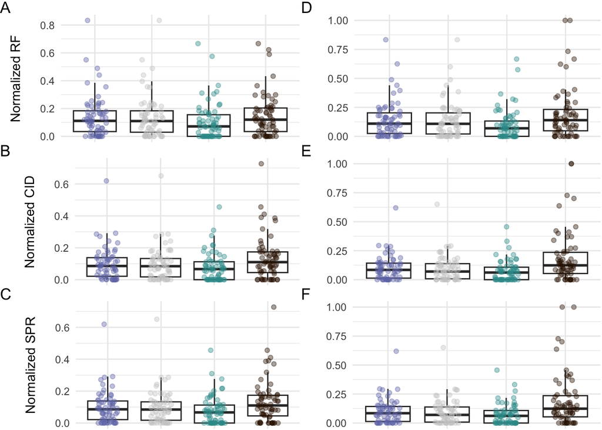

```r
# Set order of comparisons
q3_rf$source <- factor(q3_rf$source, levels = c("ML_MOLvsTEASC", "ML_MOLvsTEnoASC", "MP_MOLvsTE_min", "MP_MOLvsTE_strict"))
q3_cid$source <- factor(q3_cid$source, levels = c("ML_MOLvsTEASC", "ML_MOLvsTEnoASC", "MP_MOLvsTE_min", "MP_MOLvsTE_strict"))

# Set colors
custom_palette <- c("MP_MOLvsTE_min" = "#339999", "MP_MOLvsTE_strict"="#331100", "ML_MOLvsTEASC" = "#6f77b4", "ML_MOLvsTEnoASC" = "#cccccc")
# Create custom legend labels
custom_labels <- c(
  "ML_MOLvsTEASC" = "ML-MOL vs ML-TE MKv",
  "ML_MOLvsTEnoASC" = "ML-MOL vs ML-TE MK",
  "MP_MOLvsTE_min" = "MP-MOL vs MP-TE (min)",
  "MP_MOLvsTE_strict"= "MP-MOL vs MP-TE (strict consensus)"
)

# Boxplot Normalized RF
plot_q3_rf = ggplot(q3_rf, aes(x = source, y = value)) +
  geom_boxplot(outlier.shape = NA) +  # Create boxplot without default outliers
  geom_jitter(aes(color = source), alpha = .4, width = 0.2) +  # Add transparent dots
  labs(x = "", y = "Normalized RF\n", tag="A") +
  theme_minimal() +
  theme(axis.title.x = element_blank(),axis.text.x = element_blank(), axis.ticks.x = element_blank(), legend.position = "none") +  # Hide legend if not needed
  scale_color_manual(values = custom_palette, labels = custom_labels)
# Boxplot CID
plot_q3_cid = ggplot(q3_cid, aes(x = source, y = value)) +
  geom_boxplot(outlier.shape = NA) +  # Create boxplot without default outliers
  geom_jitter(aes(color = source), alpha = .4, width = 0.2) +  # Add transparent dots
  labs(x = "", y = "\nNormalized CID\n", tag="B") +
  theme_minimal() +
  theme(axis.title.x = element_blank(),axis.text.x = element_blank(),axis.ticks.x = element_blank(),legend.position = "none") +  # Hide legend if not needed
  scale_color_manual(values = custom_palette, labels = custom_labels)
# Boxplot SPR
plot_q3_spr = ggplot(q3_spr, aes(x = source, y = value)) +
  geom_boxplot(outlier.shape = NA) +  # Create boxplot without default outliers
  geom_jitter(aes(color = source), alpha = .4, width = 0.2) +  # Add transparent dots
  labs(x = "", y = "\nNormalized SPR\n", tag="C") +
  theme_minimal() +
  theme(axis.title.x = element_blank(),axis.text.x = element_blank(),legend.position = "none", axis.ticks.x = element_blank(),legend.title = element_blank())+
#theme(axis.text.x = element_blank(),legend.position = "none") +  # Hide legend if not needed
  scale_color_manual(values = custom_palette, labels = custom_labels)

q3_rf_extinct$source <- factor(q3_rf_extinct$source, levels = c("ML_MOLvsTEASC", "ML_MOLvsTEnoASC", "MP_MOLvsTE_min", "MP_MOLvsTE_strict"))
q3_cid_extinct$source <- factor(q3_cid_extinct$source, levels = c("ML_MOLvsTEASC", "ML_MOLvsTEnoASC", "MP_MOLvsTE_min", "MP_MOLvsTE_strict"))

# Boxplot Normalized RF
plot_q3_rf_extinct = ggplot(q3_rf_extinct, aes(x = source, y = value)) +
  geom_boxplot(outlier.shape = NA) +  # Create boxplot without default outliers
  geom_jitter(aes(color = source), alpha = .4, width = 0.2) +  # Add transparent dots
  labs(x = "", y = "", tag="D") +
  theme_minimal() +
  theme(axis.title.x = element_blank(),axis.text.x = element_blank(), axis.ticks.x = element_blank(),legend.position = "none") +  # Hide legend if not needed
  scale_color_manual(values = custom_palette, labels = custom_labels)
# Boxplot CID
plot_q3_cid_extinct = ggplot(q3_cid_extinct, aes(x = source, y = value)) +
  geom_boxplot(outlier.shape = NA) +  # Create boxplot without default outliers
  geom_jitter(aes(color = source), alpha = .4, width = 0.2) +  # Add transparent dots
  labs(x = "", y = "", tag="E") +
  theme_minimal() +
  theme(axis.title.x = element_blank(),axis.text.x = element_blank(),axis.ticks.x = element_blank(),legend.position = "none") +  # Hide legend if not needed
  scale_color_manual(values = custom_palette, labels = custom_labels)
# Boxplot SPR
plot_q3_spr_extinct = ggplot(q3_spr_extinct, aes(x = source, y = value)) +
  geom_boxplot(outlier.shape = NA) +  # Create boxplot without default outliers
  geom_jitter(aes(color = source), alpha = .4, width = 0.2) +  # Add transparent dots
  labs(x = "", y = "", tag="F") +
  theme_minimal() +
  theme(axis.title.x = element_blank(),axis.text.x = element_blank(),legend.position = "none", axis.ticks.x = element_blank(),legend.title = element_blank())+
#theme(axis.text.x = element_blank(),legend.position = "none") +  # Hide legend if not needed
  scale_color_manual(values = custom_palette, labels = custom_labels)

legend <- cowplot::get_legend(
  plot_q3_rf +
    theme(
      legend.position = "bottom",
      legend.text = element_text(size = 5.5),
      legend.key.size = unit(0.4, "cm"),
      legend.title = element_blank()
    )
)
plots = grid.arrange(plot_q3_rf + theme(plot.margin = margin(.01,1,1,.01)),
             plot_q3_rf_extinct + theme(plot.margin = margin(.01,1,1,.01)),
             plot_q3_cid + theme(plot.margin = margin(.001,1,1,.01)),
             plot_q3_cid_extinct + theme(plot.margin = margin(.001,1,1,.01)),
             plot_q3_spr + theme(plot.margin = margin(.001,1,1,.01)),
             plot_q3_spr_extinct + theme(plot.margin = margin(.001,1,1,.01)),
             nrow=3, ncol=2)
```

```r
# Plot 2x1
tiff("Figures/fig4_boxplots_strictConsensus.tiff", width = 7, height = 6, units = "in", res = 300)
plots
```

```r
cowplot::plot_grid(
  plots,
  legend,
  ncol = 1,
  rel_heights = c(1, 0.12)
)
dev.off()
```

### Q3.1.5 Statistical interaction with size (Table S5)

The goal of this analysis is assessing a possible statistical interaction between proportion of morphological characters and RF/CID/SPR distances between MOL and TE trees across optimality criteria.

```r
df <- read.csv("Dataset_R_q123_07-26.csv")
df_extant <- df %>% filter(grepl("Extant", Type)) # keep only extant datasets

# Format dataframe
df <- df_extant
df_long <- bind_rows(
  data.frame(
    Dataset = df_extant$Dataset,
    Morph = df_extant$X.Morph.Total,
    Criterion = "MP_min",
    RF  = df_extant$MP_MOLvsTE_NormalizedMinRF,
    CID = df_extant$MP_MOLvsTE_NormalizedMinCID,
    SPR = df_extant$MP_MOLvsTE_NormalizedMinSPR
  ),
  data.frame(
    Dataset = df_extant$Dataset,
    Morph = df_extant$X.Morph.Total,
    Criterion = "MP_strict",
    RF  = df_extant$MP_MOLvsTE_NormalizedRF_strictConsensus,
    CID = df_extant$MP_MOLvsTE_NormalizedCID_strictConsensus,
    SPR = NA
  ),
  data.frame(
    Dataset = df_extant$Dataset,
    Morph = df_extant$X.Morph.Total,
    Criterion = "ML_MK",
    RF  = df_extant$ML_MOLvsTEnoASC_NormalizedRF,
    CID = df_extant$ML_MOLvsTEnoASC_NormalizedCID,
    SPR = df_extant$ML_MOLvsTEnoASC_NormalizedSPR
  ),
  data.frame(
    Dataset = df_extant$Dataset,
    Morph = df_extant$X.Morph.Total,
    Criterion = "ML_MKv",
    RF  = df_extant$ML_MOLvsTEASC_NormalizedRF,
    CID = df_extant$ML_MOLvsTEASC_NormalizedCID,
    SPR = df_extant$ML_MOLvsTEASC_NormalizedSPR
  )
)
df_long$Criterion <- factor(df_long$Criterion)
```

```r
# Models RF ~ Criterion and %MorphoCharacters
# With interaction
m_RF <- lmer(
    RF ~ Morph * Criterion + (1 | Dataset),
    data = df_long
)
# Without interaction
m_RF0 <- lmer(
    RF ~ Morph + Criterion + (1 | Dataset),
    data = df_long
)

# Model selection
print("Model selection considering RF as response variable")
```

```
## [1] "Model selection considering RF as response variable"
```

```r
anova(m_RF0, m_RF)
```

```
## refitting model(s) with ML (instead of REML)
```

```
## Data: df_long
## Models:
## m_RF0: RF ~ Morph + Criterion + (1 | Dataset)
## m_RF: RF ~ Morph * Criterion + (1 | Dataset)
##       npar     AIC    BIC logLik -2*log(L)  Chisq Df Pr(>Chisq)
## m_RF0    7 -526.91 -502.2 270.45   -540.91
## m_RF    10 -521.69 -486.4 270.85   -541.69 0.7814  3     0.8539
```

```r
# Best model
print("Best model considering RF as response variable")
```

```
## [1] "Best model considering RF as response variable"
```

```r
summary(m_RF0)
```

```
## Linear mixed model fit by REML. t-tests use Satterthwaite's method [
## lmerModLmerTest]
## Formula: RF ~ Morph + Criterion + (1 | Dataset)
##    Data: df_long
##
## REML criterion at convergence: -512.6
##
## Scaled residuals:
##     Min      1Q  Median      3Q     Max
## -2.2150 -0.4737 -0.1234  0.4088  3.3647
##
## Random effects:
##  Groups   Name        Variance Std.Dev.
##  Dataset  (Intercept) 0.015189 0.12324
##  Residual             0.003335 0.05775
## Number of obs: 252, groups:  Dataset, 63
##
## Fixed effects:
##                      Estimate Std. Error         df t value Pr(>|t|)
## (Intercept)          0.082346   0.023069  71.081156   3.570 0.000646 ***
## Morph                2.243863   0.608076  61.000000   3.690 0.000480 ***
## CriterionML_MKv      0.003811   0.010290 186.000000   0.370 0.711498
## CriterionMP_min     -0.032748   0.010290 186.000000  -3.183 0.001711 **
## CriterionMP_strict   0.008652   0.010290 186.000000   0.841 0.401537
## ---
## Signif. codes:  0 '***' 0.001 '**' 0.01 '*' 0.05 '.' 0.1 ' ' 1
##
## Correlation of Fixed Effects:
##             (Intr) Morph  CML_MK CrtrnMP_m
## Morph       -0.669
## CrtrnML_MKv -0.223  0.000
## CritrnMP_mn -0.223  0.000  0.500
## CrtrnMP_str -0.223  0.000  0.500  0.500
```

```r
# Pairwise comparisons
print("Pairwise comparisons considering RF as response variable")
```

```
## [1] "Pairwise comparisons considering RF as response variable"
```

```r
emmeans(m_RF0, pairwise ~ Criterion, adjust = "tukey")
```

```
## $emmeans
##  Criterion emmean     SE   df lower.CL upper.CL
##  ML_MK      0.139 0.0171 80.9   0.1052    0.173
##  ML_MKv     0.143 0.0171 80.9   0.1090    0.177
##  MP_min     0.107 0.0171 80.9   0.0724    0.141
##  MP_strict  0.148 0.0171 80.9   0.1138    0.182
##
## Degrees-of-freedom method: kenward-roger
## Confidence level used: 0.95
##
## $contrasts
##  contrast           estimate     SE  df t.ratio p.value
##  ML_MK - ML_MKv     -0.00381 0.0103 186  -0.370  0.9826
##  ML_MK - MP_min      0.03275 0.0103 186   3.183  0.0092
##  ML_MK - MP_strict  -0.00865 0.0103 186  -0.841  0.8349
##  ML_MKv - MP_min     0.03656 0.0103 186   3.553  0.0027
##  ML_MKv - MP_strict -0.00484 0.0103 186  -0.470  0.9655
##  MP_min - MP_strict -0.04140 0.0103 186  -4.023  0.0005
##
## Degrees-of-freedom method: kenward-roger
## P value adjustment: tukey method for comparing a family of 4 estimates
```

```r
# Models CID ~ Criterion and %MorphoCharacters
# With interaction
m_CID <- lmer(
    CID ~ Morph * Criterion + (1 | Dataset),
    data = df_long
)
# Without interaction
m_CID0 <- lmer(
    CID ~ Morph + Criterion + (1 | Dataset),
    data = df_long
)

# Model selection
print("Model selection considering CID as response variable")
```

```
## [1] "Model selection considering CID as response variable"
```

```r
anova(m_CID0, m_CID)
```

```
## refitting model(s) with ML (instead of REML)
```

```
## Data: df_long
## Models:
## m_CID0: CID ~ Morph + Criterion + (1 | Dataset)
## m_CID: CID ~ Morph * Criterion + (1 | Dataset)
##        npar     AIC     BIC logLik -2*log(L)  Chisq Df Pr(>Chisq)
## m_CID0    7 -566.08 -541.37 290.04   -580.08
## m_CID    10 -562.89 -527.59 291.44   -582.89 2.8126  3     0.4214
```

```r
# Best model
print("Best model considering CID as response variable")
```

```
## [1] "Best model considering CID as response variable"
```

```r
summary(m_CID0)
```

```
## Linear mixed model fit by REML. t-tests use Satterthwaite's method [
## lmerModLmerTest]
## Formula: CID ~ Morph + Criterion + (1 | Dataset)
##    Data: df_long
##
## REML criterion at convergence: -550.5
##
## Scaled residuals:
##     Min      1Q  Median      3Q     Max
## -2.2830 -0.4734 -0.0545  0.3006  5.8633
##
## Random effects:
##  Groups   Name        Variance Std.Dev.
##  Dataset  (Intercept) 0.007056 0.08400
##  Residual             0.003430 0.05856
## Number of obs: 252, groups:  Dataset, 63
##
## Fixed effects:
##                     Estimate Std. Error        df t value Pr(>|t|)
## (Intercept)          0.05726    0.01685  82.43565   3.397 0.001050 **
## Morph                1.53994    0.42735  60.99999   3.603 0.000632 ***
## CriterionML_MKv      0.00226    0.01043 186.00000   0.217 0.828772
## CriterionMP_min     -0.01938    0.01043 186.00000  -1.857 0.064842 .
## CriterionMP_strict   0.03620    0.01043 186.00000   3.469 0.000649 ***
## ---
## Signif. codes:  0 '***' 0.001 '**' 0.01 '*' 0.05 '.' 0.1 ' ' 1
##
## Correlation of Fixed Effects:
##             (Intr) Morph  CML_MK CrtrnMP_m
## Morph       -0.643
## CrtrnML_MKv -0.310  0.000
## CritrnMP_mn -0.310  0.000  0.500
## CrtrnMP_str -0.310  0.000  0.500  0.500
```

```r
# Pairwise comparisons
print("Pairwise comparisons considering CID as response variable")
```

```
## [1] "Pairwise comparisons considering CID as response variable"
```

```r
emmeans(m_CID0, pairwise ~ Criterion, adjust = "tukey")
```

```
## $emmeans
##  Criterion emmean     SE  df lower.CL upper.CL
##  ML_MK     0.0963 0.0129 104   0.0708    0.122
##  ML_MKv    0.0986 0.0129 104   0.0730    0.124
##  MP_min    0.0770 0.0129 104   0.0514    0.103
##  MP_strict 0.1325 0.0129 104   0.1070    0.158
##
## Degrees-of-freedom method: kenward-roger
## Confidence level used: 0.95
##
## $contrasts
##  contrast           estimate     SE  df t.ratio p.value
##  ML_MK - ML_MKv     -0.00226 0.0104 186  -0.217  0.9964
##  ML_MK - MP_min      0.01938 0.0104 186   1.857  0.2502
##  ML_MK - MP_strict  -0.03620 0.0104 186  -3.469  0.0036
##  ML_MKv - MP_min     0.02164 0.0104 186   2.074  0.1655
##  ML_MKv - MP_strict -0.03394 0.0104 186  -3.252  0.0074
##  MP_min - MP_strict -0.05558 0.0104 186  -5.326 <0.0001
##
## Degrees-of-freedom method: kenward-roger
## P value adjustment: tukey method for comparing a family of 4 estimates
```

```r
# Models SPR ~ Criterion and %MorphoCharacters
# With interaction
m_SPR <- lmer(
    SPR ~ Morph * Criterion + (1 | Dataset),
    data = df_long
)
# Without interaction
m_SPR0 <- lmer(
    SPR ~ Morph + Criterion + (1 | Dataset),
    data = df_long
)

# Model selection
print("Model selection considering SPR as response variable")
```

```
## [1] "Model selection considering SPR as response variable"
```

```r
anova(m_SPR0, m_SPR)
```

```
## refitting model(s) with ML (instead of REML)
```

```
## Data: df_long
## Models:
## m_SPR0: SPR ~ Morph + Criterion + (1 | Dataset)
## m_SPR: SPR ~ Morph * Criterion + (1 | Dataset)
##        npar     AIC     BIC logLik -2*log(L)  Chisq Df Pr(>Chisq)
## m_SPR0    6 -565.32 -545.87 288.66   -577.32
## m_SPR     8 -562.38 -536.44 289.19   -578.38 1.0559  2     0.5898
```

```r
# Best model
print("Best model considering SPR as response variable")
```

```
## [1] "Best model considering SPR as response variable"
```

```r
summary(m_SPR0)
```

```
## Linear mixed model fit by REML. t-tests use Satterthwaite's method [
## lmerModLmerTest]
## Formula: SPR ~ Morph + Criterion + (1 | Dataset)
##    Data: df_long
##
## REML criterion at convergence: -552.4
##
## Scaled residuals:
##      Min       1Q   Median       3Q      Max
## -2.53424 -0.49506 -0.04167  0.43886  2.71974
##
## Random effects:
##  Groups   Name        Variance Std.Dev.
##  Dataset  (Intercept) 0.004572 0.06762
##  Residual             0.001225 0.03500
## Number of obs: 189, groups:  Dataset, 63
##
## Fixed effects:
##                   Estimate Std. Error         df t value Pr(>|t|)
## (Intercept)       0.060291   0.012886  71.515388   4.679 1.33e-05 ***
## Morph             1.400448   0.339034  60.999997   4.131 0.000112 ***
## CriterionML_MKv   0.002332   0.006236 124.000001   0.374 0.709071
## CriterionMP_min  -0.026093   0.006236 124.000001  -4.184 5.37e-05 ***
## ---
## Signif. codes:  0 '***' 0.001 '**' 0.01 '*' 0.05 '.' 0.1 ' ' 1
##
## Correlation of Fixed Effects:
##             (Intr) Morph  CML_MK
## Morph       -0.668
## CrtrnML_MKv -0.242  0.000
## CritrnMP_mn -0.242  0.000  0.500
```

```r
# Pairwise comparisons
print("Pairwise comparisons considering SPR as response variable")
```

```
## [1] "Pairwise comparisons considering SPR as response variable"
```

```r
emmeans(m_SPR0, pairwise ~ Criterion, adjust = "tukey")
```

```
## $emmeans
##  Criterion emmean      SE   df lower.CL upper.CL
##  ML_MK     0.0958 0.00959 81.6   0.0767   0.1149
##  ML_MKv    0.0982 0.00959 81.6   0.0791   0.1172
##  MP_min    0.0697 0.00959 81.6   0.0507   0.0888
##
## Degrees-of-freedom method: kenward-roger
## Confidence level used: 0.95
##
## $contrasts
##  contrast        estimate      SE  df t.ratio p.value
##  ML_MK - ML_MKv  -0.00233 0.00624 124  -0.374  0.9259
##  ML_MK - MP_min   0.02609 0.00624 124   4.184  0.0002
##  ML_MKv - MP_min  0.02843 0.00624 124   4.558 <0.0001
##
## Degrees-of-freedom method: kenward-roger
## P value adjustment: tukey method for comparing a family of 3 estimates
```

## Q3.2 Number of polytomies

One importance difference, however, is the fact that trees were always binary in ML trees, whereas the addition of morphological evidence can maintain, increase or decrease resolution of MP trees.

### Q3.2.1 Extant

```r
# Load data
df <- read.csv("Dataset_R_q123_07-26.csv")
df_extant <- df %>% filter(grepl("Extant", Type)) # keep only extant datasets

print("MP: Number of datasets in which the number of politomies is higher in TE than MOL")
```

```
## [1] "MP: Number of datasets in which the number of politomies is higher in TE than MOL"
```

```r
sum((df_extant$MP_nPolytomiesTE - df_extant$MP_nPolytomiesMOL) > 0)
```

```
## [1] 16
```

```r
print("MP: Number of datasets in which the number of politomies is higher in MOL than TE")
```

```
## [1] "MP: Number of datasets in which the number of politomies is higher in MOL than TE"
```

```r
sum((df_extant$MP_nPolytomiesTE - df_extant$MP_nPolytomiesMOL) < 0)
```

```
## [1] 15
```

```r
print("MP: Number of datasets in which the number of politomies is equal in MOL and TE")
```

```
## [1] "MP: Number of datasets in which the number of politomies is equal in MOL and TE"
```

```r
sum((df_extant$MP_nPolytomiesTE - df_extant$MP_nPolytomiesMOL) == 0)
```

```
## [1] 32
```

```r
cat("\n")
```

```r
print("MP MOL: Mean no. polytomies")
```

```
## [1] "MP MOL: Mean no. polytomies"
```

```r
mean(df_extant$MP_nPolytomiesMOL)
```

```
## [1] 2.730159
```

```r
print("MP MOL: SD no. polytomies")
```

```
## [1] "MP MOL: SD no. polytomies"
```

```r
sd(df_extant$MP_nPolytomiesMOL)
```

```
## [1] 5.168785
```

```r
print("MP MOL: Min no. polytomies")
```

```
## [1] "MP MOL: Min no. polytomies"
```

```r
min(df_extant$MP_nPolytomiesMOL)
```

```
## [1] 0
```

```r
print("MP MOL: Max no. polytomies")
```

```
## [1] "MP MOL: Max no. polytomies"
```

```r
max(df_extant$MP_nPolytomiesMOL)
```

```
## [1] 31
```

```r
print("MP TE: Mean no. polytomies")
```

```
## [1] "MP TE: Mean no. polytomies"
```

```r
mean(df_extant$MP_nPolytomiesTE)
```

```
## [1] 2.380952
```

```r
print("MP TE: SD no. polytomies")
```

```
## [1] "MP TE: SD no. polytomies"
```

```r
sd(df_extant$MP_nPolytomiesTE)
```

```
## [1] 4.400984
```

```r
print("MP TE: Min no. polytomies")
```

```
## [1] "MP TE: Min no. polytomies"
```

```r
min(df_extant$MP_nPolytomiesTE)
```

```
## [1] 0
```

```r
print("MP TE: Max no. polytomies")
```

```
## [1] "MP TE: Max no. polytomies"
```

```r
max(df_extant$MP_nPolytomiesTE)
```

```
## [1] 30
```

### Q3.2.2 Extant + extinct

```r
# Load data
df <- read.csv("Dataset_R_q123_07-26.csv")
df_extinct <- df %>% filter(grepl("Extinct", Type)) # keep only extant datasets

print("MP: Number of datasets in which the number of politomies is higher in TE than MOL")
```

```
## [1] "MP: Number of datasets in which the number of politomies is higher in TE than MOL"
```

```r
sum((df_extinct$MP_nPolytomiesTE - df_extinct$MP_nPolytomiesMOL) > 0)
```

```
## [1] 17
```

```r
print("MP: Number of datasets in which the number of politomies is higher in MOL than TE")
```

```
## [1] "MP: Number of datasets in which the number of politomies is higher in MOL than TE"
```

```r
sum((df_extinct$MP_nPolytomiesTE - df_extinct$MP_nPolytomiesMOL) < 0)
```

```
## [1] 2
```

```r
print("MP: Number of datasets in which the number of politomies is equal in MOL and TE")
```

```
## [1] "MP: Number of datasets in which the number of politomies is equal in MOL and TE"
```

```r
sum((df_extinct$MP_nPolytomiesTE - df_extinct$MP_nPolytomiesMOL) == 0)
```

```
## [1] 3
```

```r
cat("\n")
```

```r
print("MP MOL: Mean no. polytomies")
```

```
## [1] "MP MOL: Mean no. polytomies"
```

```r
mean(df_extinct$MP_nPolytomiesMOL)
```

```
## [1] 1.5
```

```r
print("MP MOL: SD no. polytomies")
```

```
## [1] "MP MOL: SD no. polytomies"
```

```r
sd(df_extinct$MP_nPolytomiesMOL)
```

```
## [1] 2.558832
```

```r
print("MP MOL: Min no. polytomies")
```

```
## [1] "MP MOL: Min no. polytomies"
```

```r
min(df_extinct$MP_nPolytomiesMOL)
```

```
## [1] 0
```

```r
print("MP MOL: Max no. polytomies")
```

```
## [1] "MP MOL: Max no. polytomies"
```

```r
max(df_extinct$MP_nPolytomiesMOL)
```

```
## [1] 11
```

```r
print("MP TE: Mean no. polytomies")
```

```
## [1] "MP TE: Mean no. polytomies"
```

```r
mean(df_extinct$MP_nPolytomiesTE)
```

```
## [1] 3.818182
```

```r
print("MP TE: SD no. polytomies")
```

```
## [1] "MP TE: SD no. polytomies"
```

```r
sd(df_extinct$MP_nPolytomiesTE)
```

```
## [1] 3.049377
```

```r
print("MP TE: Min no. polytomies")
```

```
## [1] "MP TE: Min no. polytomies"
```

```r
min(df_extinct$MP_nPolytomiesTE)
```

```
## [1] 0
```

```r
print("MP TE: Max no. polytomies")
```

```
## [1] "MP TE: Max no. polytomies"
```

```r
max(df_extinct$MP_nPolytomiesTE)
```

```
## [1] 11
```

### Q3.2.3 Statistical tests (Figure S8; Table S6)

Is the difference between MOL and TE resolution higher when fossils are incorporated?

```r
# Load data
df <- read.csv("Dataset_R_q123_07-26.csv")
# 1. Filter rows where Dataset is duplicated
df_filtered <- df %>%
  filter(Dataset %in% Dataset[duplicated(Dataset)])
# 2. Keep only the relevant columns
df_filtered <- df_filtered %>%
  select(Type, MP_nPolytomiesMOL, MP_nPolytomiesTE)
# 3. Compute paired difference
df_filtered <- df_filtered %>%
  mutate(diff = MP_nPolytomiesTE - MP_nPolytomiesMOL)
# 4. Reshape
df_extant <- df_filtered %>% filter(Type == "Extant")
df_extinct <- df_filtered %>% filter(Type == "Extinct")
n_extant <- nrow(df_extant)
df_extinct <- df_extinct %>% slice(1:n_extant)
df_extinct <- df_extinct %>%
  select(-Type) %>%
  rename_with(~ paste0(.x, "_Extinct"))
df_wide <- cbind(df_extant, df_extinct)
df_wide <- df_wide %>% select(-Type)
# Exclude MP_nPolytomiesMOL_Extinct
df_reduced <- df_wide %>%
  select(-MP_nPolytomiesMOL_Extinct)

# 5. Exploratory (Table S6)
print("Median of paired differences in number of polytomies between MP MOL and MP TE (without fossils")
```

```
## [1] "Median of paired differences in number of polytomies between MP MOL and MP TE (without fossils"
```

```r
median(df_reduced$MP_nPolytomiesTE - df_reduced$MP_nPolytomiesMOL)
```

```
## [1] 0
```

```r
print("SD of paired differences in number of polytomies between MP MOL and MP TE (without fossils")
```

```
## [1] "SD of paired differences in number of polytomies between MP MOL and MP TE (without fossils"
```

```r
sd(df_reduced$MP_nPolytomiesTE - df_reduced$MP_nPolytomiesMOL)
```

```
## [1] 1.432462
```

```r
print("Min of paired differences in number of polytomies between MP MOL and MP TE (without fossils")
```

```
## [1] "Min of paired differences in number of polytomies between MP MOL and MP TE (without fossils"
```

```r
min(df_reduced$MP_nPolytomiesTE - df_reduced$MP_nPolytomiesMOL)
```

```
## [1] -4
```

```r
print("Max of paired differences in number of polytomies between MP MOL and MP TE (without fossils")
```

```
## [1] "Max of paired differences in number of polytomies between MP MOL and MP TE (without fossils"
```

```r
max(df_reduced$MP_nPolytomiesTE - df_reduced$MP_nPolytomiesMOL)
```

```
## [1] 3
```

```r
print("Median of paired differences in number of polytomies between MP MOL and MP TE (with fossils")
```

```
## [1] "Median of paired differences in number of polytomies between MP MOL and MP TE (with fossils"
```

```r
median(df_reduced$MP_nPolytomiesTE_Extinct - df_reduced$MP_nPolytomiesMOL)
```

```
## [1] 1
```

```r
print("SD of paired differences in number of polytomies between MP MOL and MP TE (with fossils")
```

```
## [1] "SD of paired differences in number of polytomies between MP MOL and MP TE (with fossils"
```

```r
sd(df_reduced$MP_nPolytomiesTE_Extinct - df_reduced$MP_nPolytomiesMOL)
```

```
## [1] 3.014036
```

```r
print("Min of paired differences in number of polytomies between MP MOL and MP TE (with fossils")
```

```
## [1] "Min of paired differences in number of polytomies between MP MOL and MP TE (with fossils"
```

```r
min(df_reduced$MP_nPolytomiesTE_Extinct - df_reduced$MP_nPolytomiesMOL)
```

```
## [1] -3
```

```r
print("Max of paired differences in number of polytomies between MP MOL and MP TE (with fossils")
```

```
## [1] "Max of paired differences in number of polytomies between MP MOL and MP TE (with fossils"
```

```r
max(df_reduced$MP_nPolytomiesTE_Extinct - df_reduced$MP_nPolytomiesMOL)
```

```
## [1] 10
```

```r
print("Median of paired differences in number of polytomies between MP TE (without fossils) and MP TE (with fossils")
```

```
## [1] "Median of paired differences in number of polytomies between MP TE (without fossils) and MP TE (with fossils"
```

```r
median(df_reduced$MP_nPolytomiesTE_Extinct - df_reduced$MP_nPolytomiesTE)
```

```
## [1] 1
```

```r
print("SD of paired differences in number of polytomies between MP TE (without fossils) and MP TE (with fossils")
```

```
## [1] "SD of paired differences in number of polytomies between MP TE (without fossils) and MP TE (with fossils"
```

```r
sd(df_reduced$MP_nPolytomiesTE_Extinct - df_reduced$MP_nPolytomiesTE)
```

```
## [1] 2.663282
```

```r
print("Min of paired differences in number of polytomies between MP TE (without fossils) and MP TE (with fossils")
```

```
## [1] "Min of paired differences in number of polytomies between MP TE (without fossils) and MP TE (with fossils"
```

```r
min(df_reduced$MP_nPolytomiesTE_Extinct - df_reduced$MP_nPolytomiesTE)
```

```
## [1] -1
```

```r
print("Max of paired differences in number of polytomies between MP TE (without fossils) and MP TE (with fossils")
```

```
## [1] "Max of paired differences in number of polytomies between MP TE (without fossils) and MP TE (with fossils"
```

```r
max(df_reduced$MP_nPolytomiesTE_Extinct - df_reduced$MP_nPolytomiesTE)
```

```
## [1] 10
```

```r
# 6. Statistical inference (Table S6)
df_friedman <- df_wide %>%
  select(MP_nPolytomiesMOL, MP_nPolytomiesTE, MP_nPolytomiesTE_Extinct)
# Friedman test
friedman_test <- friedman.test(as.matrix(df_friedman))
friedman_test
```

```
##
##  Friedman rank sum test
##
## data:  as.matrix(df_friedman)
## Friedman chi-squared = 18.627, df = 2, p-value = 9.02e-05
```

```r
# Posthoc Wilcoxon
# Add row ID for pairing
df_plot <- df_wide %>%
  mutate(row_id = row_number())
# Convert to long format
df_long <- df_plot %>%
  pivot_longer(
    cols = c(MP_nPolytomiesMOL, MP_nPolytomiesTE, MP_nPolytomiesTE_Extinct),
    names_to = "group",
    values_to = "value"
  )
pairwise.wilcox.test(df_long$value, df_long$group,
                     paired = TRUE,
                     p.adjust.method = "bonferroni")
```

```
##
##  Pairwise comparisons using Wilcoxon signed rank test with continuity correction
##
## data:  df_long$value and df_long$group
##
##                          MP_nPolytomiesMOL MP_nPolytomiesTE
## MP_nPolytomiesTE         0.4854            -
## MP_nPolytomiesTE_Extinct 0.0046            0.0040
##
## P value adjustment method: bonferroni
```

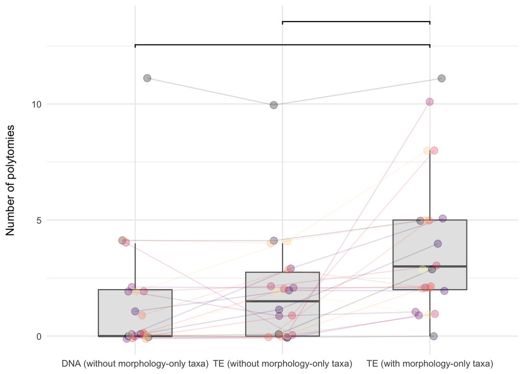

```r
# 7. FIGURE S8
# Add row ID for pairing
df_plot <- df_wide %>%
  mutate(row_id = row_number())
# Convert to long format
df_long <- df_plot %>%
  pivot_longer(
    cols = c(MP_nPolytomiesMOL, MP_nPolytomiesTE, MP_nPolytomiesTE_Extinct),
    names_to = "group",
    values_to = "value"
  )
# Create a factor to order the groups in plotting
df_long$group <- factor(df_long$group, levels = c("MP_nPolytomiesMOL",
                                                  "MP_nPolytomiesTE",
                                                  "MP_nPolytomiesTE_Extinct"))
# Plot paired dots with connecting lines
custom_colors <- c(
  "MP_nPolytomiesTE" = "#339999",         # lightest
  "MP_nPolytomiesMOL" = "#66CCCC",        # light
  "MP_nPolytomiesTE_Extinct" = "#006666" # darker
)
# Custom legend labels
custom_labels <- c(
  "MP_nPolytomiesMOL" = "MOL (without fossils)",
  "MP_nPolytomiesTE" = "TE (without fossils)",
  "MP_nPolytomiesTE_Extinct" = "TE (with fossils)"
)
# number of unique rows
n <- length(unique(df_long$row_id))
# generate n distinct colors
colors <- viridisLite::magma(n)
# define jitter once
jit <- position_jitter(width = 0.1, height = 0.15, seed = 1)
p <- ggplot(df_long, aes(x = group, y = value, group = row_id)) +
  geom_boxplot(
    aes(group = group),
    width = 0.5,
    fill = "gray90",
    color = "gray40",
    outlier.shape = NA,
    alpha = 1
  ) +
  geom_signif(
    comparisons = list(
      c("MP_nPolytomiesMOL", "MP_nPolytomiesTE_Extinct"),
      c("MP_nPolytomiesTE", "MP_nPolytomiesTE_Extinct")
    ),
    annotations = c("", ""),
    y_position = c(max(df_long$value) + 1,
                   max(df_long$value) + 2),
    tip_length = 0.01,
    textsize = 4
  ) +
  geom_line(
    aes(color = factor(row_id)),
    position = jit,
    alpha = 0.15
  ) +
  geom_point(
    aes(color = factor(row_id)),
    size = 3,
    position = jit,
    alpha = 0.3
  ) +
  scale_color_manual(values = colors) +

  scale_x_discrete(
    labels = c(
      "MP_nPolytomiesMOL" = "DNA (without morphology-only taxa)",
      "MP_nPolytomiesTE" = "TE (without morphology-only taxa)",
      "MP_nPolytomiesTE_Extinct" = "TE (with morphology-only taxa)"
    )
  ) +
  theme_minimal() +
  labs(
    x = NULL,
    y = "Number of polytomies\n"
  ) +
  theme(
    legend.position = "none"
  )
p
```

```r
# Save the plot as JPG, 300 dpi
ggsave(filename = "Figures/figS8_polytomies_MP.jpg",
       plot = p,
       width = 8, height = 5,      # size in inches
       dpi = 300,                   # resolution
       units = "in")

aggregate(value ~ group, data = df_long, function(x) c(
  median = median(x, na.rm = TRUE),
  mean   = mean(x, na.rm = TRUE),
  sd     = sd(x, na.rm = TRUE),
  min    = min(x, na.rm = TRUE),
  max    = max(x, na.rm = TRUE)
))
```

```
##                      group value.median value.mean  value.sd value.min
## 1        MP_nPolytomiesMOL     0.000000   1.500000  2.558832  0.000000
## 2         MP_nPolytomiesTE     1.500000   1.863636  2.315485  0.000000
## 3 MP_nPolytomiesTE_Extinct     3.000000   3.818182  3.049377  0.000000
##   value.max
## 1 11.000000
## 2 10.000000
## 3 11.000000
```

## Q3.3 Contribution of morphological evidence to the TE optimality score

In addition to testing whether MOL-TE incongruences differ between optimaliy criteria, we can explore the impact of morphological evidence to optimality scores between optimality criteria. Specifically, it is possible that the MKv model can constrain the contribution of the morphological partition to the TE optimality score in ML, whereas the same does not occur in MP analyses. As such, we need to test whether the proportion of optimality scores between MORPH and TE is higher in MP than ML analyses.

### Q3.3.1 Extant (Figure 5 and S9)

```r
# Load data for extant taxa
df <- read.csv("Dataset_R_q123_07-26.csv")
df_extant <- df %>% filter(grepl("Extant", Type)) # keep only extant datasets
df_extant <- df_extant[!is.na(df_extant$ML_TNT_MORPHonTEnoASC_score), ]

# Option 1. PHEcost / TEcost
op1_mp = (df_extant$MP_MORPHonTE_Score) / (df_extant$MP_TE_Score)
op1_ml_mk = (df_extant$ML_TNT_MORPHonTEnoASC_score) / (df_extant$ML_TNT_TEnoASC_Score)
op1_ml_mkv = (df_extant$ML_TNT_MORPHonTEasc_score) / (df_extant$ML_TNT_TEasc_Score)

print("Number of times that contribution of PHE is higher in MP than ML MK")
```

```
## [1] "Number of times that contribution of PHE is higher in MP than ML MK"
```

```r
sum(op1_mp > op1_ml_mk)
```

```
## [1] 33
```

```r
print("Number of times that contribution of PHE is lower in MP than ML MK")
```

```
## [1] "Number of times that contribution of PHE is lower in MP than ML MK"
```

```r
sum(op1_mp < op1_ml_mk)
```

```
## [1] 22
```

```r
print("Number of times that contribution of PHE is equal in MP than ML MK")
```

```
## [1] "Number of times that contribution of PHE is equal in MP than ML MK"
```

```r
sum(op1_mp == op1_ml_mk)
```

```
## [1] 7
```

```r
print("Number of times that contribution of PHE is higher in MP than ML MKv")
```

```
## [1] "Number of times that contribution of PHE is higher in MP than ML MKv"
```

```r
sum(op1_mp > op1_ml_mkv)
```

```
## [1] 34
```

```r
print("Number of times that contribution of PHE is lower in MP than ML MKv")
```

```
## [1] "Number of times that contribution of PHE is lower in MP than ML MKv"
```

```r
sum(op1_mp < op1_ml_mkv)
```

```
## [1] 21
```

```r
print("Number of times that contribution of PHE is equal in MP than ML MKv")
```

```
## [1] "Number of times that contribution of PHE is equal in MP than ML MKv"
```

```r
sum(op1_mp == op1_ml_mkv)
```

```
## [1] 7
```

```r
print("Stats MP")
```

```
## [1] "Stats MP"
```

```r
mean(op1_mp)
```

```
## [1] 0.06567846
```

```r
sd(op1_mp)
```

```
## [1] 0.07480962
```

```r
min(op1_mp)
```

```
## [1] 8.855636e-05
```

```r
max(op1_mp)
```

```
## [1] 0.3901795
```

```r
print("Stats ML MK")
```

```
## [1] "Stats ML MK"
```

```r
mean(op1_ml_mk)
```

```
## [1] 0.0658542
```

```r
sd(op1_ml_mk)
```

```
## [1] 0.07674721
```

```r
min(op1_ml_mk)
```

```
## [1] 8.739013e-05
```

```r
max(op1_ml_mk)
```

```
## [1] 0.3912815
```

```r
print("Stats ML MKv")
```

```
## [1] "Stats ML MKv"
```

```r
mean(op1_ml_mkv)
```

```
## [1] 0.0658714
```

```r
sd(op1_ml_mkv)
```

```
## [1] 0.07672821
```

```r
min(op1_ml_mkv)
```

```
## [1] 8.739013e-05
```

```r
max(op1_ml_mkv)
```

```
## [1] 0.3908709
```

```r
# Normality tests
shapiro.test(op1_mp) # p < 0.05, non-parametric
```

```
##
##  Shapiro-Wilk normality test
##
## data:  op1_mp
## W = 0.75844, p-value = 9.685e-09
```

```r
shapiro.test(op1_ml_mk) # p < 0.05, non-parametric
```

```
##
##  Shapiro-Wilk normality test
##
## data:  op1_ml_mk
## W = 0.74458, p-value = 4.79e-09
```

```r
shapiro.test(op1_ml_mkv) # p < 0.05, non-parametric
```

```
##
##  Shapiro-Wilk normality test
##
## data:  op1_ml_mkv
## W = 0.74511, p-value = 4.918e-09
```

```r
# Friedman test (non-parametric, multiple groups, paired values)
op1_q3_fri = data.frame(op1_mp, op1_ml_mk, op1_ml_mkv)
friedman.test(as.matrix(op1_q3_fri))
```

```
##
##  Friedman rank sum test
##
## data:  as.matrix(op1_q3_fri)
## Friedman chi-squared = 5.0337, df = 2, p-value = 0.08071
```

```r
# Wilcoxon: pairwise comparisons for paired values
pairwise.wilcox.test(x=unlist(op1_q3_fri),
                     g=factor(base::rep(names(op1_q3_fri), each = nrow(op1_q3_fri))),
                     paired=TRUE,
                     p.adjust.method="bonferroni")
```

```
##
##  Pairwise comparisons using Wilcoxon signed rank test with continuity correction
##
## data:  unlist(op1_q3_fri) and factor(base::rep(names(op1_q3_fri), each = nrow(op1_q3_fri)))
##
##            op1_ml_mk op1_ml_mkv
## op1_ml_mkv 1.00      -
## op1_mp     0.23      0.17
##
## P value adjustment method: bonferroni
```

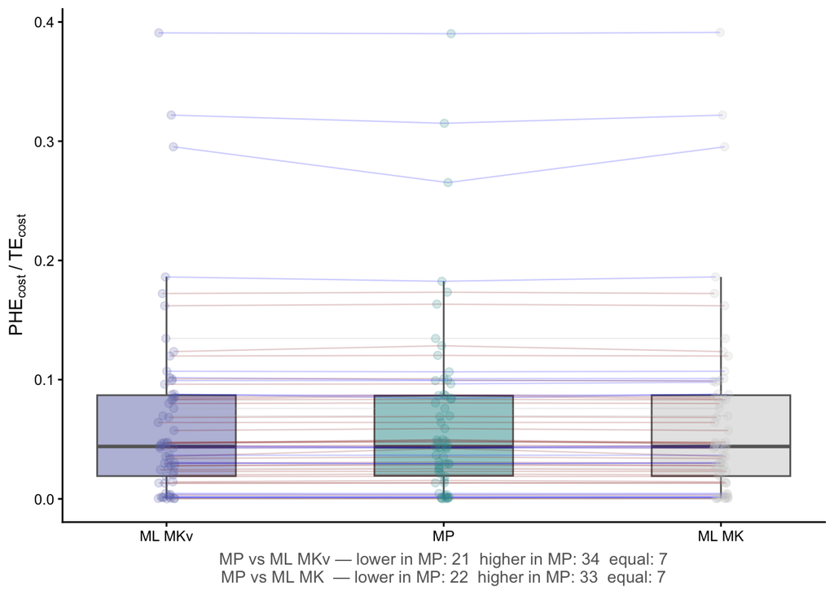

```r
# Figure S9
# Compute counts (MP vs ML MKv)
n_lower_mkv <- sum(op1_q3_fri$op1_mp < op1_q3_fri$op1_ml_mkv)
n_higher_mkv <- sum(op1_q3_fri$op1_mp > op1_q3_fri$op1_ml_mkv)
n_equal_mkv  <- sum(op1_q3_fri$op1_mp == op1_q3_fri$op1_ml_mkv)
# Compute counts (MP vs ML MK)
n_lower_mk <- sum(op1_q3_fri$op1_mp < op1_q3_fri$op1_ml_mk)
n_higher_mk <- sum(op1_q3_fri$op1_mp > op1_q3_fri$op1_ml_mk)
n_equal_mk  <- sum(op1_q3_fri$op1_mp == op1_q3_fri$op1_ml_mk)
# Figure S9
cols <- c("op1_mp" = "#339999", "op1_ml_mkv" = "#6f77b4", "op1_ml_mk" = "#cccccc")
# Add row ID
op1_q3_fri$row_id <- 1:nrow(op1_q3_fri)
# Pre-compute jitter offsets (same seed) — smaller jitter
set.seed(42)
n <- nrow(op1_q3_fri)
jitter_offsets <- data.frame(
  row_id   = 1:n,
  jitter_1 = runif(n, -0.03, 0.03),
  jitter_2 = runif(n, -0.03, 0.03),
  jitter_3 = runif(n, -0.03, 0.03)
)
# Merge offsets — new order: ML MKv, MP, ML MK (positions 1, 2, 3)
df_jitter <- op1_q3_fri %>%
  left_join(jitter_offsets, by = "row_id") %>%
  mutate(
    x1 = 1 + jitter_1,  # ML MKv
    x2 = 2 + jitter_2,  # MP
    x3 = 3 + jitter_3,  # ML MK
    seg1_color = case_when(
      op1_ml_mkv < op1_mp ~ "darkred",
      op1_ml_mkv > op1_mp ~ "blue",
      TRUE                ~ "gray"
    ),
    seg2_color = case_when(
      op1_mp > op1_ml_mk ~ "darkred",
      op1_mp < op1_ml_mk ~ "blue",
      TRUE               ~ "gray"
    )
  )
# Convert to long format — new level order
df_long <- op1_q3_fri %>%
  pivot_longer(cols = c(op1_ml_mkv, op1_mp, op1_ml_mk),
               names_to  = "group",
               values_to = "value") %>%
  mutate(group = factor(group, levels = c("op1_ml_mkv", "op1_mp", "op1_ml_mk"))) %>%
  left_join(jitter_offsets, by = "row_id") %>%
  mutate(x_jittered = case_when(
    group == "op1_ml_mkv" ~ 1 + jitter_1,
    group == "op1_mp"     ~ 2 + jitter_2,
    group == "op1_ml_mk"  ~ 3 + jitter_3
  ))
# Plot
op1_plot = ggplot() +
  geom_boxplot(data = df_long,
               aes(x = as.numeric(group), y = value, fill = group),
               alpha = 0.5, outlier.shape = NA,
               color = "gray40", linewidth = 0.5, width = 0.5) +
  # Segments: ML MKv -> MP
  geom_segment(data = df_jitter,
               aes(x = x1, xend = x2, y = op1_ml_mkv, yend = op1_mp, color = seg1_color),
               linewidth = 0.4, alpha = 0.2) +
  # Segments: MP -> ML MK
  geom_segment(data = df_jitter,
               aes(x = x2, xend = x3, y = op1_mp, yend = op1_ml_mk, color = seg2_color),
               linewidth = 0.4, alpha = 0.2) +
  geom_point(data = df_long,
             aes(x = x_jittered, y = value, color = group),
             size = 2, alpha = 0.2) +
  scale_fill_manual(values = cols) +
  scale_color_manual(values = c(cols,
                                "darkred"  = "darkred",
                                "blue" = "blue",
                                "gray" = "gray70")) +
  theme_classic() +
  theme(legend.position = "none",
        axis.title.x    = element_blank()) +
  labs(y = expression("PHE"["cost"] ~ "/" ~ "TE"["cost"] ~ "\n")) +
  scale_x_continuous(breaks = 1:3,
                     labels = c("ML MKv", "MP", "ML MK"))+
  labs(
    y       = expression("PHE"["cost"] ~ "/" ~ "TE"["cost"] ~ "\n"),
    caption = paste0(
      "MP vs ML MKv — lower in MP: ", n_lower_mkv, "  higher in MP: ", n_higher_mkv, "  equal: ", n_equal_mkv, "\n",
      "MP vs ML MK  — lower in MP: ", n_lower_mk,  "  higher in MP: ", n_higher_mk,  "  equal: ", n_equal_mk
    )
  ) +
  theme(plot.caption = element_text(hjust = 0.5, size = 10, color = "gray40"))

op1_plot
```

```r
ggsave(
  filename = "Figures/fig5_basicIndex.jpg",
  plot = op1_plot,
  width = 6,
  height = 5,
  units = "in",
  dpi = 300
)
```

```r
# Option 3. (PHEcost - PHEhomoplasy) / (TEcost - TEhomoplasy)
op3_mp = (df_extant$MP_MORPHonTE_Score - df_extant$MP_MORPHonTE_homoplasy) / (df_extant$MP_TE_Score - df_extant$MP_TE_homoplasy)
op3_ml_mk = (df_extant$ML_TNT_MORPHonTEnoASC_score - df_extant$ML_TNT_MORPHonTEnoASC_homoplasies) / (df_extant$ML_TNT_TEnoASC_Score - df_extant$ML_TNT_TEnoASC_homoplasies)
op3_ml_mkv = (df_extant$ML_TNT_MORPHonTEasc_score - df_extant$ML_TNT_MORPHonTEasc_homoplasies) / (df_extant$ML_TNT_TEasc_Score - df_extant$ML_TNT_TEnoASC_homoplasies)

print("Number of times that contribution of PHE is higher in MP than ML MK")
```

```
## [1] "Number of times that contribution of PHE is higher in MP than ML MK"
```

```r
sum(op3_mp > op3_ml_mk)
```

```
## [1] 0
```

```r
print("Number of times that contribution of PHE is lower in MP than ML MK")
```

```
## [1] "Number of times that contribution of PHE is lower in MP than ML MK"
```

```r
sum(op3_mp < op3_ml_mk)
```

```
## [1] 0
```

```r
print("Number of times that contribution of PHE is equal in MP than ML MK")
```

```
## [1] "Number of times that contribution of PHE is equal in MP than ML MK"
```

```r
sum(op3_mp == op3_ml_mk)
```

```
## [1] 62
```

```r
print("Number of times that contribution of PHE is higher in MP than ML MKv")
```

```
## [1] "Number of times that contribution of PHE is higher in MP than ML MKv"
```

```r
sum(op3_mp > op3_ml_mkv)
```

```
## [1] 5
```

```r
print("Number of times that contribution of PHE is lower in MP than ML MKv")
```

```
## [1] "Number of times that contribution of PHE is lower in MP than ML MKv"
```

```r
sum(op3_mp < op3_ml_mkv)
```

```
## [1] 7
```

```r
print("Number of times that contribution of PHE is equal in MP than ML MKv")
```

```
## [1] "Number of times that contribution of PHE is equal in MP than ML MKv"
```

```r
sum(op3_mp == op3_ml_mkv)
```

```
## [1] 50
```

```r
print("Stats MP")
```

```
## [1] "Stats MP"
```

```r
mean(op3_mp)
```

```
## [1] 0.05342759
```

```r
sd(op3_mp)
```

```
## [1] 0.05169792
```

```r
min(op3_mp)
```

```
## [1] 0.0002315901
```

```r
max(op3_mp)
```

```
## [1] 0.2836538
```

```r
print("Stats ML MK")
```

```
## [1] "Stats ML MK"
```

```r
mean(op3_ml_mk)
```

```
## [1] 0.05342759
```

```r
sd(op3_ml_mk)
```

```
## [1] 0.05169792
```

```r
min(op3_ml_mk)
```

```
## [1] 0.0002315901
```

```r
max(op3_ml_mk)
```

```
## [1] 0.2836538
```

```r
print("Stats ML MKv")
```

```
## [1] "Stats ML MKv"
```

```r
mean(op3_ml_mkv)
```

```
## [1] 0.0534229
```

```r
sd(op3_ml_mkv)
```

```
## [1] 0.05164424
```

```r
min(op3_ml_mkv)
```

```
## [1] 0.0002315901
```

```r
max(op3_ml_mkv)
```

```
## [1] 0.2829736
```

```r
# Normality tests
shapiro.test(op3_mp) # p < 0.05, non-parametric
```

```
##
##  Shapiro-Wilk normality test
##
## data:  op3_mp
## W = 0.83036, p-value = 6.043e-07
```

```r
shapiro.test(op3_ml_mk) # p < 0.05, non-parametric
```

```
##
##  Shapiro-Wilk normality test
##
## data:  op3_ml_mk
## W = 0.83036, p-value = 6.043e-07
```

```r
shapiro.test(op3_ml_mkv) # p < 0.05, non-parametric
```

```
##
##  Shapiro-Wilk normality test
##
## data:  op3_ml_mkv
## W = 0.83101, p-value = 6.299e-07
```

```r
# Friedman test (non-parametric, multiple groups, paired values)
op3_q3_fri = data.frame(op3_mp, op3_ml_mk, op3_ml_mkv)
friedman.test(as.matrix(op3_q3_fri))
```

```
##
##  Friedman rank sum test
##
## data:  as.matrix(op3_q3_fri)
## Friedman chi-squared = 0.66667, df = 2, p-value = 0.7165
```

```r
# Wilcoxon: pairwise comparisons for paired values
pairwise.wilcox.test(x=unlist(op3_q3_fri),
                     g=factor(base::rep(names(op3_q3_fri), each = nrow(op3_q3_fri))),
                     paired=TRUE,
                     p.adjust.method="bonferroni")
```

```
##
##  Pairwise comparisons using Wilcoxon signed rank test with continuity correction
##
## data:  unlist(op3_q3_fri) and factor(base::rep(names(op3_q3_fri), each = nrow(op3_q3_fri)))
##
##            op3_ml_mk op3_ml_mkv
## op3_ml_mkv 1         -
## op3_mp     -         1
##
## P value adjustment method: bonferroni
```

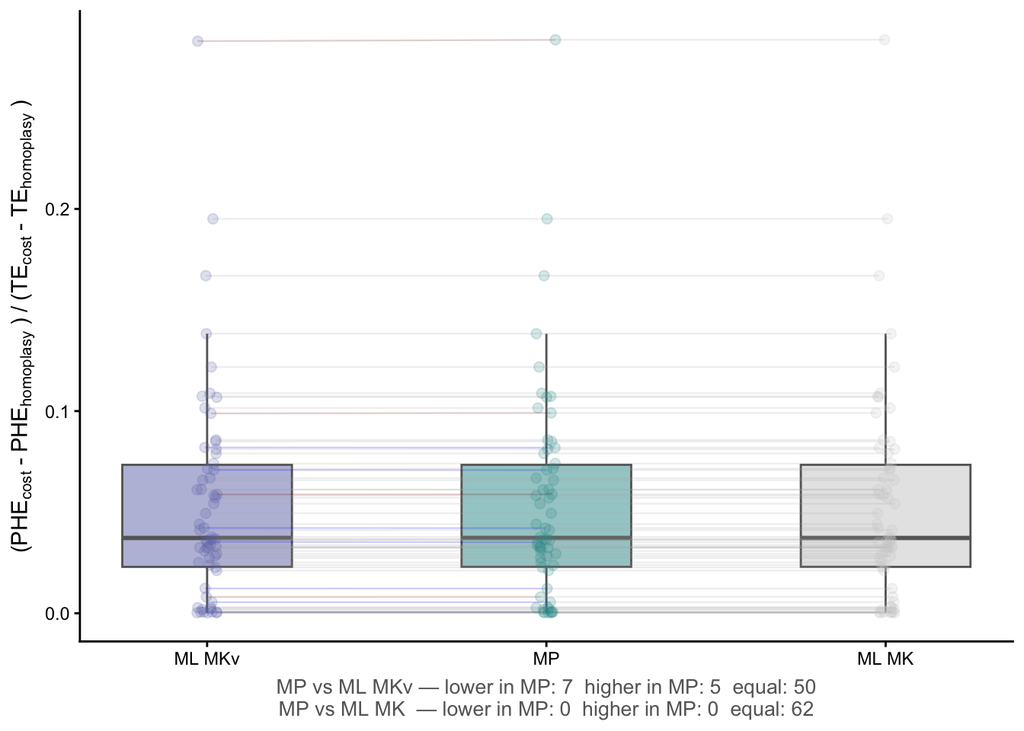

```r
# Compute counts (MP vs ML MKv)
n_lower_mkv <- sum(op3_q3_fri$op3_mp < op3_q3_fri$op3_ml_mkv)
n_higher_mkv <- sum(op3_q3_fri$op3_mp > op3_q3_fri$op3_ml_mkv)
n_equal_mkv  <- sum(op3_q3_fri$op3_mp == op3_q3_fri$op3_ml_mkv)
# Compute counts (MP vs ML MK)
n_lower_mk <- sum(op3_q3_fri$op3_mp < op3_q3_fri$op3_ml_mk)
n_higher_mk <- sum(op3_q3_fri$op3_mp > op3_q3_fri$op3_ml_mk)
n_equal_mk  <- sum(op3_q3_fri$op3_mp == op3_q3_fri$op3_ml_mk)
# Figure S9
cols <- c("op3_mp" = "#339999", "op3_ml_mkv" = "#6f77b4", "op3_ml_mk" = "#cccccc")
# Add row ID
op3_q3_fri$row_id <- 1:nrow(op3_q3_fri)
# Pre-compute jitter offsets (same seed) — smaller jitter
set.seed(42)
n <- nrow(op3_q3_fri)
jitter_offsets <- data.frame(
  row_id   = 1:n,
  jitter_1 = runif(n, -0.03, 0.03),
  jitter_2 = runif(n, -0.03, 0.03),
  jitter_3 = runif(n, -0.03, 0.03)
)
# Merge offsets — new order: ML MKv, MP, ML MK (positions 1, 2, 3)
df_jitter <- op3_q3_fri %>%
  left_join(jitter_offsets, by = "row_id") %>%
  mutate(
    x1 = 1 + jitter_1,  # ML MKv
    x2 = 2 + jitter_2,  # MP
    x3 = 3 + jitter_3,  # ML MK
    seg1_color = case_when(
      op3_ml_mkv < op3_mp ~ "darkred",
      op3_ml_mkv > op3_mp ~ "blue",
      TRUE                ~ "gray"
    ),
    seg2_color = case_when(
      op3_mp > op3_ml_mk ~ "darkred",
      op3_mp < op3_ml_mk ~ "blue",
      TRUE               ~ "gray"
    )
  )
# Convert to long format — new level order
df_long <- op3_q3_fri %>%
  pivot_longer(cols = c(op3_ml_mkv, op3_mp, op3_ml_mk),
               names_to  = "group",
               values_to = "value") %>%
  mutate(group = factor(group, levels = c("op3_ml_mkv", "op3_mp", "op3_ml_mk"))) %>%
  left_join(jitter_offsets, by = "row_id") %>%
  mutate(x_jittered = case_when(
    group == "op3_ml_mkv" ~ 1 + jitter_1,
    group == "op3_mp"     ~ 2 + jitter_2,
    group == "op3_ml_mk"  ~ 3 + jitter_3
  ))
# Plot
op3_plot=ggplot() +
  geom_boxplot(data = df_long,
               aes(x = as.numeric(group), y = value, fill = group),
               alpha = 0.5, outlier.shape = NA,
               color = "gray40", linewidth = 0.5, width = 0.5) +
  # Segments: ML MKv -> MP
  geom_segment(data = df_jitter,
               aes(x = x1, xend = x2, y = op3_ml_mkv, yend = op3_mp, color = seg1_color),
               linewidth = 0.4, alpha = 0.2) +
  # Segments: MP -> ML MK
  geom_segment(data = df_jitter,
               aes(x = x2, xend = x3, y = op3_mp, yend = op3_ml_mk, color = seg2_color),
               linewidth = 0.4, alpha = 0.2) +
  geom_point(data = df_long,
             aes(x = x_jittered, y = value, color = group),
             size = 2, alpha = 0.2) +
  scale_fill_manual(values = cols) +
  scale_color_manual(values = c(cols,
                                "darkred"  = "darkred",
                                "blue" = "blue",
                                "gray" = "gray70")) +
  theme_classic() +
  theme(legend.position = "none",
        axis.title.x    = element_blank()) +
  labs(y = expression("(PHE"["cost"] ~ "-" ~ "PHE"["homoplasy"] ~ ")" ~ "/" ~ "(TE"["cost"] ~ "-" ~ "TE"["homoplasy"] ~ ")")) +
  scale_x_continuous(breaks = 1:3,
                     labels = c("ML MKv", "MP", "ML MK"))+
  labs(
    y       = expression("(PHE"["cost"] ~ "-" ~ "PHE"["homoplasy"] ~ ")" ~ "/" ~ "(TE"["cost"] ~ "-" ~ "TE"["homoplasy"] ~ ")"),
    caption = paste0(
      "MP vs ML MKv — lower in MP: ", n_lower_mkv, "  higher in MP: ", n_higher_mkv, "  equal: ", n_equal_mkv, "\n",
      "MP vs ML MK  — lower in MP: ", n_lower_mk,  "  higher in MP: ", n_higher_mk,  "  equal: ", n_equal_mk
    )
  ) +
  theme(plot.caption = element_text(hjust = 0.5, size = 10, color = "gray40"))

op3_plot
```

```r
# Option 5. (PHEcost x PHEci) / (TEcost x TEci)
op5_mp = (df_extant$MP_MORPHonTE_Score * df_extant$MP_MORPHonTE_CI) / (df_extant$MP_TE_Score * df_extant$MP_TE_CI)
op5_ml_mk = (df_extant$ML_TNT_MORPHonTEnoASC_score * df_extant$ML_TNT_MORPHonTEnoASC_CI) / (df_extant$ML_TNT_TEnoASC_Score * df_extant$ML_TNT_TEnoASC_CI)
op5_ml_mkv = (df_extant$ML_TNT_MORPHonTEasc_score * df_extant$ML_TNT_MORPHonTEasc_CI) / (df_extant$ML_TNT_TEasc_Score * df_extant$ML_TNT_TEasc_CI)

print("Number of times that contribution of PHE is higher in MP than ML MK")
```

```
## [1] "Number of times that contribution of PHE is higher in MP than ML MK"
```

```r
sum(op5_mp > op5_ml_mk)
```

```
## [1] 30
```

```r
print("Number of times that contribution of PHE is lower in MP than ML MK")
```

```
## [1] "Number of times that contribution of PHE is lower in MP than ML MK"
```

```r
sum(op5_mp < op5_ml_mk)
```

```
## [1] 25
```

```r
print("Number of times that contribution of PHE is equal in MP than ML MK")
```

```
## [1] "Number of times that contribution of PHE is equal in MP than ML MK"
```

```r
sum(op5_mp == op5_ml_mk)
```

```
## [1] 7
```

```r
print("Number of times that contribution of PHE is higher in MP than ML MKv")
```

```
## [1] "Number of times that contribution of PHE is higher in MP than ML MKv"
```

```r
sum(op5_mp > op5_ml_mkv)
```

```
## [1] 30
```

```r
print("Number of times that contribution of PHE is lower in MP than ML MKv")
```

```
## [1] "Number of times that contribution of PHE is lower in MP than ML MKv"
```

```r
sum(op5_mp < op5_ml_mkv)
```

```
## [1] 25
```

```r
print("Number of times that contribution of PHE is equal in MP than ML MKv")
```

```
## [1] "Number of times that contribution of PHE is equal in MP than ML MKv"
```

```r
sum(op5_mp == op5_ml_mkv)
```

```
## [1] 7
```

```r
print("Stats MP")
```

```
## [1] "Stats MP"
```

```r
mean(op5_mp)
```

```
## [1] 0.05379555
```

```r
sd(op5_mp)
```

```
## [1] 0.05225485
```

```r
min(op5_mp)
```

```
## [1] 0.0002311025
```

```r
max(op5_mp)
```

```
## [1] 0.2835245
```

```r
print("Stats ML MK")
```

```
## [1] "Stats ML MK"
```

```r
mean(op5_ml_mk)
```

```
## [1] 0.05378559
```

```r
sd(op5_ml_mk)
```

```
## [1] 0.05228408
```

```r
min(op5_ml_mk)
```

```
## [1] 0.0002318447
```

```r
max(op5_ml_mk)
```

```
## [1] 0.2838358
```

```r
print("Stats ML MKv")
```

```
## [1] "Stats ML MKv"
```

```r
mean(op5_ml_mkv)
```

```
## [1] 0.05377812
```

```r
sd(op5_ml_mkv)
```

```
## [1] 0.05226198
```

```r
min(op5_ml_mkv)
```

```
## [1] 0.0002318447
```

```r
max(op5_ml_mkv)
```

```
## [1] 0.283538
```

```r
# Normality tests
shapiro.test(op5_mp) # p < 0.05, non-parametric
```

```
##
##  Shapiro-Wilk normality test
##
## data:  op5_mp
## W = 0.83149, p-value = 6.499e-07
```

```r
shapiro.test(op5_ml_mk) # p < 0.05, non-parametric
```

```
##
##  Shapiro-Wilk normality test
##
## data:  op5_ml_mk
## W = 0.83108, p-value = 6.329e-07
```

```r
shapiro.test(op5_ml_mkv) # p < 0.05, non-parametric
```

```
##
##  Shapiro-Wilk normality test
##
## data:  op5_ml_mkv
## W = 0.83132, p-value = 6.428e-07
```

```r
# Friedman test (non-parametric, multiple groups, paired values)
op5_q3_fri = data.frame(op5_mp, op5_ml_mk, op5_ml_mkv)
friedman.test(as.matrix(op5_q3_fri))
```

```
##
##  Friedman rank sum test
##
## data:  as.matrix(op5_q3_fri)
## Friedman chi-squared = 0.94382, df = 2, p-value = 0.6238
```

```r
# Wilcoxon: pairwise comparisons for paired values
pairwise.wilcox.test(x=unlist(op5_q3_fri),
                     g=factor(base::rep(names(op5_q3_fri), each = nrow(op5_q3_fri))),
                     paired=TRUE,
                     p.adjust.method="bonferroni")
```

```
##
##  Pairwise comparisons using Wilcoxon signed rank test with continuity correction
##
## data:  unlist(op5_q3_fri) and factor(base::rep(names(op5_q3_fri), each = nrow(op5_q3_fri)))
##
##            op5_ml_mk op5_ml_mkv
## op5_ml_mkv 1.00      -
## op5_mp     0.68      0.37
##
## P value adjustment method: bonferroni
```

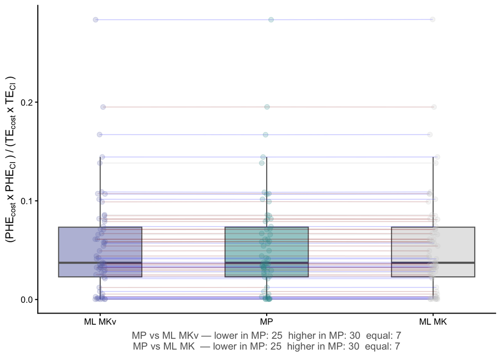

```r
# Compute counts (MP vs ML MKv)
n_lower_mkv <- sum(op5_q3_fri$op5_mp < op5_q3_fri$op5_ml_mkv)
n_higher_mkv <- sum(op5_q3_fri$op5_mp > op5_q3_fri$op5_ml_mkv)
n_equal_mkv  <- sum(op5_q3_fri$op5_mp == op5_q3_fri$op5_ml_mkv)
# Compute counts (MP vs ML MK)
n_lower_mk <- sum(op5_q3_fri$op5_mp < op5_q3_fri$op5_ml_mk)
n_higher_mk <- sum(op5_q3_fri$op5_mp > op5_q3_fri$op5_ml_mk)
n_equal_mk  <- sum(op5_q3_fri$op5_mp == op5_q3_fri$op5_ml_mk)
# Figure S9
cols <- c("op5_mp" = "#339999", "op5_ml_mkv" = "#6f77b4", "op5_ml_mk" = "#cccccc")
# Add row ID
op5_q3_fri$row_id <- 1:nrow(op5_q3_fri)
# Pre-compute jitter offsets (same seed) — smaller jitter
set.seed(42)
n <- nrow(op5_q3_fri)
jitter_offsets <- data.frame(
  row_id   = 1:n,
  jitter_1 = runif(n, -0.03, 0.03),
  jitter_2 = runif(n, -0.03, 0.03),
  jitter_3 = runif(n, -0.03, 0.03)
)
# Merge offsets — new order: ML MKv, MP, ML MK (positions 1, 2, 3)
df_jitter <- op5_q3_fri %>%
  left_join(jitter_offsets, by = "row_id") %>%
  mutate(
    x1 = 1 + jitter_1,  # ML MKv
    x2 = 2 + jitter_2,  # MP
    x3 = 3 + jitter_3,  # ML MK
    seg1_color = case_when(
      op5_ml_mkv < op5_mp ~ "darkred",
      op5_ml_mkv > op5_mp ~ "blue",
      TRUE                ~ "gray"
    ),
    seg2_color = case_when(
      op5_mp > op5_ml_mk ~ "darkred",
      op5_mp < op5_ml_mk ~ "blue",
      TRUE               ~ "gray"
    )
  )
# Convert to long format — new level order
df_long <- op5_q3_fri %>%
  pivot_longer(cols = c(op5_ml_mkv, op5_mp, op5_ml_mk),
               names_to  = "group",
               values_to = "value") %>%
  mutate(group = factor(group, levels = c("op5_ml_mkv", "op5_mp", "op5_ml_mk"))) %>%
  left_join(jitter_offsets, by = "row_id") %>%
  mutate(x_jittered = case_when(
    group == "op5_ml_mkv" ~ 1 + jitter_1,
    group == "op5_mp"     ~ 2 + jitter_2,
    group == "op5_ml_mk"  ~ 3 + jitter_3
  ))
# Plot
op5_plot=ggplot() +
  geom_boxplot(data = df_long,
               aes(x = as.numeric(group), y = value, fill = group),
               alpha = 0.5, outlier.shape = NA,
               color = "gray40", linewidth = 0.5, width = 0.5) +
  # Segments: ML MKv -> MP
  geom_segment(data = df_jitter,
               aes(x = x1, xend = x2, y = op5_ml_mkv, yend = op5_mp, color = seg1_color),
               linewidth = 0.4, alpha = 0.2) +
  # Segments: MP -> ML MK
  geom_segment(data = df_jitter,
               aes(x = x2, xend = x3, y = op5_mp, yend = op5_ml_mk, color = seg2_color),
               linewidth = 0.4, alpha = 0.2) +
  geom_point(data = df_long,
             aes(x = x_jittered, y = value, color = group),
             size = 2, alpha = 0.2) +
  scale_fill_manual(values = cols) +
  scale_color_manual(values = c(cols,
                                "darkred"  = "darkred",
                                "blue" = "blue",
                                "gray" = "gray70")) +
  theme_classic() +
  theme(legend.position = "none",
        axis.title.x    = element_blank()) +
  labs(y = expression("(PHE"["cost"] ~ "x" ~ "PHE"["CI"] ~ ")" ~ "/" ~ "(TE"["cost"]) ~ "x" ~ "TE"["CI"]~ ")") +
  scale_x_continuous(breaks = 1:3,
                     labels = c("ML MKv", "MP", "ML MK"))+
  labs(  y       = expression("(PHE"["cost"] ~ "x" ~ "PHE"["CI"] ~ ")" ~ "/" ~ "(TE"["cost"] ~ "x" ~ "TE"["CI"] ~ ")"),
         caption = paste0(
      "MP vs ML MKv — lower in MP: ", n_lower_mkv, "  higher in MP: ", n_higher_mkv, "  equal: ", n_equal_mkv, "\n",
      "MP vs ML MK  — lower in MP: ", n_lower_mk,  "  higher in MP: ", n_higher_mk,  "  equal: ", n_equal_mk
    )
  ) +
  theme(plot.caption = element_text(hjust = 0.5, size = 10, color = "gray40"))

op5_plot
```

```r
# Option 6. (PHEcost x PHEri) / (TEcost x TEri)
op6_mp = (df_extant$MP_MORPHonTE_Score * df_extant$MP_MORPHonTE_RI) / (df_extant$MP_TE_Score * df_extant$MP_TE_RI)
op6_ml_mk = (df_extant$ML_TNT_MORPHonTEnoASC_score * df_extant$ML_TNT_MORPHonTEnoASC_RI) / (df_extant$ML_TNT_TEnoASC_Score * df_extant$ML_TNT_TEnoASC_RI)
op6_ml_mkv = (df_extant$ML_TNT_MORPHonTEasc_score * df_extant$ML_TNT_MORPHonTEasc_RI) / (df_extant$ML_TNT_TEasc_Score * df_extant$ML_TNT_TEasc_RI)

print("Number of times that contribution of PHE is higher in MP than ML MK")
```

```
## [1] "Number of times that contribution of PHE is higher in MP than ML MK"
```

```r
sum(op6_mp > op6_ml_mk)
```

```
## [1] 26
```

```r
print("Number of times that contribution of PHE is lower in MP than ML MK")
```

```
## [1] "Number of times that contribution of PHE is lower in MP than ML MK"
```

```r
sum(op6_mp < op6_ml_mk)
```

```
## [1] 29
```

```r
print("Number of times that contribution of PHE is equal in MP than ML MK")
```

```
## [1] "Number of times that contribution of PHE is equal in MP than ML MK"
```

```r
sum(op6_mp == op6_ml_mk)
```

```
## [1] 7
```

```r
print("Number of times that contribution of PHE is higher in MP than ML MKv")
```

```
## [1] "Number of times that contribution of PHE is higher in MP than ML MKv"
```

```r
sum(op6_mp > op6_ml_mkv)
```

```
## [1] 24
```

```r
print("Number of times that contribution of PHE is lower in MP than ML MKv")
```

```
## [1] "Number of times that contribution of PHE is lower in MP than ML MKv"
```

```r
sum(op6_mp < op6_ml_mkv)
```

```
## [1] 31
```

```r
print("Number of times that contribution of PHE is equal in MP than ML MKv")
```

```
## [1] "Number of times that contribution of PHE is equal in MP than ML MKv"
```

```r
sum(op6_mp == op6_ml_mkv)
```

```
## [1] 7
```

```r
print("Stats MP")
```

```
## [1] "Stats MP"
```

```r
mean(op6_mp)
```

```
## [1] 0.07304287
```

```r
sd(op6_mp)
```

```
## [1] 0.06976052
```

```r
min(op6_mp)
```

```
## [1] 7.260521e-05
```

```r
max(op6_mp)
```

```
## [1] 0.3788778
```

```r
print("Stats ML MK")
```

```
## [1] "Stats ML MK"
```

```r
mean(op6_ml_mk)
```

```
## [1] 0.07321477
```

```r
sd(op6_ml_mk)
```

```
## [1] 0.06978016
```

```r
min(op6_ml_mk)
```

```
## [1] 7.434277e-05
```

```r
max(op6_ml_mk)
```

```
## [1] 0.3793588
```

```r
print("Stats ML MKv")
```

```
## [1] "Stats ML MKv"
```

```r
mean(op6_ml_mkv)
```

```
## [1] 0.07321873
```

```r
sd(op6_ml_mkv)
```

```
## [1] 0.06979499
```

```r
min(op6_ml_mkv)
```

```
## [1] 7.434277e-05
```

```r
max(op6_ml_mkv)
```

```
## [1] 0.3789607
```

```r
# Normality tests
shapiro.test(op6_mp) # p < 0.05, non-parametric
```

```
##
##  Shapiro-Wilk normality test
##
## data:  op6_mp
## W = 0.85351, p-value = 2.847e-06
```

```r
shapiro.test(op6_ml_mk) # p < 0.05, non-parametric
```

```
##
##  Shapiro-Wilk normality test
##
## data:  op6_ml_mk
## W = 0.85456, p-value = 3.065e-06
```

```r
shapiro.test(op6_ml_mkv) # p < 0.05, non-parametric
```

```
##
##  Shapiro-Wilk normality test
##
## data:  op6_ml_mkv
## W = 0.8549, p-value = 3.139e-06
```

```r
# Friedman test (non-parametric, multiple groups, paired values)
op6_q3_fri = data.frame(op6_mp, op6_ml_mk, op6_ml_mkv)
friedman.test(as.matrix(op6_q3_fri))
```

```
##
##  Friedman rank sum test
##
## data:  as.matrix(op6_q3_fri)
## Friedman chi-squared = 0.85393, df = 2, p-value = 0.6525
```

```r
# Wilcoxon: pairwise comparisons for paired values
pairwise.wilcox.test(x=unlist(op6_q3_fri),
                     g=factor(base::rep(names(op6_q3_fri), each = nrow(op6_q3_fri))),
                     paired=TRUE,
                     p.adjust.method="bonferroni")
```

```
##
##  Pairwise comparisons using Wilcoxon signed rank test with continuity correction
##
## data:  unlist(op6_q3_fri) and factor(base::rep(names(op6_q3_fri), each = nrow(op6_q3_fri)))
##
##            op6_ml_mk op6_ml_mkv
## op6_ml_mkv 1.00      -
## op6_mp     1.00      0.75
##
## P value adjustment method: bonferroni
```

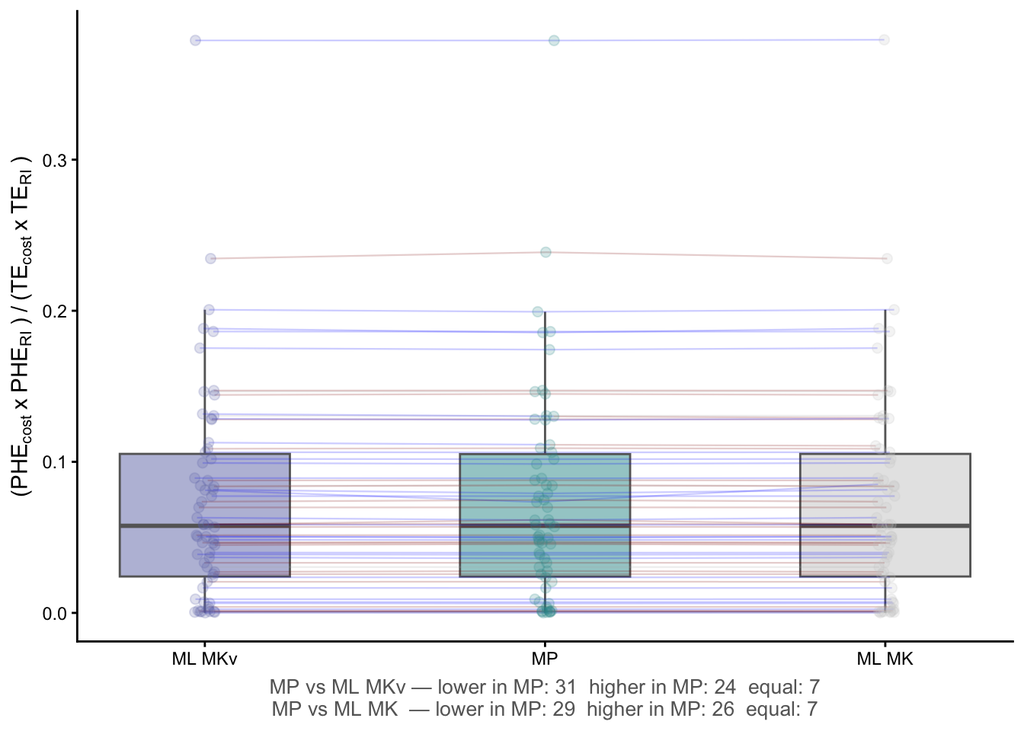

```r
# Compute counts (MP vs ML MKv)
n_lower_mkv <- sum(op6_q3_fri$op6_mp < op6_q3_fri$op6_ml_mkv)
n_higher_mkv <- sum(op6_q3_fri$op6_mp > op6_q3_fri$op6_ml_mkv)
n_equal_mkv  <- sum(op6_q3_fri$op6_mp == op6_q3_fri$op6_ml_mkv)
# Compute counts (MP vs ML MK)
n_lower_mk <- sum(op6_q3_fri$op6_mp < op6_q3_fri$op6_ml_mk)
n_higher_mk <- sum(op6_q3_fri$op6_mp > op6_q3_fri$op6_ml_mk)
n_equal_mk  <- sum(op6_q3_fri$op6_mp == op6_q3_fri$op6_ml_mk)
# Figure S9
cols <- c("op6_mp" = "#339999", "op6_ml_mkv" = "#6f77b4", "op6_ml_mk" = "#cccccc")
# Add row ID
op6_q3_fri$row_id <- 1:nrow(op6_q3_fri)
# Pre-compute jitter offsets (same seed) — smaller jitter
set.seed(42)
n <- nrow(op6_q3_fri)
jitter_offsets <- data.frame(
  row_id   = 1:n,
  jitter_1 = runif(n, -0.03, 0.03),
  jitter_2 = runif(n, -0.03, 0.03),
  jitter_3 = runif(n, -0.03, 0.03)
)
# Merge offsets — new order: ML MKv, MP, ML MK (positions 1, 2, 3)
df_jitter <- op6_q3_fri %>%
  left_join(jitter_offsets, by = "row_id") %>%
  mutate(
    x1 = 1 + jitter_1,  # ML MKv
    x2 = 2 + jitter_2,  # MP
    x3 = 3 + jitter_3,  # ML MK
    seg1_color = case_when(
      op6_ml_mkv < op6_mp ~ "darkred",
      op6_ml_mkv > op6_mp ~ "blue",
      TRUE                ~ "gray"
    ),
    seg2_color = case_when(
      op6_mp > op6_ml_mk ~ "darkred",
      op6_mp < op6_ml_mk ~ "blue",
      TRUE               ~ "gray"
    )
  )
# Convert to long format — new level order
df_long <- op6_q3_fri %>%
  pivot_longer(cols = c(op6_ml_mkv, op6_mp, op6_ml_mk),
               names_to  = "group",
               values_to = "value") %>%
  mutate(group = factor(group, levels = c("op6_ml_mkv", "op6_mp", "op6_ml_mk"))) %>%
  left_join(jitter_offsets, by = "row_id") %>%
  mutate(x_jittered = case_when(
    group == "op6_ml_mkv" ~ 1 + jitter_1,
    group == "op6_mp"     ~ 2 + jitter_2,
    group == "op6_ml_mk"  ~ 3 + jitter_3
  ))
# Plot
op6_plot=ggplot() +
  geom_boxplot(data = df_long,
               aes(x = as.numeric(group), y = value, fill = group),
               alpha = 0.5, outlier.shape = NA,
               color = "gray40", linewidth = 0.5, width = 0.5) +
  # Segments: ML MKv -> MP
  geom_segment(data = df_jitter,
               aes(x = x1, xend = x2, y = op6_ml_mkv, yend = op6_mp, color = seg1_color),
               linewidth = 0.4, alpha = 0.2) +
  # Segments: MP -> ML MK
  geom_segment(data = df_jitter,
               aes(x = x2, xend = x3, y = op6_mp, yend = op6_ml_mk, color = seg2_color),
               linewidth = 0.4, alpha = 0.2) +
  geom_point(data = df_long,
             aes(x = x_jittered, y = value, color = group),
             size = 2, alpha = 0.2) +
  scale_fill_manual(values = cols) +
  scale_color_manual(values = c(cols,
                                "darkred"  = "darkred",
                                "blue" = "blue",
                                "gray" = "gray70")) +
  theme_classic() +
  theme(legend.position = "none",
        axis.title.x    = element_blank()) +
  labs(y = expression("(PHE"["cost"] ~ "x" ~ "PHE"["RI"] ~ ")" ~ "/" ~ "(TE"["cost"]) ~ "x" ~ "TE"["RI"]~ ")") +
  scale_x_continuous(breaks = 1:3,
                     labels = c("ML MKv", "MP", "ML MK"))+
  labs(  y       = expression("(PHE"["cost"] ~ "x" ~ "PHE"["RI"] ~ ")" ~ "/" ~ "(TE"["cost"] ~ "x" ~ "TE"["RI"] ~ ")"),
         caption = paste0(
      "MP vs ML MKv — lower in MP: ", n_lower_mkv, "  higher in MP: ", n_higher_mkv, "  equal: ", n_equal_mkv, "\n",
      "MP vs ML MK  — lower in MP: ", n_lower_mk,  "  higher in MP: ", n_higher_mk,  "  equal: ", n_equal_mk
    )
  ) +
  theme(plot.caption = element_text(hjust = 0.5, size = 10, color = "gray40"))

op6_plot
```

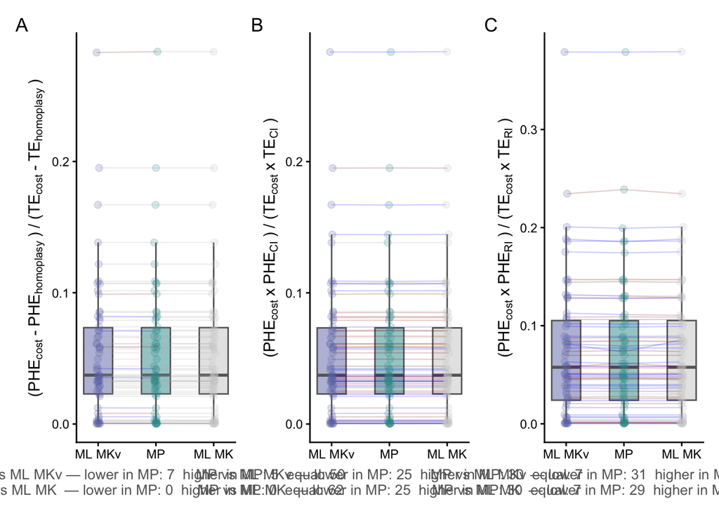

```r
# Figure S9: Only options 3, 4 and 5

# Combine plots with labels
combined <- (op3_plot | op5_plot | op6_plot) +
  plot_annotation(tag_levels = "A")
combined
```

```r
# Save as jpg
ggsave("Figures/figS9_extant_plots.jpg", combined, width = 18, height = 6, dpi = 300)
```

### Q3.3.2 Extant + extinct

```r
# Load data
df <- read.csv("Dataset_R_q123_07-26.csv")
#df_extinct <- df %>% filter(grepl("Extinct", Type)) # keep only extinct datasets
# Keep only extinct
extinct_datasets <- unique(df$Dataset[df$Type == "Extinct"])
# Append the extant datasets that do not appear among extinct
df_extinct <- df[df$Type == "Extinct" |
                  (df$Type == "Extant" & !(df$Dataset %in% extinct_datasets)), ]

# Option 1. PHEcost / TEcost
op1_mp = (df_extinct$MP_MORPHonTE_Score) / (df_extinct$MP_TE_Score)
op1_ml_mk = (df_extinct$ML_TNT_MORPHonTEnoASC_score) / (df_extinct$ML_TNT_TEnoASC_Score)
op1_ml_mkv = (df_extinct$ML_TNT_MORPHonTEasc_score) / (df_extinct$ML_TNT_TEasc_Score)

print("Number of times that contribution of PHE is higher in MP than ML MK")
```

```
## [1] "Number of times that contribution of PHE is higher in MP than ML MK"
```

```r
sum(op1_mp > op1_ml_mk)
```

```
## [1] NA
```

```r
print("Number of times that contribution of PHE is lower in MP than ML MK")
```

```
## [1] "Number of times that contribution of PHE is lower in MP than ML MK"
```

```r
sum(op1_mp < op1_ml_mk)
```

```
## [1] NA
```

```r
print("Number of times that contribution of PHE is equal in MP than ML MK")
```

```
## [1] "Number of times that contribution of PHE is equal in MP than ML MK"
```

```r
sum(op1_mp == op1_ml_mk)
```

```
## [1] NA
```

```r
print("Number of times that contribution of PHE is higher in MP than ML MKv")
```

```
## [1] "Number of times that contribution of PHE is higher in MP than ML MKv"
```

```r
sum(op1_mp > op1_ml_mkv)
```

```
## [1] 35
```

```r
print("Number of times that contribution of PHE is lower in MP than ML MKv")
```

```
## [1] "Number of times that contribution of PHE is lower in MP than ML MKv"
```

```r
sum(op1_mp < op1_ml_mkv)
```

```
## [1] 23
```

```r
print("Number of times that contribution of PHE is equal in MP than ML MKv")
```

```
## [1] "Number of times that contribution of PHE is equal in MP than ML MKv"
```

```r
sum(op1_mp == op1_ml_mkv)
```

```
## [1] 5
```

```r
print("Stats MP")
```

```
## [1] "Stats MP"
```

```r
mean(op1_mp)
```

```
## [1] 0.07183104
```

```r
sd(op1_mp)
```

```
## [1] 0.08488418
```

```r
min(op1_mp)
```

```
## [1] 8.855636e-05
```

```r
max(op1_mp)
```

```
## [1] 0.4525732
```

```r
print("Stats ML MK")
```

```
## [1] "Stats ML MK"
```

```r
mean(op1_ml_mk)
```

```
## [1] NA
```

```r
sd(op1_ml_mk)
```

```
## [1] NA
```

```r
min(op1_ml_mk)
```

```
## [1] NA
```

```r
max(op1_ml_mk)
```

```
## [1] NA
```

```r
print("Stats ML MKv")
```

```
## [1] "Stats ML MKv"
```

```r
mean(op1_ml_mkv)
```

```
## [1] 0.07061667
```

```r
sd(op1_ml_mkv)
```

```
## [1] 0.08657819
```

```r
min(op1_ml_mkv)
```

```
## [1] 8.739013e-05
```

```r
max(op1_ml_mkv)
```

```
## [1] 0.4584168
```

```r
# Normality tests
shapiro.test(op1_mp) # p < 0.05, non-parametric
```

```
##
##  Shapiro-Wilk normality test
##
## data:  op1_mp
## W = 0.73642, p-value = 2.625e-09
```

```r
shapiro.test(op1_ml_mk) # p < 0.05, non-parametric
```

```
##
##  Shapiro-Wilk normality test
##
## data:  op1_ml_mk
## W = 0.71988, p-value = 1.448e-09
```

```r
shapiro.test(op1_ml_mkv) # p < 0.05, non-parametric
```

```
##
##  Shapiro-Wilk normality test
##
## data:  op1_ml_mkv
## W = 0.71859, p-value = 1.112e-09
```

```r
# Friedman test (non-parametric, multiple groups, paired values)
op1_q3_fri = data.frame(op1_mp, op1_ml_mk, op1_ml_mkv)
friedman.test(as.matrix(op1_q3_fri))
```

```
##
##  Friedman rank sum test
##
## data:  as.matrix(op1_q3_fri)
## Friedman chi-squared = 4.1667, df = 2, p-value = 0.1245
```

```r
# Wilcoxon: pairwise comparisons for paired values
pairwise.wilcox.test(x=unlist(op1_q3_fri),
                     g=factor(base::rep(names(op1_q3_fri), each = nrow(op1_q3_fri))),
                     paired=TRUE,
                     p.adjust.method="bonferroni")
```

```
##
##  Pairwise comparisons using Wilcoxon signed rank test with continuity correction
##
## data:  unlist(op1_q3_fri) and factor(base::rep(names(op1_q3_fri), each = nrow(op1_q3_fri)))
##
##            op1_ml_mk op1_ml_mkv
## op1_ml_mkv 0.15      -
## op1_mp     0.53      0.38
##
## P value adjustment method: bonferroni
```

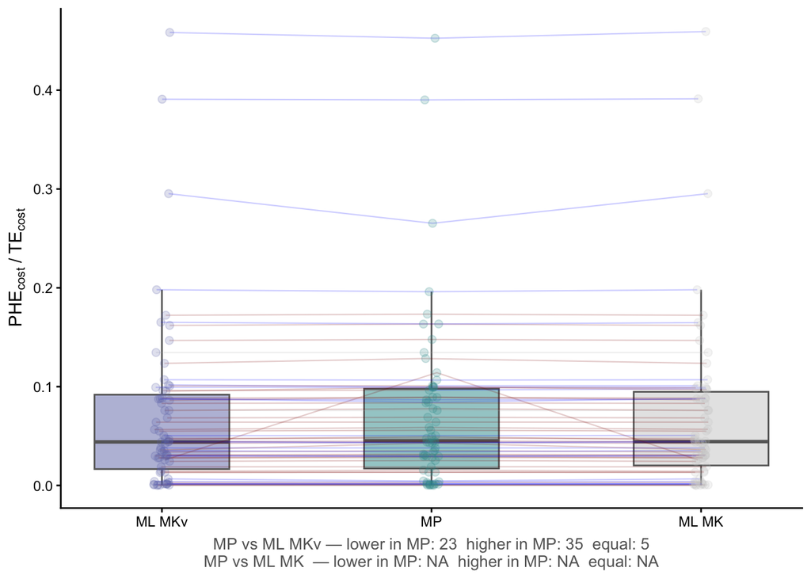

```r
# Figure S8
# Compute counts (MP vs ML MKv)
n_lower_mkv <- sum(op1_q3_fri$op1_mp < op1_q3_fri$op1_ml_mkv)
n_higher_mkv <- sum(op1_q3_fri$op1_mp > op1_q3_fri$op1_ml_mkv)
n_equal_mkv  <- sum(op1_q3_fri$op1_mp == op1_q3_fri$op1_ml_mkv)
# Compute counts (MP vs ML MK)
n_lower_mk <- sum(op1_q3_fri$op1_mp < op1_q3_fri$op1_ml_mk)
n_higher_mk <- sum(op1_q3_fri$op1_mp > op1_q3_fri$op1_ml_mk)
n_equal_mk  <- sum(op1_q3_fri$op1_mp == op1_q3_fri$op1_ml_mk)
# Figure S5
cols <- c("op1_mp" = "#339999", "op1_ml_mkv" = "#6f77b4", "op1_ml_mk" = "#cccccc")
# Add row ID
op1_q3_fri$row_id <- 1:nrow(op1_q3_fri)
# Pre-compute jitter offsets (same seed) — smaller jitter
set.seed(42)
n <- nrow(op1_q3_fri)
jitter_offsets <- data.frame(
  row_id   = 1:n,
  jitter_1 = runif(n, -0.03, 0.03),
  jitter_2 = runif(n, -0.03, 0.03),
  jitter_3 = runif(n, -0.03, 0.03)
)
# Merge offsets — new order: ML MKv, MP, ML MK (positions 1, 2, 3)
df_jitter <- op1_q3_fri %>%
  left_join(jitter_offsets, by = "row_id") %>%
  mutate(
    x1 = 1 + jitter_1,  # ML MKv
    x2 = 2 + jitter_2,  # MP
    x3 = 3 + jitter_3,  # ML MK
    seg1_color = case_when(
      op1_ml_mkv < op1_mp ~ "darkred",
      op1_ml_mkv > op1_mp ~ "blue",
      TRUE                ~ "gray"
    ),
    seg2_color = case_when(
      op1_mp > op1_ml_mk ~ "darkred",
      op1_mp < op1_ml_mk ~ "blue",
      TRUE               ~ "gray"
    )
  )
# Convert to long format — new level order
df_long <- op1_q3_fri %>%
  pivot_longer(cols = c(op1_ml_mkv, op1_mp, op1_ml_mk),
               names_to  = "group",
               values_to = "value") %>%
  mutate(group = factor(group, levels = c("op1_ml_mkv", "op1_mp", "op1_ml_mk"))) %>%
  left_join(jitter_offsets, by = "row_id") %>%
  mutate(x_jittered = case_when(
    group == "op1_ml_mkv" ~ 1 + jitter_1,
    group == "op1_mp"     ~ 2 + jitter_2,
    group == "op1_ml_mk"  ~ 3 + jitter_3
  ))
# Plot
op1_plot = ggplot() +
  geom_boxplot(data = df_long,
               aes(x = as.numeric(group), y = value, fill = group),
               alpha = 0.5, outlier.shape = NA,
               color = "gray40", linewidth = 0.5, width = 0.5) +
  # Segments: ML MKv -> MP
  geom_segment(data = df_jitter,
               aes(x = x1, xend = x2, y = op1_ml_mkv, yend = op1_mp, color = seg1_color),
               linewidth = 0.4, alpha = 0.2) +
  # Segments: MP -> ML MK
  geom_segment(data = df_jitter,
               aes(x = x2, xend = x3, y = op1_mp, yend = op1_ml_mk, color = seg2_color),
               linewidth = 0.4, alpha = 0.2) +
  geom_point(data = df_long,
             aes(x = x_jittered, y = value, color = group),
             size = 2, alpha = 0.2) +
  scale_fill_manual(values = cols) +
  scale_color_manual(values = c(cols,
                                "darkred"  = "darkred",
                                "blue" = "blue",
                                "gray" = "gray70")) +
  theme_classic() +
  theme(legend.position = "none",
        axis.title.x    = element_blank()) +
  labs(y = expression("PHE"["cost"] ~ "/" ~ "TE"["cost"] ~ "\n")) +
  scale_x_continuous(breaks = 1:3,
                     labels = c("ML MKv", "MP", "ML MK"))+
  labs(
    y       = expression("PHE"["cost"] ~ "/" ~ "TE"["cost"] ~ "\n"),
    caption = paste0(
      "MP vs ML MKv — lower in MP: ", n_lower_mkv, "  higher in MP: ", n_higher_mkv, "  equal: ", n_equal_mkv, "\n",
      "MP vs ML MK  — lower in MP: ", n_lower_mk,  "  higher in MP: ", n_higher_mk,  "  equal: ", n_equal_mk
    )
  ) +
  theme(plot.caption = element_text(hjust = 0.5, size = 10, color = "gray40"))

op1_plot
```

```r
# Option 3. (PHEcost - PHEhomoplasy) / (TEcost - TEhomoplasy)
op3_mp = (df_extinct$MP_MORPHonTE_Score - df_extinct$MP_MORPHonTE_homoplasy) / (df_extinct$MP_TE_Score - df_extinct$MP_TE_homoplasy)
op3_ml_mk = (df_extinct$ML_TNT_MORPHonTEnoASC_score - df_extinct$ML_TNT_MORPHonTEnoASC_homoplasies) / (df_extinct$ML_TNT_TEnoASC_Score - df_extinct$ML_TNT_TEnoASC_homoplasies)
op3_ml_mkv = (df_extinct$ML_TNT_MORPHonTEasc_score - df_extinct$ML_TNT_MORPHonTEasc_homoplasies) / (df_extinct$ML_TNT_TEasc_Score - df_extinct$ML_TNT_TEnoASC_homoplasies)

print("Number of times that contribution of PHE is higher in MP than ML MK")
```

```
## [1] "Number of times that contribution of PHE is higher in MP than ML MK"
```

```r
sum(op3_mp > op3_ml_mk)
```

```
## [1] NA
```

```r
print("Number of times that contribution of PHE is lower in MP than ML MK")
```

```
## [1] "Number of times that contribution of PHE is lower in MP than ML MK"
```

```r
sum(op3_mp < op3_ml_mk)
```

```
## [1] NA
```

```r
print("Number of times that contribution of PHE is equal in MP than ML MK")
```

```
## [1] "Number of times that contribution of PHE is equal in MP than ML MK"
```

```r
sum(op3_mp == op3_ml_mk)
```

```
## [1] NA
```

```r
print("Number of times that contribution of PHE is higher in MP than ML MKv")
```

```
## [1] "Number of times that contribution of PHE is higher in MP than ML MKv"
```

```r
sum(op3_mp > op3_ml_mkv)
```

```
## [1] NA
```

```r
print("Number of times that contribution of PHE is lower in MP than ML MKv")
```

```
## [1] "Number of times that contribution of PHE is lower in MP than ML MKv"
```

```r
sum(op3_mp < op3_ml_mkv)
```

```
## [1] NA
```

```r
print("Number of times that contribution of PHE is equal in MP than ML MKv")
```

```
## [1] "Number of times that contribution of PHE is equal in MP than ML MKv"
```

```r
sum(op3_mp == op3_ml_mkv)
```

```
## [1] NA
```

```r
print("Stats MP")
```

```
## [1] "Stats MP"
```

```r
mean(op3_mp)
```

```
## [1] 0.05426863
```

```r
sd(op3_mp)
```

```
## [1] 0.0536052
```

```r
min(op3_mp)
```

```
## [1] 0.0002315901
```

```r
max(op3_mp)
```

```
## [1] 0.2836538
```

```r
print("Stats ML MK")
```

```
## [1] "Stats ML MK"
```

```r
mean(op3_ml_mk)
```

```
## [1] NA
```

```r
sd(op3_ml_mk)
```

```
## [1] NA
```

```r
min(op3_ml_mk)
```

```
## [1] NA
```

```r
max(op3_ml_mk)
```

```
## [1] NA
```

```r
print("Stats ML MKv")
```

```
## [1] "Stats ML MKv"
```

```r
mean(op3_ml_mkv)
```

```
## [1] NA
```

```r
sd(op3_ml_mkv)
```

```
## [1] NA
```

```r
min(op3_ml_mkv)
```

```
## [1] NA
```

```r
max(op3_ml_mkv)
```

```
## [1] NA
```

```r
# Normality tests
shapiro.test(op3_mp) # p < 0.05, non-parametric
```

```
##
##  Shapiro-Wilk normality test
##
## data:  op3_mp
## W = 0.82496, p-value = 3.631e-07
```

```r
shapiro.test(op3_ml_mk) # p < 0.05, non-parametric
```

```
##
##  Shapiro-Wilk normality test
##
## data:  op3_ml_mk
## W = 0.82602, p-value = 4.581e-07
```

```r
shapiro.test(op3_ml_mkv) # p < 0.05, non-parametric
```

```
##
##  Shapiro-Wilk normality test
##
## data:  op3_ml_mkv
## W = 0.82587, p-value = 4.54e-07
```

```r
# Friedman test (non-parametric, multiple groups, paired values)
op3_q3_fri = data.frame(op3_mp, op3_ml_mk, op3_ml_mkv)
friedman.test(as.matrix(op3_q3_fri))
```

```
##
##  Friedman rank sum test
##
## data:  as.matrix(op3_q3_fri)
## Friedman chi-squared = 0.85714, df = 2, p-value = 0.6514
```

```r
# Wilcoxon: pairwise comparisons for paired values
pairwise.wilcox.test(x=unlist(op3_q3_fri),
                     g=factor(base::rep(names(op3_q3_fri), each = nrow(op3_q3_fri))),
                     paired=TRUE,
                     p.adjust.method="bonferroni")
```

```
##
##  Pairwise comparisons using Wilcoxon signed rank test with continuity correction
##
## data:  unlist(op3_q3_fri) and factor(base::rep(names(op3_q3_fri), each = nrow(op3_q3_fri)))
##
##            op3_ml_mk op3_ml_mkv
## op3_ml_mkv 1         -
## op3_mp     1         1
##
## P value adjustment method: bonferroni
```

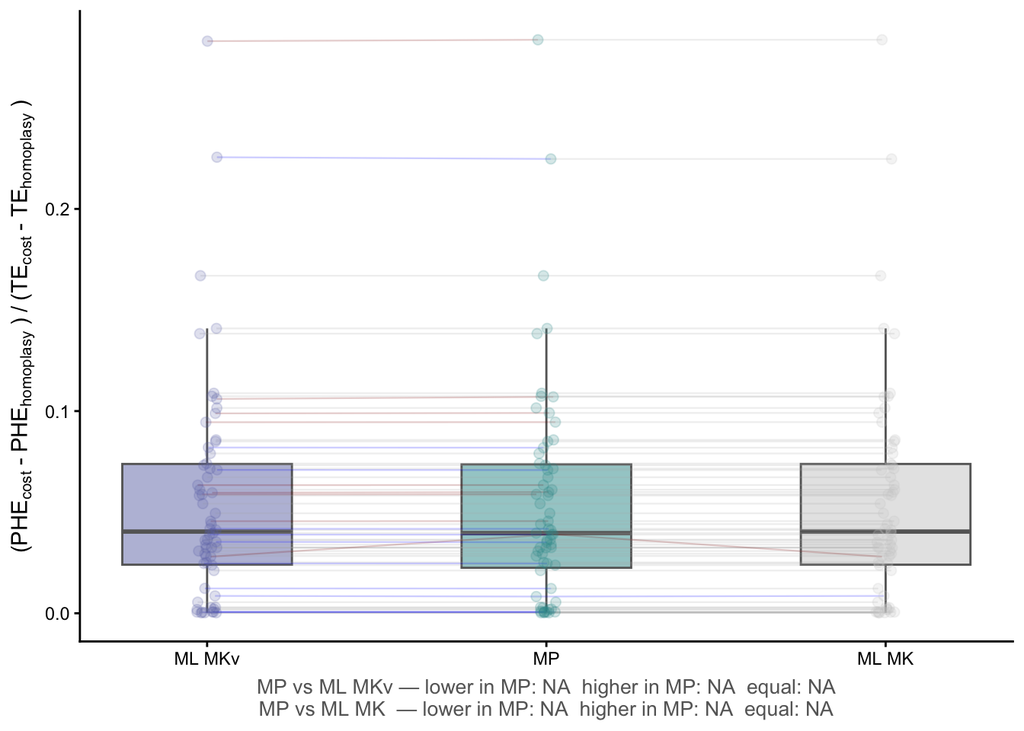

```r
# Compute counts (MP vs ML MKv)
n_lower_mkv <- sum(op3_q3_fri$op3_mp < op3_q3_fri$op3_ml_mkv)
n_higher_mkv <- sum(op3_q3_fri$op3_mp > op3_q3_fri$op3_ml_mkv)
n_equal_mkv  <- sum(op3_q3_fri$op3_mp == op3_q3_fri$op3_ml_mkv)
# Compute counts (MP vs ML MK)
n_lower_mk <- sum(op3_q3_fri$op3_mp < op3_q3_fri$op3_ml_mk)
n_higher_mk <- sum(op3_q3_fri$op3_mp > op3_q3_fri$op3_ml_mk)
n_equal_mk  <- sum(op3_q3_fri$op3_mp == op3_q3_fri$op3_ml_mk)
# Figure S5
cols <- c("op3_mp" = "#339999", "op3_ml_mkv" = "#6f77b4", "op3_ml_mk" = "#cccccc")
# Add row ID
op3_q3_fri$row_id <- 1:nrow(op3_q3_fri)
# Pre-compute jitter offsets (same seed) — smaller jitter
set.seed(42)
n <- nrow(op3_q3_fri)
jitter_offsets <- data.frame(
  row_id   = 1:n,
  jitter_1 = runif(n, -0.03, 0.03),
  jitter_2 = runif(n, -0.03, 0.03),
  jitter_3 = runif(n, -0.03, 0.03)
)
# Merge offsets — new order: ML MKv, MP, ML MK (positions 1, 2, 3)
df_jitter <- op3_q3_fri %>%
  left_join(jitter_offsets, by = "row_id") %>%
  mutate(
    x1 = 1 + jitter_1,  # ML MKv
    x2 = 2 + jitter_2,  # MP
    x3 = 3 + jitter_3,  # ML MK
    seg1_color = case_when(
      op3_ml_mkv < op3_mp ~ "darkred",
      op3_ml_mkv > op3_mp ~ "blue",
      TRUE                ~ "gray"
    ),
    seg2_color = case_when(
      op3_mp > op3_ml_mk ~ "darkred",
      op3_mp < op3_ml_mk ~ "blue",
      TRUE               ~ "gray"
    )
  )
# Convert to long format — new level order
df_long <- op3_q3_fri %>%
  pivot_longer(cols = c(op3_ml_mkv, op3_mp, op3_ml_mk),
               names_to  = "group",
               values_to = "value") %>%
  mutate(group = factor(group, levels = c("op3_ml_mkv", "op3_mp", "op3_ml_mk"))) %>%
  left_join(jitter_offsets, by = "row_id") %>%
  mutate(x_jittered = case_when(
    group == "op3_ml_mkv" ~ 1 + jitter_1,
    group == "op3_mp"     ~ 2 + jitter_2,
    group == "op3_ml_mk"  ~ 3 + jitter_3
  ))
# Plot
op3_plot=ggplot() +
  geom_boxplot(data = df_long,
               aes(x = as.numeric(group), y = value, fill = group),
               alpha = 0.5, outlier.shape = NA,
               color = "gray40", linewidth = 0.5, width = 0.5) +
  # Segments: ML MKv -> MP
  geom_segment(data = df_jitter,
               aes(x = x1, xend = x2, y = op3_ml_mkv, yend = op3_mp, color = seg1_color),
               linewidth = 0.4, alpha = 0.2) +
  # Segments: MP -> ML MK
  geom_segment(data = df_jitter,
               aes(x = x2, xend = x3, y = op3_mp, yend = op3_ml_mk, color = seg2_color),
               linewidth = 0.4, alpha = 0.2) +
  geom_point(data = df_long,
             aes(x = x_jittered, y = value, color = group),
             size = 2, alpha = 0.2) +
  scale_fill_manual(values = cols) +
  scale_color_manual(values = c(cols,
                                "darkred"  = "darkred",
                                "blue" = "blue",
                                "gray" = "gray70")) +
  theme_classic() +
  theme(legend.position = "none",
        axis.title.x    = element_blank()) +
  labs(y = expression("(PHE"["cost"] ~ "-" ~ "PHE"["homoplasy"] ~ ")" ~ "/" ~ "(TE"["cost"] ~ "-" ~ "TE"["homoplasy"] ~ ")")) +
  scale_x_continuous(breaks = 1:3,
                     labels = c("ML MKv", "MP", "ML MK"))+
  labs(
    y       = expression("(PHE"["cost"] ~ "-" ~ "PHE"["homoplasy"] ~ ")" ~ "/" ~ "(TE"["cost"] ~ "-" ~ "TE"["homoplasy"] ~ ")"),
    caption = paste0(
      "MP vs ML MKv — lower in MP: ", n_lower_mkv, "  higher in MP: ", n_higher_mkv, "  equal: ", n_equal_mkv, "\n",
      "MP vs ML MK  — lower in MP: ", n_lower_mk,  "  higher in MP: ", n_higher_mk,  "  equal: ", n_equal_mk
    )
  ) +
  theme(plot.caption = element_text(hjust = 0.5, size = 10, color = "gray40"))

op3_plot
```

```r
# Option 4. (PHEcost / TEcost) / PHEhomoplasy
op4_mp = (df_extinct$MP_MORPHonTE_Score / df_extinct$MP_TE_Score) / df_extinct$MP_MORPHonTE_homoplasy
op4_ml_mk = (df_extinct$ML_TNT_MORPHonTEnoASC_score / df_extinct$ML_TNT_TEnoASC_Score) / df_extinct$ML_TNT_MORPHonTEnoASC_homoplasies
op4_ml_mkv = (df_extinct$ML_TNT_MORPHonTEasc_score / df_extinct$ML_TNT_TEasc_Score) / df_extinct$ML_TNT_MORPHonTEasc_homoplasies

print("Number of times that contribution of PHE is higher in MP than ML MK")
```

```
## [1] "Number of times that contribution of PHE is higher in MP than ML MK"
```

```r
sum(op4_mp > op4_ml_mk)
```

```
## [1] NA
```

```r
print("Number of times that contribution of PHE is lower in MP than ML MK")
```

```
## [1] "Number of times that contribution of PHE is lower in MP than ML MK"
```

```r
sum(op4_mp < op4_ml_mk)
```

```
## [1] NA
```

```r
print("Number of times that contribution of PHE is equal in MP than ML MK")
```

```
## [1] "Number of times that contribution of PHE is equal in MP than ML MK"
```

```r
sum(op4_mp == op4_ml_mk)
```

```
## [1] NA
```

```r
print("Number of times that contribution of PHE is higher in MP than ML MKv")
```

```
## [1] "Number of times that contribution of PHE is higher in MP than ML MKv"
```

```r
sum(op4_mp > op4_ml_mkv)
```

```
## [1] 34
```

```r
print("Number of times that contribution of PHE is lower in MP than ML MKv")
```

```
## [1] "Number of times that contribution of PHE is lower in MP than ML MKv"
```

```r
sum(op4_mp < op4_ml_mkv)
```

```
## [1] 24
```

```r
print("Number of times that contribution of PHE is equal in MP than ML MKv")
```

```
## [1] "Number of times that contribution of PHE is equal in MP than ML MKv"
```

```r
sum(op4_mp == op4_ml_mkv)
```

```
## [1] 5
```

```r
print("Stats MP")
```

```
## [1] "Stats MP"
```

```r
mean(op4_mp)
```

```
## [1] 0.000456804
```

```r
sd(op4_mp)
```

```
## [1] 0.0007219169
```

```r
min(op4_mp)
```

```
## [1] 1.329673e-06
```

```r
max(op4_mp)
```

```
## [1] 0.00335784
```

```r
print("Stats ML MK")
```

```
## [1] "Stats ML MK"
```

```r
mean(op4_ml_mk)
```

```
## [1] NA
```

```r
sd(op4_ml_mk)
```

```
## [1] NA
```

```r
min(op4_ml_mk)
```

```
## [1] NA
```

```r
max(op4_ml_mk)
```

```
## [1] NA
```

```r
print("Stats ML MKv")
```

```
## [1] "Stats ML MKv"
```

```r
mean(op4_ml_mkv)
```

```
## [1] 0.0004568524
```

```r
sd(op4_ml_mkv)
```

```
## [1] 0.0007020646
```

```r
min(op4_ml_mkv)
```

```
## [1] 1.328889e-06
```

```r
max(op4_ml_mkv)
```

```
## [1] 0.00319016
```

```r
# Normality tests
shapiro.test(op4_mp) # p < 0.05, non-parametric
```

```
##
##  Shapiro-Wilk normality test
##
## data:  op4_mp
## W = 0.65806, p-value = 7.686e-11
```

```r
shapiro.test(op4_ml_mk) # p < 0.05, non-parametric
```

```
##
##  Shapiro-Wilk normality test
##
## data:  op4_ml_mk
## W = 0.67753, p-value = 2.168e-10
```

```r
shapiro.test(op4_ml_mkv) # p < 0.05, non-parametric
```

```
##
##  Shapiro-Wilk normality test
##
## data:  op4_ml_mkv
## W = 0.67329, p-value = 1.458e-10
```

```r
# Friedman test (non-parametric, multiple groups, paired values)
op4_q3_fri = data.frame(op4_mp, op4_ml_mk, op4_ml_mkv)
friedman.test(as.matrix(op4_q3_fri))
```

```
##
##  Friedman rank sum test
##
## data:  as.matrix(op4_q3_fri)
## Friedman chi-squared = 2.7917, df = 2, p-value = 0.2476
```

```r
# Wilcoxon: pairwise comparisons for paired values
pairwise.wilcox.test(x=unlist(op4_q3_fri),
                     g=factor(base::rep(names(op4_q3_fri), each = nrow(op4_q3_fri))),
                     paired=TRUE,
                     p.adjust.method="bonferroni")
```

```
##
##  Pairwise comparisons using Wilcoxon signed rank test with continuity correction
##
## data:  unlist(op4_q3_fri) and factor(base::rep(names(op4_q3_fri), each = nrow(op4_q3_fri)))
##
##            op4_ml_mk op4_ml_mkv
## op4_ml_mkv 0.56      -
## op4_mp     0.90      0.88
##
## P value adjustment method: bonferroni
```

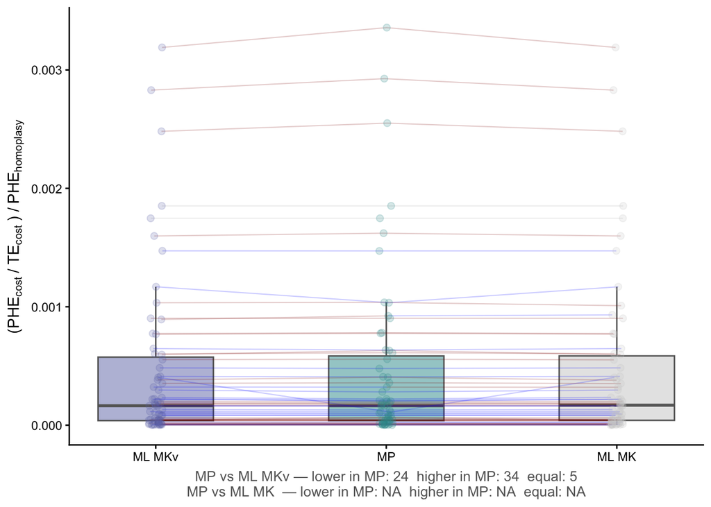

```r
# Compute counts (MP vs ML MKv)
n_lower_mkv <- sum(op4_q3_fri$op4_mp < op4_q3_fri$op4_ml_mkv)
n_higher_mkv <- sum(op4_q3_fri$op4_mp > op4_q3_fri$op4_ml_mkv)
n_equal_mkv  <- sum(op4_q3_fri$op4_mp == op4_q3_fri$op4_ml_mkv)
# Compute counts (MP vs ML MK)
n_lower_mk <- sum(op4_q3_fri$op4_mp < op4_q3_fri$op4_ml_mk)
n_higher_mk <- sum(op4_q3_fri$op4_mp > op4_q3_fri$op4_ml_mk)
n_equal_mk  <- sum(op4_q3_fri$op4_mp == op4_q3_fri$op4_ml_mk)
# Figure S5
cols <- c("op4_mp" = "#339999", "op4_ml_mkv" = "#6f77b4", "op4_ml_mk" = "#cccccc")
# Add row ID
op4_q3_fri$row_id <- 1:nrow(op4_q3_fri)
# Pre-compute jitter offsets (same seed) — smaller jitter
set.seed(42)
n <- nrow(op4_q3_fri)
jitter_offsets <- data.frame(
  row_id   = 1:n,
  jitter_1 = runif(n, -0.03, 0.03),
  jitter_2 = runif(n, -0.03, 0.03),
  jitter_3 = runif(n, -0.03, 0.03)
)
# Merge offsets — new order: ML MKv, MP, ML MK (positions 1, 2, 3)
df_jitter <- op4_q3_fri %>%
  left_join(jitter_offsets, by = "row_id") %>%
  mutate(
    x1 = 1 + jitter_1,  # ML MKv
    x2 = 2 + jitter_2,  # MP
    x3 = 3 + jitter_3,  # ML MK
    seg1_color = case_when(
      op4_ml_mkv < op4_mp ~ "darkred",
      op4_ml_mkv > op4_mp ~ "blue",
      TRUE                ~ "gray"
    ),
    seg2_color = case_when(
      op4_mp > op4_ml_mk ~ "darkred",
      op4_mp < op4_ml_mk ~ "blue",
      TRUE               ~ "gray"
    )
  )
# Convert to long format — new level order
df_long <- op4_q3_fri %>%
  pivot_longer(cols = c(op4_ml_mkv, op4_mp, op4_ml_mk),
               names_to  = "group",
               values_to = "value") %>%
  mutate(group = factor(group, levels = c("op4_ml_mkv", "op4_mp", "op4_ml_mk"))) %>%
  left_join(jitter_offsets, by = "row_id") %>%
  mutate(x_jittered = case_when(
    group == "op4_ml_mkv" ~ 1 + jitter_1,
    group == "op4_mp"     ~ 2 + jitter_2,
    group == "op4_ml_mk"  ~ 3 + jitter_3
  ))
# Plot
op4_plot=ggplot() +
  geom_boxplot(data = df_long,
               aes(x = as.numeric(group), y = value, fill = group),
               alpha = 0.5, outlier.shape = NA,
               color = "gray40", linewidth = 0.5, width = 0.5) +
  # Segments: ML MKv -> MP
  geom_segment(data = df_jitter,
               aes(x = x1, xend = x2, y = op4_ml_mkv, yend = op4_mp, color = seg1_color),
               linewidth = 0.4, alpha = 0.2) +
  # Segments: MP -> ML MK
  geom_segment(data = df_jitter,
               aes(x = x2, xend = x3, y = op4_mp, yend = op4_ml_mk, color = seg2_color),
               linewidth = 0.4, alpha = 0.2) +
  geom_point(data = df_long,
             aes(x = x_jittered, y = value, color = group),
             size = 2, alpha = 0.2) +
  scale_fill_manual(values = cols) +
  scale_color_manual(values = c(cols,
                                "darkred"  = "darkred",
                                "blue" = "blue",
                                "gray" = "gray70")) +
  theme_classic() +
  theme(legend.position = "none",
        axis.title.x    = element_blank()) +
  labs(y = expression("(PHE"["cost"] ~ "/" ~ "TE"["cost"] ~ ")" ~ "/" ~ "PHE"["homoplasy"])) +
  scale_x_continuous(breaks = 1:3,
                     labels = c("ML MKv", "MP", "ML MK"))+
  labs(
    y       = expression("(PHE"["cost"] ~ "/" ~ "TE"["cost"] ~ ")" ~ "/" ~ "PHE"["homoplasy"]),
    caption = paste0(
      "MP vs ML MKv — lower in MP: ", n_lower_mkv, "  higher in MP: ", n_higher_mkv, "  equal: ", n_equal_mkv, "\n",
      "MP vs ML MK  — lower in MP: ", n_lower_mk,  "  higher in MP: ", n_higher_mk,  "  equal: ", n_equal_mk
    )
  ) +
  theme(plot.caption = element_text(hjust = 0.5, size = 10, color = "gray40"))

op4_plot
```

```r
# Option 5. (PHEcost x PHEci) / (TEcost x TEci)
op5_mp = (df_extinct$MP_MORPHonTE_Score * df_extinct$MP_MORPHonTE_CI) / (df_extinct$MP_TE_Score * df_extinct$MP_TE_CI)
op5_ml_mk = (df_extinct$ML_TNT_MORPHonTEnoASC_score * df_extinct$ML_TNT_MORPHonTEnoASC_CI) / (df_extinct$ML_TNT_TEnoASC_Score * df_extinct$ML_TNT_TEnoASC_CI)
op5_ml_mkv = (df_extinct$ML_TNT_MORPHonTEasc_score * df_extinct$ML_TNT_MORPHonTEasc_CI) / (df_extinct$ML_TNT_TEasc_Score * df_extinct$ML_TNT_TEasc_CI)

print("Number of times that contribution of PHE is higher in MP than ML MK")
```

```
## [1] "Number of times that contribution of PHE is higher in MP than ML MK"
```

```r
sum(op5_mp > op5_ml_mk)
```

```
## [1] NA
```

```r
print("Number of times that contribution of PHE is lower in MP than ML MK")
```

```
## [1] "Number of times that contribution of PHE is lower in MP than ML MK"
```

```r
sum(op5_mp < op5_ml_mk)
```

```
## [1] NA
```

```r
print("Number of times that contribution of PHE is equal in MP than ML MK")
```

```
## [1] "Number of times that contribution of PHE is equal in MP than ML MK"
```

```r
sum(op5_mp == op5_ml_mk)
```

```
## [1] NA
```

```r
print("Number of times that contribution of PHE is higher in MP than ML MKv")
```

```
## [1] "Number of times that contribution of PHE is higher in MP than ML MKv"
```

```r
sum(op5_mp > op5_ml_mkv)
```

```
## [1] NA
```

```r
print("Number of times that contribution of PHE is lower in MP than ML MKv")
```

```
## [1] "Number of times that contribution of PHE is lower in MP than ML MKv"
```

```r
sum(op5_mp < op5_ml_mkv)
```

```
## [1] NA
```

```r
print("Number of times that contribution of PHE is equal in MP than ML MKv")
```

```
## [1] "Number of times that contribution of PHE is equal in MP than ML MKv"
```

```r
sum(op5_mp == op5_ml_mkv)
```

```
## [1] NA
```

```r
print("Stats MP")
```

```
## [1] "Stats MP"
```

```r
mean(op5_mp)
```

```
## [1] 0.05428266
```

```r
sd(op5_mp)
```

```
## [1] 0.05359927
```

```r
min(op5_mp)
```

```
## [1] 0.0002311025
```

```r
max(op5_mp)
```

```
## [1] 0.2835245
```

```r
print("Stats ML MK")
```

```
## [1] "Stats ML MK"
```

```r
mean(op5_ml_mk)
```

```
## [1] NA
```

```r
sd(op5_ml_mk)
```

```
## [1] NA
```

```r
min(op5_ml_mk)
```

```
## [1] NA
```

```r
max(op5_ml_mk)
```

```
## [1] NA
```

```r
print("Stats ML MKv")
```

```
## [1] "Stats ML MKv"
```

```r
mean(op5_ml_mkv)
```

```
## [1] NA
```

```r
sd(op5_ml_mkv)
```

```
## [1] NA
```

```r
min(op5_ml_mkv)
```

```
## [1] NA
```

```r
max(op5_ml_mkv)
```

```
## [1] NA
```

```r
# Normality tests
shapiro.test(op5_mp) # p < 0.05, non-parametric
```

```
##
##  Shapiro-Wilk normality test
##
## data:  op5_mp
## W = 0.82512, p-value = 3.667e-07
```

```r
shapiro.test(op5_ml_mk) # p < 0.05, non-parametric
```

```
##
##  Shapiro-Wilk normality test
##
## data:  op5_ml_mk
## W = 0.82859, p-value = 6.365e-07
```

```r
shapiro.test(op5_ml_mkv) # p < 0.05, non-parametric
```

```
##
##  Shapiro-Wilk normality test
##
## data:  op5_ml_mkv
## W = 0.82716, p-value = 4.925e-07
```

```r
# Friedman test (non-parametric, multiple groups, paired values)
op5_q3_fri <- data.frame(op5_mp, op5_ml_mk, op5_ml_mkv) %>%
  filter(is.finite(op5_mp) & is.finite(op5_ml_mk) & is.finite(op5_ml_mkv))
friedman.test(as.matrix(op5_q3_fri))
```

```
##
##  Friedman rank sum test
##
## data:  as.matrix(op5_q3_fri)
## Friedman chi-squared = 4.6667, df = 2, p-value = 0.09697
```

```r
# Wilcoxon: pairwise comparisons for paired values
pairwise.wilcox.test(x=unlist(op5_q3_fri),
                     g=factor(base::rep(names(op5_q3_fri), each = nrow(op5_q3_fri))),
                     paired=TRUE,
                     p.adjust.method="bonferroni")
```

```
##
##  Pairwise comparisons using Wilcoxon signed rank test with continuity correction
##
## data:  unlist(op5_q3_fri) and factor(base::rep(names(op5_q3_fri), each = nrow(op5_q3_fri)))
##
##            op5_ml_mk op5_ml_mkv
## op5_ml_mkv 1.000     -
## op5_mp     0.043     0.123
##
## P value adjustment method: bonferroni
```

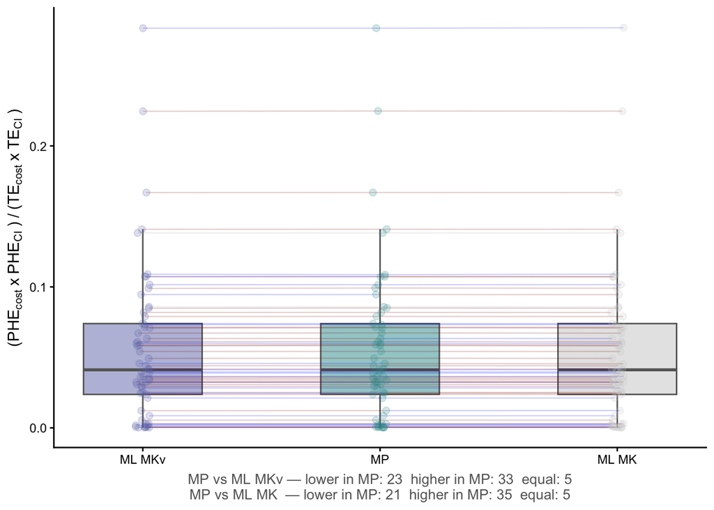

```r
# Compute counts (MP vs ML MKv)
n_lower_mkv <- sum(op5_q3_fri$op5_mp < op5_q3_fri$op5_ml_mkv)
n_higher_mkv <- sum(op5_q3_fri$op5_mp > op5_q3_fri$op5_ml_mkv)
n_equal_mkv  <- sum(op5_q3_fri$op5_mp == op5_q3_fri$op5_ml_mkv)
# Compute counts (MP vs ML MK)
n_lower_mk <- sum(op5_q3_fri$op5_mp < op5_q3_fri$op5_ml_mk)
n_higher_mk <- sum(op5_q3_fri$op5_mp > op5_q3_fri$op5_ml_mk)
n_equal_mk  <- sum(op5_q3_fri$op5_mp == op5_q3_fri$op5_ml_mk)
# Figure S5
cols <- c("op5_mp" = "#339999", "op5_ml_mkv" = "#6f77b4", "op5_ml_mk" = "#cccccc")
# Add row ID
op5_q3_fri$row_id <- 1:nrow(op5_q3_fri)
# Pre-compute jitter offsets (same seed) — smaller jitter
set.seed(42)
n <- nrow(op5_q3_fri)
jitter_offsets <- data.frame(
  row_id   = 1:n,
  jitter_1 = runif(n, -0.03, 0.03),
  jitter_2 = runif(n, -0.03, 0.03),
  jitter_3 = runif(n, -0.03, 0.03)
)
# Merge offsets — new order: ML MKv, MP, ML MK (positions 1, 2, 3)
df_jitter <- op5_q3_fri %>%
  left_join(jitter_offsets, by = "row_id") %>%
  mutate(
    x1 = 1 + jitter_1,  # ML MKv
    x2 = 2 + jitter_2,  # MP
    x3 = 3 + jitter_3,  # ML MK
    seg1_color = case_when(
      op5_ml_mkv < op5_mp ~ "darkred",
      op5_ml_mkv > op5_mp ~ "blue",
      TRUE                ~ "gray"
    ),
    seg2_color = case_when(
      op5_mp > op5_ml_mk ~ "darkred",
      op5_mp < op5_ml_mk ~ "blue",
      TRUE               ~ "gray"
    )
  )
# Convert to long format — new level order
df_long <- op5_q3_fri %>%
  pivot_longer(cols = c(op5_ml_mkv, op5_mp, op5_ml_mk),
               names_to  = "group",
               values_to = "value") %>%
  mutate(group = factor(group, levels = c("op5_ml_mkv", "op5_mp", "op5_ml_mk"))) %>%
  left_join(jitter_offsets, by = "row_id") %>%
  mutate(x_jittered = case_when(
    group == "op5_ml_mkv" ~ 1 + jitter_1,
    group == "op5_mp"     ~ 2 + jitter_2,
    group == "op5_ml_mk"  ~ 3 + jitter_3
  ))
# Plot
op5_plot=ggplot() +
  geom_boxplot(data = df_long,
               aes(x = as.numeric(group), y = value, fill = group),
               alpha = 0.5, outlier.shape = NA,
               color = "gray40", linewidth = 0.5, width = 0.5) +
  # Segments: ML MKv -> MP
  geom_segment(data = df_jitter,
               aes(x = x1, xend = x2, y = op5_ml_mkv, yend = op5_mp, color = seg1_color),
               linewidth = 0.4, alpha = 0.2) +
  # Segments: MP -> ML MK
  geom_segment(data = df_jitter,
               aes(x = x2, xend = x3, y = op5_mp, yend = op5_ml_mk, color = seg2_color),
               linewidth = 0.4, alpha = 0.2) +
  geom_point(data = df_long,
             aes(x = x_jittered, y = value, color = group),
             size = 2, alpha = 0.2) +
  scale_fill_manual(values = cols) +
  scale_color_manual(values = c(cols,
                                "darkred"  = "darkred",
                                "blue" = "blue",
                                "gray" = "gray70")) +
  theme_classic() +
  theme(legend.position = "none",
        axis.title.x    = element_blank()) +
  labs(y = expression("(PHE"["cost"] ~ "x" ~ "PHE"["CI"] ~ ")" ~ "/" ~ "(TE"["cost"]) ~ "x" ~ "TE"["CI"]~ ")") +
  scale_x_continuous(breaks = 1:3,
                     labels = c("ML MKv", "MP", "ML MK"))+
  labs(  y       = expression("(PHE"["cost"] ~ "x" ~ "PHE"["CI"] ~ ")" ~ "/" ~ "(TE"["cost"] ~ "x" ~ "TE"["CI"] ~ ")"),
         caption = paste0(
      "MP vs ML MKv — lower in MP: ", n_lower_mkv, "  higher in MP: ", n_higher_mkv, "  equal: ", n_equal_mkv, "\n",
      "MP vs ML MK  — lower in MP: ", n_lower_mk,  "  higher in MP: ", n_higher_mk,  "  equal: ", n_equal_mk
    )
  ) +
  theme(plot.caption = element_text(hjust = 0.5, size = 10, color = "gray40"))

op5_plot
```

```r
# Option 6. (PHEcost x PHEri) / (TEcost x TEri)
op6_mp = (df_extinct$MP_MORPHonTE_Score * df_extinct$MP_MORPHonTE_RI) / (df_extinct$MP_TE_Score * df_extinct$MP_TE_RI)
op6_ml_mk = (df_extinct$ML_TNT_MORPHonTEnoASC_score * df_extinct$ML_TNT_MORPHonTEnoASC_RI) / (df_extinct$ML_TNT_TEnoASC_Score * df_extinct$ML_TNT_TEnoASC_RI)
op6_ml_mkv = (df_extinct$ML_TNT_MORPHonTEasc_score * df_extinct$ML_TNT_MORPHonTEasc_RI) / (df_extinct$ML_TNT_TEasc_Score * df_extinct$ML_TNT_TEasc_RI)

print("Number of times that contribution of PHE is higher in MP than ML MK")
```

```
## [1] "Number of times that contribution of PHE is higher in MP than ML MK"
```

```r
sum(op6_mp > op6_ml_mk)
```

```
## [1] NA
```

```r
print("Number of times that contribution of PHE is lower in MP than ML MK")
```

```
## [1] "Number of times that contribution of PHE is lower in MP than ML MK"
```

```r
sum(op6_mp < op6_ml_mk)
```

```
## [1] NA
```

```r
print("Number of times that contribution of PHE is equal in MP than ML MK")
```

```
## [1] "Number of times that contribution of PHE is equal in MP than ML MK"
```

```r
sum(op6_mp == op6_ml_mk)
```

```
## [1] NA
```

```r
print("Number of times that contribution of PHE is higher in MP than ML MKv")
```

```
## [1] "Number of times that contribution of PHE is higher in MP than ML MKv"
```

```r
sum(op6_mp > op6_ml_mkv)
```

```
## [1] NA
```

```r
print("Number of times that contribution of PHE is lower in MP than ML MKv")
```

```
## [1] "Number of times that contribution of PHE is lower in MP than ML MKv"
```

```r
sum(op6_mp < op6_ml_mkv)
```

```
## [1] NA
```

```r
print("Number of times that contribution of PHE is equal in MP than ML MKv")
```

```
## [1] "Number of times that contribution of PHE is equal in MP than ML MKv"
```

```r
sum(op6_mp == op6_ml_mkv)
```

```
## [1] NA
```

```r
print("Stats MP")
```

```
## [1] "Stats MP"
```

```r
mean(op6_mp)
```

```
## [1] 0.07978228
```

```r
sd(op6_mp)
```

```
## [1] 0.07781803
```

```r
min(op6_mp)
```

```
## [1] 7.260521e-05
```

```r
max(op6_mp)
```

```
## [1] 0.3788778
```

```r
print("Stats ML MK")
```

```
## [1] "Stats ML MK"
```

```r
mean(op6_ml_mk)
```

```
## [1] NA
```

```r
sd(op6_ml_mk)
```

```
## [1] NA
```

```r
min(op6_ml_mk)
```

```
## [1] NA
```

```r
max(op6_ml_mk)
```

```
## [1] NA
```

```r
print("Stats ML MKv")
```

```
## [1] "Stats ML MKv"
```

```r
mean(op6_ml_mkv)
```

```
## [1] NA
```

```r
sd(op6_ml_mkv)
```

```
## [1] NA
```

```r
min(op6_ml_mkv)
```

```
## [1] NA
```

```r
max(op6_ml_mkv)
```

```
## [1] NA
```

```r
# Normality tests
shapiro.test(op6_mp) # p < 0.05, non-parametric
```

```
##
##  Shapiro-Wilk normality test
##
## data:  op6_mp
## W = 0.83812, p-value = 8.537e-07
```

```r
shapiro.test(op6_ml_mk) # p < 0.05, non-parametric
```

```
##
##  Shapiro-Wilk normality test
##
## data:  op6_ml_mk
## W = 0.83828, p-value = 1.189e-06
```

```r
shapiro.test(op6_ml_mkv) # p < 0.05, non-parametric
```

```
##
##  Shapiro-Wilk normality test
##
## data:  op6_ml_mkv
## W = 0.83575, p-value = 8.572e-07
```

```r
# Friedman test (non-parametric, multiple groups, paired values)
op6_q3_fri <- data.frame(op6_mp, op6_ml_mk, op6_ml_mkv) %>%
  filter(is.finite(op6_mp) & is.finite(op6_ml_mk) & is.finite(op6_ml_mkv))
friedman.test(as.matrix(op6_q3_fri))
```

```
##
##  Friedman rank sum test
##
## data:  as.matrix(op6_q3_fri)
## Friedman chi-squared = 2.0423, df = 2, p-value = 0.3602
```

```r
# Wilcoxon: pairwise comparisons for paired values
pairwise.wilcox.test(x=unlist(op6_q3_fri),
                     g=factor(base::rep(names(op6_q3_fri), each = nrow(op6_q3_fri))),
                     paired=TRUE,
                     p.adjust.method="bonferroni")
```

```
##
##  Pairwise comparisons using Wilcoxon signed rank test with continuity correction
##
## data:  unlist(op6_q3_fri) and factor(base::rep(names(op6_q3_fri), each = nrow(op6_q3_fri)))
##
##            op6_ml_mk op6_ml_mkv
## op6_ml_mkv 1.00      -
## op6_mp     0.93      0.38
##
## P value adjustment method: bonferroni
```

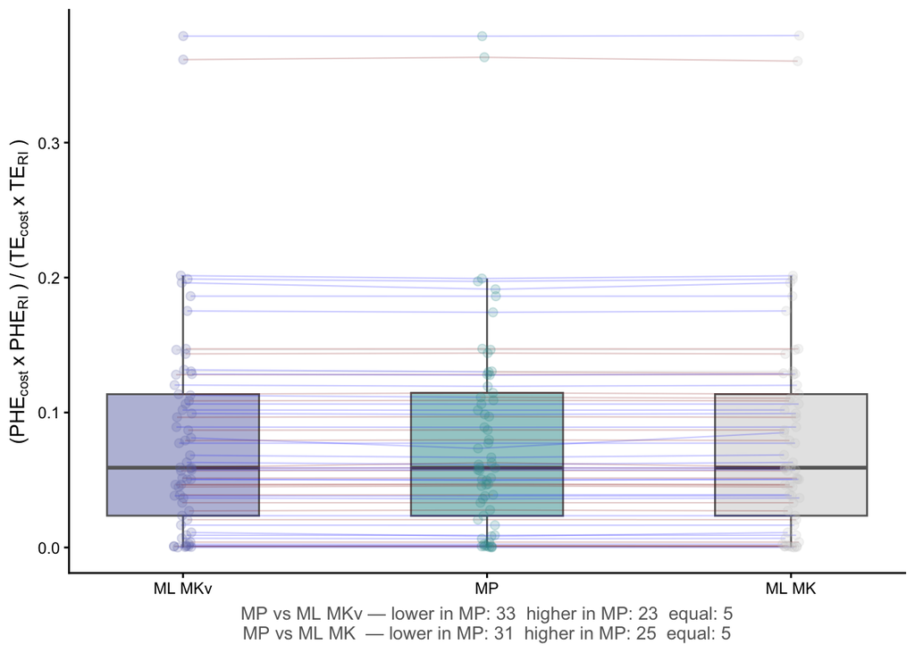

```r
# Compute counts (MP vs ML MKv)
n_lower_mkv <- sum(op6_q3_fri$op6_mp < op6_q3_fri$op6_ml_mkv)
n_higher_mkv <- sum(op6_q3_fri$op6_mp > op6_q3_fri$op6_ml_mkv)
n_equal_mkv  <- sum(op6_q3_fri$op6_mp == op6_q3_fri$op6_ml_mkv)
# Compute counts (MP vs ML MK)
n_lower_mk <- sum(op6_q3_fri$op6_mp < op6_q3_fri$op6_ml_mk)
n_higher_mk <- sum(op6_q3_fri$op6_mp > op6_q3_fri$op6_ml_mk)
n_equal_mk  <- sum(op6_q3_fri$op6_mp == op6_q3_fri$op6_ml_mk)
# Figure S5
cols <- c("op6_mp" = "#339999", "op6_ml_mkv" = "#6f77b4", "op6_ml_mk" = "#cccccc")
# Add row ID
op6_q3_fri$row_id <- 1:nrow(op6_q3_fri)
# Pre-compute jitter offsets (same seed) — smaller jitter
set.seed(42)
n <- nrow(op6_q3_fri)
jitter_offsets <- data.frame(
  row_id   = 1:n,
  jitter_1 = runif(n, -0.03, 0.03),
  jitter_2 = runif(n, -0.03, 0.03),
  jitter_3 = runif(n, -0.03, 0.03)
)
# Merge offsets — new order: ML MKv, MP, ML MK (positions 1, 2, 3)
df_jitter <- op6_q3_fri %>%
  left_join(jitter_offsets, by = "row_id") %>%
  mutate(
    x1 = 1 + jitter_1,  # ML MKv
    x2 = 2 + jitter_2,  # MP
    x3 = 3 + jitter_3,  # ML MK
    seg1_color = case_when(
      op6_ml_mkv < op6_mp ~ "darkred",
      op6_ml_mkv > op6_mp ~ "blue",
      TRUE                ~ "gray"
    ),
    seg2_color = case_when(
      op6_mp > op6_ml_mk ~ "darkred",
      op6_mp < op6_ml_mk ~ "blue",
      TRUE               ~ "gray"
    )
  )
# Convert to long format — new level order
df_long <- op6_q3_fri %>%
  pivot_longer(cols = c(op6_ml_mkv, op6_mp, op6_ml_mk),
               names_to  = "group",
               values_to = "value") %>%
  mutate(group = factor(group, levels = c("op6_ml_mkv", "op6_mp", "op6_ml_mk"))) %>%
  left_join(jitter_offsets, by = "row_id") %>%
  mutate(x_jittered = case_when(
    group == "op6_ml_mkv" ~ 1 + jitter_1,
    group == "op6_mp"     ~ 2 + jitter_2,
    group == "op6_ml_mk"  ~ 3 + jitter_3
  ))
# Plot
op6_plot=ggplot() +
  geom_boxplot(data = df_long,
               aes(x = as.numeric(group), y = value, fill = group),
               alpha = 0.5, outlier.shape = NA,
               color = "gray40", linewidth = 0.5, width = 0.5) +
  # Segments: ML MKv -> MP
  geom_segment(data = df_jitter,
               aes(x = x1, xend = x2, y = op6_ml_mkv, yend = op6_mp, color = seg1_color),
               linewidth = 0.4, alpha = 0.2) +
  # Segments: MP -> ML MK
  geom_segment(data = df_jitter,
               aes(x = x2, xend = x3, y = op6_mp, yend = op6_ml_mk, color = seg2_color),
               linewidth = 0.4, alpha = 0.2) +
  geom_point(data = df_long,
             aes(x = x_jittered, y = value, color = group),
             size = 2, alpha = 0.2) +
  scale_fill_manual(values = cols) +
  scale_color_manual(values = c(cols,
                                "darkred"  = "darkred",
                                "blue" = "blue",
                                "gray" = "gray70")) +
  theme_classic() +
  theme(legend.position = "none",
        axis.title.x    = element_blank()) +
  labs(y = expression("(PHE"["cost"] ~ "x" ~ "PHE"["RI"] ~ ")" ~ "/" ~ "(TE"["cost"]) ~ "x" ~ "TE"["RI"]~ ")") +
  scale_x_continuous(breaks = 1:3,
                     labels = c("ML MKv", "MP", "ML MK"))+
  labs(  y       = expression("(PHE"["cost"] ~ "x" ~ "PHE"["RI"] ~ ")" ~ "/" ~ "(TE"["cost"] ~ "x" ~ "TE"["RI"] ~ ")"),
         caption = paste0(
      "MP vs ML MKv — lower in MP: ", n_lower_mkv, "  higher in MP: ", n_higher_mkv, "  equal: ", n_equal_mkv, "\n",
      "MP vs ML MK  — lower in MP: ", n_lower_mk,  "  higher in MP: ", n_higher_mk,  "  equal: ", n_equal_mk
    )
  ) +
  theme(plot.caption = element_text(hjust = 0.5, size = 10, color = "gray40"))

op6_plot
```

### Q3.3.3 Size analyses (Figure S10)

```r
# Contribution of morphology between NGS and Sanger

# Load data for extant taxa
df <- read.csv("Dataset_R_q123_07-26.csv")

# Option 1. PHEcost / TEcost
op1_mp = (df$MP_MORPHonTE_Score) / (df$MP_TE_Score)
op1_ml_mk = (df$ML_TNT_MORPHonTEnoASC_score) / (df$ML_TNT_TEnoASC_Score)
op1_ml_mkv = (df$ML_TNT_MORPHonTEasc_score) / (df$ML_TNT_TEasc_Score)

op1_q3 = data.frame(op1_mp, op1_ml_mk, op1_ml_mkv)
# Add row ID
op1_q3$row_id <- 1:nrow(op1_q3)
# Add NGS x Sanger
op1_q3$sequencing = df$Sequencing
# Add Extant x Extinct
op1_q3$taxa = df$Type
# Add %Morphological characters
op1_q3$percentageMorphCharacters = df$X.Morph.Total

# Convert to long format
df_long <- op1_q3 %>%
  pivot_longer(
    cols = c(op1_mp, op1_ml_mk, op1_ml_mkv),
    names_to = "Method",
    values_to = "Value"
  ) %>%
  mutate(
    Method = factor(
      Method,
      levels = c("op1_mp", "op1_ml_mk", "op1_ml_mkv"),
      labels = c("MP", "ML-Mk", "ML-MkV")
    )
  )

# Plot
figs9 = ggplot(df_long, aes(x = sequencing, y = Value, fill = sequencing)) +
  geom_boxplot(width = 0.6, outlier.shape = NA, alpha = 0.6) +
  geom_jitter(
    width = 0.15,
    size = 1.8,
    alpha = 0.2,
    color = "gray"
  ) +
  stat_compare_means(
  comparisons = list(c("Sanger", "NGS")),
  method = "wilcox.test",
  paired = F,
  label = "p.format",
  label.y = max(df_long$Value, na.rm = TRUE) * 1.05, bracket.size = 0
) +
  facet_wrap(~Method, nrow = 1) +
  scale_fill_manual(values = c(
    "Sanger" = "#4E79A7",
    "NGS" = "#E15759"
  )) +
  labs(
    x = "",
    y = "Morphological score / TE score\n"
  ) +
  theme_classic(base_size = 14) +
  theme(
    legend.position = "none",
    strip.background = element_blank(),
    strip.text = element_text(face = "plain")
  )
```

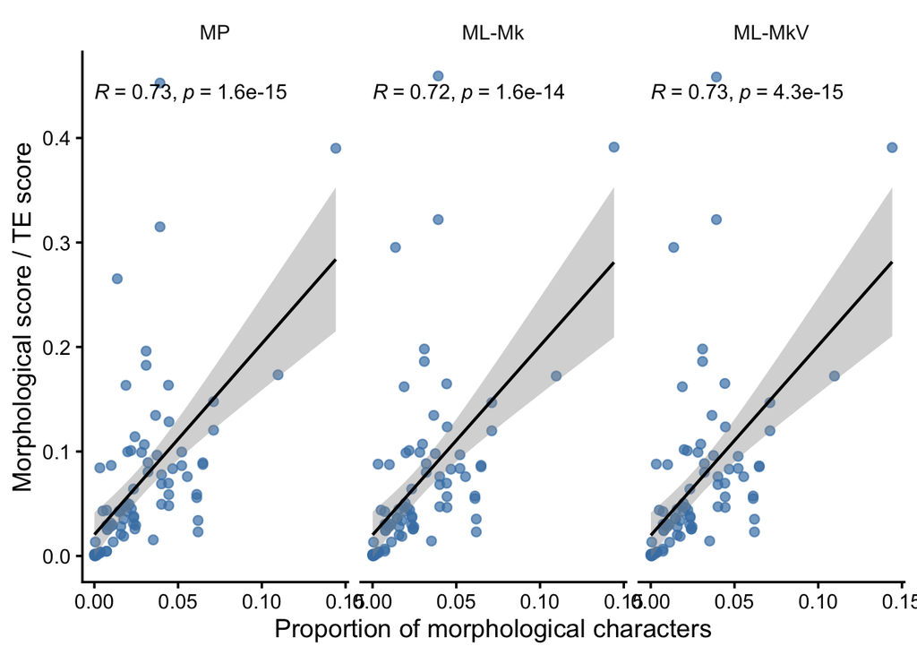

```r
# Contribution of morphology vs %Morphological characters

# Convert to long format
df_long <- op1_q3 %>%
  pivot_longer(
    cols = c(op1_mp, op1_ml_mk, op1_ml_mkv),
    names_to = "Method",
    values_to = "OP1"
  ) %>%
  mutate(
    Method = factor(
      Method,
      levels = c("op1_mp", "op1_ml_mk", "op1_ml_mkv"),
      labels = c("MP", "ML-Mk", "ML-MkV")
    )
  )

# Plot
figs9b <- ggplot(df_long,
              aes(x = percentageMorphCharacters, y = OP1)) +
  geom_point(
    size = 2,
    alpha = 0.7,
    color = "steelblue"
  ) +
  geom_smooth(
    method = "lm",
    se = TRUE,
    color = "black",
    linewidth = 0.8
  ) +
  facet_wrap(~Method, nrow = 1) +
  labs(
    x = "Proportion of morphological characters",
    y = "Morphological score / TE score"
  ) +
  theme_classic(base_size = 14) +
  theme(
    strip.background = element_blank(),
    strip.text = element_text(face = "plain")
  )

figs9b = figs9b +
  stat_cor(
    method = "spearman",
    label.x.npc = "left",
    label.y.npc = "top",
    size = 4
  )
figs9b
```

```r
# Figure S10
fig <- figs9 /
       figs9b +
  plot_annotation(tag_levels = "a") &
  theme(
    plot.tag = element_text(size = 16, face = "plain"),
    plot.tag.position = c(0.02, 0.98)
  )

ggsave(
  "Figures/FigS10.jpg",
  fig,
  width = 10,
  height = 8,
  units = "in",
  dpi = 300
)
```

# Q4. How do bootstrap values of shared clades differ between MOL and TE trees?

## Q4.1 Unique vs Shared

Before testing the differences of BS values in shared clades between MOL and TE trees, let’s explore the differences of BS values between shared and unique clades.

First, we need to format the extant datasets.

```r
# Load shared clades
df_shared = read.csv ("/Users/labanfibios/Desktop/Doutorado/Project/B2_TEvsMOL/GitHub/Dataset_R_q4_07-26_shared.csv")
# Load unique clades
df_unique = read.csv ("/Users/labanfibios/Desktop/Doutorado/Project/B2_TEvsMOL/GitHub/Dataset_R_q4_07-26_unique.csv")

# Rename the column Analysis to Dataset
df_unique <- df_unique %>%
  rename(Dataset = Analysis)
# Rename the column Method to Optimality
df_unique <- df_unique %>%
  rename(Optimality = Method)
# Rename the column Type to Analysis
df_unique <- df_unique %>%
  rename(Analysis = Type)
# Create a new column called Type (unique vs shared)
df_unique <- df_unique %>%
  dplyr::mutate(Type = "unique")

# Create a new dataframe from df_shared with the selected columns
df_shared_stack <- df_shared %>%
  transmute(
    Dataset = Dataset,
    Analysis = "MOL",                 # new value
    Optimality = Optimality,
    Node = Node_Tree_1,               # take Node_Tree_1
    Support = Support_Tree_1,         # take Support_Tree_1
    Type = "shared"                   # new value
  )
# Bind the new rows below df_unique
df_unique_extended <- bind_rows(df_unique, df_shared_stack)
# Create a new dataframe from df_shared for Tree 2
df_shared_stack2 <- df_shared %>%
  transmute(
    Dataset = Dataset,
    Analysis = "TE",                  # new value for Tree 2
    Optimality = Optimality,
    Node = Node_Tree_2,               # take Node_Tree_2
    Support = Support_Tree_2,         # take Support_Tree_2
    Type = "shared"                   # new value
  )
# Append Tree 2 rows to df_unique_extended (which already contains Tree 1 and unique rows)
df_uniqueVSshared <- bind_rows(df_unique_extended, df_shared_stack2)

# Rename
df_uniqueVSshared <- df_uniqueVSshared %>%
  mutate(
    Optimality = recode(
      Optimality,
      "ML-ASC" = "ML_ASC",
      "ML-noASC" = "ML_noASC"
    )
  )
# Add the column Sampling (without fossils vs with fossils)
df_uniqueVSshared <- df_uniqueVSshared %>%
  mutate(Sampling = "Without_fossils")

#View(df_uniqueVSshared)
```

```r
# Table 2
summary_stats <- df_uniqueVSshared %>%
  group_by(Analysis, Optimality, Type, Sampling) %>%
  summarise(
    n = n(),
    mean_support = mean(Support, na.rm = TRUE),
    sd_support = sd(Support, na.rm = TRUE),
    .groups = "drop"
  )
summary_stats
```

```
## # A tibble: 12 × 7
##    Analysis Optimality Type   Sampling            n mean_support sd_support
##    <chr>    <chr>      <chr>  <chr>           <int>        <dbl>      <dbl>
##  1 MOL      ML_ASC     shared Without_fossils  2988         95.4      10.1
##  2 MOL      ML_ASC     unique Without_fossils   337         78.2      16.0
##  3 MOL      ML_noASC   shared Without_fossils  2965         95.6       9.90
##  4 MOL      ML_noASC   unique Without_fossils   348         78.3      16.0
##  5 MOL      MP         shared Without_fossils  2569         90.8      13.8
##  6 MOL      MP         unique Without_fossils   150         62.5      12.3
##  7 TE       ML_ASC     shared Without_fossils  2988         96.4       8.88
##  8 TE       ML_ASC     unique Without_fossils   356         79.2      16.2
##  9 TE       ML_noASC   shared Without_fossils  2965         96.4       8.79
## 10 TE       ML_noASC   unique Without_fossils   361         79.9      16.5
## 11 TE       MP         shared Without_fossils  2569         91.7      13.3
## 12 TE       MP         unique Without_fossils   203         66.2      13.4
```

Now, we need to format the datasets including fossils.

```r
# Load shared clades
df_shared = read.csv ("/Users/labanfibios/Desktop/Doutorado/Project/B2_TEvsMOL/GitHub/Dataset_R_q4_09-25_shared_extinct.csv")
# Load unique clades
df_unique = read.csv ("/Users/labanfibios/Desktop/Doutorado/Project/B2_TEvsMOL/GitHub/Dataset_R_q4_09-25_unique_extinct.csv")

# Rename the column Analysis to Dataset
df_unique <- df_unique %>%
  rename(Dataset = Analysis)
# Rename the column Method to Optimality
df_unique <- df_unique %>%
  rename(Optimality = Method)
# Rename the column Type to Analysis
df_unique <- df_unique %>%
  rename(Analysis = Type)
# Create a new column called Type (unique vs shared)
df_unique <- df_unique %>%
  dplyr::mutate(Type = "unique")

# Create a new dataframe from df_shared with the selected columns
df_shared_stack <- df_shared %>%
  transmute(
    Dataset = Dataset,
    Analysis = "MOL",                 # new value
    Optimality = Optimality,
    Node = Node_Tree_1,               # take Node_Tree_1
    Support = Support_Tree_1,         # take Support_Tree_1
    Type = "shared"                   # new value
  )
# Bind the new rows below df_unique
df_unique_extended <- bind_rows(df_unique, df_shared_stack)
# Create a new dataframe from df_shared for Tree 2
df_shared_stack2 <- df_shared %>%
  transmute(
    Dataset = Dataset,
    Analysis = "TE",                  # new value for Tree 2
    Optimality = Optimality,
    Node = Node_Tree_2,               # take Node_Tree_2
    Support = Support_Tree_2,         # take Support_Tree_2
    Type = "shared"                   # new value
  )
# Append Tree 2 rows to df_unique_extended (which already contains Tree 1 and unique rows)
df_uniqueVSshared_extinct <- bind_rows(df_unique_extended, df_shared_stack2)

# Rename
df_uniqueVSshared_extinct <- df_uniqueVSshared_extinct %>%
  mutate(
    Optimality = recode(
      Optimality,
      "ML-ASC" = "ML_ASC",
      "ML-noASC" = "ML_noASC"
    )
  )
# Add column Sampling (with vs without fossils)
df_uniqueVSshared_extinct <- df_uniqueVSshared_extinct %>%
  mutate(Sampling = "With_fossils")

# The names of the datasets are 1 .. 2. We need to corrected them to the original names
map <- c(
  "1"=3, "2"=7, "3"=8, "4"=9, "5"=10, "6"=11, "7"=13, "8"=17, "9"=21,
  "10"=24, "11"=28, "12"=29, "13"=31, "14"=38, "15"=39, "16"=40,
  "17"=42, "18"=46, "19"=48, "20"=52, "21"=54, "22"=58
)
df_uniqueVSshared_extinct$Dataset <- map[as.character(df_uniqueVSshared_extinct$Dataset)]

#View(df_uniqueVSshared_extinct)
```

```r
# Table 2
summary_stats <- df_uniqueVSshared_extinct %>%
  group_by(Analysis, Optimality, Type, Sampling) %>%
  summarise(
    n = n(),
    mean_support = mean(Support, na.rm = TRUE),
    sd_support = sd(Support, na.rm = TRUE),
    .groups = "drop"
  )
summary_stats
```

```
## # A tibble: 12 × 7
##    Analysis Optimality Type   Sampling         n mean_support sd_support
##    <chr>    <chr>      <chr>  <chr>        <int>        <dbl>      <dbl>
##  1 MOL      ML_ASC     shared With_fossils   905         93.5       12.2
##  2 MOL      ML_ASC     unique With_fossils   129         81.3       17.2
##  3 MOL      ML_noASC   shared With_fossils   909         93.4       12.2
##  4 MOL      ML_noASC   unique With_fossils   123         80.5       17.1
##  5 MOL      MP         shared With_fossils   684         89.4       14.8
##  6 MOL      MP         unique With_fossils   172         81.5       18.9
##  7 TE       ML_ASC     shared With_fossils   905         94.4       10.3
##  8 TE       ML_ASC     unique With_fossils   167         80.6       15.1
##  9 TE       ML_noASC   shared With_fossils   909         94.0       10.6
## 10 TE       ML_noASC   unique With_fossils   152         81.8       14.9
## 11 TE       MP         shared With_fossils   684         86.0       15.9
## 12 TE       MP         unique With_fossils    34         62.2       11.5
```

The dataframes are formatted. Now, we can combine them, perform exploratory data analyses, and plot them.

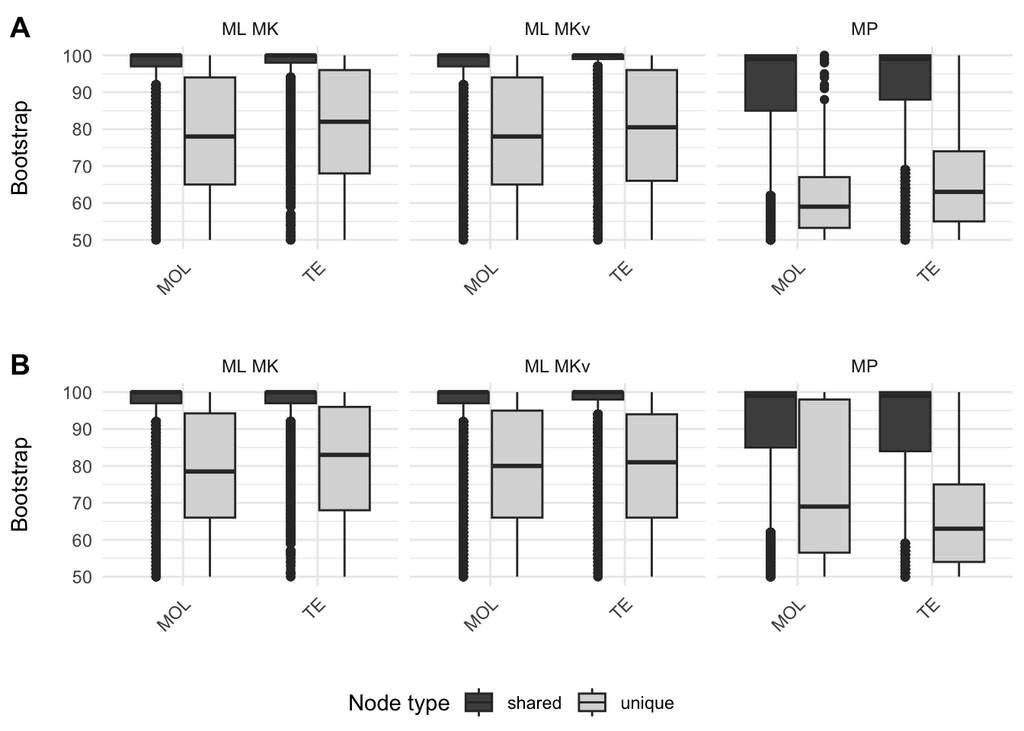

```r
# Combine dataframes with and without fossils (22 datasets will be "duplicated")
df_combined <- bind_rows(df_uniqueVSshared, df_uniqueVSshared_extinct)
df_combined <- df_combined %>%
  mutate(Optimality = recode(Optimality,
    "ML_ASC"   = "ML MKv",
    "ML MKv"   = "ML MKv",
    "ML MKV"   = "ML MKv",
    "ML_noASC" = "ML MK",
    "ML MK"    = "ML MK"
  ))
#View(df_combined)
# Exploratory data analysis
q4_explore = df_combined %>%
  group_by(Analysis, Optimality, Type) %>%
  summarise(
    min_Support = min(Support, na.rm = TRUE),
    max_Support = max(Support, na.rm = TRUE),
    mean_Support = mean(Support, na.rm = TRUE),
    sd_Support = sd(Support, na.rm = TRUE),
    .groups = "drop"
  )
#View(q4_explore)

# Combine dataframes with and without fossils (63-22 datasets will be "deduplicated")
df_extinct_63 <- rbind(
  df_uniqueVSshared_extinct,
  df_uniqueVSshared[!(df_uniqueVSshared$Dataset %in% df_uniqueVSshared_extinct$Dataset), ]
)
df_extinct_63 <- df_extinct_63 %>%
  mutate(Optimality = recode(Optimality,
    "ML_ASC"   = "ML MKv",
    "ML MKv"   = "ML MKv",
    "ML MKV"   = "ML MKv",
    "ML_noASC" = "ML MK",
    "ML MK"    = "ML MK"
  ))
#View(df_extinct_63)
# Exploratory data analysis
q4_explore = df_extinct_63 %>%
  group_by(Analysis, Optimality, Type) %>%
  summarise(
    min_Support = min(Support, na.rm = TRUE),
    max_Support = max(Support, na.rm = TRUE),
    mean_Support = mean(Support, na.rm = TRUE),
    sd_Support = sd(Support, na.rm = TRUE),
    .groups = "drop"
  )
#View(q4_explore)

# Create a combined factor for coloring
df_combined <- df_combined %>%
  mutate(
    ColorGroup = paste(Optimality, Type, Analysis, sep = "_")
  )

# common aesthetics / colors
fill_colors <- c("shared" = "#4d4d4d", "unique" = "#d9d9d9")

# Plot A: Without_fossils
pA <- df_combined %>%
  filter(Sampling == "Without_fossils") %>%
  ggplot(aes(x = Analysis, y = Support, fill = Type)) +
  geom_boxplot(position = position_dodge(width = 0.8)) +
  facet_wrap(~ Optimality) +
  scale_fill_manual(values = fill_colors) +
  labs(x = "", y = "Bootstrap\n", fill = "Node type") +
  theme_minimal() +
  theme(axis.text.x = element_text(angle = 45, hjust = 1))

# Plot B: With_fossils
pB <- df_extinct_63 %>%
  ggplot(aes(x = Analysis, y = Support, fill = Type)) +
  geom_boxplot(position = position_dodge(width = 0.8)) +
  facet_wrap(~ Optimality) +
  scale_fill_manual(values = fill_colors) +
  labs(x = "", y = "Bootstrap\n", fill = "Node type") +
  theme_minimal() +
  theme(axis.text.x = element_text(angle = 45, hjust = 1))

# Arrange side-by-side with labels A and B in upper-left
figure <- ggarrange(
  pA, pB,
  ncol = 1, nrow = 2,
  common.legend = TRUE, legend = "bottom",
  labels = c("A", "B"),
  label.x = 0.0,        # x position of labels (left)
  label.y = 0.98,        # y position of labels (top)
  font.label = list(size = 14)
)
figure
```

```r
ggsave("Figures/Fig7_BS_uniqueVSshared.jpg", plot = figure, width = 6, height = 6, units = "in", dpi = 300)
```

We can statistically test whether bootstrap values differ between shared and unique clades, considering Type (categorical predictor: unique vs shared), Sampling (categorical predictor: Without_fossils vs With_fossils), Optimality (categorical predictor: MP vs ML_ASC vs ML_noASC), Analysis (categorical predictor: MOL vs TE). We will use both traditional non-parametric tests and GLMs.

```r
# Fix: Squeeze Support into (0,1) for GLMM with Beta distribution
df_combined <- df_combined %>%
  mutate(Support_beta = (Support + 0.5) / 101)

# Fix: Squeeze Support into (0,1) for GLMM with Beta distribution
df_extinct_63 <- df_extinct_63 %>%
  mutate(Support_beta = (Support + 0.5) / 101)

# Split datasets
df_without <- df_combined %>% filter(Sampling == "Without_fossils")
df_with    <- df_combined %>% filter(Sampling == "With_fossils")

# --- Helper function for classical non-parametric tests ---
run_nonparametric_tests <- function(df) {
  results <- list()

  # 1. Kruskal-Wallis for Type, Optimality, Analysis
  results$kw_type <- kruskal_test(df, Support ~ Type)
  results$kw_opt  <- kruskal_test(df, Support ~ Optimality)
  results$kw_an   <- kruskal_test(df, Support ~ Analysis)

  # 2. Pairwise Wilcoxon for Type by Optimality & Analysis
  pw_list <- list()

  for(opt in unique(df$Optimality)){
    for(an in unique(df$Analysis)){
      subset_df <- df %>% filter(Optimality == opt, Analysis == an)
      test_res <- pairwise_wilcox_test(
        subset_df,
        Support ~ Type,
        p.adjust.method = "bonferroni"
      )
      test_res <- test_res %>% mutate(Optimality = opt, Analysis = an)
      pw_list[[paste(opt, an, sep = "_")]] <- test_res
    }
  }

  results$pairwise <- bind_rows(pw_list)
  return(results)
}

# Function to summarize mean, sd, min, max
summarize_support <- function(df) {
  df %>%
    group_by(Optimality, Analysis, Type) %>%
    summarise(
      n    = n(),
      mean = mean(Support, na.rm = TRUE),
      sd   = sd(Support, na.rm = TRUE),
      min  = min(Support, na.rm = TRUE),
      max  = max(Support, na.rm = TRUE),
      .groups = "drop"
    )
}

# All combinations to test
combinations <- expand.grid(
  Optimality = c("MP", "ML MK", "ML MKv"),
  Analysis = c("MOL", "TE"),
  stringsAsFactors = FALSE
)

# Function to run pairwise GLMM for one subset
run_pairwise <- function(df_subset) {
  results <- list()

  for (i in 1:nrow(combinations)) {
    opt <- combinations$Optimality[i]
    ana <- combinations$Analysis[i]

    df_sub <- df_subset %>%
      filter(Optimality == opt, Analysis == ana)

    if (nrow(df_sub) > 0) {
      # Fit beta GLMM
      glmm <- glmmTMB(
        Support_beta ~ Type + (1|Dataset),
        family = beta_family(link = "logit"),
        data = df_sub
      )

      # Pairwise comparisons for Type
      em <- emmeans(glmm, ~ Type)
      pw <- pairs(em, adjust = "bonferroni")

      results[[paste(opt, ana, sep = "_")]] <- summary(pw)
    }
  }

  bind_rows(results, .id = "Comparison")
}

run_pairwise_df <- function(df_subset, combinations_df, rand = "(1|Dataset)") {
  out_list <- list()
  for(i in seq_len(nrow(combinations_df))) {
    opt <- combinations_df$Optimality[i]
    ana <- combinations_df$Analysis[i]
    df_sub <- df_subset %>% filter(Optimality == opt, Analysis == ana)

    # need at least two Type levels and some rows
    if(nrow(df_sub) < 4 || length(unique(df_sub$Type)) < 2) {
      warning(sprintf("Skipping %s_%s: insufficient data (n=%d, types=%s)",
                      opt, ana, nrow(df_sub), paste(unique(df_sub$Type), collapse=", ")))
      next
    }

    # Fit model safely
    glmm <- try(
      glmmTMB(Support_beta ~ Type + (1|Dataset), data = df_sub, family = beta_family(link="logit")),
      silent = TRUE
    )
    if(inherits(glmm, "try-error")) {
      warning(sprintf("Model failed for %s_%s: %s", opt, ana, attr(glmm, "condition")$message))
      next
    }

    # emmeans and pairwise contrasts
    em <- try(emmeans(glmm, ~ Type), silent = TRUE)
    if(inherits(em, "try-error")) {
      warning(sprintf("emmeans failed for %s_%s", opt, ana))
      next
    }
    pw <- try(pairs(em, adjust = "bonferroni"), silent = TRUE)
    if(inherits(pw, "try-error")) {
      warning(sprintf("pairs() failed for %s_%s", opt, ana))
      next
    }

    # convert to data.frame to get exact numeric p-values
    pw_df <- as.data.frame(pw)
    # add context columns
    pw_df <- pw_df %>%
      mutate(
        Optimality = opt,
        Analysis   = ana,
        Comparison = rownames(pw_df)  # usually "unique - shared" or similar
      ) %>%
      select(Optimality, Analysis, Comparison, everything())

    out_list[[paste(opt, ana, sep = "_")]] <- pw_df
  }

  if(length(out_list) == 0) return(tibble())
  res <- bind_rows(out_list, .id = "id")

  # Add nicely formatted p-values:
  res <- res %>%
    mutate(
      p.value_numeric = as.numeric(p.value),
      p.value_fmt = ifelse(
        is.na(p.value_numeric), NA,
        ifelse(p.value_numeric < 0.001,
               formatC(p.value_numeric, format = "e", digits = 2),           # scientific for <0.001
               formatC(p.value_numeric, format = "f", digits = 3))           # 3 decimals otherwise
    ))

  return(res)
}
```

```r
# Table S7
print("Mean, sd, and range of BS without fossils")
```

```
## [1] "Mean, sd, and range of BS without fossils"
```

```r
summary_without <- summarize_support(df_without)
summary_without
```

```
## # A tibble: 12 × 8
##    Optimality Analysis Type       n  mean    sd   min   max
##    <chr>      <chr>    <chr>  <int> <dbl> <dbl> <int> <int>
##  1 ML MK      MOL      shared  2965  95.6  9.90    50   100
##  2 ML MK      MOL      unique   348  78.3 16.0     50   100
##  3 ML MK      TE       shared  2965  96.4  8.79    50   100
##  4 ML MK      TE       unique   361  79.9 16.5     50   100
##  5 ML MKv     MOL      shared  2988  95.4 10.1     50   100
##  6 ML MKv     MOL      unique   337  78.2 16.0     50   100
##  7 ML MKv     TE       shared  2988  96.4  8.88    50   100
##  8 ML MKv     TE       unique   356  79.2 16.2     50   100
##  9 MP         MOL      shared  2569  90.8 13.8     50   100
## 10 MP         MOL      unique   150  62.5 12.3     50   100
## 11 MP         TE       shared  2569  91.7 13.3     50   100
## 12 MP         TE       unique   203  66.2 13.4     50   100
```

```r
results_without <- run_nonparametric_tests(df_without)
print("Non-parametric Wilcoxon tests: Unique vs Shared BS (without fossils)")
```

```
## [1] "Non-parametric Wilcoxon tests: Unique vs Shared BS (without fossils)"
```

```r
results_without$pairwise
```

```
## # A tibble: 6 × 11
##   .y.     group1 group2    n1    n2 statistic         p     p.adj p.adj.signif
##   <chr>   <chr>  <chr>  <int> <int>     <dbl>     <dbl>     <dbl> <chr>
## 1 Support shared unique  2569   150   351268. 1.27e- 68 1.27e- 68 ****
## 2 Support shared unique  2569   203   467592. 3.12e- 85 3.12e- 85 ****
## 3 Support shared unique  2988   337   857687  2.45e-124 2.45e-124 ****
## 4 Support shared unique  2988   356   929262  2.38e-154 2.38e-154 ****
## 5 Support shared unique  2965   348   878279  1.06e-127 1.06e-127 ****
## 6 Support shared unique  2965   361   925828. 6.70e-149 6.70e-149 ****
## # ℹ 2 more variables: Optimality <chr>, Analysis <chr>
```

```r
print("GLMM with Beta distribution (without fossils")
```

```
## [1] "GLMM with Beta distribution (without fossils"
```

```r
# Run for Without_fossils
pairwise_without_df <- run_pairwise_df(df_without, combinations)
# View results: numeric and formatted p-values
pairwise_without_df %>%
  select(Optimality, Analysis, Comparison, estimate, SE, df, p.value_fmt)
```

```
##   Optimality Analysis Comparison estimate         SE  df p.value_fmt
## 1         MP      MOL          1 1.668437 0.07486084 Inf   4.92e-110
## 2      ML MK      MOL          1 1.436536 0.05209377 Inf   2.16e-167
## 3     ML MKv      MOL          1 1.430288 0.05296420 Inf   1.30e-160
## 4         MP       TE          1 1.652244 0.06474286 Inf   1.18e-143
## 5      ML MK       TE          1 1.395682 0.05032267 Inf   2.67e-169
## 6     ML MKv       TE          1 1.458360 0.05041327 Inf   5.29e-184
```

```r
# Table S7
print("Mean, sd, and range of BS with fossils")
```

```
## [1] "Mean, sd, and range of BS with fossils"
```

```r
summary_with <- summarize_support(df_extinct_63)
summary_with
```

```
## # A tibble: 12 × 8
##    Optimality Analysis Type       n  mean    sd   min   max
##    <chr>      <chr>    <chr>  <int> <dbl> <dbl> <int> <int>
##  1 ML MK      MOL      shared  2940  95.5  9.96    50   100
##  2 ML MK      MOL      unique   360  78.6 16.1     50   100
##  3 ML MK      TE       shared  2940  95.8  9.18    50   100
##  4 ML MK      TE       unique   384  80.2 16.1     50   100
##  5 ML MKv     MOL      shared  2956  95.5 10.0     50   100
##  6 ML MKv     MOL      unique   354  79.0 16.2     50   100
##  7 ML MKv     TE       shared  2956  95.9  9.14    50   100
##  8 ML MKv     TE       unique   394  79.2 16.0     50   100
##  9 MP         MOL      shared  2448  90.9 13.8     50   100
## 10 MP         MOL      unique   271  74.4 19.0     50   100
## 11 MP         TE       shared  2448  90.4 14.2     50   100
## 12 MP         TE       unique   164  66.0 14.0     50   100
```

```r
print("Non-parametric Wilcoxon tests: Unique vs Shared BS (with fossils)")
```

```
## [1] "Non-parametric Wilcoxon tests: Unique vs Shared BS (with fossils)"
```

```r
results_with  <- run_nonparametric_tests(df_extinct_63)
results_with$pairwise
```

```
## # A tibble: 6 × 11
##   .y.     group1 group2    n1    n2 statistic         p     p.adj p.adj.signif
##   <chr>   <chr>  <chr>  <int> <int>     <dbl>     <dbl>     <dbl> <chr>
## 1 Support shared unique  2448   271   492293  1.35e- 41 1.35e- 41 ****
## 2 Support shared unique  2448   164   352342  1.64e- 62 1.64e- 62 ****
## 3 Support shared unique  2956   354   872522. 3.56e-117 3.56e-117 ****
## 4 Support shared unique  2956   394   994402. 1.80e-143 1.80e-143 ****
## 5 Support shared unique  2940   360   891358  7.28e-125 7.28e-125 ****
## 6 Support shared unique  2940   384   954568  1.08e-132 1.08e-132 ****
## # ℹ 2 more variables: Optimality <chr>, Analysis <chr>
```

```r
print("GLMM with Beta distribution (with fossils")
```

```
## [1] "GLMM with Beta distribution (with fossils"
```

```r
# Run for With_fossils
pairwise_with_df <- run_pairwise_df(df_extinct_63, combinations)
# View results: numeric and formatted p-values
pairwise_with_df %>%
  select(Optimality, Analysis, Comparison, estimate, SE, df, p.value_fmt)
```

```
##   Optimality Analysis Comparison estimate         SE  df p.value_fmt
## 1         MP      MOL          1 1.123236 0.06950290 Inf    9.50e-59
## 2      ML MK      MOL          1 1.384154 0.05149198 Inf   3.67e-159
## 3     ML MKv      MOL          1 1.345844 0.05228957 Inf   4.36e-146
## 4         MP       TE          1 1.489400 0.07292427 Inf    1.02e-92
## 5      ML MK       TE          1 1.225980 0.05007867 Inf   2.35e-132
## 6     ML MKv       TE          1 1.315407 0.04944141 Inf   5.88e-156
```

As expected, bootstrap values of unique clades are significantly lower than those from shared clades.

## Q4.2 MOL vs TE (Table 5)

### Q4.2.1 Extant

First, we need to load the data. Support values of shared clades were identified and organized using the package RNODE.

```r
# Load data (BS shared clades)
df_q4 = read.csv("Dataset_R_q4_07-26_shared.csv")

# Set order of optimality criteria
df_q4$Optimality <- factor(df_q4$Optimality, levels = c("MP", "ML-ASC", "ML-noASC"))
df_q4$SupportDiff = df_q4$Support_Tree_1 - df_q4$Support_Tree_2
```

For each optimality criterion, we tested whether the paired values of bootstrap of shared clades differ between MOL and TE trees. First, we computed the number of clades in which bootstrap values were the same in MOL and TE trees, higher in MOL than TE trees, or higher in TE than MOL trees. Next, we tested the normality of bootstrap values using Shapiro-Wilk tests. Finally, we used both the non-parametric Wilcoxon signed-rank and Generalized Linear Mixed Models.

#### Q4.2.1.1 MP MOL vs MP TE

```r
# Filter dataset keeping only MP
df_MP <- df_q4[grepl("MP", df_q4$Optimality), ]

# Exploratory data analysis
print("Mean BS in MP MOL")
```

```
## [1] "Mean BS in MP MOL"
```

```r
mean(df_MP$Support_Tree_1) # MOL
```

```
## [1] 90.77812
```

```r
print("Standard deviation BS in MP MOL")
```

```
## [1] "Standard deviation BS in MP MOL"
```

```r
sd(df_MP$Support_Tree_1) # MOL
```

```
## [1] 13.84043
```

```r
print("Min BS in MP MOL")
```

```
## [1] "Min BS in MP MOL"
```

```r
min(df_MP$Support_Tree_1) # MOL
```

```
## [1] 50
```

```r
print("Max BS in MP MOL")
```

```
## [1] "Max BS in MP MOL"
```

```r
max(df_MP$Support_Tree_1) # MOL
```

```
## [1] 100
```

```r
print("Mean BS in MP TE")
```

```
## [1] "Mean BS in MP TE"
```

```r
mean(df_MP$Support_Tree_2) # TE
```

```
## [1] 91.69482
```

```r
print("Standard deviation BS in MP TE")
```

```
## [1] "Standard deviation BS in MP TE"
```

```r
sd(df_MP$Support_Tree_2) # TE
```

```
## [1] 13.25285
```

```r
print("Min BS in MP TE")
```

```
## [1] "Min BS in MP TE"
```

```r
min(df_MP$Support_Tree_2) # TE
```

```
## [1] 50
```

```r
print("Max BS in MP TE")
```

```
## [1] "Max BS in MP TE"
```

```r
max(df_MP$Support_Tree_2) # TE
```

```
## [1] 100
```

```r
print("Total no. shared clades between MOL and TE")
```

```
## [1] "Total no. shared clades between MOL and TE"
```

```r
nrow(df_MP)
```

```
## [1] 2569
```

```r
print("No. shared clades with BS MOL == BS TE")
```

```
## [1] "No. shared clades with BS MOL == BS TE"
```

```r
sum(df_MP$Support_Tree_1 == df_MP$Support_Tree_2)
```

```
## [1] 1341
```

```r
print("No. shared clades with BS MOL > BS TE")
```

```
## [1] "No. shared clades with BS MOL > BS TE"
```

```r
sum(df_MP$Support_Tree_1 > df_MP$Support_Tree_2)
```

```
## [1] 465
```

```r
print("No. shared clades with BS MOL < BS TE")
```

```
## [1] "No. shared clades with BS MOL < BS TE"
```

```r
sum(df_MP$Support_Tree_1 < df_MP$Support_Tree_2)
```

```
## [1] 763
```

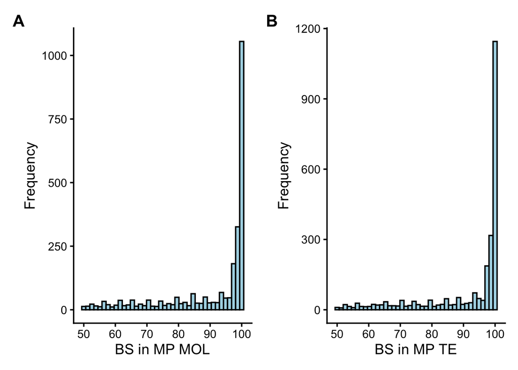

```r
# Histogram MP MOL
p1 <- ggplot(df_MP, aes(x = Support_Tree_1)) +
  geom_histogram(
    bins = 40,
    fill = "lightblue",
    color = "black"
  ) +
  labs(x = "BS in MP MOL", y = "Frequency") +
  theme_classic(base_size = 14) +
  theme(
    plot.tag = element_text(face = "bold", size = 16)
  ) +
  labs(tag = "A")

# Histogram MP TE
p2 <- ggplot(df_MP, aes(x = Support_Tree_2)) +
  geom_histogram(
    bins = 40,
    fill = "lightblue",
    color = "black"
  ) +
  labs(x = "BS in MP TE", y = "Frequency") +
  theme_classic(base_size = 14) +
  theme(
    plot.tag = element_text(face = "bold", size = 16)
  ) +
  labs(tag = "B")

# Combine into a single ggplot object
s11_mp <- p1 + p2
s11_mp
```

```r
# Shapiro-Wilk test for normality
shapiro.test(df_MP$Support_Tree_1) # P < 0.05, non-parametric
```

```
##
##  Shapiro-Wilk normality test
##
## data:  df_MP$Support_Tree_1
## W = 0.70757, p-value < 2.2e-16
```

```r
shapiro.test(df_MP$Support_Tree_2) # P < 0.05, non-parametric
```

```
##
##  Shapiro-Wilk normality test
##
## data:  df_MP$Support_Tree_2
## W = 0.67915, p-value < 2.2e-16
```

```r
# Perform the Wilcoxon signed-rank test for paired values
wilcox.test(as.numeric(df_MP$Support_Tree_1),
                           as.numeric(df_MP$Support_Tree_2),
                           paired = TRUE)
```

```
##
##  Wilcoxon signed rank test with continuity correction
##
## data:  as.numeric(df_MP$Support_Tree_1) and as.numeric(df_MP$Support_Tree_2)
## V = 272134, p-value < 2.2e-16
## alternative hypothesis: true location shift is not equal to 0
```

```r
# Dataset for GLMMs
df_MP_glmm <- data.frame(
  Node = c(df_MP$Node_Tree_1, df_MP$Node_Tree_2),
  Approach = c(df_MP$Approach1, df_MP$Approach2),
  Support = c(df_MP$Support_Tree_1, df_MP$Support_Tree_2),
  ID = c(df_MP$ID, df_MP$ID)
)

# GLMM Beta
# Step 1. Scale Support from 0–100 to 0–1
df_MP_glmm <- df_MP_glmm %>%
  mutate(Support_prop = Support / 100)
# Beta regression does not allow exact 0 or 1
n <- nrow(df_MP_glmm)
df_MP_glmm <- df_MP_glmm %>%
  mutate(Support_beta = (Support_prop * (n - 1) + 0.5) / n)
mp_beta <- glmmTMB(Support_beta ~ Approach + (1 | ID),
                 family = beta_family(link = "logit"),
                 data = df_MP_glmm)
summary(mp_beta)
```

```
##  Family: beta  ( logit )
## Formula:          Support_beta ~ Approach + (1 | ID)
## Data: df_MP_glmm
##
##       AIC       BIC    logLik -2*log(L)  df.resid
##  -31244.1  -31217.9   15626.0  -31252.1      5134
##
## Random effects:
##
## Conditional model:
##  Groups Name        Variance Std.Dev.
##  ID     (Intercept) 3.365    1.834
## Number of obs: 5138, groups:  ID, 2569
##
## Dispersion parameter for beta family (): 38.7
##
## Conditional model:
##             Estimate Std. Error z value Pr(>|z|)
## (Intercept)  3.53558    0.04203   84.12  < 2e-16 ***
## ApproachTE   0.12796    0.01631    7.84 4.33e-15 ***
## ---
## Signif. codes:  0 '***' 0.001 '**' 0.01 '*' 0.05 '.' 0.1 ' ' 1
```

#### Q4.2.1.2 ML MOL vs ML TE ASC

```r
# Filter dataset keeping only ML ASC
df_MLASC <- df_q4[grepl("ML-ASC", df_q4$Optimality), ]

# Exploratory data analysis
print("Mean BS in ML MOL")
```

```
## [1] "Mean BS in ML MOL"
```

```r
mean(df_MLASC$Support_Tree_1) # MOL
```

```
## [1] 95.41399
```

```r
print("Standard deviation BS in MP MOL")
```

```
## [1] "Standard deviation BS in MP MOL"
```

```r
sd(df_MLASC$Support_Tree_1) # MOL
```

```
## [1] 10.09415
```

```r
print("Min BS in ML MOL")
```

```
## [1] "Min BS in ML MOL"
```

```r
min(df_MLASC$Support_Tree_1) # MOL
```

```
## [1] 50
```

```r
print("Max BS in ML MOL")
```

```
## [1] "Max BS in ML MOL"
```

```r
max(df_MLASC$Support_Tree_1) # MOL
```

```
## [1] 100
```

```r
print("Mean BS in ML TE ASC")
```

```
## [1] "Mean BS in ML TE ASC"
```

```r
mean(df_MLASC$Support_Tree_2) # TE
```

```
## [1] 96.36714
```

```r
print("Standard deviation BS in ML TE ASC")
```

```
## [1] "Standard deviation BS in ML TE ASC"
```

```r
sd(df_MLASC$Support_Tree_2) # TE
```

```
## [1] 8.876949
```

```r
print("Min BS in ML TE ASC")
```

```
## [1] "Min BS in ML TE ASC"
```

```r
min(df_MLASC$Support_Tree_2) # TE
```

```
## [1] 50
```

```r
print("Max BS in ML TE ASC")
```

```
## [1] "Max BS in ML TE ASC"
```

```r
max(df_MLASC$Support_Tree_2) # TE
```

```
## [1] 100
```

```r
print("Total no. shared clades between MOL and TE")
```

```
## [1] "Total no. shared clades between MOL and TE"
```

```r
nrow(df_MLASC)
```

```
## [1] 2988
```

```r
print("No. shared clades with BS MOL == BS TE")
```

```
## [1] "No. shared clades with BS MOL == BS TE"
```

```r
sum(df_MLASC$Support_Tree_1 == df_MLASC$Support_Tree_2)
```

```
## [1] 1930
```

```r
print("No. shared clades with BS MOL > BS TE")
```

```
## [1] "No. shared clades with BS MOL > BS TE"
```

```r
sum(df_MLASC$Support_Tree_1 > df_MLASC$Support_Tree_2)
```

```
## [1] 415
```

```r
print("No. shared clades with BS MOL < BS TE")
```

```
## [1] "No. shared clades with BS MOL < BS TE"
```

```r
sum(df_MLASC$Support_Tree_1 < df_MLASC$Support_Tree_2)
```

```
## [1] 643
```

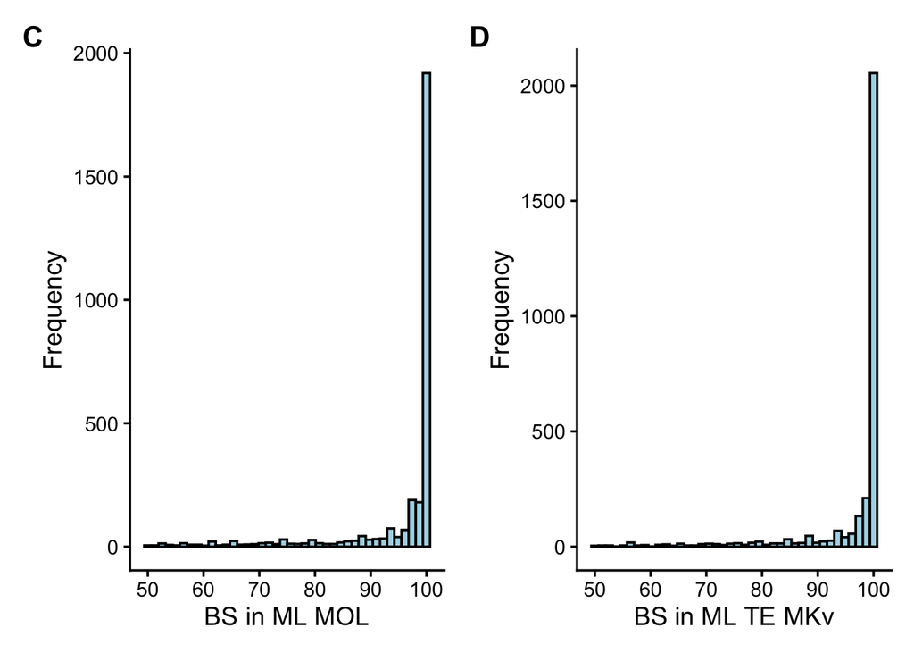

```r
# Histogram ML MOL
p1 <- ggplot(df_MLASC, aes(x = Support_Tree_1)) +
  geom_histogram(
    bins = 40,
    fill = "lightblue",
    color = "black"
  ) +
  labs(x = "BS in ML MOL", y = "Frequency") +
  theme_classic(base_size = 14) +
  theme(
    plot.tag = element_text(face = "bold", size = 16)
  ) +
  labs(tag = "C")

# Histogram ML TE MKv
p2 <- ggplot(df_MLASC, aes(x = Support_Tree_2)) +
  geom_histogram(
    bins = 40,
    fill = "lightblue",
    color = "black"
  ) +
  labs(x = "BS in ML TE MKv", y = "Frequency") +
  theme_classic(base_size = 14) +
  theme(
    plot.tag = element_text(face = "bold", size = 16)
  ) +
  labs(tag = "D")

# Combine into a single ggplot object
s11_ml_mkv <- p1 + p2
s11_ml_mkv
```

```r
# Shapiro-Wilk test for normality
shapiro.test(df_MLASC$Support_Tree_1) # P < 0.05, non-parametric
```

```
##
##  Shapiro-Wilk normality test
##
## data:  df_MLASC$Support_Tree_1
## W = 0.52525, p-value < 2.2e-16
```

```r
shapiro.test(df_MLASC$Support_Tree_2) # P < 0.05, non-parametric
```

```
##
##  Shapiro-Wilk normality test
##
## data:  df_MLASC$Support_Tree_2
## W = 0.47623, p-value < 2.2e-16
```

```r
# Perform the Wilcoxon signed-rank test for paired values
wilcox.test(as.numeric(df_MLASC$Support_Tree_1),
                       as.numeric(df_MLASC$Support_Tree_2),
                       paired = TRUE)
```

```
##
##  Wilcoxon signed rank test with continuity correction
##
## data:  as.numeric(df_MLASC$Support_Tree_1) and as.numeric(df_MLASC$Support_Tree_2)
## V = 212702, p-value = 1.095e-11
## alternative hypothesis: true location shift is not equal to 0
```

```r
# Dataset for GLMMs
df_MLASC_glmm <- data.frame(
  Node = c(df_MLASC$Node_Tree_1, df_MLASC$Node_Tree_2),
  Approach = c(df_MLASC$Approach1, df_MLASC$Approach2),
  Support = c(df_MLASC$Support_Tree_1, df_MLASC$Support_Tree_2),
  ID = c(df_MLASC$ID, df_MLASC$ID)
)

# GLMM Beta
# Step 1. Scale Support from 0–100 to 0–1
df_MLASC_glmm <- df_MLASC_glmm %>%
  mutate(Support_prop = Support / 100)
# Beta regression does not allow exact 0 or 1
n <- nrow(df_MLASC_glmm)
df_MLASC_glmm <- df_MLASC_glmm %>%
  mutate(Support_beta = (Support_prop * (n - 1) + 0.5) / n)
ml_asc_beta <- glmmTMB(Support_beta ~ Approach + (1 | ID),
                 family = beta_family(link = "logit"),
                 data = df_MLASC_glmm)
summary(ml_asc_beta)
```

```
##  Family: beta  ( logit )
## Formula:          Support_beta ~ Approach + (1 | ID)
## Data: df_MLASC_glmm
##
##       AIC       BIC    logLik -2*log(L)  df.resid
##  -51773.9  -51747.1   25891.0  -51781.9      5972
##
## Random effects:
##
## Conditional model:
##  Groups Name        Variance  Std.Dev.
##  ID     (Intercept) 2.598e-09 5.097e-05
## Number of obs: 5976, groups:  ID, 2988
##
## Dispersion parameter for beta family (): 4.33
##
## Conditional model:
##             Estimate Std. Error z value Pr(>|z|)
## (Intercept)  3.09802    0.03050  101.58   <2e-16 ***
## ApproachTE   0.06354    0.02633    2.41   0.0158 *
## ---
## Signif. codes:  0 '***' 0.001 '**' 0.01 '*' 0.05 '.' 0.1 ' ' 1
```

#### Q4.2.1.3 ML MOL vs ML TE noASC

```r
# Filter dataset keeping only ML noASC
df_MLnoASC <- df_q4[grepl("ML-noASC", df_q4$Optimality), ]

# Exploratory data analysis
print("Mean BS in ML MOL")
```

```
## [1] "Mean BS in ML MOL"
```

```r
mean(df_MLnoASC$Support_Tree_1) # MOL
```

```
## [1] 95.55278
```

```r
print("Standard deviation BS in MP MOL")
```

```
## [1] "Standard deviation BS in MP MOL"
```

```r
sd(df_MLnoASC$Support_Tree_1) # MOL
```

```
## [1] 9.902306
```

```r
print("Min BS in ML MOL")
```

```
## [1] "Min BS in ML MOL"
```

```r
min(df_MLnoASC$Support_Tree_1) # MOL
```

```
## [1] 50
```

```r
print("Max BS in ML MOL")
```

```
## [1] "Max BS in ML MOL"
```

```r
max(df_MLnoASC$Support_Tree_1) # MOL
```

```
## [1] 100
```

```r
print("Mean BS in ML TE noASC")
```

```
## [1] "Mean BS in ML TE noASC"
```

```r
mean(df_MLnoASC$Support_Tree_2) # TE
```

```
## [1] 96.38449
```

```r
print("Standard deviation BS in ML TE noASC")
```

```
## [1] "Standard deviation BS in ML TE noASC"
```

```r
sd(df_MLnoASC$Support_Tree_2) # TE
```

```
## [1] 8.791591
```

```r
print("Min BS in ML TE noASC")
```

```
## [1] "Min BS in ML TE noASC"
```

```r
min(df_MLnoASC$Support_Tree_2) # TE
```

```
## [1] 50
```

```r
print("Max BS in ML TE noASC")
```

```
## [1] "Max BS in ML TE noASC"
```

```r
max(df_MLnoASC$Support_Tree_2) # TE
```

```
## [1] 100
```

```r
print("Total no. shared clades between MOL and TE")
```

```
## [1] "Total no. shared clades between MOL and TE"
```

```r
nrow(df_MLnoASC)
```

```
## [1] 2965
```

```r
print("No. shared clades with BS MOL == BS TE")
```

```
## [1] "No. shared clades with BS MOL == BS TE"
```

```r
sum(df_MLnoASC$Support_Tree_1 == df_MLnoASC$Support_Tree_2)
```

```
## [1] 1916
```

```r
print("No. shared clades with BS MOL > BS TE")
```

```
## [1] "No. shared clades with BS MOL > BS TE"
```

```r
sum(df_MLnoASC$Support_Tree_1 > df_MLnoASC$Support_Tree_2)
```

```
## [1] 418
```

```r
print("No. shared clades with BS MOL < BS TE")
```

```
## [1] "No. shared clades with BS MOL < BS TE"
```

```r
sum(df_MLnoASC$Support_Tree_1 < df_MLnoASC$Support_Tree_2)
```

```
## [1] 631
```

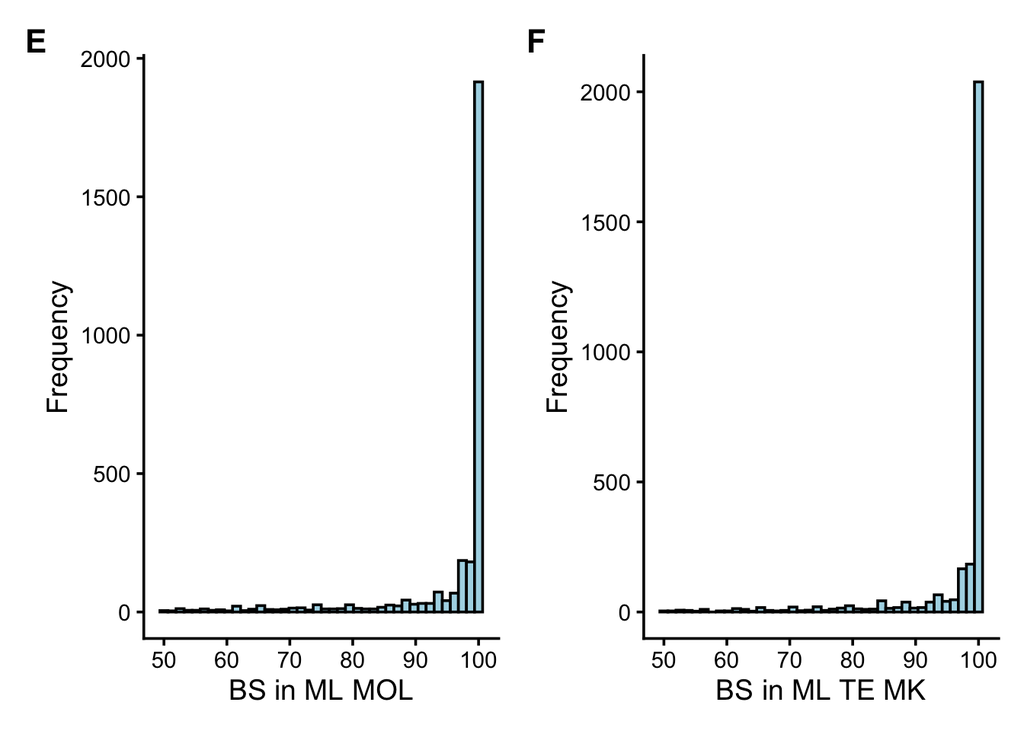

```r
# Histogram ML MOL
p1 <- ggplot(df_MLnoASC, aes(x = Support_Tree_1)) +
  geom_histogram(
    bins = 40,
    fill = "lightblue",
    color = "black"
  ) +
  labs(x = "BS in ML MOL", y = "Frequency") +
  theme_classic(base_size = 14) +
  theme(
    plot.tag = element_text(face = "bold", size = 16)
  ) +
  labs(tag = "E")

# Histogram ML TE MK
p2 <- ggplot(df_MLnoASC, aes(x = Support_Tree_2)) +
  geom_histogram(
    bins = 40,
    fill = "lightblue",
    color = "black"
  ) +
  labs(x = "BS in ML TE MK", y = "Frequency") +
  theme_classic(base_size = 14) +
  theme(
    plot.tag = element_text(face = "bold", size = 16)
  ) +
  labs(tag = "F")

# Combine into a single ggplot object
s11_ml_mk <- p1 + p2
s11_ml_mk
```

```r
# Shapiro-Wilk test for normality
shapiro.test(df_MLnoASC$Support_Tree_1) # P < 0.05, non-parametric
```

```
##
##  Shapiro-Wilk normality test
##
## data:  df_MLnoASC$Support_Tree_1
## W = 0.51962, p-value < 2.2e-16
```

```r
shapiro.test(df_MLnoASC$Support_Tree_2) # P < 0.05, non-parametric
```

```
##
##  Shapiro-Wilk normality test
##
## data:  df_MLnoASC$Support_Tree_2
## W = 0.47883, p-value < 2.2e-16
```

```r
# Perform the Wilcoxon signed-rank test for paired values
wilcox.test(as.numeric(df_MLnoASC$Support_Tree_1),
                       as.numeric(df_MLnoASC$Support_Tree_2),
                       paired = TRUE)
```

```
##
##  Wilcoxon signed rank test with continuity correction
##
## data:  as.numeric(df_MLnoASC$Support_Tree_1) and as.numeric(df_MLnoASC$Support_Tree_2)
## V = 214886, p-value = 6.545e-10
## alternative hypothesis: true location shift is not equal to 0
```

```r
# Dataset for GLMMs
df_MLnoASC_glmm <- data.frame(
  Node = c(df_MLnoASC$Node_Tree_1, df_MLnoASC$Node_Tree_2),
  Approach = c(df_MLnoASC$Approach1, df_MLnoASC$Approach2),
  Support = c(df_MLnoASC$Support_Tree_1, df_MLnoASC$Support_Tree_2),
  ID = c(df_MLnoASC$ID, df_MLnoASC$ID)
)

# GLMM Beta
# Step 1. Scale Support from 0–100 to 0–1
df_MLnoASC_glmm <- df_MLnoASC_glmm %>%
  mutate(Support_prop = Support / 100)
# Beta regression does not allow exact 0 or 1
n <- nrow(df_MLnoASC_glmm)
df_MLnoASC_glmm <- df_MLnoASC_glmm %>%
  mutate(Support_beta = (Support_prop * (n - 1) + 0.5) / n)
ml_noasc_beta <- glmmTMB(Support_beta ~ Approach + (1 | ID),
                 family = beta_family(link = "logit"),
                 data = df_MLnoASC_glmm)
summary(ml_noasc_beta)
```

```
##  Family: beta  ( logit )
## Formula:          Support_beta ~ Approach + (1 | ID)
## Data: df_MLnoASC_glmm
##
##       AIC       BIC    logLik -2*log(L)  df.resid
##  -51490.2  -51463.5   25749.1  -51498.2      5926
##
## Random effects:
##
## Conditional model:
##  Groups Name        Variance  Std.Dev.
##  ID     (Intercept) 2.861e-09 5.349e-05
## Number of obs: 5930, groups:  ID, 2965
##
## Dispersion parameter for beta family (): 4.42
##
## Conditional model:
##             Estimate Std. Error z value Pr(>|z|)
## (Intercept)  3.12059    0.03064  101.84   <2e-16 ***
## ApproachTE   0.05659    0.02641    2.14   0.0322 *
## ---
## Signif. codes:  0 '***' 0.001 '**' 0.01 '*' 0.05 '.' 0.1 ' ' 1
```

### Q4.2.2 Extant + extinct

First, we need to load the data including fossils. Support values of shared clades were identified and organized using the package RNODE.

```r
# Load data (BS shared clades)
df_q4 = read.csv("Dataset_R_q4_09-25_shared_extinct.csv")

# Set order of optimality criteria
df_q4$Optimality <- factor(df_q4$Optimality, levels = c("MP", "ML-ASC", "ML-noASC"))
df_q4$SupportDiff = df_q4$Support_Tree_1 - df_q4$Support_Tree_2

# The names of the datasets are 1 .. 2. We need to corrected them to the original names
map <- c(
  "1"=3, "2"=7, "3"=8, "4"=9, "5"=10, "6"=11, "7"=13, "8"=17, "9"=21,
  "10"=24, "11"=28, "12"=29, "13"=31, "14"=38, "15"=39, "16"=40,
  "17"=42, "18"=46, "19"=48, "20"=52, "21"=54, "22"=58
)
df_q4$Dataset <- map[as.character(df_q4$Dataset)]

# Correct the values in df_q4$ID
df_q4$ID <- paste0(
  map[sub("_.*","", df_q4$ID)],
  sub("^[^_]+","", df_q4$ID)
)

# Include the datasets of extant organisms, without duplications
df_q4_extant = read.csv("Dataset_R_q4_07-26_shared.csv")
df_q4_extant$Optimality <- factor(df_q4_extant$Optimality, levels = c("MP", "ML-ASC", "ML-noASC"))
df_q4_extant$SupportDiff = df_q4_extant$Support_Tree_1 - df_q4_extant$Support_Tree_2
df_q4 <- bind_rows(
  df_q4,
  anti_join(df_q4_extant, df_q4, by = "ID")
)
```

#### Q4.2.2.1 MP MOL vs MP TE

```r
# Filter dataset keeping only MP
df_MP <- df_q4[grepl("MP", df_q4$Optimality), ]

# Exploratory data analysis
print("Mean BS in MP MOL")
```

```
## [1] "Mean BS in MP MOL"
```

```r
mean(df_MP$Support_Tree_1) # MOL
```

```
## [1] 90.82211
```

```r
print("Standard deviation BS in MP MOL")
```

```
## [1] "Standard deviation BS in MP MOL"
```

```r
sd(df_MP$Support_Tree_1) # MOL
```

```
## [1] 13.82954
```

```r
print("Min BS in MP MOL")
```

```
## [1] "Min BS in MP MOL"
```

```r
min(df_MP$Support_Tree_1) # MOL
```

```
## [1] 50
```

```r
print("Max BS in MP MOL")
```

```
## [1] "Max BS in MP MOL"
```

```r
max(df_MP$Support_Tree_1) # MOL
```

```
## [1] 100
```

```r
print("Mean BS in MP TE")
```

```
## [1] "Mean BS in MP TE"
```

```r
mean(df_MP$Support_Tree_2) # TE
```

```
## [1] 90.50681
```

```r
print("Standard deviation BS in MP TE")
```

```
## [1] "Standard deviation BS in MP TE"
```

```r
sd(df_MP$Support_Tree_2) # TE
```

```
## [1] 14.07197
```

```r
print("Min BS in MP TE")
```

```
## [1] "Min BS in MP TE"
```

```r
min(df_MP$Support_Tree_2) # TE
```

```
## [1] 50
```

```r
print("Max BS in MP TE")
```

```
## [1] "Max BS in MP TE"
```

```r
max(df_MP$Support_Tree_2) # TE
```

```
## [1] 100
```

```r
print("Total no. shared clades between MOL and TE")
```

```
## [1] "Total no. shared clades between MOL and TE"
```

```r
nrow(df_MP)
```

```
## [1] 2569
```

```r
print("No. shared clades with BS MOL == BS TE")
```

```
## [1] "No. shared clades with BS MOL == BS TE"
```

```r
sum(df_MP$Support_Tree_1 == df_MP$Support_Tree_2)
```

```
## [1] 1248
```

```r
print("No. shared clades with BS MOL > BS TE")
```

```
## [1] "No. shared clades with BS MOL > BS TE"
```

```r
sum(df_MP$Support_Tree_1 > df_MP$Support_Tree_2)
```

```
## [1] 616
```

```r
print("No. shared clades with BS MOL < BS TE")
```

```
## [1] "No. shared clades with BS MOL < BS TE"
```

```r
sum(df_MP$Support_Tree_1 < df_MP$Support_Tree_2)
```

```
## [1] 705
```

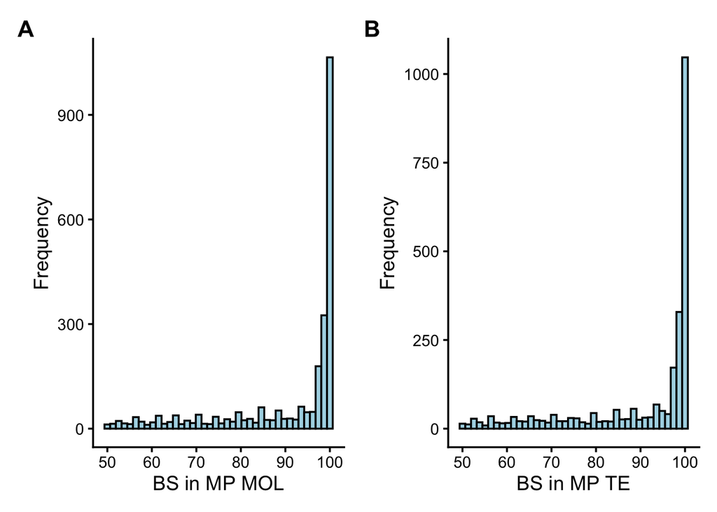

```r
# Histogram MP MOL
p1 <- ggplot(df_MP, aes(x = Support_Tree_1)) +
  geom_histogram(
    bins = 40,
    fill = "lightblue",
    color = "black"
  ) +
  labs(x = "BS in MP MOL", y = "Frequency") +
  theme_classic(base_size = 14) +
  theme(
    plot.tag = element_text(face = "bold", size = 16)
  ) +
  labs(tag = "A")

# Histogram MP TE
p2 <- ggplot(df_MP, aes(x = Support_Tree_2)) +
  geom_histogram(
    bins = 40,
    fill = "lightblue",
    color = "black"
  ) +
  labs(x = "BS in MP TE", y = "Frequency") +
  theme_classic(base_size = 14) +
  theme(
    plot.tag = element_text(face = "bold", size = 16)
  ) +
  labs(tag = "B")

# Combine into a single ggplot object
s11_mp_f <- p1 + p2
s11_mp_f
```

```r
# Shapiro-Wilk test for normality
shapiro.test(df_MP$Support_Tree_1) # P < 0.05, non-parametric
```

```
##
##  Shapiro-Wilk normality test
##
## data:  df_MP$Support_Tree_1
## W = 0.70565, p-value < 2.2e-16
```

```r
shapiro.test(df_MP$Support_Tree_2) # P < 0.05, non-parametric
```

```
##
##  Shapiro-Wilk normality test
##
## data:  df_MP$Support_Tree_2
## W = 0.71251, p-value < 2.2e-16
```

```r
# Perform the Wilcoxon signed-rank test for paired values
wilcox.test(as.numeric(df_MP$Support_Tree_1),
                           as.numeric(df_MP$Support_Tree_2),
                           paired = TRUE)
```

```
##
##  Wilcoxon signed rank test with continuity correction
##
## data:  as.numeric(df_MP$Support_Tree_1) and as.numeric(df_MP$Support_Tree_2)
## V = 423888, p-value = 0.3571
## alternative hypothesis: true location shift is not equal to 0
```

```r
# Dataset for GLMMs
df_MP_glmm_f <- data.frame(
  Node = c(df_MP$Node_Tree_1, df_MP$Node_Tree_2),
  Approach = c(df_MP$Approach1, df_MP$Approach2),
  Support = c(df_MP$Support_Tree_1, df_MP$Support_Tree_2),
  ID = c(df_MP$ID, df_MP$ID)
)

# GLMM Beta
# Step 1. Scale Support from 0–100 to 0–1
df_MP_glmm_f <- df_MP_glmm_f %>%
  mutate(Support_prop = Support / 100)
# Beta regression does not allow exact 0 or 1
n <- nrow(df_MP_glmm_f)
df_MP_glmm_f <- df_MP_glmm_f %>%
  mutate(Support_beta = (Support_prop * (n - 1) + 0.5) / n)
mp_beta <- glmmTMB(Support_beta ~ Approach + (1 | ID),
                 family = beta_family(link = "logit"),
                 data = df_MP_glmm_f)
summary(mp_beta)
```

```
##  Family: beta  ( logit )
## Formula:          Support_beta ~ Approach + (1 | ID)
## Data: df_MP_glmm_f
##
##       AIC       BIC    logLik -2*log(L)  df.resid
##  -29192.0  -29165.8   14600.0  -29200.0      5134
##
## Random effects:
##
## Conditional model:
##  Groups Name        Variance Std.Dev.
##  ID     (Intercept) 2.386    1.545
## Number of obs: 5138, groups:  ID, 2569
##
## Dispersion parameter for beta family (): 18.2
##
## Conditional model:
##             Estimate Std. Error z value Pr(>|z|)
## (Intercept)  3.20384    0.03911   81.92   <2e-16 ***
## ApproachTE  -0.01263    0.02106   -0.60    0.549
## ---
## Signif. codes:  0 '***' 0.001 '**' 0.01 '*' 0.05 '.' 0.1 ' ' 1
```

#### Q4.2.2.2 ML MOL vs ML TE ASC

```r
# Filter dataset keeping only ML ASC
df_MLASC <- df_q4[grepl("ML-ASC", df_q4$Optimality), ]

# Exploratory data analysis
print("Mean BS in ML MOL")
```

```
## [1] "Mean BS in ML MOL"
```

```r
mean(df_MLASC$Support_Tree_1) # MOL
```

```
## [1] 95.44045
```

```r
print("Standard deviation BS in MP MOL")
```

```
## [1] "Standard deviation BS in MP MOL"
```

```r
sd(df_MLASC$Support_Tree_1) # MOL
```

```
## [1] 10.04381
```

```r
print("Min BS in ML MOL")
```

```
## [1] "Min BS in ML MOL"
```

```r
min(df_MLASC$Support_Tree_1) # MOL
```

```
## [1] 50
```

```r
print("Max BS in ML MOL")
```

```
## [1] "Max BS in ML MOL"
```

```r
max(df_MLASC$Support_Tree_1) # MOL
```

```
## [1] 100
```

```r
print("Mean BS in ML TE ASC")
```

```
## [1] "Mean BS in ML TE ASC"
```

```r
mean(df_MLASC$Support_Tree_2) # TE
```

```
## [1] 95.93513
```

```r
print("Standard deviation BS in ML TE ASC")
```

```
## [1] "Standard deviation BS in ML TE ASC"
```

```r
sd(df_MLASC$Support_Tree_2) # TE
```

```
## [1] 9.16149
```

```r
print("Min BS in ML TE ASC")
```

```
## [1] "Min BS in ML TE ASC"
```

```r
min(df_MLASC$Support_Tree_2) # TE
```

```
## [1] 50
```

```r
print("Max BS in ML TE ASC")
```

```
## [1] "Max BS in ML TE ASC"
```

```r
max(df_MLASC$Support_Tree_2) # TE
```

```
## [1] 100
```

```r
print("Total no. shared clades between MOL and TE")
```

```
## [1] "Total no. shared clades between MOL and TE"
```

```r
nrow(df_MLASC)
```

```
## [1] 3006
```

```r
print("No. shared clades with BS MOL == BS TE")
```

```
## [1] "No. shared clades with BS MOL == BS TE"
```

```r
sum(df_MLASC$Support_Tree_1 == df_MLASC$Support_Tree_2)
```

```
## [1] 1814
```

```r
print("No. shared clades with BS MOL > BS TE")
```

```
## [1] "No. shared clades with BS MOL > BS TE"
```

```r
sum(df_MLASC$Support_Tree_1 > df_MLASC$Support_Tree_2)
```

```
## [1] 541
```

```r
print("No. shared clades with BS MOL < BS TE")
```

```
## [1] "No. shared clades with BS MOL < BS TE"
```

```r
sum(df_MLASC$Support_Tree_1 < df_MLASC$Support_Tree_2)
```

```
## [1] 651
```

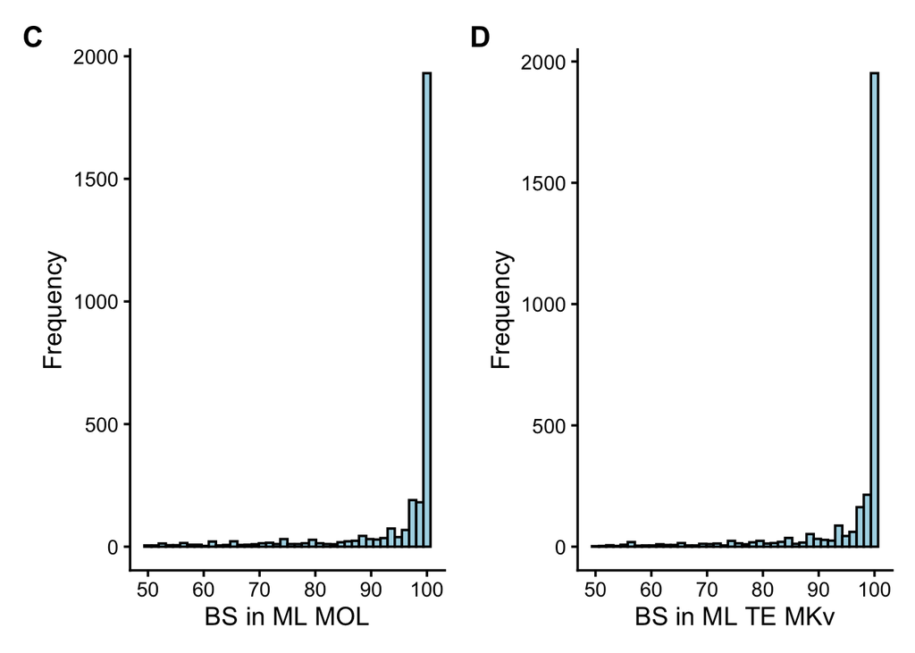

```r
# Histogram ML MOL
p1 <- ggplot(df_MLASC, aes(x = Support_Tree_1)) +
  geom_histogram(
    bins = 40,
    fill = "lightblue",
    color = "black"
  ) +
  labs(x = "BS in ML MOL", y = "Frequency") +
  theme_classic(base_size = 14) +
  theme(
    plot.tag = element_text(face = "bold", size = 16)
  ) +
  labs(tag = "C")

# Histogram ML TE MKv
p2 <- ggplot(df_MLASC, aes(x = Support_Tree_2)) +
  geom_histogram(
    bins = 40,
    fill = "lightblue",
    color = "black"
  ) +
  labs(x = "BS in ML TE MKv", y = "Frequency") +
  theme_classic(base_size = 14) +
  theme(
    plot.tag = element_text(face = "bold", size = 16)
  ) +
  labs(tag = "D")

# Combine into a single ggplot object
s11_ml_mkv_f <- p1 + p2
s11_ml_mkv_f
```

```r
# Shapiro-Wilk test for normality
shapiro.test(df_MLASC$Support_Tree_1) # P < 0.05, non-parametric
```

```
##
##  Shapiro-Wilk normality test
##
## data:  df_MLASC$Support_Tree_1
## W = 0.52504, p-value < 2.2e-16
```

```r
shapiro.test(df_MLASC$Support_Tree_2) # P < 0.05, non-parametric
```

```
##
##  Shapiro-Wilk normality test
##
## data:  df_MLASC$Support_Tree_2
## W = 0.51501, p-value < 2.2e-16
```

```r
# Perform the Wilcoxon signed-rank test for paired values
wilcox.test(as.numeric(df_MLASC$Support_Tree_1),
                       as.numeric(df_MLASC$Support_Tree_2),
                       paired = TRUE)
```

```
##
##  Wilcoxon signed rank test with continuity correction
##
## data:  as.numeric(df_MLASC$Support_Tree_1) and as.numeric(df_MLASC$Support_Tree_2)
## V = 320459, p-value = 0.003148
## alternative hypothesis: true location shift is not equal to 0
```

```r
# Dataset for GLMMs
df_MLASC_glmm_f <- data.frame(
  Node = c(df_MLASC$Node_Tree_1, df_MLASC$Node_Tree_2),
  Approach = c(df_MLASC$Approach1, df_MLASC$Approach2),
  Support = c(df_MLASC$Support_Tree_1, df_MLASC$Support_Tree_2),
  ID = c(df_MLASC$ID, df_MLASC$ID)
)

# GLMM Beta
# Step 1. Scale Support from 0–100 to 0–1
df_MLASC_glmm_f <- df_MLASC_glmm_f %>%
  mutate(Support_prop = Support / 100)
# Beta regression does not allow exact 0 or 1
n <- nrow(df_MLASC_glmm_f)
df_MLASC_glmm_f <- df_MLASC_glmm_f %>%
  mutate(Support_beta = (Support_prop * (n - 1) + 0.5) / n)
ml_asc_beta <- glmmTMB(Support_beta ~ Approach + (1 | ID),
                 family = beta_family(link = "logit"),
                 data = df_MLASC_glmm_f)
summary(ml_asc_beta)
```

```
##  Family: beta  ( logit )
## Formula:          Support_beta ~ Approach + (1 | ID)
## Data: df_MLASC_glmm_f
##
##       AIC       BIC    logLik -2*log(L)  df.resid
##  -50770.7  -50743.9   25389.3  -50778.7      6008
##
## Random effects:
##
## Conditional model:
##  Groups Name        Variance  Std.Dev.
##  ID     (Intercept) 1.902e-09 4.361e-05
## Number of obs: 6012, groups:  ID, 3006
##
## Dispersion parameter for beta family (): 4.22
##
## Conditional model:
##             Estimate Std. Error z value Pr(>|z|)
## (Intercept)  3.07836    0.03025   101.8   <2e-16 ***
## ApproachTE   0.01573    0.02628     0.6     0.55
## ---
## Signif. codes:  0 '***' 0.001 '**' 0.01 '*' 0.05 '.' 0.1 ' ' 1
```

#### Q4.2.2.3 ML MOL vs ML TE noASC

```r
# Filter dataset keeping only ML noASC
df_MLnoASC <- df_q4[grepl("ML-noASC", df_q4$Optimality), ]

# Exploratory data analysis
print("Mean BS in ML MOL")
```

```
## [1] "Mean BS in ML MOL"
```

```r
mean(df_MLnoASC$Support_Tree_1) # MOL
```

```
## [1] 95.51191
```

```r
print("Standard deviation BS in MP MOL")
```

```
## [1] "Standard deviation BS in MP MOL"
```

```r
sd(df_MLnoASC$Support_Tree_1) # MOL
```

```
## [1] 9.99283
```

```r
print("Min BS in ML MOL")
```

```
## [1] "Min BS in ML MOL"
```

```r
min(df_MLnoASC$Support_Tree_1) # MOL
```

```
## [1] 50
```

```r
print("Max BS in ML MOL")
```

```
## [1] "Max BS in ML MOL"
```

```r
max(df_MLnoASC$Support_Tree_1) # MOL
```

```
## [1] 100
```

```r
print("Mean BS in ML TE noASC")
```

```
## [1] "Mean BS in ML TE noASC"
```

```r
mean(df_MLnoASC$Support_Tree_2) # TE
```

```
## [1] 95.80007
```

```r
print("Standard deviation BS in ML TE noASC")
```

```
## [1] "Standard deviation BS in ML TE noASC"
```

```r
sd(df_MLnoASC$Support_Tree_2) # TE
```

```
## [1] 9.174718
```

```r
print("Min BS in ML TE noASC")
```

```
## [1] "Min BS in ML TE noASC"
```

```r
min(df_MLnoASC$Support_Tree_2) # TE
```

```
## [1] 50
```

```r
print("Max BS in ML TE noASC")
```

```
## [1] "Max BS in ML TE noASC"
```

```r
max(df_MLnoASC$Support_Tree_2) # TE
```

```
## [1] 100
```

```r
print("Total no. shared clades between MOL and TE")
```

```
## [1] "Total no. shared clades between MOL and TE"
```

```r
nrow(df_MLnoASC)
```

```
## [1] 2981
```

```r
print("No. shared clades with BS MOL == BS TE")
```

```
## [1] "No. shared clades with BS MOL == BS TE"
```

```r
sum(df_MLnoASC$Support_Tree_1 == df_MLnoASC$Support_Tree_2)
```

```
## [1] 1776
```

```r
print("No. shared clades with BS MOL > BS TE")
```

```
## [1] "No. shared clades with BS MOL > BS TE"
```

```r
sum(df_MLnoASC$Support_Tree_1 > df_MLnoASC$Support_Tree_2)
```

```
## [1] 575
```

```r
print("No. shared clades with BS MOL < BS TE")
```

```
## [1] "No. shared clades with BS MOL < BS TE"
```

```r
sum(df_MLnoASC$Support_Tree_1 < df_MLnoASC$Support_Tree_2)
```

```
## [1] 630
```

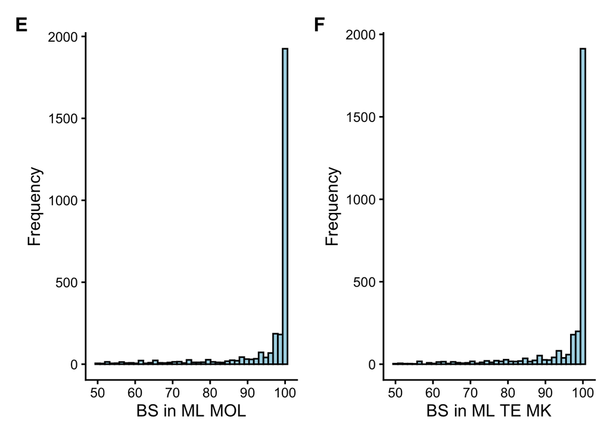

```r
# Histogram ML MOL
p1 <- ggplot(df_MLnoASC, aes(x = Support_Tree_1)) +
  geom_histogram(
    bins = 40,
    fill = "lightblue",
    color = "black"
  ) +
  labs(x = "BS in ML MOL", y = "Frequency") +
  theme_classic(base_size = 14) +
  theme(
    plot.tag = element_text(face = "bold", size = 16)
  ) +
  labs(tag = "E")

# Histogram ML TE MK
p2 <- ggplot(df_MLnoASC, aes(x = Support_Tree_2)) +
  geom_histogram(
    bins = 40,
    fill = "lightblue",
    color = "black"
  ) +
  labs(x = "BS in ML TE MK", y = "Frequency") +
  theme_classic(base_size = 14) +
  theme(
    plot.tag = element_text(face = "bold", size = 16)
  ) +
  labs(tag = "F")

# Combine into a single ggplot object
s11_ml_mk_f <- p1 + p2
s11_ml_mk_f
```

```r
# Shapiro-Wilk test for normality
shapiro.test(df_MLnoASC$Support_Tree_1) # P < 0.05, non-parametric
```

```
##
##  Shapiro-Wilk normality test
##
## data:  df_MLnoASC$Support_Tree_1
## W = 0.51945, p-value < 2.2e-16
```

```r
shapiro.test(df_MLnoASC$Support_Tree_2) # P < 0.05, non-parametric
```

```
##
##  Shapiro-Wilk normality test
##
## data:  df_MLnoASC$Support_Tree_2
## W = 0.53126, p-value < 2.2e-16
```

```r
# Perform the Wilcoxon signed-rank test for paired values
wilcox.test(as.numeric(df_MLnoASC$Support_Tree_1),
                       as.numeric(df_MLnoASC$Support_Tree_2),
                       paired = TRUE)
```

```
##
##  Wilcoxon signed rank test with continuity correction
##
## data:  as.numeric(df_MLnoASC$Support_Tree_1) and as.numeric(df_MLnoASC$Support_Tree_2)
## V = 347800, p-value = 0.1986
## alternative hypothesis: true location shift is not equal to 0
```

```r
# Dataset for GLMMs
df_MLnoASC_glmm_f <- data.frame(
  Node = c(df_MLnoASC$Node_Tree_1, df_MLnoASC$Node_Tree_2),
  Approach = c(df_MLnoASC$Approach1, df_MLnoASC$Approach2),
  Support = c(df_MLnoASC$Support_Tree_1, df_MLnoASC$Support_Tree_2),
  ID = c(df_MLnoASC$ID, df_MLnoASC$ID)
)

# GLMM Beta
# Step 1. Scale Support from 0–100 to 0–1
df_MLnoASC_glmm_f <- df_MLnoASC_glmm_f %>%
  mutate(Support_prop = Support / 100)
# Beta regression does not allow exact 0 or 1
n <- nrow(df_MLnoASC_glmm_f)
df_MLnoASC_glmm_f <- df_MLnoASC_glmm_f %>%
  mutate(Support_beta = (Support_prop * (n - 1) + 0.5) / n)
ml_noasc_beta <- glmmTMB(Support_beta ~ Approach + (1 | ID),
                 family = beta_family(link = "logit"),
                 data = df_MLnoASC_glmm_f)
summary(ml_noasc_beta)
```

```
##  Family: beta  ( logit )
## Formula:          Support_beta ~ Approach + (1 | ID)
## Data: df_MLnoASC_glmm_f
##
##       AIC       BIC    logLik -2*log(L)  df.resid
##  -50109.8  -50083.0   25058.9  -50117.8      5958
##
## Random effects:
##
## Conditional model:
##  Groups Name        Variance Std.Dev.
##  ID     (Intercept) 1.86e-09 4.312e-05
## Number of obs: 5962, groups:  ID, 2981
##
## Dispersion parameter for beta family (): 4.22
##
## Conditional model:
##               Estimate Std. Error z value Pr(>|z|)
## (Intercept)  3.0811341  0.0303620  101.48   <2e-16 ***
## ApproachTE  -0.0009792  0.0263903   -0.04     0.97
## ---
## Signif. codes:  0 '***' 0.001 '**' 0.01 '*' 0.05 '.' 0.1 ' ' 1
```

### Q4.2.3 Plot (Figure S12)

```r
# Create a new column with the optimality criterion
df_MP_glmm$comparison = "MPmol_MPte"
df_MLASC_glmm$comparison = "MLmol_MLteAsc"
df_MLnoASC_glmm$comparison = "MLmol_MLteNoAsc"

# Merge all comparisons into the same dataset
df_plot = bind_rows(df_MP_glmm, df_MLASC_glmm, df_MLnoASC_glmm)
#View(df_plot)

# Set order of comparisons
df_plot$comparison <- factor(df_plot$comparison, levels = c("MPmol_MPte", "MLmol_MLteAsc", "MLmol_MLteNoAsc"))
df_plot = df_plot[!is.na(df_plot$comparison), ]

# Set colors
custom_palette <- c("MPmol_MPte" = "#339999", "MLmol_MLteAsc" = "#6f77b4", "MLmol_MLteNoAsc" = "#cccccc")
# Create custom legend labels
custom_labels <- c(
  "MPmol_MPte" = "MP-MOL vs MP-TE",
  "MLmol_MLteAsc" = "ML-MOL vs ML-TE (with ASC)",
  "MLmol_MLteNoAsc" = "ML-MOL vs ML-TE (without ASC)"
)

# Box Plot MP
plot_mp = ggplot(df_MP_glmm, aes(x = Approach, y = Support)) +
  geom_boxplot(outlier.shape = NA) +  # Create boxplot without default outliers
  geom_jitter(color = "#339999", alpha = .04, width = 0.2) +  # Add transparent dots
  labs(x = "", y = "\nBootstrap\n", tag="A") +
  theme_minimal() +
  #theme(axis.text.x = element_blank(), legend.position = "none") +  # Hide legend if not needed
  scale_color_manual(values = custom_palette, labels = custom_labels)
# Box Plot ML ASC
plot_ml_asc = ggplot(df_MLASC_glmm, aes(x = Approach, y = Support)) +
  geom_boxplot(outlier.shape = NA) +  # Create boxplot without default outliers
  geom_jitter(color = "#6f77b4", alpha = .04, width = 0.2) +  # Add transparent dots
  labs(x = "", y = "\nBootstrap\n", tag="B") +
  theme_minimal() +
  scale_y_continuous(limits = c(50, NA)) + # Define o mínimo para 50, o máximo será ajustado automaticamente
  #theme(axis.text.x = element_blank(), legend.position = "none") +  # Hide legend if not needed
  scale_color_manual(values = custom_palette, labels = custom_labels)
# Box Plot ML noASC
plot_ml_noasc = ggplot(df_MLnoASC_glmm, aes(x = Approach, y = Support)) +
  geom_boxplot(outlier.shape = NA) +  # Create boxplot without default outliers
  geom_jitter(color = "#cccccc", alpha = .07, width = 0.2) +  # Add transparent dots
  labs(x = "", y = "\nBootstrap\n", tag="C") +
  theme_minimal() +
  scale_y_continuous(limits = c(50, NA)) + # Define o mínimo para 50, o máximo será ajustado automaticamente
  #theme(axis.text.x = element_blank(), legend.position = "none") +  # Hide legend if not needed
  scale_color_manual(values = custom_palette, labels = custom_labels)

# Extract the legend as a separate ggplot object
legend <- ggplot(df_plot, aes(x = comparison, y = Support, color = comparison)) +
  geom_point() +
  scale_color_manual(values = custom_palette, labels = custom_labels) +
  theme_minimal() +
  theme(
    legend.position = "bottom",
    legend.title = element_blank(),
    panel.grid = element_blank(),
    panel.background = element_blank(),
    axis.title = element_blank(),
    axis.text = element_blank(),
    axis.ticks = element_blank(),
  )+
  guides(color = guide_legend(override.aes = list(size = 2, alpha=.7)))  # Increase dot size in legend
# Convert the plot to a grob
plot_grob <- ggplotGrob(legend)
# Extract the legend from the grob
legend_grob <- gtable::gtable_filter(plot_grob, "guide-box")

# Plot 2x2
jpeg("Figures/FigS12ABC.jpg", width = 2000, height = 1600, res = 300)
grid.arrange(arrangeGrob(plot_mp + theme(plot.margin = margin(1,1,1,.01)),
                         plot_ml_asc + theme(plot.margin = margin(1,1,1,.01)),
                         plot_ml_noasc + theme(plot.margin = margin(1,1,1,.01)),
                         nrow=1, ncol=3),
             legend_grob,
             nrow=2,
             heights= c(20,1))
dev.off()
```

```r
# Create a new column with the optimality criterion
df_MP_glmm_f$comparison = "MPmol_MPte"
df_MLASC_glmm_f$comparison = "MLmol_MLteAsc"
df_MLnoASC_glmm_f$comparison = "MLmol_MLteNoAsc"

# Merge all comparisons into the same dataset
df_plot = bind_rows(df_MP_glmm_f, df_MLASC_glmm_f, df_MLnoASC_glmm_f)
#View(df_plot)

# Set order of comparisons
df_plot$comparison <- factor(df_plot$comparison, levels = c("MPmol_MPte", "MLmol_MLteAsc", "MLmol_MLteNoAsc"))
df_plot = df_plot[!is.na(df_plot$comparison), ]

# Set colors
custom_palette <- c("MPmol_MPte" = "#339999", "MLmol_MLteAsc" = "#6f77b4", "MLmol_MLteNoAsc" = "#cccccc")
# Create custom legend labels
custom_labels <- c(
  "MPmol_MPte" = "MP-MOL vs MP-TE",
  "MLmol_MLteAsc" = "ML-MOL vs ML-TE (with ASC)",
  "MLmol_MLteNoAsc" = "ML-MOL vs ML-TE (without ASC)"
)

# Box Plot MP
plot_mp = ggplot(df_MP_glmm_f, aes(x = Approach, y = Support)) +
  geom_boxplot(outlier.shape = NA) +  # Create boxplot without default outliers
  geom_jitter(color = "#339999", alpha = .04, width = 0.2) +  # Add transparent dots
  labs(x = "", y = "\nBootstrap\n", tag="D") +
  theme_minimal() +
  #theme(axis.text.x = element_blank(), legend.position = "none") +  # Hide legend if not needed
  scale_color_manual(values = custom_palette, labels = custom_labels)
# Box Plot ML ASC
plot_ml_asc = ggplot(df_MLASC_glmm_f, aes(x = Approach, y = Support)) +
  geom_boxplot(outlier.shape = NA) +  # Create boxplot without default outliers
  geom_jitter(color = "#6f77b4", alpha = .04, width = 0.2) +  # Add transparent dots
  labs(x = "", y = "\nBootstrap\n", tag="E") +
  theme_minimal() +
  scale_y_continuous(limits = c(50, NA)) + # Define o mínimo para 50, o máximo será ajustado automaticamente
  #theme(axis.text.x = element_blank(), legend.position = "none") +  # Hide legend if not needed
  scale_color_manual(values = custom_palette, labels = custom_labels)
# Box Plot ML noASC
plot_ml_noasc = ggplot(df_MLnoASC_glmm_f, aes(x = Approach, y = Support)) +
  geom_boxplot(outlier.shape = NA) +  # Create boxplot without default outliers
  geom_jitter(color = "#cccccc", alpha = .07, width = 0.2) +  # Add transparent dots
  labs(x = "", y = "\nBootstrap\n", tag="F") +
  theme_minimal() +
  scale_y_continuous(limits = c(50, NA)) + # Define o mínimo para 50, o máximo será ajustado automaticamente
  #theme(axis.text.x = element_blank(), legend.position = "none") +  # Hide legend if not needed
  scale_color_manual(values = custom_palette, labels = custom_labels)

# Extract the legend as a separate ggplot object
legend <- ggplot(df_plot, aes(x = comparison, y = Support, color = comparison)) +
  geom_point() +
  scale_color_manual(values = custom_palette, labels = custom_labels) +
  theme_minimal() +
  theme(
    legend.position = "bottom",
    legend.title = element_blank(),
    panel.grid = element_blank(),
    panel.background = element_blank(),
    axis.title = element_blank(),
    axis.text = element_blank(),
    axis.ticks = element_blank(),
  )+
  guides(color = guide_legend(override.aes = list(size = 2, alpha=.7)))  # Increase dot size in legend
# Convert the plot to a grob
plot_grob <- ggplotGrob(legend)
# Extract the legend from the grob
legend_grob <- gtable::gtable_filter(plot_grob, "guide-box")

# Plot 2x2
jpeg("Figures/FigS12DEF.jpg", width = 2000, height = 1600, res = 300)
grid.arrange(arrangeGrob(plot_mp + theme(plot.margin = margin(1,1,1,.01)),
                         plot_ml_asc + theme(plot.margin = margin(1,1,1,.01)),
                         plot_ml_noasc + theme(plot.margin = margin(1,1,1,.01)),
                         nrow=1, ncol=3),
             legend_grob,
             nrow=2,
             heights= c(20,1))
dev.off()
```

##Q4.3 Distribution of BS (Figure S11)

```r
s11 <- s11_mp /
       s11_ml_mkv /
       s11_ml_mk +
  plot_layout(ncol = 1)

ggsave(
  "Figures/FigS11.jpg",
  s11,
  width = 8,
  height = 12,
  dpi = 300
)
```

## Q4.4 Delta BS

### Q4.4.1 Delta BS vs %Morph Characters

```r
# Load data (BS shared clades)
df_q4 = read.csv("Dataset_R_q4_07-26_shared.csv")

# Set order of optimality criteria
df_q4$Optimality <- factor(df_q4$Optimality, levels = c("MP", "ML-ASC", "ML-noASC"))
df_q4$SupportDiff = df_q4$Support_Tree_1 - df_q4$Support_Tree_2

# Values for Dataset 1 to 63
percentage_values <- c(
  0.013684211,
  0.055498458,
  0.044244604,
  0.010054845,
  0.040086674,
  0.029837251,
  0.003562696,
  0.007741348,
  0.023512123,
  0.071167883,
  0.007282437,
  0.017531845,
  0.061922366,
  0.109683341,
  0.036553525,
  0.044558259,
  0.064782529,
  0.007295159,
  0.017535293,
  0.018518519,
  0.019484107,
  0.015642458,
  0.024666499,
  0.061140648,
  0.005056974,
  0.020840692,
  0.018851757,
  0.015837821,
  0.014669927,
  0.028189008,
  0.009686347,
  0.046779502,
  0.037445802,
  0.019918612,
  0.023357664,
  0.021806167,
  4.97146E-05,
  0.044444444,
  0.052168022,
  0.024225249,
  0.023332685,
  0.030917874,
  0.144177449,
  0.003291020,
  0.022148623,
  0.000299521,
  0.035170604,
  0.032027879,
  0.007404914,
  0.010775862,
  0.000303870,
  0.040114613,
  0.011265702,
  0.039204652,
  0.000594695,
  0.000488948,
  0.001320755,
  0.000138570,
  0.001701958,
  0.000458127,
  0.003507878,
  0.000303716,
  0.000555860
)

# Add the new column
df_q4$PercentageMorphCharacters <- percentage_values[df_q4$Dataset]

# Make positive values when TE BS is higher than MOL BS
df_q4$SupportDiff <- -(df_q4$SupportDiff)
```

```r
# Fit mixed-effects model
m_q4 <- lmer(
  SupportDiff ~ PercentageMorphCharacters + (1 | Dataset),
  data = df_q4
)
# Model summary
summary(m_q4)
```

```
## Linear mixed model fit by REML. t-tests use Satterthwaite's method [
## lmerModLmerTest]
## Formula: SupportDiff ~ PercentageMorphCharacters + (1 | Dataset)
##    Data: df_q4
##
## REML criterion at convergence: 57811.8
##
## Scaled residuals:
##     Min      1Q  Median      3Q     Max
## -6.9212 -0.1703 -0.0270  0.0664  6.5485
##
## Random effects:
##  Groups   Name        Variance Std.Dev.
##  Dataset  (Intercept)  1.818   1.348
##  Residual             51.202   7.156
## Number of obs: 8522, groups:  Dataset, 63
##
## Fixed effects:
##                           Estimate Std. Error      df t value Pr(>|t|)
## (Intercept)                 0.2307     0.2718 61.6032   0.849   0.3994
## PercentageMorphCharacters  17.0387     7.3866 61.4591   2.307   0.0245 *
## ---
## Signif. codes:  0 '***' 0.001 '**' 0.01 '*' 0.05 '.' 0.1 ' ' 1
##
## Correlation of Fixed Effects:
##             (Intr)
## PrcntgMrphC -0.676
```

```r
# Test fixed effect
anova(m_q4)
```

```
## Type III Analysis of Variance Table with Satterthwaite's method
##                           Sum Sq Mean Sq NumDF  DenDF F value  Pr(>F)
## PercentageMorphCharacters 272.44  272.44     1 61.459  5.3209 0.02446 *
## ---
## Signif. codes:  0 '***' 0.001 '**' 0.01 '*' 0.05 '.' 0.1 ' ' 1
```

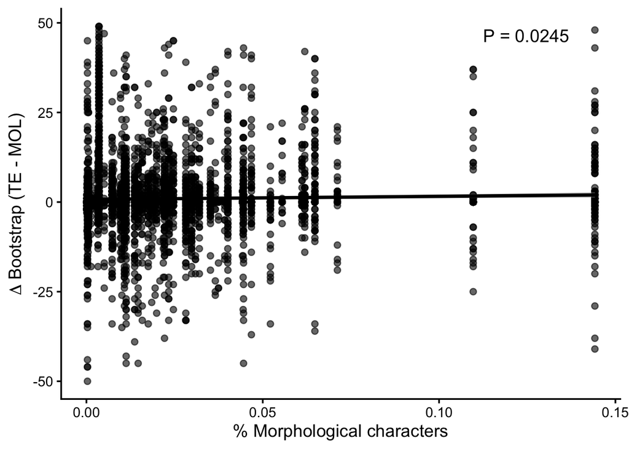

```r
# Extract P-value
pval <- anova(m_q4)$`Pr(>F)`[1]

fig_q4 <- ggplot(
  df_q4,
  aes(x = PercentageMorphCharacters, y = SupportDiff)
) +
  geom_point(alpha = 0.6, size = 2) +
  geom_smooth(method = "lm", color = "black", se = TRUE) +
  annotate(
    "text",
    x = max(df_q4$PercentageMorphCharacters) * 0.95,  # move left
    y = max(df_q4$SupportDiff, na.rm = TRUE),
    hjust = 1,
    vjust = 1.2,
    label = sprintf("P = %.3g", pval),
    size = 5
  ) +
  labs(
    x = "% Morphological characters",
    y = expression(Delta*" Bootstrap (TE - MOL)")
  ) +
  theme_classic(base_size = 14)
fig_q4
```

```r
# Compute mean SupportDiff per dataset
df_q4_mean <- df_q4 %>%
  group_by(Dataset) %>%
  summarise(
    MeanSupportDiff = mean(SupportDiff, na.rm = TRUE),
    PercentageMorphCharacters = first(PercentageMorphCharacters),
    .groups = "drop"
  )

# Spearman correlation
cor_test <- cor.test(
  df_q4_mean$MeanSupportDiff,
  df_q4_mean$PercentageMorphCharacters,
  method = "spearman",
  exact = FALSE
)

# Print results
cor_test
```

```
##
##  Spearman's rank correlation rho
##
## data:  df_q4_mean$MeanSupportDiff and df_q4_mean$PercentageMorphCharacters
## S = 23097, p-value = 0.0002521
## alternative hypothesis: true rho is not equal to 0
## sample estimates:
##       rho
## 0.4456419
```

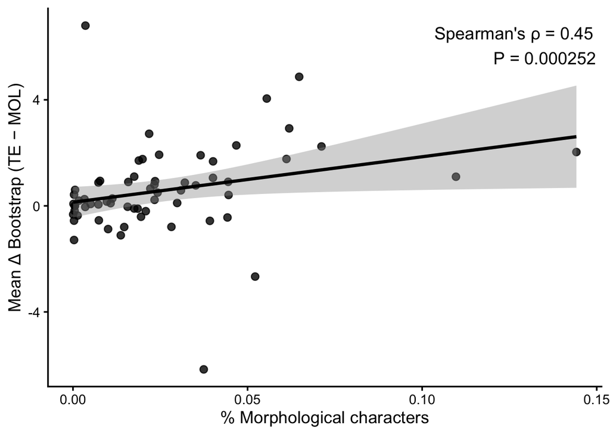

```r
# Plot
fig_q4_mean <- ggplot(
  df_q4_mean,
  aes(x = PercentageMorphCharacters, y = MeanSupportDiff)
) +
  geom_point(size = 2.5, alpha = 0.8) +
  geom_smooth(method = "lm", se = TRUE, color = "black") +
  annotate(
    "text",
    x = Inf, y = Inf,
    hjust = 1.05, vjust = 1.5,
    label = sprintf(
      "Spearman's \u03C1 = %.2f\nP = %.3g",
      unname(cor_test$estimate),
      cor_test$p.value
    ),
    size = 5
  ) +
  labs(
    x = "% Morphological characters",
    y = "Mean Δ Bootstrap (TE − MOL)"
  ) +
  theme_classic(base_size = 14)

fig_q4_mean
```

### Q4.4.2 Delta BS vs %Morph-only taxa

```r
# Load data (BS shared clades)
df_q4 = read.csv("Dataset_R_q4_09-25_shared_extinct.csv")

# Set order of optimality criteria
df_q4$Optimality <- factor(df_q4$Optimality, levels = c("MP", "ML-ASC", "ML-noASC"))
df_q4$SupportDiff = df_q4$Support_Tree_1 - df_q4$Support_Tree_2

# Make positive values when TE BS is higher than MOL BS
df_q4$SupportDiff <- -(df_q4$SupportDiff)

# Values for Dataset 1 to 22
morph_only_taxa <- c(
  0.756756757,
  0.011111111,
  0.125000000,
  0.135135135,
  0.272727273,
  0.412087912,
  0.403225806,
  0.477876106,
  0.430769231,
  0.113636364,
  0.666666667,
  0.936170213,
  0.113636364,
  0.340425532,
  0.295081967,
  0.892473118,
  0.125000000,
  0.070707071,
  0.036363636,
  0.578475336,
  0.583333333,
  0.120000000
)

# Create the new column
df_q4$PercentageMorphOnlyTaxa <- morph_only_taxa[df_q4$Dataset]
```

```r
# Fit mixed-effects model
m_q4 <- lmer(
  SupportDiff ~ PercentageMorphOnlyTaxa + (1 | Dataset),
  data = df_q4
)
# Model summary
summary(m_q4)
```

```
## Linear mixed model fit by REML. t-tests use Satterthwaite's method [
## lmerModLmerTest]
## Formula: SupportDiff ~ PercentageMorphOnlyTaxa + (1 | Dataset)
##    Data: df_q4
##
## REML criterion at convergence: 19480.1
##
## Scaled residuals:
##     Min      1Q  Median      3Q     Max
## -4.3658 -0.5637  0.0777  0.3471  3.6761
##
## Random effects:
##  Groups   Name        Variance Std.Dev.
##  Dataset  (Intercept)  18.72    4.327
##  Residual             140.08   11.836
## Number of obs: 2498, groups:  Dataset, 22
##
## Fixed effects:
##                         Estimate Std. Error      df t value Pr(>|t|)
## (Intercept)                0.548      1.595  16.508   0.344  0.73544
## PercentageMorphOnlyTaxa  -11.347      3.660  18.571  -3.101  0.00601 **
## ---
## Signif. codes:  0 '***' 0.001 '**' 0.01 '*' 0.05 '.' 0.1 ' ' 1
##
## Correlation of Fixed Effects:
##             (Intr)
## PrcntgMrpOT -0.789
```

```r
# Test fixed effect
anova(m_q4)
```

```
## Type III Analysis of Variance Table with Satterthwaite's method
##                         Sum Sq Mean Sq NumDF  DenDF F value   Pr(>F)
## PercentageMorphOnlyTaxa 1346.7  1346.7     1 18.571  9.6135 0.006005 **
## ---
## Signif. codes:  0 '***' 0.001 '**' 0.01 '*' 0.05 '.' 0.1 ' ' 1
```

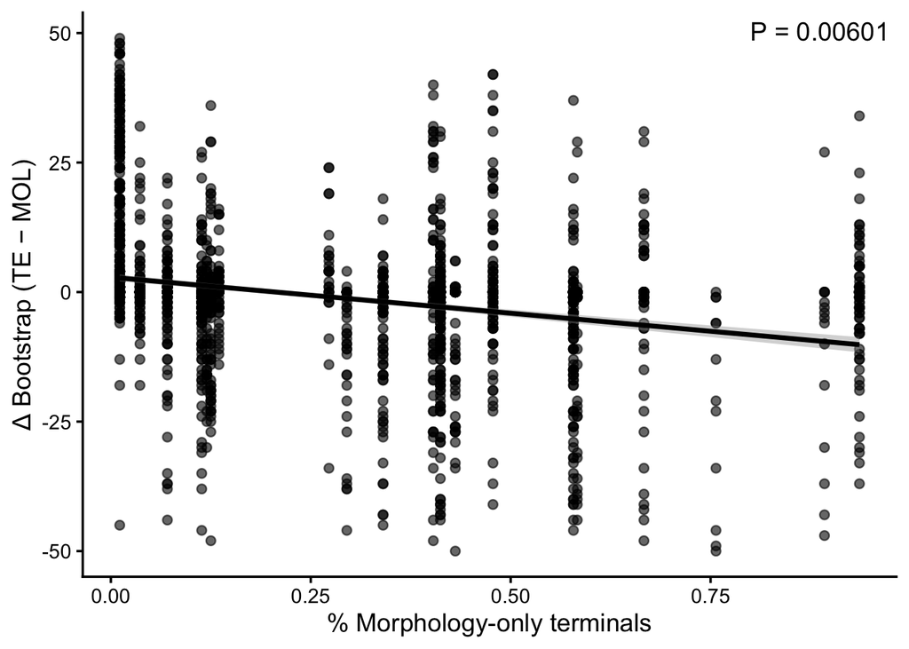

```r
# Extract P-value
pval <- anova(m_q4)$`Pr(>F)`[1]

fig_q4_f <- ggplot(
  df_q4,
  aes(x = PercentageMorphOnlyTaxa, y = SupportDiff)
) +
  geom_point(alpha = 0.6, size = 2) +
  geom_smooth(method = "lm", color = "black", se = TRUE) +
  annotate(
    "text",
    x = Inf, y = Inf,
    hjust = 1.05, vjust = 1.5,
    label = sprintf(
      "P = %.3g",
      pval
    ),
    size = 5
  ) +
  labs(
    x = "% Morphology-only terminals",
    y = "Δ Bootstrap (TE − MOL)"
  ) +
  theme_classic(base_size = 14)

fig_q4_f
```

```r
# Compute mean SupportDiff per dataset
df_q4_mean <- df_q4 %>%
  group_by(Dataset) %>%
  summarise(
    MeanSupportDiff = mean(SupportDiff, na.rm = TRUE),
    PercentageMorphOnlyTaxa = first(PercentageMorphOnlyTaxa),
    .groups = "drop"
  )

# Spearman correlation
cor_test <- cor.test(
  df_q4_mean$MeanSupportDiff,
  df_q4_mean$PercentageMorphOnlyTaxa,
  method = "spearman",
  exact = FALSE
)

# Print results
cor_test
```

```
##
##  Spearman's rank correlation rho
##
## data:  df_q4_mean$MeanSupportDiff and df_q4_mean$PercentageMorphOnlyTaxa
## S = 2799.6, p-value = 0.004593
## alternative hypothesis: true rho is not equal to 0
## sample estimates:
##        rho
## -0.5807911
```

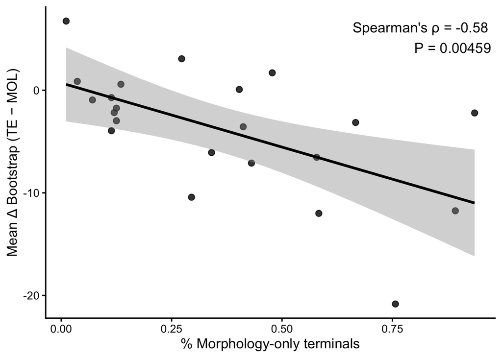

```r
# Plot
fig_q4_mean_f <- ggplot(
  df_q4_mean,
  aes(x = PercentageMorphOnlyTaxa, y = MeanSupportDiff)
) +
  geom_point(size = 2.5, alpha = 0.8) +
  geom_smooth(method = "lm", se = TRUE, color = "black") +
  annotate(
    "text",
    x = Inf, y = Inf,
    hjust = 1.05, vjust = 1.5,
    label = sprintf(
      "Spearman's \u03C1 = %.2f\nP = %.3g",
      unname(cor_test$estimate),
      cor_test$p.value
    ),
    size = 5
  ) +
  labs(
    x = "% Morphology-only terminals",
    y = "Mean Δ Bootstrap (TE − MOL)"
  ) +
  theme_classic(base_size = 14)

fig_q4_mean_f
```

###Q4.4.3 Figure 7

```r
fig_q4_all <-
  (fig_q4 | fig_q4_mean) /
  (fig_q4_f | fig_q4_mean_f) +
  plot_annotation(tag_levels = "a")

ggsave(
  "Figures/Fig7.jpg",
  fig_q4_all,
  width = 10,
  height = 8,
  dpi = 300
)
```

# Q5. Can bootstrap from MOL clades retrodict the monophyly of TE groups?

The datasets used in the Q5 was prepared with the package RNODE using the script 3.

## Q5.1 Extant

```r
# Load data
df_q5 = read.csv("/Users/labanfibios/Desktop/Doutorado/Project/B2_TEvsMOL/GitHub/Dataset_R_q5_07-26.csv")
# Only keep >50% BS
df_q5 <- df_q5[df_q5$support_tree1 >= 50, ]

# Select MP
MPlogistic <- df_q5[df_q5$optimality == "MP", ]
# Select ML ASC
MLASClogistic <- df_q5[df_q5$optimality == "MLASC", ]
# Select ML no ASC
MLnoASClogistic <- df_q5[df_q5$optimality == "MLnoASC", ]
```

### Q5.1.1 Data exploration (Table S8)

```r
#############################
# EXPLORATORY DATA ANALYSES #
#############################

# A) MP
# Total number of MOL clades
nrow(MPlogistic)
```

```
## [1] 2719
```

```r
# Shared clades
nrow(subset(MPlogistic, occurrence_tree2 == 1)) # Number of shared clades
```

```
## [1] 2569
```

```r
nrow(subset(MPlogistic, occurrence_tree2 == 1))/nrow(MPlogistic) # Proportion shared/total
```

```
## [1] 0.9448327
```

```r
mean(subset(MPlogistic, occurrence_tree2 == 1)$support_tree1) # BS mean
```

```
## [1] 90.77812
```

```r
sd(subset(MPlogistic, occurrence_tree2 == 1)$support_tree1) # BS sd
```

```
## [1] 13.84043
```

```r
range(subset(MPlogistic, occurrence_tree2 == 1)$support_tree1) # BS range
```

```
## [1]  50 100
```

```r
# Unique clades for MOL
nrow(subset(MPlogistic, occurrence_tree2 == 0)) # Number of unique clades for MOL
```

```
## [1] 150
```

```r
nrow(subset(MPlogistic, occurrence_tree2 == 0))/nrow(MPlogistic) # Proportion uniqueMOL/total
```

```
## [1] 0.05516734
```

```r
mean(subset(MPlogistic, occurrence_tree2 == 0)$support_tree1) # BS mean
```

```
## [1] 62.53333
```

```r
sd(subset(MPlogistic, occurrence_tree2 == 0)$support_tree1) # BS sd
```

```
## [1] 12.29594
```

```r
range(subset(MPlogistic, occurrence_tree2 == 0)$support_tree1) # BS range
```

```
## [1]  50 100
```

```r
# MOL clades with BS <60 present in TE
nrow(subset(MPlogistic, support_tree1 < 60 & occurrence_tree2 == 1)) # Number of MOL clades with BS <60 that occur in TE
```

```
## [1] 140
```

```r
nrow(subset(MPlogistic, support_tree1 < 60 & occurrence_tree2 == 1))/nrow(MPlogistic) # Proportion of MOL clades with BS <60 that occur in TE
```

```
## [1] 0.05148952
```

```r
# MOL clades with BS >90 absent in TE
nrow(subset(MPlogistic, support_tree1 > 90 & occurrence_tree2 == 0)) # Number of MOL lades with BS >90 absent in TE
```

```
## [1] 9
```

```r
nrow(subset(MPlogistic, support_tree1 > 90 & occurrence_tree2 == 0))/nrow(MPlogistic) # Proportion of MOL lades with BS >90 absent in TE
```

```
## [1] 0.00331004
```

```r
nrow(subset(MPlogistic, support_tree1 == 100 & occurrence_tree2 == 0)) # MOL clades with BS = 100 absent in TE
```

```
## [1] 1
```

```r
# B) ML ASC
# Total number of MOL clades
nrow(MLASClogistic)
```

```
## [1] 3334
```

```r
# Shared clades
nrow(subset(MLASClogistic, occurrence_tree2 == 1)) # Number of shared clades
```

```
## [1] 2997
```

```r
nrow(subset(MLASClogistic, occurrence_tree2 == 1))/nrow(MLASClogistic) # Proportion shared/total
```

```
## [1] 0.8989202
```

```r
mean(subset(MLASClogistic, occurrence_tree2 == 1)$support_tree1) # BS mean
```

```
## [1] 95.31298
```

```r
sd(subset(MLASClogistic, occurrence_tree2 == 1)$support_tree1) # BS sd
```

```
## [1] 10.25624
```

```r
range(subset(MLASClogistic, occurrence_tree2 == 1)$support_tree1) # BS range
```

```
## [1]  50 100
```

```r
# Unique clades for MOL
nrow(subset(MLASClogistic, occurrence_tree2 == 0)) # Number of unique clades for MOL
```

```
## [1] 337
```

```r
nrow(subset(MLASClogistic, occurrence_tree2 == 0))/nrow(MLASClogistic) # Proportion uniqueMOL/total
```

```
## [1] 0.1010798
```

```r
mean(subset(MLASClogistic, occurrence_tree2 == 0)$support_tree1) # BS mean
```

```
## [1] 78.24629
```

```r
sd(subset(MLASClogistic, occurrence_tree2 == 0)$support_tree1) # BS sd
```

```
## [1] 15.95926
```

```r
range(subset(MLASClogistic, occurrence_tree2 == 0)$support_tree1) # BS range
```

```
## [1]  50 100
```

```r
# MOL clades with BS <60 present in TE
nrow(subset(MLASClogistic, support_tree1 < 60 & occurrence_tree2 == 1)) # Number of MOL clades with BS <60 that occur in TE
```

```
## [1] 68
```

```r
nrow(subset(MLASClogistic, support_tree1 < 60 & occurrence_tree2 == 1))/nrow(MLASClogistic) # Proportion of MOL clades with BS <60 that occur in TE
```

```
## [1] 0.02039592
```

```r
# MOL clades with BS >90 absent in TE
nrow(subset(MLASClogistic, support_tree1 > 90 & occurrence_tree2 == 0)) # Number of MOL lades with BS >90 absent in TE
```

```
## [1] 97
```

```r
nrow(subset(MLASClogistic, support_tree1 > 90 & occurrence_tree2 == 0))/nrow(MLASClogistic) # Proportion of MOL lades with BS >90 absent in TE
```

```
## [1] 0.02909418
```

```r
nrow(subset(MLASClogistic, support_tree1 == 100 & occurrence_tree2 == 0)) # MOL clades with BS = 100 absent in TE
```

```
## [1] 27
```

```r
# C) ML noASC
# Total number of MOL clades
nrow(MLnoASClogistic)
```

```
## [1] 3334
```

```r
# Shared clades
nrow(subset(MLnoASClogistic, occurrence_tree2 == 1)) # Number of shared clades
```

```
## [1] 2986
```

```r
nrow(subset(MLnoASClogistic, occurrence_tree2 == 1))/nrow(MLnoASClogistic) # Proportion shared/total
```

```
## [1] 0.8956209
```

```r
mean(subset(MLnoASClogistic, occurrence_tree2 == 1)$support_tree1) # BS mean
```

```
## [1] 95.36403
```

```r
sd(subset(MLnoASClogistic, occurrence_tree2 == 1)$support_tree1) # BS sd
```

```
## [1] 10.18784
```

```r
range(subset(MLnoASClogistic, occurrence_tree2 == 1)$support_tree1) # BS range
```

```
## [1]  50 100
```

```r
# Unique clades for MOL
nrow(subset(MLnoASClogistic, occurrence_tree2 == 0)) # Number of unique clades for MOL
```

```
## [1] 348
```

```r
nrow(subset(MLnoASClogistic, occurrence_tree2 == 0))/nrow(MLnoASClogistic) # Proportion uniqueMOL/total
```

```
## [1] 0.1043791
```

```r
mean(subset(MLnoASClogistic, occurrence_tree2 == 0)$support_tree1) # BS mean
```

```
## [1] 78.3477
```

```r
sd(subset(MLnoASClogistic, occurrence_tree2 == 0)$support_tree1) # BS sd
```

```
## [1] 16.00603
```

```r
range(subset(MLnoASClogistic, occurrence_tree2 == 0)$support_tree1) # BS range
```

```
## [1]  50 100
```

```r
# MOL clades with BS <60 present in TE
nrow(subset(MLnoASClogistic, support_tree1 < 60 & occurrence_tree2 == 1)) # Number of MOL clades with BS <60 that occur in TE
```

```
## [1] 65
```

```r
nrow(subset(MLnoASClogistic, support_tree1 < 60 & occurrence_tree2 == 1))/nrow(MLnoASClogistic) # Proportion of MOL clades with BS <60 that occur in TE
```

```
## [1] 0.0194961
```

```r
# MOL clades with BS >90 absent in TE
nrow(subset(MLnoASClogistic, support_tree1 > 90 & occurrence_tree2 == 0)) # Number of MOL lades with BS >90 absent in TE
```

```
## [1] 103
```

```r
nrow(subset(MLnoASClogistic, support_tree1 > 90 & occurrence_tree2 == 0))/nrow(MLnoASClogistic) # Proportion of MOL lades with BS >90 absent in TE
```

```
## [1] 0.03089382
```

```r
nrow(subset(MLnoASClogistic, support_tree1 == 100 & occurrence_tree2 == 0)) # MOL clades with BS = 100 absent in TE
```

```
## [1] 30
```

### Q5.1.2 Logistic regressions (Table 6)

```r
#######################
# LOGISTIC REGRESSION #
#######################

# A) MP
# Perform logistic regression
mp_logistic_result <- glm(occurrence_tree2 ~ support_tree1, data = MPlogistic, family = binomial)
# Print a summary of the model
summary(mp_logistic_result)
```

```
##
## Call:
## glm(formula = occurrence_tree2 ~ support_tree1, family = binomial,
##     data = MPlogistic)
##
## Coefficients:
##                Estimate Std. Error z value Pr(>|z|)
## (Intercept)   -5.214662   0.457579  -11.40   <2e-16 ***
## support_tree1  0.105577   0.006893   15.32   <2e-16 ***
## ---
## Signif. codes:  0 '***' 0.001 '**' 0.01 '*' 0.05 '.' 0.1 ' ' 1
##
## (Dispersion parameter for binomial family taken to be 1)
##
##     Null deviance: 1160.78  on 2718  degrees of freedom
## Residual deviance:  769.13  on 2717  degrees of freedom
## AIC: 773.13
##
## Number of Fisher Scoring iterations: 7
```

```r
# Calculate 95% confidence intervals for the coefficients
confint(mp_logistic_result)
```

```
##                     2.5 %     97.5 %
## (Intercept)   -6.13950716 -4.3414958
## support_tree1  0.09263027  0.1197244
```

```r
# Interpretation
exp(mp_logistic_result$coefficients[[2]]) # If coefficient is 0.09 and exp(0.09) is 1.1, then each unit of 1% bootstrap in MOL clade increases the chance of the occurrence of this clade in TE by 10%
```

```
## [1] 1.111352
```

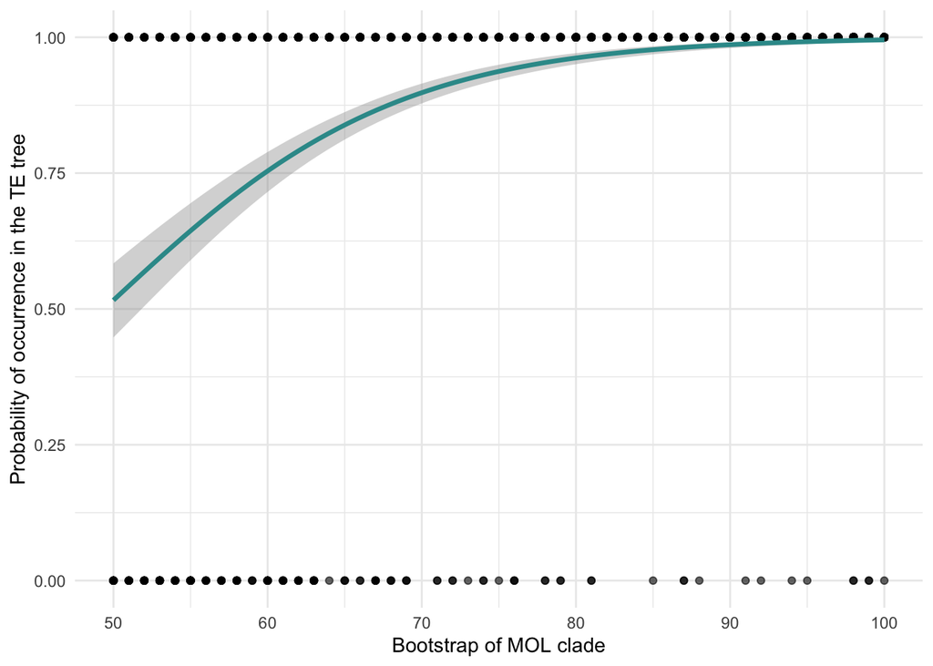

```r
# Plot the logistic regression curve with ggplot2
ggplot(MPlogistic, aes(x = support_tree1, y = occurrence_tree2)) +
  geom_point(alpha = 0.6) +  # Plot the data points
  geom_smooth(method = "glm", method.args = list(family = "binomial"),
              color = "#339999", size = 1.2) +  # Logistic regression curve
  labs(x = "Bootstrap of MOL clade", y = "Probability of occurrence in the TE tree") +
  theme_minimal()
```

```r
# B) ML ASC
# Perform logistic regression
mlasc_logistic_result <- glm(occurrence_tree2 ~ support_tree1, data = MLASClogistic, family = binomial)
# Print a summary of the model
summary(mlasc_logistic_result)
```

```
##
## Call:
## glm(formula = occurrence_tree2 ~ support_tree1, family = binomial,
##     data = MLASClogistic)
##
## Coefficients:
##                Estimate Std. Error z value Pr(>|z|)
## (Intercept)   -4.561034   0.323424  -14.10   <2e-16 ***
## support_tree1  0.076232   0.003782   20.16   <2e-16 ***
## ---
## Signif. codes:  0 '***' 0.001 '**' 0.01 '*' 0.05 '.' 0.1 ' ' 1
##
## (Dispersion parameter for binomial family taken to be 1)
##
##     Null deviance: 2183.4  on 3333  degrees of freedom
## Residual deviance: 1762.2  on 3332  degrees of freedom
## AIC: 1766.2
##
## Number of Fisher Scoring iterations: 5
```

```r
# Calculate 95% confidence intervals for the coefficients
confint(mlasc_logistic_result)
```

```
##                    2.5 %     97.5 %
## (Intercept)   -5.1989840 -3.9302495
## support_tree1  0.0688833  0.0837182
```

```r
# Interpretation
exp(mlasc_logistic_result$coefficients[[2]]) # If coefficient is 0.06 and exp(0.09) is 1.06, then the each unit of 1% bootstrap in MOL clade increases the chance of the occurrence of this clade in TE by 6%
```

```
## [1] 1.079213
```

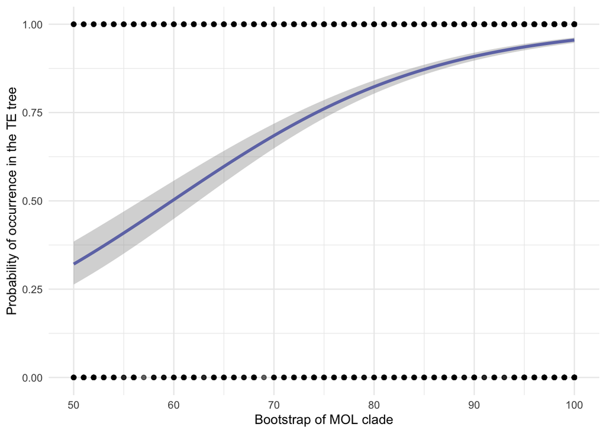

```r
# Plot the logistic regression curve with ggplot2
ggplot(MLASClogistic, aes(x = support_tree1, y = occurrence_tree2)) +
  geom_point(alpha = 0.6) +  # Plot the data points
  geom_smooth(method = "glm", method.args = list(family = "binomial"),
              color = "#6f77b4", size = 1.2) +  # Logistic regression curve
  labs(x = "Bootstrap of MOL clade", y = "Probability of occurrence in the TE tree") +
  theme_minimal()
```

```r
# C) ML noASC
# Perform logistic regression
mlnoasc_logistic_result <- glm(occurrence_tree2 ~ support_tree1, data = MLnoASClogistic, family = binomial)
# Print a summary of the model
summary(mlnoasc_logistic_result)
```

```
##
## Call:
## glm(formula = occurrence_tree2 ~ support_tree1, family = binomial,
##     data = MLnoASClogistic)
##
## Coefficients:
##                Estimate Std. Error z value Pr(>|z|)
## (Intercept)   -4.638287   0.322493  -14.38   <2e-16 ***
## support_tree1  0.076624   0.003761   20.37   <2e-16 ***
## ---
## Signif. codes:  0 '***' 0.001 '**' 0.01 '*' 0.05 '.' 0.1 ' ' 1
##
## (Dispersion parameter for binomial family taken to be 1)
##
##     Null deviance: 2231.1  on 3333  degrees of freedom
## Residual deviance: 1797.9  on 3332  degrees of freedom
## AIC: 1801.9
##
## Number of Fisher Scoring iterations: 5
```

```r
# Calculate 95% confidence intervals for the coefficients
confint(mlnoasc_logistic_result)
```

```
##                     2.5 %      97.5 %
## (Intercept)   -5.27467248 -4.00961500
## support_tree1  0.06931749  0.08407007
```

```r
# Interpretation
exp(mlnoasc_logistic_result$coefficients[[2]]) # If coefficient is 0.06 and exp(0.09) is 1.06, then the each unit of 1% bootstrap in MOL clade increases the chance of the occurrence of this clade in TE by 6%
```

```
## [1] 1.079636
```

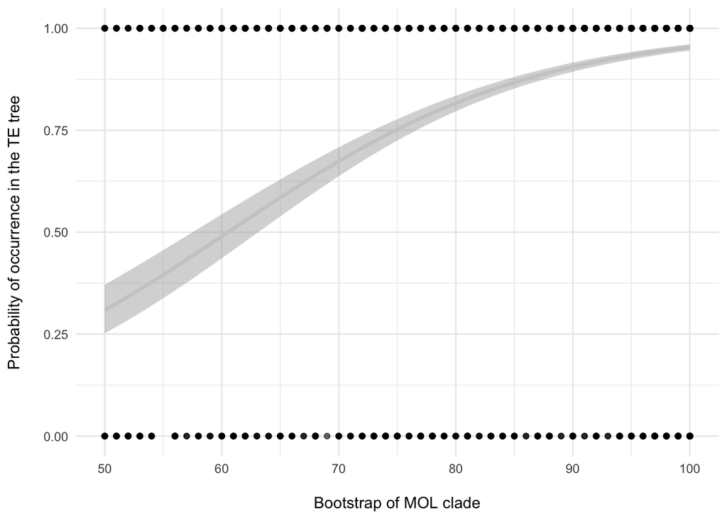

```r
# Plot the logistic regression curve with ggplot2
ggplot(MLnoASClogistic, aes(x = support_tree1, y = occurrence_tree2)) +
  geom_point(alpha = 0.6) +  # Plot the data points
  geom_smooth(method = "glm", method.args = list(family = "binomial"),
              color = "#cccccc", size = 1.2) +  # Logistic regression curve
  labs(x = "\nBootstrap of MOL clade", y = "Probability of occurrence in the TE tree\n") +
  theme_minimal()
```

###Q5.1.3 Interaction with size (Table S10, S11, S12, S13)

```r
# Load data
df_q5 = read.csv("/Users/labanfibios/Desktop/Doutorado/Project/B2_TEvsMOL/GitHub/Dataset_R_q5_07-26.csv")
# Only keep >50% BS
df_q5 <- df_q5[df_q5$support_tree1 >= 50, ]

# Values for Dataset 1 to 63
percentage_values <- c(
  0.013684211,
  0.055498458,
  0.044244604,
  0.010054845,
  0.040086674,
  0.029837251,
  0.003562696,
  0.007741348,
  0.023512123,
  0.071167883,
  0.007282437,
  0.017531845,
  0.061922366,
  0.109683341,
  0.036553525,
  0.044558259,
  0.064782529,
  0.007295159,
  0.017535293,
  0.018518519,
  0.019484107,
  0.015642458,
  0.024666499,
  0.061140648,
  0.005056974,
  0.020840692,
  0.018851757,
  0.015837821,
  0.014669927,
  0.028189008,
  0.009686347,
  0.046779502,
  0.037445802,
  0.019918612,
  0.023357664,
  0.021806167,
  4.97146E-05,
  0.044444444,
  0.052168022,
  0.024225249,
  0.023332685,
  0.030917874,
  0.144177449,
  0.003291020,
  0.022148623,
  0.000299521,
  0.035170604,
  0.032027879,
  0.007404914,
  0.010775862,
  0.000303870,
  0.040114613,
  0.011265702,
  0.039204652,
  0.000594695,
  0.000488948,
  0.001320755,
  0.000138570,
  0.001701958,
  0.000458127,
  0.003507878,
  0.000303716,
  0.000555860
)

# Add the new column
df_q5$PercentageMorphCharacters <- percentage_values[df_q5$Dataset]

# Select MP
MPlogistic <- df_q5[df_q5$optimality == "MP", ]
# Select ML ASC
MLASClogistic <- df_q5[df_q5$optimality == "MLASC", ]
# Select ML no ASC
MLnoASClogistic <- df_q5[df_q5$optimality == "MLnoASC", ]
```

```r
# Statistical interaction analyses with MP

# Model 1: bootstrap only
m1 <- glmer(
  occurrence_tree2 ~ support_tree1 + (1 | Dataset),
  data = MPlogistic,
  family = binomial
)

# Model 2: additive effects
m2 <- glmer(
  occurrence_tree2 ~ support_tree1 + PercentageMorphCharacters + (1 | Dataset),
  data = MPlogistic,
  family = binomial
)
# Model 3: interaction
m3 <- glmer(
  occurrence_tree2 ~ support_tree1 * PercentageMorphCharacters + (1 | Dataset),
  data = MPlogistic,
  family = binomial
)
# Selection
AIC(m1, m2, m3)
```

```
##    df      AIC
## m1  3 705.8096
## m2  4 701.6894
## m3  5 700.5339
```

```r
anova(m1, m2, test = "Chisq")   # Does PercentageMorphCharacters improve the model?
```

```
## Data: MPlogistic
## Models:
## m1: occurrence_tree2 ~ support_tree1 + (1 | Dataset)
## m2: occurrence_tree2 ~ support_tree1 + PercentageMorphCharacters + (1 | Dataset)
##    npar    AIC    BIC  logLik -2*log(L)  Chisq Df Pr(>Chisq)
## m1    3 705.81 723.53 -349.90    699.81
## m2    4 701.69 725.32 -346.84    693.69 6.1202  1    0.01336 *
## ---
## Signif. codes:  0 '***' 0.001 '**' 0.01 '*' 0.05 '.' 0.1 ' ' 1
```

```r
anova(m2, m3, test = "Chisq")   # Is the interaction significant?
```

```
## Data: MPlogistic
## Models:
## m2: occurrence_tree2 ~ support_tree1 + PercentageMorphCharacters + (1 | Dataset)
## m3: occurrence_tree2 ~ support_tree1 * PercentageMorphCharacters + (1 | Dataset)
##    npar    AIC    BIC  logLik -2*log(L)  Chisq Df Pr(>Chisq)
## m2    4 701.69 725.32 -346.84    693.69
## m3    5 700.53 730.07 -345.27    690.53 3.1556  1    0.07567 .
## ---
## Signif. codes:  0 '***' 0.001 '**' 0.01 '*' 0.05 '.' 0.1 ' ' 1
```

```r
# Best model
summary(m2)
```

```
## Generalized linear mixed model fit by maximum likelihood (Laplace
##   Approximation) [glmerMod]
##  Family: binomial  ( logit )
## Formula: occurrence_tree2 ~ support_tree1 + PercentageMorphCharacters +
##     (1 | Dataset)
##    Data: MPlogistic
##
##       AIC       BIC    logLik -2*log(L)  df.resid
##     701.7     725.3    -346.8     693.7      2715
##
## Scaled residuals:
##      Min       1Q   Median       3Q      Max
## -12.7960   0.0353   0.0542   0.1205   2.1170
##
## Random effects:
##  Groups  Name        Variance Std.Dev.
##  Dataset (Intercept) 1.222    1.106
## Number of obs: 2719, groups:  Dataset, 63
##
## Fixed effects:
##                             Estimate Std. Error z value Pr(>|z|)
## (Intercept)                -5.274251   0.587682  -8.975   <2e-16 ***
## support_tree1               0.114540   0.008138  14.075   <2e-16 ***
## PercentageMorphCharacters -16.454170   6.612479  -2.488   0.0128 *
## ---
## Signif. codes:  0 '***' 0.001 '**' 0.01 '*' 0.05 '.' 0.1 ' ' 1
##
## Correlation of Fixed Effects:
##             (Intr) sppr_1
## support_tr1 -0.880
## PrcntgMrphC -0.290 -0.049
## optimizer (Nelder_Mead) convergence code: 0 (OK)
## Model is nearly unidentifiable: large eigenvalue ratio
##  - Rescale variables?
```

```r
# Statistical interaction analyses with ML MK

# Model 1: bootstrap only
m1 <- glmer(
  occurrence_tree2 ~ support_tree1 + (1 | Dataset),
  data = MLnoASClogistic,
  family = binomial
)

# Model 2: additive effects
m2 <- glmer(
  occurrence_tree2 ~ support_tree1 + PercentageMorphCharacters + (1 | Dataset),
  data = MLnoASClogistic,
  family = binomial
)
# Model 3: interaction
m3 <- glmer(
  occurrence_tree2 ~ support_tree1 * PercentageMorphCharacters + (1 | Dataset),
  data = MLnoASClogistic,
  family = binomial
)
# Selection
AIC(m1, m2, m3)
```

```
##    df      AIC
## m1  3 1473.066
## m2  4 1464.750
## m3  5 1466.361
```

```r
anova(m1, m2, test = "Chisq")   # Does PercentageMorphCharacters improve the model?
```

```
## Data: MLnoASClogistic
## Models:
## m1: occurrence_tree2 ~ support_tree1 + (1 | Dataset)
## m2: occurrence_tree2 ~ support_tree1 + PercentageMorphCharacters + (1 | Dataset)
##    npar    AIC    BIC  logLik -2*log(L)  Chisq Df Pr(>Chisq)
## m1    3 1473.1 1491.4 -733.53    1467.1
## m2    4 1464.8 1489.2 -728.37    1456.8 10.316  1   0.001319 **
## ---
## Signif. codes:  0 '***' 0.001 '**' 0.01 '*' 0.05 '.' 0.1 ' ' 1
```

```r
anova(m2, m3, test = "Chisq")   # Is the interaction significant?
```

```
## Data: MLnoASClogistic
## Models:
## m2: occurrence_tree2 ~ support_tree1 + PercentageMorphCharacters + (1 | Dataset)
## m3: occurrence_tree2 ~ support_tree1 * PercentageMorphCharacters + (1 | Dataset)
##    npar    AIC    BIC  logLik -2*log(L)  Chisq Df Pr(>Chisq)
## m2    4 1464.8 1489.2 -728.37    1456.8
## m3    5 1466.4 1496.9 -728.18    1456.4 0.3884  1     0.5332
```

```r
# Best model
summary(m2)
```

```
## Generalized linear mixed model fit by maximum likelihood (Laplace
##   Approximation) [glmerMod]
##  Family: binomial  ( logit )
## Formula: occurrence_tree2 ~ support_tree1 + PercentageMorphCharacters +
##     (1 | Dataset)
##    Data: MLnoASClogistic
##
##       AIC       BIC    logLik -2*log(L)  df.resid
##    1464.7    1489.2    -728.4    1456.7      3330
##
## Scaled residuals:
##      Min       1Q   Median       3Q      Max
## -13.2682   0.0754   0.1239   0.2371   5.7904
##
## Random effects:
##  Groups  Name        Variance Std.Dev.
##  Dataset (Intercept) 1.884    1.373
## Number of obs: 3334, groups:  Dataset, 63
##
## Fixed effects:
##                             Estimate Std. Error z value Pr(>|z|)
## (Intercept)                -5.495967   0.512172 -10.731  < 2e-16 ***
## support_tree1               0.101194   0.005399  18.743  < 2e-16 ***
## PercentageMorphCharacters -25.145561   7.234831  -3.476  0.00051 ***
## ---
## Signif. codes:  0 '***' 0.001 '**' 0.01 '*' 0.05 '.' 0.1 ' ' 1
##
## Correlation of Fixed Effects:
##             (Intr) sppr_1
## support_tr1 -0.811
## PrcntgMrphC -0.356 -0.056
## optimizer (Nelder_Mead) convergence code: 0 (OK)
## Model is nearly unidentifiable: large eigenvalue ratio
##  - Rescale variables?
```

```r
# Statistical interaction analyses with ML MKv

# Model 1: bootstrap only
m1 <- glmer(
  occurrence_tree2 ~ support_tree1 + (1 | Dataset),
  data = MLASClogistic,
  family = binomial
)

# Model 2: additive effects
m2 <- glmer(
  occurrence_tree2 ~ support_tree1 + PercentageMorphCharacters + (1 | Dataset),
  data = MLASClogistic,
  family = binomial
)
# Model 3: interaction
m3 <- glmer(
  occurrence_tree2 ~ support_tree1 * PercentageMorphCharacters + (1 | Dataset),
  data = MLASClogistic,
  family = binomial
)
# Selection
AIC(m1, m2, m3)
```

```
##    df      AIC
## m1  3 1391.837
## m2  4 1382.109
## m3  5 1383.889
```

```r
anova(m1, m2, test = "Chisq")   # Does PercentageMorphCharacters improve the model?
```

```
## Data: MLASClogistic
## Models:
## m1: occurrence_tree2 ~ support_tree1 + (1 | Dataset)
## m2: occurrence_tree2 ~ support_tree1 + PercentageMorphCharacters + (1 | Dataset)
##    npar    AIC    BIC  logLik -2*log(L)  Chisq Df Pr(>Chisq)
## m1    3 1391.8 1410.2 -692.92    1385.8
## m2    4 1382.1 1406.6 -687.05    1374.1 11.728  1  0.0006155 ***
## ---
## Signif. codes:  0 '***' 0.001 '**' 0.01 '*' 0.05 '.' 0.1 ' ' 1
```

```r
anova(m2, m3, test = "Chisq")   # Is the interaction significant?
```

```
## Data: MLASClogistic
## Models:
## m2: occurrence_tree2 ~ support_tree1 + PercentageMorphCharacters + (1 | Dataset)
## m3: occurrence_tree2 ~ support_tree1 * PercentageMorphCharacters + (1 | Dataset)
##    npar    AIC    BIC  logLik -2*log(L)  Chisq Df Pr(>Chisq)
## m2    4 1382.1 1406.6 -687.05    1374.1
## m3    5 1383.9 1414.5 -686.94    1373.9 0.2197  1     0.6393
```

```r
# Best model
summary(m2)
```

```
## Generalized linear mixed model fit by maximum likelihood (Laplace
##   Approximation) [glmerMod]
##  Family: binomial  ( logit )
## Formula: occurrence_tree2 ~ support_tree1 + PercentageMorphCharacters +
##     (1 | Dataset)
##    Data: MLASClogistic
##
##       AIC       BIC    logLik -2*log(L)  df.resid
##    1382.1    1406.6    -687.1    1374.1      3330
##
## Scaled residuals:
##      Min       1Q   Median       3Q      Max
## -11.4986   0.0495   0.0982   0.2346   6.5669
##
## Random effects:
##  Groups  Name        Variance Std.Dev.
##  Dataset (Intercept) 2.216    1.489
## Number of obs: 3334, groups:  Dataset, 63
##
## Fixed effects:
##                             Estimate Std. Error z value Pr(>|z|)
## (Intercept)                -5.527365   0.549553 -10.058  < 2e-16 ***
## support_tree1               0.104382   0.005754  18.141  < 2e-16 ***
## PercentageMorphCharacters -29.068100   8.516820  -3.413 0.000642 ***
## ---
## Signif. codes:  0 '***' 0.001 '**' 0.01 '*' 0.05 '.' 0.1 ' ' 1
##
## Correlation of Fixed Effects:
##             (Intr) sppr_1
## support_tr1 -0.787
## PrcntgMrphC -0.385 -0.076
## optimizer (Nelder_Mead) convergence code: 0 (OK)
## Model is nearly unidentifiable: large eigenvalue ratio
##  - Rescale variables?
```

## Q5.2 Extant + extinct

```r
# Load data of fossils
df_q5 = read.csv("/Users/labanfibios/Desktop/Doutorado/Project/B2_TEvsMOL/GitHub/Dataset_R_q5_09-25_extinct.csv")
# Only keep >50% BS
df_q5 <- df_q5[df_q5$support_tree1 >= 50, ]
# The names of the datasets are 1 .. 2. We need to corrected them to the original names
map <- c(
  "1"=3, "2"=7, "3"=8, "4"=9, "5"=10, "6"=11, "7"=13, "8"=17, "9"=21,
  "10"=24, "11"=28, "12"=29, "13"=31, "14"=38, "15"=39, "16"=40,
  "17"=42, "18"=46, "19"=48, "20"=52, "21"=54, "22"=58
)
df_q5$Dataset <- map[as.character(df_q5$Dataset)]

# Load data of extant and merge to dataset of fossils without duplicates
df_q5_l = read.csv("/Users/labanfibios/Desktop/Doutorado/Project/B2_TEvsMOL/GitHub/Dataset_R_q5_07-26.csv")
df_q5_l <- df_q5_l[df_q5_l$support_tree1 >= 50, ]
df_q5 <- bind_rows(
  df_q5,
  anti_join(df_q5_l, df_q5, by = "Dataset")
)

# Select MP
MPlogistic <- df_q5[df_q5$optimality == "MP", ]
# Select ML ASC
MLASClogistic <- df_q5[df_q5$optimality == "MLASC", ]
# Select ML no ASC
MLnoASClogistic <- df_q5[df_q5$optimality == "MLnoASC", ]
```

### Q5.2.1 Data exploration (Table S9)

```r
#############################
# EXPLORATORY DATA ANALYSES #
#############################

# A) MP
# Total number of MOL clades
nrow(MPlogistic)
```

```
## [1] 2719
```

```r
# Shared clades
nrow(subset(MPlogistic, occurrence_tree2 == 1)) # Number of shared clades
```

```
## [1] 2448
```

```r
nrow(subset(MPlogistic, occurrence_tree2 == 1))/nrow(MPlogistic) # Proportion shared/total
```

```
## [1] 0.900331
```

```r
mean(subset(MPlogistic, occurrence_tree2 == 1)$support_tree1) # BS mean
```

```
## [1] 90.85825
```

```r
sd(subset(MPlogistic, occurrence_tree2 == 1)$support_tree1) # BS sd
```

```
## [1] 13.77675
```

```r
range(subset(MPlogistic, occurrence_tree2 == 1)$support_tree1) # BS range
```

```
## [1]  50 100
```

```r
# Unique clades for MOL
nrow(subset(MPlogistic, occurrence_tree2 == 0)) # Number of unique clades for MOL
```

```
## [1] 271
```

```r
nrow(subset(MPlogistic, occurrence_tree2 == 0))/nrow(MPlogistic) # Proportion uniqueMOL/total
```

```
## [1] 0.099669
```

```r
mean(subset(MPlogistic, occurrence_tree2 == 0)$support_tree1) # BS mean
```

```
## [1] 74.42066
```

```r
sd(subset(MPlogistic, occurrence_tree2 == 0)$support_tree1) # BS sd
```

```
## [1] 18.96859
```

```r
range(subset(MPlogistic, occurrence_tree2 == 0)$support_tree1) # BS range
```

```
## [1]  50 100
```

```r
nrow(subset(MPlogistic, support_tree1 < 60 & occurrence_tree2 == 1)) # Number of MOL clades with BS <60 that occur in TE
```

```
## [1] 131
```

```r
nrow(subset(MPlogistic, support_tree1 < 60 & occurrence_tree2 == 1))/nrow(MPlogistic) # Proportion of MOL clades with BS <60 that occur in TE
```

```
## [1] 0.04817948
```

```r
nrow(subset(MPlogistic, support_tree1 > 90 & occurrence_tree2 == 0)) # Number of MOL lades with BS >90 absent in TE
```

```
## [1] 88
```

```r
nrow(subset(MPlogistic, support_tree1 > 90 & occurrence_tree2 == 0))/nrow(MPlogistic) # Proportion of MOL lades with BS >90 absent in TE
```

```
## [1] 0.03236484
```

```r
nrow(subset(MPlogistic, support_tree1 == 100 & occurrence_tree2 == 0)) # MOL clades with BS = 100 absent in TE
```

```
## [1] 47
```

```r
# B) ML ASC
# Total number of MOL clades
nrow(MLASClogistic)
```

```
## [1] 3334
```

```r
# Shared clades
nrow(subset(MLASClogistic, occurrence_tree2 == 1)) # Number of shared clades
```

```
## [1] 2980
```

```r
nrow(subset(MLASClogistic, occurrence_tree2 == 1))/nrow(MLASClogistic) # Proportion shared/total
```

```
## [1] 0.8938212
```

```r
mean(subset(MLASClogistic, occurrence_tree2 == 1)$support_tree1) # BS mean
```

```
## [1] 95.32215
```

```r
sd(subset(MLASClogistic, occurrence_tree2 == 1)$support_tree1) # BS sd
```

```
## [1] 10.23797
```

```r
range(subset(MLASClogistic, occurrence_tree2 == 1)$support_tree1) # BS range
```

```
## [1]  50 100
```

```r
# Unique clades for MOL
nrow(subset(MLASClogistic, occurrence_tree2 == 0)) # Number of unique clades for MOL
```

```
## [1] 354
```

```r
nrow(subset(MLASClogistic, occurrence_tree2 == 0))/nrow(MLASClogistic) # Proportion uniqueMOL/total
```

```
## [1] 0.1061788
```

```r
mean(subset(MLASClogistic, occurrence_tree2 == 0)$support_tree1) # BS mean
```

```
## [1] 78.96893
```

```r
sd(subset(MLASClogistic, occurrence_tree2 == 0)$support_tree1) # BS sd
```

```
## [1] 16.16318
```

```r
range(subset(MLASClogistic, occurrence_tree2 == 0)$support_tree1) # BS range
```

```
## [1]  50 100
```

```r
nrow(subset(MLASClogistic, support_tree1 < 60 & occurrence_tree2 == 1)) # Number of MOL clades with BS <60 that occur in TE
```

```
## [1] 68
```

```r
nrow(subset(MLASClogistic, support_tree1 < 60 & occurrence_tree2 == 1))/nrow(MLASClogistic) # Proportion of MOL clades with BS <60 that occur in TE
```

```
## [1] 0.02039592
```

```r
nrow(subset(MLASClogistic, support_tree1 > 90 & occurrence_tree2 == 0)) # Number of MOL lades with BS >90 absent in TE
```

```
## [1] 110
```

```r
nrow(subset(MLASClogistic, support_tree1 > 90 & occurrence_tree2 == 0))/nrow(MLASClogistic) # Proportion of MOL lades with BS >90 absent in TE
```

```
## [1] 0.0329934
```

```r
nrow(subset(MLASClogistic, support_tree1 == 100 & occurrence_tree2 == 0)) # MOL clades with BS = 100 absent in TE
```

```
## [1] 40
```

```r
# C) ML noASC
# Total number of MOL clades
nrow(MLnoASClogistic)
```

```
## [1] 3334
```

```r
# Shared clades
nrow(subset(MLnoASClogistic, occurrence_tree2 == 1)) # Number of shared clades
```

```
## [1] 2974
```

```r
nrow(subset(MLnoASClogistic, occurrence_tree2 == 1))/nrow(MLnoASClogistic) # Proportion shared/total
```

```
## [1] 0.8920216
```

```r
mean(subset(MLnoASClogistic, occurrence_tree2 == 1)$support_tree1) # BS mean
```

```
## [1] 95.39778
```

```r
sd(subset(MLnoASClogistic, occurrence_tree2 == 1)$support_tree1) # BS sd
```

```
## [1] 10.14417
```

```r
range(subset(MLnoASClogistic, occurrence_tree2 == 1)$support_tree1) # BS range
```

```
## [1]  50 100
```

```r
# Unique clades for MOL
nrow(subset(MLnoASClogistic, occurrence_tree2 == 0)) # Number of unique clades for MOL
```

```
## [1] 360
```

```r
nrow(subset(MLnoASClogistic, occurrence_tree2 == 0))/nrow(MLnoASClogistic) # Proportion uniqueMOL/total
```

```
## [1] 0.1079784
```

```r
mean(subset(MLnoASClogistic, occurrence_tree2 == 0)$support_tree1) # BS mean
```

```
## [1] 78.61667
```

```r
sd(subset(MLnoASClogistic, occurrence_tree2 == 0)$support_tree1) # BS sd
```

```
## [1] 16.0708
```

```r
range(subset(MLnoASClogistic, occurrence_tree2 == 0)$support_tree1) # BS range
```

```
## [1]  50 100
```

```r
nrow(subset(MLnoASClogistic, support_tree1 < 60 & occurrence_tree2 == 1)) # Number of MOL clades with BS <60 that occur in TE
```

```
## [1] 65
```

```r
nrow(subset(MLnoASClogistic, support_tree1 < 60 & occurrence_tree2 == 1))/nrow(MLnoASClogistic) # Proportion of MOL clades with BS <60 that occur in TE
```

```
## [1] 0.0194961
```

```r
nrow(subset(MLnoASClogistic, support_tree1 > 90 & occurrence_tree2 == 0)) # Number of MOL lades with BS >90 absent in TE
```

```
## [1] 109
```

```r
nrow(subset(MLnoASClogistic, support_tree1 > 90 & occurrence_tree2 == 0))/nrow(MLnoASClogistic) # Proportion of MOL lades with BS >90 absent in TE
```

```
## [1] 0.03269346
```

```r
nrow(subset(MLnoASClogistic, support_tree1 == 100 & occurrence_tree2 == 0)) # MOL clades with BS = 100 absent in TE
```

```
## [1] 37
```

### Q5.2.2 Logistic regressions (Table 6)

```r
#######################
# LOGISTIC REGRESSION #
#######################

# A) MP
# Perform logistic regression
mp_logistic_result <- glm(occurrence_tree2 ~ support_tree1, data = MPlogistic, family = binomial)
# Print a summary of the model
summary(mp_logistic_result)
```

```
##
## Call:
## glm(formula = occurrence_tree2 ~ support_tree1, family = binomial,
##     data = MPlogistic)
##
## Coefficients:
##                Estimate Std. Error z value Pr(>|z|)
## (Intercept)   -2.538544   0.298386  -8.508   <2e-16 ***
## support_tree1  0.056856   0.003755  15.142   <2e-16 ***
## ---
## Signif. codes:  0 '***' 0.001 '**' 0.01 '*' 0.05 '.' 0.1 ' ' 1
##
## (Dispersion parameter for binomial family taken to be 1)
##
##     Null deviance: 1763.8  on 2718  degrees of freedom
## Residual deviance: 1527.5  on 2717  degrees of freedom
## AIC: 1531.5
##
## Number of Fisher Scoring iterations: 5
```

```r
# Calculate 95% confidence intervals for the coefficients
confint(mp_logistic_result)
```

```
##                     2.5 %      97.5 %
## (Intercept)   -3.12363823 -1.95303513
## support_tree1  0.04955202  0.06428299
```

```r
# Interpretation
exp(mp_logistic_result$coefficients[[2]]) # If coefficient is 0.09 and exp(0.09) is 1.1, then each unit of 1% bootstrap in MOL clade increases the chance of the occurrence of this clade in TE by 10%
```

```
## [1] 1.058503
```

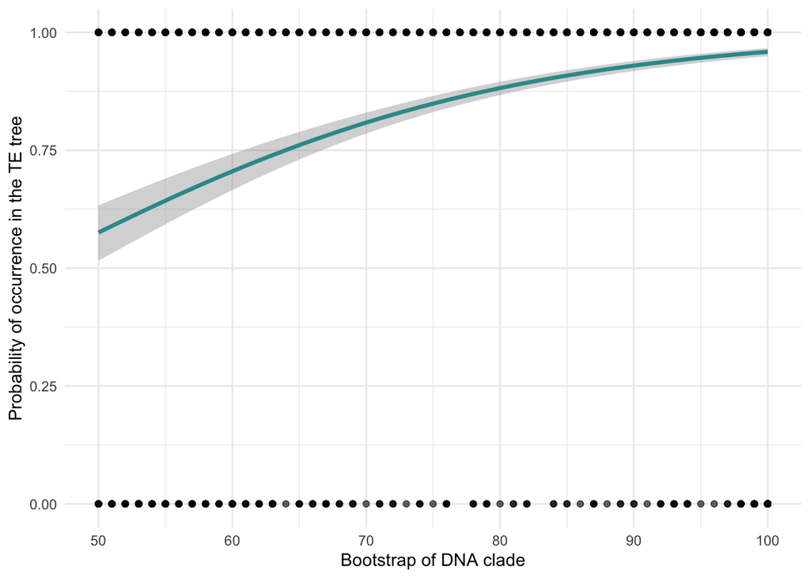

```r
# Plot the logistic regression curve with ggplot2
ggplot(MPlogistic, aes(x = support_tree1, y = occurrence_tree2)) +
  geom_point(alpha = 0.6) +  # Plot the data points
  geom_smooth(method = "glm", method.args = list(family = "binomial"),
              color = "#339999", size = 1.2) +  # Logistic regression curve
  labs(x = "Bootstrap of DNA clade", y = "Probability of occurrence in the TE tree") +
  theme_minimal()
```

```r
# B) ML ASC
# Perform logistic regression
mlasc_logistic_result <- glm(occurrence_tree2 ~ support_tree1, data = MLASClogistic, family = binomial)
# Print a summary of the model
summary(mlasc_logistic_result)
```

```
##
## Call:
## glm(formula = occurrence_tree2 ~ support_tree1, family = binomial,
##     data = MLASClogistic)
##
## Coefficients:
##                Estimate Std. Error z value Pr(>|z|)
## (Intercept)   -4.443616   0.319611  -13.90   <2e-16 ***
## support_tree1  0.074038   0.003712   19.95   <2e-16 ***
## ---
## Signif. codes:  0 '***' 0.001 '**' 0.01 '*' 0.05 '.' 0.1 ' ' 1
##
## (Dispersion parameter for binomial family taken to be 1)
##
##     Null deviance: 2256.8  on 3333  degrees of freedom
## Residual deviance: 1847.5  on 3332  degrees of freedom
## AIC: 1851.5
##
## Number of Fisher Scoring iterations: 5
```

```r
# Calculate 95% confidence intervals for the coefficients
confint(mlasc_logistic_result)
```

```
##                     2.5 %      97.5 %
## (Intercept)   -5.07382601 -3.82007207
## support_tree1  0.06682053  0.08138043
```

```r
# Interpretation
exp(mlasc_logistic_result$coefficients[[2]]) # If coefficient is 0.06 and exp(0.09) is 1.06, then the each unit of 1% bootstrap in MOL clade increases the chance of the occurrence of this clade in TE by 6%
```

```
## [1] 1.076848
```

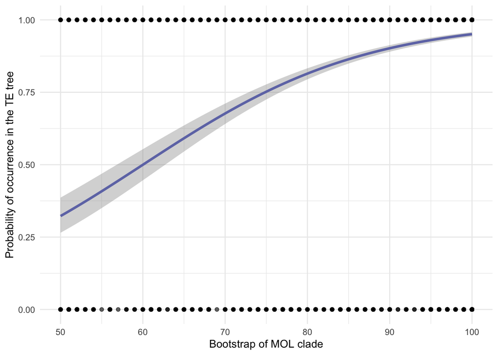

```r
# Plot the logistic regression curve with ggplot2
ggplot(MLASClogistic, aes(x = support_tree1, y = occurrence_tree2)) +
  geom_point(alpha = 0.6) +  # Plot the data points
  geom_smooth(method = "glm", method.args = list(family = "binomial"),
              color = "#6f77b4", size = 1.2) +  # Logistic regression curve
  labs(x = "Bootstrap of MOL clade", y = "Probability of occurrence in the TE tree") +
  theme_minimal()
```

```r
# C) ML noASC
# Perform logistic regression
mlnoasc_logistic_result <- glm(occurrence_tree2 ~ support_tree1, data = MLnoASClogistic, family = binomial)
# Print a summary of the model
summary(mlnoasc_logistic_result)
```

```
##
## Call:
## glm(formula = occurrence_tree2 ~ support_tree1, family = binomial,
##     data = MLnoASClogistic)
##
## Coefficients:
##                Estimate Std. Error z value Pr(>|z|)
## (Intercept)   -4.653368   0.320912  -14.50   <2e-16 ***
## support_tree1  0.076247   0.003729   20.45   <2e-16 ***
## ---
## Signif. codes:  0 '***' 0.001 '**' 0.01 '*' 0.05 '.' 0.1 ' ' 1
##
## (Dispersion parameter for binomial family taken to be 1)
##
##     Null deviance: 2282.2  on 3333  degrees of freedom
## Residual deviance: 1845.1  on 3332  degrees of freedom
## AIC: 1849.1
##
## Number of Fisher Scoring iterations: 5
```

```r
# Calculate 95% confidence intervals for the coefficients
confint(mlnoasc_logistic_result)
```

```
##                     2.5 %      97.5 %
## (Intercept)   -5.28674079 -4.02790901
## support_tree1  0.06900211  0.08362971
```

```r
# Interpretation
exp(mlnoasc_logistic_result$coefficients[[2]]) # If coefficient is 0.06 and exp(0.09) is 1.06, then the each unit of 1% bootstrap in MOL clade increases the chance of the occurrence of this clade in TE by 6%
```

```
## [1] 1.07923
```

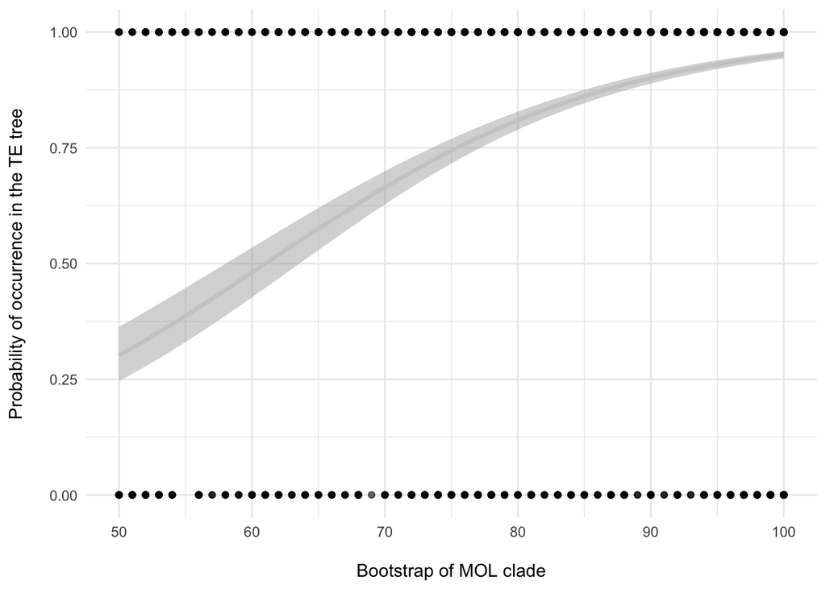

```r
# Plot the logistic regression curve with ggplot2
ggplot(MLnoASClogistic, aes(x = support_tree1, y = occurrence_tree2)) +
  geom_point(alpha = 0.6) +  # Plot the data points
  geom_smooth(method = "glm", method.args = list(family = "binomial"),
              color = "#cccccc", size = 1.2) +  # Logistic regression curve
  labs(x = "\nBootstrap of MOL clade", y = "Probability of occurrence in the TE tree\n") +
  theme_minimal()
```